# Analysing Sentences Backbone Communities

### Closest sentences of each kmean cluster’s centroid composing the backbone community

#### Top terms 3_7: gold, quantity_theory, purchasing_power, monetary_system, purchasing (1900-1919)

| Sentence | Title | Year | Journal | Authors | Distance to Centroid |
| --- | --- | --- | --- | --- | --- |
| The purpose of the following pages is to make clear this development of the theory of money from the form in which it was enunciated by Adam Smith to that in which it may be regarded as Ricardo’s inte… | [The Development of the Theory of Money from Adam Smith to David Ricardo](http://www.jstor.org/stable/1883613) | 1911 | The Quarterly Journal of Economics | Jacob H. Hollander | 7.014592 |
| This requires, first, a brief reference to an existing controversy in monetary theory; secondly, a sketch of the relations established by the theory between the origin, the functions, and the value of… | [Social Value and the Theory of Money](http://www.jstor.org/stable/1823155) | 1917 | Journal of Political Economy | Walter Stewart | 7.146592 |
| Writers on money whose definitions of value are of the relative type very commonly more or less unconsciously make use of the absolute notion, and sometimes make a sudden shift from the one notion to … | [The Concept of Value Further Considered](http://www.jstor.org/stable/1883304) | 1915 | The Quarterly Journal of Economics | B. M. Anderson, Jr. | 7.205111 |
| If we compare the chapters upon money in any systematic treatise published since the controversy with those on the same subject contained in such a book as J. S. Mill’s Principles of MARCH Political E… | [The Study of Economic History](http://www.jstor.org/stable/2221137) | 1906 | The Economic Journal | L. L. Price | 7.279546 |
| On the other hand, if this most essential step on the way to a rational monetary system should be taken, if the free coining of gold, like that of silver, should cease, and eventually the banknote its… | [The Influence of the Rate of Interest on Prices](http://www.jstor.org/stable/2220665) | 1907 | The Economic Journal | Knut Wicksell | 7.286450 |

#### Top terms 3_29: circulation, velocity, quantity_theory, walras, money_income (1920-1939)

| Sentence | Title | Year | Journal | Authors | Distance to Centroid |
| --- | --- | --- | --- | --- | --- |
| Professor Pigou starts his argument by putting forward a thesis which, he says, “is what Mr. Hawtrey seems to hanker after, and certainly is what he ought to maintain if his statement about ‘a purely … | [The Monetary Theory of the Trade Cycle](http://www.jstor.org/stable/2223690) | 1929 | The Economic Journal | R. G. Hawtrey, A. C. Pigou | 6.764096 |
| Frisch’s mode of connecting the marginal utility of money with the principles of index numbers, of labor supply, and, above all, of taxation, has been briefly sketched in the foregoing pages. | [Frisch on the Measurement of Utility](http://www.jstor.org/stable/1822876) | 1933 | Journal of Political Economy | Henry Schultz | 6.944820 |
| I am afraid, also, that further countenance is given to the notion that “the theory of general equilibrium” has been receptive to the introduction of a numiraire in a degree which it would not dream o… | [The Monetary Aspects of the Walrasian System](http://www.jstor.org/stable/1824877) | 1935 | Journal of Political Economy | Arthur W. Marget | 7.196385 |
| The Coordination of the General Theories of Money and Price1 By P. N. ROSENSTEIN-RODAN THE distinction between “influences from the side of money” and ” from the side of goods ” and the consequent sep… | [The Coordination of the General Theories of Money and Price](http://www.jstor.org/stable/2549221) | 1936 | Economica | P. N. Rosenstein-Rodan | 7.319735 |
| But consideration of this subject may be postponed profitably until.we have dealt with the relation of Frisch’s assumptions to his real money utility function. | [Real Income, Expenditure Proportionality, and Frisch’s “New Methods of Measuring Marginal Utility”](http://www.jstor.org/stable/2967658) | 1936 | The Review of Economic Studies | Abram Burk | 7.326314 |

#### Top terms 3_76: quantity_theory, balances, monetary_authorities, reserves, real_balances (1960-1969)

| Sentence | Title | Year | Journal | Authors | Distance to Centroid |
| --- | --- | --- | --- | --- | --- |
| The inadequacy of traditional theory, in this respect, was recognized by Professor Domar when he spoke of “… a theoretical wonderland where a positive net propensity to save is consistent with a const… | [Interregional Income Differences: Self-Perpetuation](http://www.jstor.org/stable/1055613) | 1961 | Southern Economic Journal | Rufus B. Hughes, Jr. | 7.579349 |
| IV Since the outcome now depends on quantitative considerations, it seems appropriate to examine, in somewhat greater detail, Professor Ascheim’s arguments concerning the ” income ” and ” liquidity ” … | [A Note on Open Market Operations Versus Variations in Reserve Requirements](http://www.jstor.org/stable/2228719) | 1962 | The Economic Journal | D. C. Rowan | 7.877601 |
| Contrary to the argument in this text, it appears to be a general item of faith among economists that short of a revision in the unit of account, 1 I would like to thank Mr. H. L. Miller for extremely… | [Money and the Unit of Account](http://www.jstor.org/stable/41796979) | 1966 | Zeitschrift für Nationalökonomie / Journal of Economics | Jacques Melitz | 7.929532 |
| Nevertheless the central place which F&S give their money stock in theoretical analysis, historical interpretation, and policy recommendation invites critical scrutiny. | [The Monetary Interpretation of History](http://www.jstor.org/stable/1814559) | 1965 | The American Economic Review | James Tobin | 7.936701 |
| “2 The main aspect of Ricardian theory, which Mason then uses to show that no income effect reasoning has been involved, is the long-run static nature of Ricardo’s analysis.3 In the following an attem… | [Ricardo and Thornton on the Transfer Mechanism](http://www.jstor.org/stable/1884203) | 1961 | The Quarterly Journal of Economics | Herbert G. Grubel | 8.009297 |

#### Top terms 3_89: optimum_quantity, monetary_approach, money_supply, monetary, monetary_theory (1970-1979)

| Sentence | Title | Year | Journal | Authors | Distance to Centroid |
| --- | --- | --- | --- | --- | --- |
| 261-70 provide an in-depth analysis of Steuart’s monetary theory. | [An Analytical Outline of Sir James Steuart’s Macroeconomic Model](http://www.jstor.org/stable/2662942) | 1979 | Oxford Economic Papers | M. A. Akhtar | 6.821303 |
| The Anatomy of Monetary Theory Bv ROBERT W. CLOWER* It is obvious even to the most ordinary intelligence, that a commodity should be given up by its owner in exchange for another more useful to him. | [The Anatomy of Monetary Theory](http://www.jstor.org/stable/1815905) | 1977 | The American Economic Review | Robert W. Clower | 7.055374 |
| 61, May 1971, reprinted in Further Essays in Monetary Economics. | [The Scientific Contributions of Milton Friedman](http://www.jstor.org/stable/3439568) | 1977 | The Scandinavian Journal of Economics | Niels Thygesen | 7.129903 |
| More important, this report hopefully demonstrates that by using the model as it stands, one can clarify some basic issues of monetary theory, such as the Quantity Theory and the classical dichotomy. | [On the Role of Money and the Existence of a Monetary Equilibrium](http://www.jstor.org/stable/2296364) | 1972 | The Review of Economic Studies | Jean-Michel Grandmont, Yves Younes | 7.168712 |
| Studies in Monetary Economics 1. | [The Transition from Fixed Exchange Rates to Money Supply Targets](http://www.jstor.org/stable/1992020) | 1977 | Journal of Money, Credit and Banking | Michael Parkin | 7.221452 |

#### Top terms 3_93: rational_expectations, inflation, inflationary, monetary_policy, inflationary_expectations (1970-1979)

| Sentence | Title | Year | Journal | Authors | Distance to Centroid |
| --- | --- | --- | --- | --- | --- |
| Sargent, T. J., and Wallace, N. “Rational Expectations and the Dynamics of Hyperinflation.” | [Economically Rational Expectations: Are Innovations in the Rate of Inflation Independent of Innovations in Measures of Monetary and Fiscal Policy?](http://www.jstor.org/stable/1829866) | 1976 | Journal of Political Economy | Edgar L. Feige , Douglas K. Pearce | 6.158237 |
| Next comes a description of the behavior of the model embodying “rational” expectations; I show that under this assumption, the natural unemployment rate hypothesis and a version of Fisher’s theory ab… | [Rational Expectations, the Real Rate of Interest, and the Natural Rate of Unemployment](http://www.jstor.org/stable/2534097) | 1973 | Brookings Papers on Economic Activity | Thomas J. Sargent, David Fand , Stephen Goldfeld | 6.211727 |
| & Wallace, N.: Rational expectations and the dynamics of hyperinflation. | [A Monetary Approach to the Exchange Rate: Doctrinal Aspects and Empirical Evidence](http://www.jstor.org/stable/3439924) | 1976 | The Scandinavian Journal of Economics | Jacob A. Frenkel | 6.348653 |
| Sargent, Thomas J., and Wallace, N. “Rational Expectations and Dynamics of Hyperinflation.” | [Money Wages, Prices, and Causality](http://www.jstor.org/stable/1837424) | 1977 | Journal of Political Economy | Y. P. Mehra | 6.368002 |
| For the purposes of this paper, price expectations will be defined as rational if they fully incorporate the information contained in current and past rates of inflation. | [A Note on the Rationality of the Livingston Price Expectations](http://www.jstor.org/stable/1830403) | 1975 | Journal of Political Economy | James E. Pesando | 6.369397 |

#### Top terms 3_99: rational_expectations, optimal_money, money_supply, supply_rule, monetary_policy (1980-1989)

| Sentence | Title | Year | Journal | Authors | Distance to Centroid |
| --- | --- | --- | --- | --- | --- |
| “Rational Expectations and the Role of Monetary Policy: A Generali- 7ation.” | [Classical Monetary Theory, New and Old](http://www.jstor.org/stable/1992610) | 1987 | Journal of Money, Credit and Banking | Jürg Niehans | 5.850091 |
| “The Monetary Mechanisms in the Light of Rational Expectations,” Rational Expectations and Economic Policy. | [The Demand and Supply of Labor and Interstate Relative Wages: An Empirical Analysis](http://www.jstor.org/stable/144135) | 1981 | Economic Geography | Gordon L. Clark , Kenneth P. Ballard | 5.872948 |
| “Rational Expectations and the Role of Monetary Policy.”J. | [Monetary Policy and the Information Content of Prices](http://www.jstor.org/stable/1830292) | 1982 | Journal of Political Economy | Robert G. King | 5.994562 |
| “Rational Expectations and the Role of Monetary Policy.”J. | [Money and the Dispersion of Relative Prices](http://www.jstor.org/stable/1833314) | 1981 | Journal of Political Economy | Zvi Hercowitz | 5.994563 |
| “Rational Expectations and the Role of Monetary Policy.”J. | [The Effects on Output of Money Growth and Interest Rate Volatility in the United States](http://www.jstor.org/stable/1831383) | 1984 | Journal of Political Economy | Paul Evans | 5.994563 |

#### Top terms 3_105: rational_expectations, macroeconomic, expectations, macroeconomics, business_cycle (1980-1989)

| Sentence | Title | Year | Journal | Authors | Distance to Centroid |
| --- | --- | --- | --- | --- | --- |
| Rational Expectations and Macroeconomics Analysis Macroeconomics has been transformed in the last dozen years by the rational -expectations hypothesis and its associated econometric practices. | [Conceptual Evolution in Economics: The Case of Rational Expectations](http://www.jstor.org/stable/40324998) | 1985 | Eastern Economic Journal | Randall Bausor | 6.647367 |
| “Rational Expectations and the Dynamic Structure of Macroeconomic Models: A Critical Review,” J. Monet. | [Recent Work on Business Cycles in Historical Perspective: A Review of Theories and Evidence](http://www.jstor.org/stable/2725624) | 1985 | Journal of Economic Literature | Victor Zarnowitz | 6.904277 |
| “Rational Expectations and the Dynamic Structure of Macroeconomic Models: A Critical Review.”J. | [Market Fundamentals versus Price-Level Bubbles: The First Tests](http://www.jstor.org/stable/1837311) | 1980 | Journal of Political Economy | Robert P. Flood, Peter M. Garber | 6.906678 |
| “Macroeconomics After a Decade of Rational Expectations: Some Critical Issues.” | [Does Anticipated Monetary Policy Matter?: Another Look](http://www.jstor.org/stable/1992503) | 1985 | Journal of Money, Credit and Banking | Robert T. McGee , Richard T. Stasiak | 6.907940 |
| “Macroeconomics After a Decade of Rational Expectations: Some Critical Issues.” | [On “Real” and “Sticky-Price” Theories of the Business Cycle](http://www.jstor.org/stable/1992461) | 1986 | Journal of Money, Credit and Banking | Bennett T. McCallum | 6.907941 |

#### Top terms 3_106: inflation, inflationary_expectations, inflationary, expected_inflation, rational_expectations (1980-1989)

| Sentence | Title | Year | Journal | Authors | Distance to Centroid |
| --- | --- | --- | --- | --- | --- |
| Rational Expectations and Inflation. | [Inflationary Rigidities and Orthodox Stabilization Policies: Lessons from Latin America](http://www.jstor.org/stable/3989839) | 1988 | The World Bank Economic Review | Miguel A. Kiguel, Nissan Liviatan | 5.212779 |
| Rational Expectations and Inflation. | [The End of the Hungarian Hyperinflation of 1945-1946](http://www.jstor.org/stable/1992364) | 1989 | Journal of Money, Credit and Banking | Pierre L. Siklos | 5.212779 |
| Rational Expectations and Inflation, Harper and Row, New York. | [Mexico: Stabilization, Debt and Growth](http://www.jstor.org/stable/1344488) | 1988 | Economic Policy | Rudiger Dornbusch, Jose Vinals , Richard Portes | 5.270823 |
| An important innovation in recent models of inflationary expectations is that such expectations are formed “rationally.” | [Sticky Prices and Disequilibrium Adjustment in a Rational Model of the Inflationary Process](http://www.jstor.org/stable/1803483) | 1981 | The American Economic Review | Michael Mussa | 5.781574 |
| In Rational Expectations and Inflation T. Sargent. | [Macroeconomics and Politics](http://www.jstor.org/stable/3584936) | 1988 | NBER Macroeconomics Annual | Alberto Alesina | 6.086953 |

#### Top terms 3_114: rational_expectations, optimal_money, supply_rule, inflation, contracts_rational (1990-1999)

| Sentence | Title | Year | Journal | Authors | Distance to Centroid |
| --- | --- | --- | --- | --- | --- |
| “Rational Expectations and the Dynamics of Hyperinflation.” | [The Hyperinflation Model of Money Demand Revisited](http://www.jstor.org/stable/1992749) | 1991 | Journal of Money, Credit and Banking | Mark P. Taylor | 6.439741 |
| “Rational Expectations and the Dynamics of Hyperinflation.” | [Inflation and Currency Depreciation in Germany, 1920-1923: A Dynamic Model of Prices and the Exchange Rate](http://www.jstor.org/stable/2077872) | 1995 | Journal of Money, Credit and Banking | Giuseppe Tullio | 6.439741 |
| “Rational Expectations and the Dynamics of Hyperinflation.” | [Extreme Inflation: Dynamics and Stabilization](http://www.jstor.org/stable/2534504) | 1990 | Brookings Papers on Economic Activity | Rudiger Dornbusch , Federico Sturzenegger, Holger Wolf , Stanley Fischer , Robert J. Barro | 6.439743 |
| “Rational Expectations and the Dynamics of Hyperinflation.” | [Seigniorage and Inflation: The Case of Argentina](http://www.jstor.org/stable/2077742) | 1995 | Journal of Money, Credit and Banking | Miguel A. Kiguel , Pablo Andres Neumeyer | 6.439743 |
| “Rational Expectations and the Dynamics of Hyperinflation.” | [Cointegration and Cagan’s Model of Hyperinflation under Rational Expectations](http://www.jstor.org/stable/2077767) | 1993 | Journal of Money, Credit and Banking | Tom Engsted | 6.439743 |

### Top articles (most sentences) of the backbone cluster

| Title | Year | Journal | Authors | Number sentences | Words Similarity |
| --- | --- | --- | --- | --- | --- |
| [Recent Work on Business Cycles in Historical Perspective: A Review of Theories and Evidence](http://www.jstor.org/stable/2725624) | 1985 | Journal of Economic Literature | Victor Zarnowitz | 30 | 0.647 |
| [Rational Expectations and Macroeconomic Stabilization Policy: An Overview](http://www.jstor.org/stable/1992031) | 1980 | Journal of Money, Credit and Banking | Bennett T. McCallum | 26 | 0.671 |
| [Some Macro Foundations for Micro Theory](http://www.jstor.org/stable/2534346) | 1981 | Brookings Papers on Economic Activity | Charles L. Schultze, William Fellner , Robert J. Gordon | 21 | 0.659 |
| [Inflation: A Survey](http://www.jstor.org/stable/2230624) | 1975 | The Economic Journal | David Laidler , Michael Parkin | 19 | 0.608 |
| [An Economic Theory of Monetary Reform](http://www.jstor.org/stable/1830958) | 1980 | Journal of Political Economy | Robert P. Flood, Peter M. Garber | 19 | 0.629 |
| [Taking Money Seriously](http://www.jstor.org/stable/135258) | 1988 | The Canadian Journal of Economics / Revue canadienne d’Economique | David Laidler | 18 | 0.618 |
| [Market Fundamentals versus Price-Level Bubbles: The First Tests](http://www.jstor.org/stable/1837311) | 1980 | Journal of Political Economy | Robert P. Flood, Peter M. Garber | 17 | 0.664 |
| [Recent Developments in Macroeconomics: A Very Quick Refresher Course](http://www.jstor.org/stable/1992520) | 1988 | Journal of Money, Credit and Banking | N. Gregory Mankiw | 16 | 0.640 |
| [Monetarism: An Interpretation and an Assessment](http://www.jstor.org/stable/2231691) | 1981 | The Economic Journal | D. Laidler | 15 | 0.626 |
| [Monetary Policy and Policy Credibility: Theories and Evidence](http://www.jstor.org/stable/2726940) | 1989 | Journal of Economic Literature | Keith Blackburn , Michael Christensen | 15 | 0.606 |
| [Policy Analysis with Econometric Models](http://www.jstor.org/stable/2534318) | 1982 | Brookings Papers on Economic Activity | Christopher A. Sims, Stephen M. Goldfeld, Jeffrey D. Sachs | 14 | 0.635 |
| [Evolutionary Economics, Rational Expectations, and Monetary Policy](http://www.jstor.org/stable/4224696) | 1978 | Journal of Economic Issues | William J. Frazer, Jr. | 13 | 0.647 |
| [Methods and Problems in Business Cycle Theory](http://www.jstor.org/stable/1992030) | 1980 | Journal of Money, Credit and Banking | Robert E. Lucas, Jr. | 13 | 0.649 |
| [Rational Expectations and Non-Neutrality of Money](http://www.jstor.org/stable/40439311) | 1985 | Weltwirtschaftliches Archiv | Kiyoshi Otani | 13 | 0.664 |
| [Monetary Policy in a Game — Theoretic Framework / Spieltheoretische Ansätze zur Geldpolitik](http://www.jstor.org/stable/23811667) | 1992 | Jahrbücher für Nationalökonomie und Statistik / Journal of Economics and Statistics | Jac J. Sijben | 13 | 0.630 |

### Top articles (most sentences) of the cluster for each time window

#### Top articles for 3_7: gold, quantity_theory, purchasing_power, monetary_system, purchasing (1900-1919)

| Title | Year | Journal | Authors | Number sentences | Words Similarity |
| --- | --- | --- | --- | --- | --- |
| [The Role of Money in Economic Theory](http://www.jstor.org/stable/1803798) | 1916 | The American Economic Review | Wesley C. Mitchell | 12 | 0.625 |
| [Social Value and the Theory of Money](http://www.jstor.org/stable/1823155) | 1917 | Journal of Political Economy | Walter Stewart | 8 | 0.608 |
| [The Value of Money](http://www.jstor.org/stable/1885078) | 1917 | The Quarterly Journal of Economics | A. C. Pigou | 8 | 0.593 |
| [The Concept of an Economic Quantity](http://www.jstor.org/stable/1884906) | 1907 | The Quarterly Journal of Economics | T. N. Carver | 5 | 0.595 |
| [Is an Ideal Money Attainable?](http://www.jstor.org/stable/1820954) | 1903 | Journal of Political Economy | Charles A. Conant | 4 | 0.638 |
| [Prices, Credit, and the Quantity Theory Again](http://www.jstor.org/stable/1817327) | 1906 | Journal of Political Economy | Spurgeon Bell | 4 | 0.623 |
| [The Standard of Value and Prices](http://www.jstor.org/stable/1820833) | 1907 | Journal of Political Economy | Ralph H. Hess | 4 | 0.610 |
| [The Rationality of Economic Activity](http://www.jstor.org/stable/1820997) | 1910 | Journal of Political Economy | Wesley C. Mitchell | 4 | 0.623 |
| [The Development of the Theory of Money from Adam Smith to David Ricardo](http://www.jstor.org/stable/1883613) | 1911 | The Quarterly Journal of Economics | Jacob H. Hollander | 4 | 0.587 |
| [The Fundamental Economic Principle](http://www.jstor.org/stable/1884895) | 1901 | The Quarterly Journal of Economics | Charles A. Tuttle | 3 | 0.644 |

#### Top articles for 3_29: circulation, velocity, quantity_theory, walras, money_income (1920-1939)

| Title | Year | Journal | Authors | Number sentences | Words Similarity |
| --- | --- | --- | --- | --- | --- |
| [The Relation between the Velocity of Circulation of Money and the “Velocity of Circulation of Goods:” II](http://www.jstor.org/stable/1822850) | 1932 | Journal of Political Economy | Arthur W. Marget | 11 | 0.612 |
| [The Monetary Aspects of the Walrasian System](http://www.jstor.org/stable/1824877) | 1935 | Journal of Political Economy | Arthur W. Marget | 10 | 0.604 |
| [The Relation Between the Velocity of Circulation of Money and the “Velocity of Circulation of Goods”](http://www.jstor.org/stable/1824154) | 1932 | Journal of Political Economy | Arthur W. Marget | 9 | 0.604 |
| [The “Paradox” of Saving](http://www.jstor.org/stable/2547921) | 1931 | Economica | F. A. von Hayek | 6 | 0.619 |
| [The Coordination of the General Theories of Money and Price](http://www.jstor.org/stable/2549221) | 1936 | Economica | P. N. Rosenstein-Rodan | 6 | 0.608 |
| [Recent and Contemporary Theories of Progressive Taxation](http://www.jstor.org/stable/1824777) | 1938 | Journal of Political Economy | Elmer D. Fagan | 6 | 0.619 |
| [Price Economics Versus Welfare Economics: Contemporary Opinion](http://www.jstor.org/stable/1803336) | 1920 | The American Economic Review | Frank A. Fetter | 5 | 0.622 |
| [Alternative Theories of the Rate of Interest: Three Rejoinders](http://www.jstor.org/stable/2225356) | 1937 | The Economic Journal | Bertil Ohlin , D. H. Robertson, R. G. Hawtrey | 5 | 0.593 |
| [Equilibrium and Wealth: A Word of Encouragement to Economists](http://www.jstor.org/stable/137181) | 1939 | The Canadian Journal of Economics and Political Science / Revue canadienne d’Economique et de Science politique | K. E. Boulding | 5 | 0.624 |
| [Hawtrey’s the Gold Standard in Theory and Practice](http://www.jstor.org/stable/1885369) | 1927 | The Quarterly Journal of Economics | Arthur W. Marget | 4 | 0.606 |

#### Top articles for 3_76: quantity_theory, balances, monetary_authorities, reserves, real_balances (1960-1969)

| Title | Year | Journal | Authors | Number sentences | Words Similarity |
| --- | --- | --- | --- | --- | --- |
| [Recent Theories Concerning the Nature and Role of Interest](http://www.jstor.org/stable/2228764) | 1961 | The Economic Journal | G. L. Shackle | 4 | 0.610 |
| [Keynes and the Nature of Human Affairs](http://www.jstor.org/stable/40434865) | 1961 | Weltwirtschaftliches Archiv | G. L. S. Shackle | 4 | 0.604 |
| [Some Further Investigations of Demand and Supply Functions for Money](http://www.jstor.org/stable/2977456) | 1964 | The Journal of Finance | Karl Brunner , Allan H. Meltzer | 4 | 0.615 |
| [Monetary Rules: A New Look](http://www.jstor.org/stable/724789) | 1965 | The Journal of Law & Economics | M. Bronfenbrenner | 4 | 0.592 |
| [Wicksell’s Theory of Circulation](http://www.jstor.org/stable/1828599) | 1967 | Journal of Political Economy | Edward J. Nell | 4 | 0.598 |
| [The Present State of International Liquidity Theory](http://www.jstor.org/stable/1831844) | 1968 | The American Economic Review | Robert Clower , Richard Lipsey | 4 | 0.635 |
| [The Optimal Rate of Growth of Money](http://www.jstor.org/stable/1830384) | 1968 | Journal of Political Economy | Alvin L. Marty | 4 | 0.601 |
| [The “Neutrality” of Improvements](http://www.jstor.org/stable/2228768) | 1961 | The Economic Journal | R. F. Harrod | 3 | 0.614 |
| [Investment in Human Capital: Comment](http://www.jstor.org/stable/1813847) | 1961 | The American Economic Review | Harry G. Shaffer | 3 | 0.605 |
| [The Monetary Mechanism and Its Interaction with Real Phenomena](http://www.jstor.org/stable/1927150) | 1963 | The Review of Economics and Statistics | Franco Modigliani | 3 | 0.605 |

#### Top articles for 3_89: optimum_quantity, monetary_approach, money_supply, monetary, monetary_theory (1970-1979)

| Title | Year | Journal | Authors | Number sentences | Words Similarity |
| --- | --- | --- | --- | --- | --- |
| [Inflation: A Survey](http://www.jstor.org/stable/2230624) | 1975 | The Economic Journal | David Laidler , Michael Parkin | 13 | 0.608 |
| [The Scientific Contributions of Milton Friedman](http://www.jstor.org/stable/3439568) | 1977 | The Scandinavian Journal of Economics | Niels Thygesen | 10 | 0.604 |
| [Uncertainty and the Uses of Money](http://www.jstor.org/stable/40324718) | 1979 | Eastern Economic Journal | Douglas Vickers | 10 | 0.607 |
| [Is There an Optimal Money Supply?](http://www.jstor.org/stable/2325489) | 1970 | The Journal of Finance | Robert W. Clower | 8 | 0.604 |
| [The Theory of the Real-Balance Effect: A Criticism and A Generalisation](http://www.jstor.org/stable/29794098) | 1972 | Indian Economic Review | Suraj Gupta | 7 | 0.643 |
| [J. Laurence Laughlin and the Quantity Theory of Money](http://www.jstor.org/stable/1840381) | 1978 | Journal of Political Economy | Lance Girton, Don Roper | 6 | 0.602 |
| [Money, Efficiency, and Knowledge](http://www.jstor.org/stable/134866) | 1979 | The Canadian Journal of Economics / Revue canadienne d’Economique | T. K. Rymes | 6 | 0.649 |
| [The Roles of Money in an Economy and the Optimum Quantity of Money](http://www.jstor.org/stable/2552841) | 1971 | Economica | Morris Perlman | 5 | 0.598 |
| [Rational Response to the Money Supply](http://www.jstor.org/stable/1829848) | 1974 | Journal of Political Economy | Richard Roll | 5 | 0.611 |
| [The Competitive Supply of Money](http://www.jstor.org/stable/1991457) | 1974 | Journal of Money, Credit and Banking | Benjamin Klein | 5 | 0.586 |

#### Top articles for 3_93: rational_expectations, inflation, inflationary, monetary_policy, inflationary_expectations (1970-1979)

| Title | Year | Journal | Authors | Number sentences | Words Similarity |
| --- | --- | --- | --- | --- | --- |
| [Evolutionary Economics, Rational Expectations, and Monetary Policy](http://www.jstor.org/stable/4224696) | 1978 | Journal of Economic Issues | William J. Frazer, Jr. | 12 | 0.649 |
| [Economically Rational Expectations: Are Innovations in the Rate of Inflation Independent of Innovations in Measures of Monetary and Fiscal Policy?](http://www.jstor.org/stable/1829866) | 1976 | Journal of Political Economy | Edgar L. Feige , Douglas K. Pearce | 10 | 0.669 |
| [Price Level Adjustments and the Rational Expectations Approach to Macroeconomic Stabilization Policy](http://www.jstor.org/stable/1991573) | 1978 | Journal of Money, Credit and Banking | Bennett T. McCallum | 8 | 0.699 |
| [Macro Policy Responses to Price Shocks](http://www.jstor.org/stable/2534306) | 1979 | Brookings Papers on Economic Activity | Edward M. Gramlich | 8 | 0.634 |
| [Monetary Policy during a Transition to Rational Expectations](http://www.jstor.org/stable/1830083) | 1975 | Journal of Political Economy | John B. Taylor | 7 | 0.611 |
| [Rational Expectations in a Disequilibrium Model of the Term Structure](http://www.jstor.org/stable/1804943) | 1976 | The American Economic Review | Michael E. Echols , Jan Walter Elliott | 7 | 0.635 |
| [Rational Expectations in the Macro Model](http://www.jstor.org/stable/2534381) | 1976 | Brookings Papers on Economic Activity | William Poole , Edmund S. Phelps, Martin N. Baily | 7 | 0.652 |
| [Efficient-Markets Theory: Implications for Monetary Policy](http://www.jstor.org/stable/3217956) | 1978 | Brookings Papers on Economic Activity | Frederic S. Mishkin | 7 | 0.627 |
| [Inflation Planning Reconsidered](http://www.jstor.org/stable/2553498) | 1978 | Economica | Edmund S. Phelps | 7 | 0.601 |
| [Inflation: A Survey](http://www.jstor.org/stable/2230624) | 1975 | The Economic Journal | David Laidler , Michael Parkin | 6 | 0.609 |

#### Top articles for 3_99: rational_expectations, optimal_money, money_supply, supply_rule, monetary_policy (1980-1989)

| Title | Year | Journal | Authors | Number sentences | Words Similarity |
| --- | --- | --- | --- | --- | --- |
| [An Economic Theory of Monetary Reform](http://www.jstor.org/stable/1830958) | 1980 | Journal of Political Economy | Robert P. Flood, Peter M. Garber | 17 | 0.626 |
| [Taking Money Seriously](http://www.jstor.org/stable/135258) | 1988 | The Canadian Journal of Economics / Revue canadienne d’Economique | David Laidler | 14 | 0.608 |
| [Rational Expectations and Macroeconomic Stabilization Policy: An Overview](http://www.jstor.org/stable/1992031) | 1980 | Journal of Money, Credit and Banking | Bennett T. McCallum | 13 | 0.678 |
| [Rational Expectations and Non-Neutrality of Money](http://www.jstor.org/stable/40439311) | 1985 | Weltwirtschaftliches Archiv | Kiyoshi Otani | 13 | 0.664 |
| [The “Rationality” of Money Supply Expectations and the Short-Run Response of Interest Rates to Monetary Surprises](http://www.jstor.org/stable/1991932) | 1981 | Journal of Money, Credit and Banking | Jacob Grossman | 10 | 0.667 |
| [A Theory of Ambiguity, Credibility, and Inflation under Discretion and Asymmetric Information](http://www.jstor.org/stable/1912324) | 1986 | Econometrica | Alex Cukierman , Allan H. Meltzer | 10 | 0.608 |
| [Monetarism and Economic Theory](http://www.jstor.org/stable/2553164) | 1980 | Economica | F. H. Hahn | 9 | 0.630 |
| [The Rational Expectations Hypothesis in Retrospect](http://www.jstor.org/stable/1803937) | 1983 | The American Economic Review | Filippo Cesarano | 9 | 0.668 |
| [Interest Rate Volatility and Monetary Policy](http://www.jstor.org/stable/1992540) | 1984 | Journal of Money, Credit and Banking | Carl E. Walsh | 9 | 0.685 |
| [Recent Work on Business Cycles in Historical Perspective: A Review of Theories and Evidence](http://www.jstor.org/stable/2725624) | 1985 | Journal of Economic Literature | Victor Zarnowitz | 9 | 0.683 |

#### Top articles for 3_105: rational_expectations, macroeconomic, expectations, macroeconomics, business_cycle (1980-1989)

| Title | Year | Journal | Authors | Number sentences | Words Similarity |
| --- | --- | --- | --- | --- | --- |
| [Recent Work on Business Cycles in Historical Perspective: A Review of Theories and Evidence](http://www.jstor.org/stable/2725624) | 1985 | Journal of Economic Literature | Victor Zarnowitz | 14 | 0.634 |
| [Microeconomic Efficiency and Nominal Wage Stickiness](http://www.jstor.org/stable/1812701) | 1985 | The American Economic Review | Charles L. Schultze | 12 | 0.624 |
| [Rational Expectations, Wage Rigidity and Involuntary Unemployment: A Particular Theory](http://www.jstor.org/stable/2662738) | 1982 | Oxford Economic Papers | David K. H. Begg | 11 | 0.658 |
| [Output Fluctuations and Gradual Price Adjustment](http://www.jstor.org/stable/2724154) | 1981 | Journal of Economic Literature | Robert J. Gordon | 10 | 0.610 |
| [A Near-Rational Model of the Business Cycle, With Wage and Price Inertia](http://www.jstor.org/stable/1882925) | 1985 | The Quarterly Journal of Economics | George A. Akerlof, Janet L. Yellen | 10 | 0.638 |
| [Walrasian Indeterminacy and Keynesian Macroeconomics](http://www.jstor.org/stable/2297718) | 1986 | The Review of Economic Studies | J. D. Geanakoplos , H. M. Polemarchakis | 10 | 0.609 |
| [Rational Expectations and Macroeconomic Stabilization Policy: An Overview](http://www.jstor.org/stable/1992031) | 1980 | Journal of Money, Credit and Banking | Bennett T. McCallum | 9 | 0.666 |
| [Policy Analysis with Econometric Models](http://www.jstor.org/stable/2534318) | 1982 | Brookings Papers on Economic Activity | Christopher A. Sims, Stephen M. Goldfeld, Jeffrey D. Sachs | 9 | 0.651 |
| [Keynes, Harrod, and the Rational Expectations Revolution](http://www.jstor.org/stable/4537930) | 1985 | Journal of Post Keynesian Economics | Steven M. Fazzari | 9 | 0.704 |
| [Demand Disturbances and Aggregate Fluctuations: The Implications of Near Rationality](http://www.jstor.org/stable/2233322) | 1987 | The Economic Journal | Stephen R. G. Jones, James H. Stock | 9 | 0.644 |

#### Top articles for 3_106: inflation, inflationary_expectations, inflationary, expected_inflation, rational_expectations (1980-1989)

| Title | Year | Journal | Authors | Number sentences | Words Similarity |
| --- | --- | --- | --- | --- | --- |
| [Some Macro Foundations for Micro Theory](http://www.jstor.org/stable/2534346) | 1981 | Brookings Papers on Economic Activity | Charles L. Schultze, William Fellner , Robert J. Gordon | 13 | 0.682 |
| [Monetary Policy and Policy Credibility: Theories and Evidence](http://www.jstor.org/stable/2726940) | 1989 | Journal of Economic Literature | Keith Blackburn , Michael Christensen | 9 | 0.613 |
| [Measuring the Expected Real Rate of Interest: An Exploration of Macroeconomic Alternatives: Comment](http://www.jstor.org/stable/1805242) | 1980 | The American Economic Review | John J. Merrick, Jr. | 8 | 0.647 |
| [Testing the Rationality of Inflation Expectations Derived from Survey Data: A Structure-Based Approach](http://www.jstor.org/stable/1058488) | 1982 | Southern Economic Journal | Nicholas R. Noble, T. Windsor Fields | 8 | 0.679 |
| [Are Market Forecasts Rational?](http://www.jstor.org/stable/1802780) | 1981 | The American Economic Review | Frederic S. Mishkin | 7 | 0.643 |
| [Food Prices, Expectations, and Inflation](http://www.jstor.org/stable/1240634) | 1982 | American Journal of Agricultural Economics | Carl Van Duyne | 7 | 0.659 |
| [Recent Work on Business Cycles in Historical Perspective: A Review of Theories and Evidence](http://www.jstor.org/stable/2725624) | 1985 | Journal of Economic Literature | Victor Zarnowitz | 7 | 0.625 |
| [Market Fundamentals versus Price-Level Bubbles: The First Tests](http://www.jstor.org/stable/1837311) | 1980 | Journal of Political Economy | Robert P. Flood, Peter M. Garber | 6 | 0.657 |
| [Perspectives on the Costs of Inflation](http://www.jstor.org/stable/1058655) | 1982 | Southern Economic Journal | Peter Lewin | 6 | 0.620 |
| [On Some Conceptual Issues in Rational Expectations Modeling](http://www.jstor.org/stable/1992035) | 1980 | Journal of Money, Credit and Banking | Edwin Burmeister | 5 | 0.670 |

#### Top articles for 3_114: rational_expectations, optimal_money, supply_rule, inflation, contracts_rational (1990-1999)

| Title | Year | Journal | Authors | Number sentences | Words Similarity |
| --- | --- | --- | --- | --- | --- |
| [Monetary Policy in a Game — Theoretic Framework / Spieltheoretische Ansätze zur Geldpolitik](http://www.jstor.org/stable/23811667) | 1992 | Jahrbücher für Nationalökonomie und Statistik / Journal of Economics and Statistics | Jac J. Sijben | 13 | 0.630 |
| [Extreme Inflation: Dynamics and Stabilization](http://www.jstor.org/stable/2534504) | 1990 | Brookings Papers on Economic Activity | Rudiger Dornbusch , Federico Sturzenegger, Holger Wolf , Stanley Fischer , Robert J. Barro | 8 | 0.635 |
| [The Genesis of Inflation and the Costs of Disinflation](http://www.jstor.org/stable/1992678) | 1991 | Journal of Money, Credit and Banking | Laurence Ball | 8 | 0.657 |
| [Karl Brunner’s Monetary Economics–An Appreciation](http://www.jstor.org/stable/1992701) | 1991 | Journal of Money, Credit and Banking | David E. W. Laidler | 8 | 0.598 |
| [An Optimizing IS-LM Specification for Monetary Policy and Business Cycle Analysis](http://www.jstor.org/stable/2601113) | 1999 | Journal of Money, Credit and Banking | Bennett T. Mccallum, Edward Nelson | 8 | 0.664 |
| [The Hyperinflation Model of Money Demand Revisited](http://www.jstor.org/stable/1992749) | 1991 | Journal of Money, Credit and Banking | Mark P. Taylor | 7 | 0.644 |
| [Interest Rate Control and Nonconvergence to Rational Expectations](http://www.jstor.org/stable/2138687) | 1992 | Journal of Political Economy | Peter Howitt | 7 | 0.636 |
| [Credibility and Changes in Policy Regime](http://www.jstor.org/stable/2138723) | 1995 | Journal of Political Economy | Francisco J. Ruge-Murcia | 7 | 0.641 |
| [Money Illusion](http://www.jstor.org/stable/2951239) | 1997 | The Quarterly Journal of Economics | Eldar Shafir , Peter Diamond, Amos Tversky | 7 | 0.630 |
| [Survey Measures of Expected U.S. Inflation](http://www.jstor.org/stable/2647016) | 1999 | The Journal of Economic Perspectives | Lloyd B. Thomas Jr. | 7 | 0.625 |

### Most cited references in the backbone community

| First Author | Year | Journal | Citation by article | Citation by sentence |
| --- | --- | --- | --- | --- |
| LUCAS-R | 1972 | J EC THEORY | 208 | 16224 |
| LUCAS-R | 1973 | AER | 202 | 11312 |
| MUTH-J | 1961 | ECONOMETRICA | 151 | 7701 |
| FISCHER-S | 1977 | J POLITICAL EC | 182 | 6552 |
| SARGENT-T | 1975 | J POLITICAL EC | 133 | 5320 |
| FRIEDMAN-M | 1968 | AER | 46 | 1748 |
| BARRO-R | 1977 | AER | 45 | 720 |
| BARRO-R | 1976 | J MONETARY EC | 34 | 272 |
| BARRO-R | 1978 | JPE | 28 | 252 |
| BARRO-R | 1983 | JPE | 23 | 207 |
| SARGENT-T | 1976 | J MONETARY EC | 8 | 112 |
| SOLOW-R | 1956 | Q J EC | 7 | 98 |
| PHILLIPS-A | 1958 | ECONOMICA | 7 | 98 |
| BARRO-R | 1983 | J MONETARY EC | 30 | 90 |
| KYDLAND-F | 1977 | J POLITICAL EC | 27 | 81 |

| First Author | Year | Journal | Citation by article | Citation by sentence |
| --- | --- | --- | --- | --- |
| KEYNES-J | 1936 | GENERAL THEORY EMPLO | 286 | 18590 |
| SARGENT-T | 1979 | MACROECONOMIC THEORY | 111 | 3885 |
| FRIEDMAN-M | 1963 | MONETARY HIST US 186 | 69 | 2001 |
| PHELPS-E | 1970 | MICROECONOMIC F EMPL | 48 | 1632 |
| FRIEDMAN-M | 1969 | J LAW ECONOMICS | 63 | 1197 |
| FRIEDMAN-M | 1963 | MONETARY HISTORY US | 50 | 1150 |
| OKUN-A | 1981 | PRICES QUANTITIES MA | 41 | 1107 |
| CAGAN-P | 1956 | STUDIES QUANTITY THE | 46 | 1104 |
| KEYNES-J | 1930 | TREATISE MONEY | 39 | 1053 |
| LUCAS-R | 1976 | PHILLIPS CURVE LABOR | 44 | 924 |
| PATINKIN-D | 1965 | MONEY INTEREST PRICE | 54 | 756 |
| LEIJONHUFVUD-A | 1968 | KEYNESIAN EC EC KEYN | 32 | 448 |
| MALINVAUD-E | 1977 | THEORY UNEMPLOYMENT | 28 | 392 |
| FRIEDMAN-M | 1970 | COUNTER REVOLUTION M | 18 | 234 |
| CAGAN-P | 1956 | MONETARY DYNAMICS HY | 17 | 221 |

### Most cited references per kmean clusters

#### Top references 3_76: quantity_theory, balances, monetary_authorities, reserves, real_balances (1960-1969)

| First Author | Year | Journal | Citation by article | Citation by sentence |
| --- | --- | --- | --- | --- |
| SOLOW-R | 1956 | Q J EC | 6 | 6 |
| PHILLIPS-A | 1958 | ECONOMICA | 6 | 6 |
| TOBIN-J | 1958 | REV ECON STUD | 3 | 6 |
| FRIEDMAN-M | 1959 | J POLITICAL EC | 6 | 6 |
| BAUMOL-W | 1952 | Q J EC | 5 | 5 |
| TOBIN-J | 1958 | REV ECON STUD | 5 | 5 |
| MELTZER-A | 1963 | J POLITICAL EC | 5 | 5 |
| BRONFENBRENNER-M | 1960 | ECONOMETRICA | 5 | 5 |
| SOLOW-R | 1962 | AM EC REV | 4 | 4 |
| RAMSEY-F | 1928 | EC J | 4 | 4 |

| First Author | Year | Journal | Citation by article | Citation by sentence |
| --- | --- | --- | --- | --- |
| FRIEDMAN-M | 1963 | MONETARY HISTORY US | 12 | 48 |
| BAUMOL-W | 1952 | Q J EC | 11 | 44 |
| ROBINSON-J | 1956 | ACCUMULATION CAPITAL | 12 | 36 |
| HARROD-R | 1948 | DYNAMIC EC | 8 | 32 |
| KEYNES-J | 1936 | GENERAL THEORY EMPLO | 8 | 32 |
| GURLEY-J | 1960 | MONEY THEORY FINANCE | 10 | 30 |
| BRUNNER-K | 1963 | J FINANCE | 7 | 28 |
| BRUNNER-K | 1961 | INT EC REV | 6 | 24 |
| MELTZER-A | 1963 | J POLITICAL EC | 6 | 24 |
| FRIEDMAN | 1963 | MONETARY HIST US 186 | 6 | 24 |

#### Top references 3_89: optimum_quantity, monetary_approach, money_supply, monetary, monetary_theory (1970-1979)

| First Author | Year | Journal | Citation by article | Citation by sentence |
| --- | --- | --- | --- | --- |
| MUTH-J | 1961 | ECONOMETRICA | 17 | 17 |
| SOLOW-R | 1956 | Q J EC | 1 | 13 |
| FRIEDMAN-M | 1968 | AER | 1 | 13 |
| LUCAS-R | 1972 | J EC THEORY | 1 | 13 |
| LIPSEY-R | 1960 | ECONOMICA | 1 | 13 |
| PHILLIPS-A | 1958 | ECONOMICA | 1 | 13 |
| SAMUELSON-P | 1960 | AM EC REV | 1 | 13 |
| FRIEDMAN-M | 1971 | J POLIT EC | 1 | 13 |
| MUNDELL-R | 1963 | J POLITICAL EC | 1 | 13 |
| TOBIN-J | 1965 | ECONOMETRICA | 1 | 13 |

| First Author | Year | Journal | Citation by article | Citation by sentence |
| --- | --- | --- | --- | --- |
| KEYNES-J | 1936 | GENERAL THEORY EMPLO | 40 | 520 |
| FRIEDMAN-M | 1969 | J LAW ECONOMICS | 38 | 494 |
| FRIEDMAN-M | 1963 | MONETARY HISTORY US | 24 | 312 |
| PHELPS-E | 1970 | MICROECONOMIC F EMPL | 19 | 247 |
| PATINKIN-D | 1965 | MONEY INTEREST PRICE | 39 | 234 |
| FRIEDMAN-M | 1970 | COUNTER REVOLUTION M | 18 | 234 |
| CAGAN-P | 1956 | MONETARY DYNAMICS HY | 17 | 221 |
| KEYNES-J | 1930 | TREATISE MONEY | 16 | 208 |
| FRIEDMAN-M | 1956 | STUDIES QUANTITY THE | 14 | 182 |
| MUNDELL-R | 1968 | INT ECONOMICS | 14 | 182 |

#### Top references 3_93: rational_expectations, inflation, inflationary, monetary_policy, inflationary_expectations (1970-1979)

| First Author | Year | Journal | Citation by article | Citation by sentence |
| --- | --- | --- | --- | --- |
| MUTH-J | 1961 | ECONOMETRICA | 5 | 25 |
| MUTH-J | 1961 | ECONOMETRICA | 6 | 24 |
| SARGENT-T | 1975 | J POLITICAL EC | 6 | 24 |
| LUCAS-R | 1972 | J EC THEORY | 5 | 20 |
| SARGENT-T | 1975 | J POLITICAL EC | 4 | 20 |
| MODIGLIANI-F | 1973 | ECONOMICA | 5 | 20 |
| MUTH-J | 1961 | ECONOMETRICA | 6 | 18 |
| SARGENT-T | 1975 | J POLITICAL EC | 6 | 18 |
| MUTH-J | 1961 | ECONOMETRICA | 17 | 17 |
| FRIEDMAN-M | 1968 | AER | 4 | 16 |

| First Author | Year | Journal | Citation by article | Citation by sentence |
| --- | --- | --- | --- | --- |
| PHELPS-E | 1970 | MICROECONOMIC F EMPL | 21 | 168 |
| FRIEDMAN-M | 1969 | J LAW ECONOMICS | 25 | 150 |
| CAGAN-P | 1956 | STUDIES QUANTITY THE | 13 | 130 |
| PHELPS-E | 1972 | INFLATION POLICY UNE | 15 | 105 |
| KEYNES-J | 1936 | GENERAL THEORY EMPLO | 17 | 102 |
| BOX-G | 1970 | TIME SERIES ANALYSIS | 10 | 100 |
| FRIEDMAN-M | 1963 | MONETARY HISTORY US | 14 | 84 |

#### Top references 3_99: rational_expectations, optimal_money, money_supply, supply_rule, monetary_policy (1980-1989)

| First Author | Year | Journal | Citation by article | Citation by sentence |
| --- | --- | --- | --- | --- |
| LUCAS-R | 1973 | AER | 24 | 48 |
| LUCAS-R | 1972 | J EC THEORY | 14 | 42 |
| SARGENT-T | 1975 | J POLITICAL EC | 8 | 40 |
| FISCHER-S | 1977 | J POLITICAL EC | 13 | 39 |
| LUCAS-R | 1973 | AER | 13 | 39 |
| LUCAS-R | 1973 | AER | 37 | 37 |
| LUCAS-R | 1972 | J EC THEORY | 9 | 36 |
| BARRO-R | 1977 | AER | 12 | 36 |
| FISCHER-S | 1977 | J POLITICAL EC | 34 | 34 |
| LUCAS-R | 1972 | J EC THEORY | 17 | 34 |

| First Author | Year | Journal | Citation by article | Citation by sentence |
| --- | --- | --- | --- | --- |
| KEYNES-J | 1936 | GENERAL THEORY EMPLO | 76 | 1064 |
| SARGENT-T | 1979 | MACROECONOMIC THEORY | 46 | 598 |
| FRIEDMAN-M | 1963 | MONETARY HIST US 186 | 41 | 574 |
| KEYNES-J | 1930 | TREATISE MONEY | 23 | 322 |

#### Top references 3_105: rational_expectations, macroeconomic, expectations, macroeconomics, business_cycle (1980-1989)

| First Author | Year | Journal | Citation by article | Citation by sentence |
| --- | --- | --- | --- | --- |
| FISCHER-S | 1977 | J POLITICAL EC | 20 | 40 |
| LUCAS-R | 1972 | J EC THEORY | 20 | 40 |
| LUCAS-R | 1973 | AER | 40 | 40 |
| LUCAS-R | 1972 | J EC THEORY | 7 | 35 |
| LUCAS-R | 1973 | AER | 17 | 34 |
| FISCHER-S | 1977 | J POLITICAL EC | 33 | 33 |
| FISCHER-S | 1977 | J POLITICAL EC | 11 | 33 |
| FRIEDMAN-M | 1968 | AER | 16 | 32 |
| LUCAS-R | 1972 | J EC THEORY | 32 | 32 |
| LUCAS-R | 1972 | J EC THEORY | 10 | 30 |

| First Author | Year | Journal | Citation by article | Citation by sentence |
| --- | --- | --- | --- | --- |
| KEYNES-J | 1936 | GENERAL THEORY EMPLO | 94 | 1316 |
| SARGENT-T | 1979 | MACROECONOMIC THEORY | 52 | 728 |
| LEIJONHUFVUD-A | 1968 | KEYNESIAN EC EC KEYN | 32 | 448 |
| LUCAS-R | 1976 | PHILLIPS CURVE LABOR | 32 | 448 |
| OKUN-A | 1981 | PRICES QUANTITIES MA | 29 | 406 |
| MALINVAUD-E | 1977 | THEORY UNEMPLOYMENT | 28 | 392 |

#### Top references 3_106: inflation, inflationary_expectations, inflationary, expected_inflation, rational_expectations (1980-1989)

| First Author | Year | Journal | Citation by article | Citation by sentence |
| --- | --- | --- | --- | --- |
| LUCAS-R | 1973 | AER | 28 | 28 |
| MUTH-J | 1961 | ECONOMETRICA | 24 | 24 |
| CARLSON-J | 1977 | ANN EC SOCIAL MEASUR | 12 | 24 |
| FAMA-E | 1975 | AM EC REV | 11 | 22 |
| LUCAS-R | 1972 | J EC THEORY | 21 | 21 |
| LUCAS-R | 1973 | AER | 7 | 21 |
| MUTH-J | 1961 | ECONOMETRICA | 3 | 21 |
| SARGENT-T | 1975 | J POLITICAL EC | 21 | 21 |
| FRIEDMAN-M | 1968 | AER | 20 | 20 |
| BARRO-R | 1977 | AER | 5 | 20 |

| First Author | Year | Journal | Citation by article | Citation by sentence |
| --- | --- | --- | --- | --- |
| OKUN-A | 1981 | PRICES QUANTITIES MA | 12 | 156 |
| KEYNES-J | 1936 | GENERAL THEORY EMPLO | 20 | 140 |
| SARGENT-T | 1979 | MACROECONOMIC THEORY | 13 | 104 |
| GORDON-R | 1981 | PRICE INERTIA POLICY | 8 | 104 |
| PHELPS-E | 1970 | MICROECONOMIC F EMPL | 8 | 104 |
| CAGAN-P | 1956 | STUDIES QUANTITY THE | 15 | 90 |
| LUCAS-R | 1976 | PHILLIPS CURVE LABOR | 12 | 84 |
| BRUNNER-K | 1981 | GREAT DEPRESSION REV | 6 | 78 |
| BEGG-D | 1982 | RATIONAL EXPECTATION | 8 | 72 |
| FRIEDMAN-M | 1963 | MONETARY HIST US 186 | 10 | 70 |

#### Top references 3_114: rational_expectations, optimal_money, supply_rule, inflation, contracts_rational (1990-1999)

| First Author | Year | Journal | Citation by article | Citation by sentence |
| --- | --- | --- | --- | --- |
| LUCAS-R | 1972 | J EC THEORY | 7 | 21 |
| BARRO-R | 1983 | JPE | 21 | 21 |
| BARRO-R | 1983 | J MONETARY EC | 21 | 21 |
| ROGOFF-K | 1985 | Q J ECON | 21 | 21 |
| KYDLAND-F | 1977 | J POLITICAL EC | 19 | 19 |
| FISCHER-S | 1977 | J POLITICAL EC | 9 | 18 |
| LUCAS-R | 1973 | AER | 9 | 18 |
| BARRO-R | 1983 | J MONETARY EC | 9 | 18 |
| FISCHER-S | 1977 | J POLITICAL EC | 16 | 16 |
| LUCAS-R | 1972 | J EC THEORY | 2 | 16 |

| First Author | Year | Journal | Citation by article | Citation by sentence |
| --- | --- | --- | --- | --- |
| KEYNES-J | 1936 | GENERAL THEORY EMPLO | 31 | 217 |
| BLANCHARD-O | 1989 | LECT MACROECONOMICS | 19 | 152 |
| KEYNES-J | 1973 | COLLECTED WRITINGS J | 37 | 148 |
| FRIEDMAN-M | 1963 | MONETARY HIST US 186 | 18 | 144 |
| CAGAN-P | 1956 | STUDIES QUANTITY THE | 18 | 144 |
| SARGENT-T | 1987 | MACROECONOMIC THEORY | 18 | 126 |
| PATINKIN-D | 1965 | MONEY INTEREST PRICE | 15 | 120 |
| FULLER-W | 1976 | INTRO STATISTICAL TI | 14 | 98 |
| SARGENT-T | 1986 | RATIONAL EXPECTATION | 14 | 98 |
| FRIEDMAN-M | 1982 | MONETARY TRENDS US U | 12 | 96 |

## Intertemporal cluster *4: inattention, rational_inattention, inattentive, rationally_inattentive*

The cluster gathers 5234 sentences from our corpus. It represents 3.23% of all the sentences selected over the whole period.

The community exists from 1900 to 2019.

The most recurring authors are Frank H. Knight (95 sentences; 27 articles), Talcott Parsons (78 sentences; 11 articles), KFIR ELIAZ (35 sentences; 1 articles), RAN SPIEGLER (35 sentences; 1 articles), Frank A. Fetter (33 sentences; 14 articles), A. B. Wolfe (33 sentences; 9 articles), H. J. Davenport (28 sentences; 7 articles), Wesley C. Mitchell (28 sentences; 11 articles), George J. Stigler (27 sentences; 7 articles), Z. Clark Dickinson (26 sentences; 4 articles).

The most recurring journals are The Quarterly Journal of Economics (665 sentences; 303 articles), The American Economic Review (664 sentences; 462 articles), Journal of Political Economy (609 sentences; 290 articles), The Economic Journal (411 sentences; 243 articles), The Review of Economic Studies (263 sentences; 146 articles).

### Top TF-IDF terms describing the community

| Token | TF-IDF |
| --- | --- |
| inattention | 0.0038526 |
| rational_inattention | 0.0035164 |
| inattentive | 0.0020606 |
| rationally_inattentive | 0.0016939 |
| boundedly | 0.0016798 |
| boundedly_rational | 0.0016798 |
| rational_consumers | 0.0016021 |
| economic_motive | 0.0015727 |
| economic_motivation | 0.0013670 |
| loss_aversion | 0.0012234 |
| naïve | 0.0011822 |
| human_motivation | 0.0011354 |
| demand_theory | 0.0010437 |
| rational_consumer | 0.0010359 |
| consumer_behavior | 0.0009784 |
| rational_expectations | 0.0009346 |
| human_motives | 0.0008987 |
| consumption_utility | 0.0008341 |
| satisfactions | 0.0008255 |
| consumer’s | 0.0008188 |

### Top TF-IDF terms describing the different k-means clusters

#### Top terms 4_1: economic_motive, economic_motives, motives, motive, desires (1900-1919)

| Token | TF-IDF |
| --- | --- |
| economic_motive | 0.0062213 |
| economic_motives | 0.0031914 |
| motives | 0.0028971 |
| motive | 0.0023999 |
| desires | 0.0023588 |
| human_motives | 0.0021916 |
| impatience | 0.0020378 |
| instinctive | 0.0018953 |
| man’s | 0.0017792 |
| satisfactions | 0.0015718 |
| hedonistic | 0.0014115 |
| altruistic | 0.0013168 |
| intensities | 0.0013127 |
| ordinate | 0.0012806 |
| passion | 0.0012500 |

#### Top terms 4_5: delivery, commodities, manufacture, wheat, marginal_utility (1900-1919)

| Token | TF-IDF |
| --- | --- |
| delivery | 0.0014299 |
| commodities | 0.0014255 |
| manufacture | 0.0013514 |
| wheat | 0.0013297 |
| marginal_utility | 0.0011803 |
| pain | 0.0011409 |
| cheaper | 0.0009939 |
| coal | 0.0009939 |
| imputed | 0.0009385 |
| abstinence | 0.0009035 |
| individual_demand | 0.0009035 |
| sacrifice | 0.0008781 |
| diminishing_returns | 0.0008747 |
| merchant | 0.0008579 |
| possession | 0.0008007 |

#### Top terms 4_23: satisfaction, satisfactions, hedonism, human_motives, desires (1920-1939)

| Token | TF-IDF |
| --- | --- |
| satisfaction | 0.0028757 |
| satisfactions | 0.0018633 |
| hedonism | 0.0016480 |
| human_motives | 0.0012596 |
| desires | 0.0012347 |
| economic_motives | 0.0011792 |
| human_nature | 0.0011701 |
| economic_welfare | 0.0010813 |
| diminishing_utility | 0.0010716 |
| pleasure | 0.0010605 |
| motive | 0.0010537 |
| hedonistic | 0.0009887 |
| pain | 0.0009031 |
| economic_motive | 0.0008940 |
| enjoyment | 0.0008604 |

#### Top terms 4_46: economic_motivation, economic_motive, economic_motives, satisfaction, motive (1940-1949)

| Token | TF-IDF |
| --- | --- |
| economic_motivation | 0.0027181 |
| economic_motive | 0.0022911 |
| economic_motives | 0.0016999 |
| satisfaction | 0.0014126 |
| motive | 0.0013993 |
| scarce_means | 0.0013948 |
| human_motivation | 0.0012355 |
| satisfactions | 0.0011396 |
| economic_welfare | 0.0011192 |
| egoistic | 0.0010849 |
| masses | 0.0010115 |
| desires | 0.0009773 |
| subordinated | 0.0009663 |
| nations | 0.0009628 |
| peace | 0.0009627 |

#### Top terms 4_53: diminishing_marginal, interpersonal, interpersonal_comparisons, marginal_utility, utility_theory (1950-1959)

| Token | TF-IDF |
| --- | --- |
| diminishing_marginal | 0.0020808 |
| interpersonal | 0.0020730 |
| interpersonal_comparisons | 0.0014750 |
| marginal_utility | 0.0013693 |
| utility_theory | 0.0012990 |
| satisfactions | 0.0012852 |
| utility_comparisons | 0.0012743 |
| consumer’s | 0.0011971 |
| indifference_curves | 0.0010935 |
| interpersonal_utility | 0.0010841 |
| cardinal | 0.0010743 |
| demand_theory | 0.0010171 |
| tastes | 0.0009764 |
| diminishing | 0.0009660 |
| comparisons | 0.0009513 |

#### Top terms 4_75: consumer’s, consumer, consumer_demand, demand_curves, demand_theory (1960-1969)

| Token | TF-IDF |
| --- | --- |
| consumer’s | 0.0017102 |
| consumer | 0.0013336 |
| consumer_demand | 0.0011817 |
| demand_curves | 0.0011469 |
| demand_theory | 0.0010740 |
| preferences | 0.0010283 |
| indivisibility | 0.0010059 |
| demand_curve | 0.0009599 |
| consumer_behavior | 0.0009450 |
| utility_possibility | 0.0009215 |
| rational_consumer | 0.0009078 |
| tastes | 0.0009073 |
| curves | 0.0008891 |
| consumed | 0.0008727 |
| individual_preference | 0.0008659 |

#### Top terms 4_81: consumer, consumer’s, demand_theory, consumer_choice, utility_function (1970-1979)

| Token | TF-IDF |
| --- | --- |
| consumer | 0.0013635 |
| consumer’s | 0.0013529 |
| demand_theory | 0.0013231 |
| consumer_choice | 0.0012133 |
| utility_function | 0.0011874 |
| consumer_theory | 0.0010827 |
| consumer_behavior | 0.0010747 |
| demand_functions | 0.0010031 |
| consumer_rationality | 0.0009190 |
| future_consumption | 0.0008857 |
| utility_maximization | 0.0008741 |
| rational_consumer | 0.0008602 |
| tastes | 0.0008441 |
| consumption_function | 0.0008328 |
| consumer_behaviour | 0.0008120 |

#### Top terms 4_145: inattention, rational_inattention, rational_consumers, rational_consumer, inattentive (2010-2019)

| Token | TF-IDF |
| --- | --- |
| inattention | 0.0042356 |
| rational_inattention | 0.0038037 |
| rational_consumers | 0.0035342 |
| rational_consumer | 0.0027187 |
| inattentive | 0.0021837 |
| consumer | 0.0021423 |
| rational_expectations | 0.0020842 |
| consumers | 0.0019733 |
| boundedly | 0.0019465 |
| boundedly_rational | 0.0019465 |
| model | 0.0018697 |
| rationally_inattentive | 0.0017828 |
| consumer_behavior | 0.0017418 |
| households | 0.0017222 |
| consumer’s | 0.0015989 |

### Distribution of sentences over time

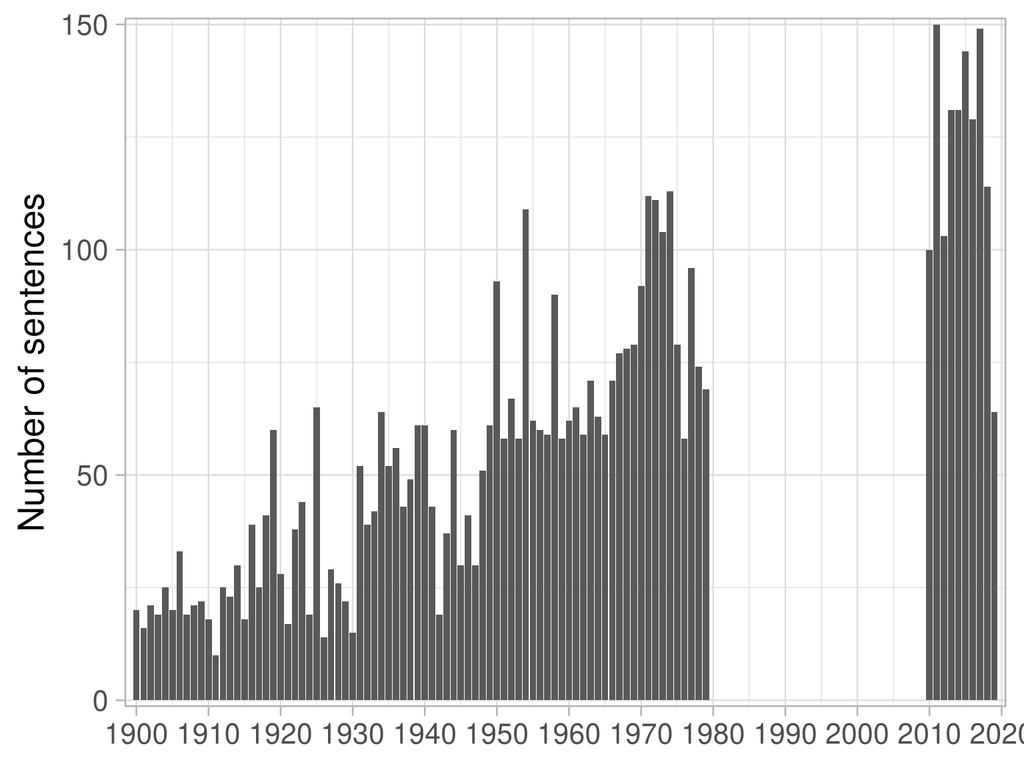

### Closest sentence from ‘rational’ and ‘rationality’ of the backbone community

| Sentence | Title | Year | Journal | Authors | Words Similarity |
| --- | --- | --- | --- | --- | --- |
| To be sure the development of character and activities forms the non-rational basis of economic rationality in the narrower sense; it forms the source of the ” higher ” wants which cannot themselves b… | [Wants and Activities in Marshall](http://www.jstor.org/stable/1883923) | 1931 | The Quarterly Journal of Economics | Talcott Parsons | 0.847 |
| Yet, if we accept the proposition that in the real world, business and consumers are often motivated by non-economic factors or rather recognize that “real” economic behavior is much more complex than… | [Environmental Control at the Crossroads](http://www.jstor.org/stable/4224063) | 1971 | Journal of Economic Issues | Harold Wolozin | 0.800 |
| Introduction The assumption that consumers are rational is one of the oldest and most controversial assumptions in economics. | [The Money Pump as a Measure of Revealed Preference Violations](http://www.jstor.org/stable/10.1086/665011) | 2011 | Journal of Political Economy | Federico Echenique, Sangmok Lee , Matthew Shum | 0.787 |
| It should be emphasized that the concept of economic rationality as efficiency in the use of given means to achieve given individual or group ends excludes a large part of the purposive life of men as… | [Economics, Political Science, and Education](http://www.jstor.org/stable/1818680) | 1944 | The American Economic Review | Frank H. Knight | 0.772 |
| To the extent that rationality for consumers may concur with rationality for agents more generally, a secondary theme that can be abstracted from revealed preference theory is the pursuit of the conce… | [Ordinal Preference and Rational Choice](http://www.jstor.org/stable/1913486) | 1973 | Econometrica | Hans G. Herzberger | 0.770 |
| The only source of bounded rational ity is the lack of knowledge of how the other household forms her decisions, which is a relevant piece of information to correctly forecast own future consumption i… | [Heterogeneity and learning with complete markets](http://www.jstor.org/stable/26704990) | 2017 | Economic Theory | Sergio Santoro | 0.769 |
| As in the “Dissenting View”, an alternative formulation of rationality is introduced by recognizing the existence of a positive minimaum sensibile for every consumer. | [Choice and Threshold: A Further Experiment in Spatial Duopoly](http://www.jstor.org/stable/2552088) | 1967 | Economica | Nicos E. Devletoglou, P. A. Demetriou | 0.768 |
| The nature of consumers’ bounded rationality is as follows. | [Unplanned Purchases and Retail Competition](http://www.jstor.org/stable/44250317) | 2017 | The American Economic Review | Justin P. Johnson | 0.767 |
| On the other hand, there is the consumer to emerge from surveys and experiments whose abilities, attention and/or willpower are limited; this 1 It is recognised that beyond consumption, bounded ration… | [The discourse of bounded rationality in academic and policy arenas: pathologising the errant consumer](http://www.jstor.org/stable/23602006) | 2013 | Cambridge Journal of Economics | Judith Mehta | 0.767 |
| In separating rational from irrational preference it is necessary to go behind the motivation of the consumer as expressed merely by his distribution of resources between different wants and into the … | [Rational and Irrational Consumer Preference](http://www.jstor.org/stable/2224960) | 1938 | The Economic Journal | J. K. Galbraith | 0.761 |
| I As Dr. Musgrave has pointed out, “the criterion of ‘rationality’ refers to the optimum satisfaction of given wants with scarce means.” | [The Planning Approach in Public Economy: Further Comment](http://www.jstor.org/stable/1882067) | 1941 | The Quarterly Journal of Economics | Herbert A. Simon | 0.760 |
| Comment: Models with Conventionally Rational Consumers. | [Competitive Framing](http://www.jstor.org/stable/43189676) | 2014 | American Economic Journal: Microeconomics | Ran Spiegler | 0.756 |
| I The criterion of “rationality” applied to the economic process refers to the optimum satisfaction of given wants with scarce means. | [The Planning Approach in Public Economy: A Reply](http://www.jstor.org/stable/1882066) | 1941 | The Quarterly Journal of Economics | Richard Abel Musgrave | 0.755 |
| If preference maximization can be thought of as a definition of consumer’s rationality, then the properties of the general equilibrium are robust to a significant dose of irrationality. | [General equilibrium without utility functions: how far to go?](http://www.jstor.org/stable/40864843) | 2010 | Economic Theory | Yves Balasko, Mich Tvede | 0.754 |
| The study of rational self-interest has long been the method of economic theorizing, and we shall follow it here. | [Speculation and the Carryover](http://www.jstor.org/stable/1882611) | 1936 | The Quarterly Journal of Economics | John Burr Williams | 0.753 |
| 6 In our conclusion, we discuss at length how our result is robust to alternative relaxations of the rational consumer assumption. | [LONG-LIVED CONSUMERS, INTERTEMPORAL BUNDLING AND COLLUSION](http://www.jstor.org/stable/41350247) | 2011 | The Journal of Industrial Economics | James D. Dana, Jr., Yuk-Fai Fong | 0.753 |
| Creative assumptions about technology, preferences, informa tion, and market frictions can offset the parsimony purchased with rational beliefs. | [Natural Expectations and Macroeconomic Fluctuations](http://www.jstor.org/stable/20799173) | 2010 | The Journal of Economic Perspectives | Andreas Fuster, David Laibson , Brock Mendel | 0.751 |
| There are countless acts and motives, entering into price formation, which have a bearing on the economic welfare of men, but which are quite lost sight of or are glossed over in merely pecuniary calc… | [Price Economics Versus Welfare Economics: Contemporary Opinion](http://www.jstor.org/stable/1803336) | 1920 | The American Economic Review | Frank A. Fetter | 0.750 |
| Finally, economics makes a definite assumption about the type of human behavior involved in the whole process- namely that it is, in limiting type, rational in the limited sense that, given the “end,”… | [Sociological Elements in Economic Thought](http://www.jstor.org/stable/1883862) | 1935 | The Quarterly Journal of Economics | Talcott Parsons | 0.746 |
| We assume consumers rationally solve the first problem but are boundedly rational when solving the second. | [Coarse Competitive Equilibrium and Extreme Prices](http://www.jstor.org/stable/24911324) | 2017 | The American Economic Review | Faruk Gul , Wolfgang Pesendorfer, Tomasz Strzalecki | 0.746 |

### Closest sentences of the backbone community’s centroid

| Sentence | Title | Year | Journal | Authors | Centroid Similarity |
| --- | --- | --- | --- | --- | --- |
| Yet, if we accept the proposition that in the real world, business and consumers are often motivated by non-economic factors or rather recognize that “real” economic behavior is much more complex than… | [Environmental Control at the Crossroads](http://www.jstor.org/stable/4224063) | 1971 | Journal of Economic Issues | Harold Wolozin | 0.8429165 |
| We are concerned here with the explanation of economic behavior and so are concerned with the utility function, and the behavior it implies, rather than with the structure or intuitive appeal of the a… | [Utility, Risk, and Linearity](http://www.jstor.org/stable/1826743) | 1959 | Journal of Political Economy | G. C. Archibald | 0.8328910 |
| This assumption is less justified than others; but it provides an introduction, at least, to the more complex problem raised by the presence of many consumers who evaluate the working of the economic … | [Marshallian External Economies and Optimal Tax-Subsidy Structure](http://www.jstor.org/stable/1909138) | 1971 | Econometrica | Masahiko Aoki | 0.8221980 |
| J some recent literature, could contribute to making the theory of utility and demand somewhat more specific and substantial than the general outline on which the theory is usually based today. | [Ragnar Frisch’s Contributions to Economics](http://www.jstor.org/stable/3439114) | 1969 | The Swedish Journal of Economics | Leif Johansen | 0.8211971 |
| A “range of choice” hypothesis is advanced and explained in terms of economic logic. | [Geography and Agricultural Income: An Additional Hypothesis](http://www.jstor.org/stable/1236893) | 1967 | Journal of Farm Economics | David W. Norman, Emery N. Castle | 0.8205268 |
| It is surpassingly convenient for the economist to assume that consumer tastes are “given” and that consumers are “rational,” but the economist chooses so to assume, and whether the resulting theory c… | [American Institutionalism: Premature Death, Permanent Resurrection](http://www.jstor.org/stable/4224689) | 1978 | Journal of Economic Issues | Philip A. Klein | 0.8185238 |
| Thirty or forty years ago the principle that consumers seek to maximize “utility” was generally accepted as furnishing an adequate explanation of their behavior for purposes of orthodox economic theor… | [Progress in Developing a Set of Principles in the Area of Consumer Behavior](http://www.jstor.org/stable/1234319) | 1954 | Journal of Farm Economics | Herman M. Southworth | 0.8165110 |
| There is, therefore, much to say for the view that, however fully the primal and causal nature of demand be recognized, it is yet true that, given man as he is, with his equipment of desires and taste… | [Proposed Modifications in Austrian Theory and Terminology](http://www.jstor.org/stable/1881982) | 1902 | The Quarterly Journal of Economics | H. J. Davenport | 0.8135138 |
| 1 deny that households act “rationally” since rational behavior is now taken to signify maximization of a consistent and transitive function.6 How can these extensive criticisms be reconciled with the… | [Irrational Behavior and Economic Theory](http://www.jstor.org/stable/1827018) | 1962 | Journal of Political Economy | Gary S. Becker | 0.8120541 |
| The position taken in the present paper is that it may be rational for individuals to take into account the dispersion of utility values. | [A Contribution to the Pathology of Gambling](http://www.jstor.org/stable/41796076) | 1960 | Zeitschrift für Nationalökonomie / Journal of Economics | Richard E. Quandt | 0.8088212 |
| It is surely more than merely a significant coincidence that the economics which lays almost exclusive emphasis on production as an increase in the sum total of the means of gratification should be al… | [Economics and Modern Psycholoy: I](http://www.jstor.org/stable/1820785) | 1918 | Journal of Political Economy | J. M. Clark | 0.8073843 |
| There are countless acts and motives, entering into price formation, which have a bearing on the economic welfare of men, but which are quite lost sight of or are glossed over in merely pecuniary calc… | [Price Economics Versus Welfare Economics: Contemporary Opinion](http://www.jstor.org/stable/1803336) | 1920 | The American Economic Review | Frank A. Fetter | 0.8067304 |
| Moreover, it is clear that the current tendency to abandon the crude hedonistic conception of economic motive, and to recognize that man’s economic action is, in part, habitual if not instinctive, alt… | [The Demand and Supply Concepts: An Introduction to the Study of Market Price](http://www.jstor.org/stable/1819697) | 1906 | Journal of Political Economy | Robert H. Hoxie | 0.8059168 |
| When economic psychology is given the above interpretation, and the instrumental, non-ontological character of desires and motives as used m economics is sufficiently emphasized, there can be no objec… | [Economic Psychology and the Value Problem](http://www.jstor.org/stable/1882434) | 1925 | The Quarterly Journal of Economics | Frank H. Knight | 0.8037137 |
| As in the “Dissenting View”, an alternative formulation of rationality is introduced by recognizing the existence of a positive minimaum sensibile for every consumer. | [Choice and Threshold: A Further Experiment in Spatial Duopoly](http://www.jstor.org/stable/2552088) | 1967 | Economica | Nicos E. Devletoglou, P. A. Demetriou | 0.8033026 |

### Closest sentences of each kmean cluster’s centroid composing the backbone community

#### Top terms 4_1: economic_motive, economic_motives, motives, motive, desires (1900-1919)

| Sentence | Title | Year | Journal | Authors | Distance to Centroid |
| --- | --- | --- | --- | --- | --- |
| The present writer believes that grounds will be shown for a further inquiry into the psychology of motives in the interests of economics, and perhaps some irrelevant points of the criticism can be el… | [The Relations of Recent Psychological Developments to Economic Theory](http://www.jstor.org/stable/1885945) | 1919 | The Quarterly Journal of Economics | Z. Clark Dickinson | 7.102870 |
| All this gentle parody in motive theorizing continued contemporaneously with the output of the rich literature of social and behavioristic psychology which was almost entirely addressed to this very p… | [Motives in Economic Life](http://www.jstor.org/stable/1814642) | 1918 | The American Economic Review | Carleton H. Parker | 7.453586 |
| Man’s nature and the doctrine of economic wants. | [The Fundamental Economic Principle](http://www.jstor.org/stable/1884895) | 1901 | The Quarterly Journal of Economics | Charles A. Tuttle | 7.665312 |
| MOTIVES IN ECONOMIC LIFE By CARLETON H. PARKER The University of Washington The first quarter of this century is breaking up in a riot of economic irrationalism. | [Motives in Economic Life](http://www.jstor.org/stable/1814642) | 1918 | The American Economic Review | Carleton H. Parker | 7.725804 |
| The determining desires are mixed as regards, on the one hand, egoism 1 The analogy worked out in this paper was roughly suggested in my note A Parallel between Economical and Political Theory in the … | [The Unity of Political and Economic Science](http://www.jstor.org/stable/2220810) | 1906 | The Economic Journal | A. C. Pigou | 7.727103 |

#### Top terms 4_5: delivery, commodities, manufacture, wheat, marginal_utility (1900-1919)

| Sentence | Title | Year | Journal | Authors | Distance to Centroid |
| --- | --- | --- | --- | --- | --- |
| We merely note, for future purposes, that mlarginal utility is here made to depend upon supply as well as upon want: the redness of the apple, being an aesthetic fact, may be assumed to have no bearin… | [A New Text: Seligman: “Social Value”](http://www.jstor.org/stable/1817617) | 1906 | Journal of Political Economy | H. J. Davenport | 7.537999 |
| It is the men who are hesitating whether they should or should not purchase, whether they should or should not dispose of their goods, or whether lastly they should or should not continue to render th… | [Economic Theory and Fiscal Policy](http://www.jstor.org/stable/2221360) | 1904 | The Economic Journal | L. L. Price | 7.790806 |
| When we speak of the value of an article in the economic sense, we think not of its usefulness in general, but of the utility of a definite quantity ; and we think not of the total utility of this qua… | [Social Elements in the Theory of Value](http://www.jstor.org/stable/1885195) | 1901 | The Quarterly Journal of Economics | Edwin R. A. Seligman | 7.806436 |
| The forces which influence and determine both supply and demand for a good in any market, then, are to be found in the putative psychological attitude and proprietary condition of the individuals who … | [The Demand and Supply Concepts: An Introduction to the Study of Market Price](http://www.jstor.org/stable/1819697) | 1906 | Journal of Political Economy | Robert H. Hoxie | 7.837807 |
| The “commodity theory,” in its fullest presentation, relied on a cost of production theory;’ the ” quantity theory,” in its most detailed statistical proof, held that marginal utility could not be app… | [Social Value and the Theory of Money](http://www.jstor.org/stable/1823155) | 1917 | Journal of Political Economy | Walter Stewart | 7.888680 |

#### Top terms 4_23: satisfaction, satisfactions, hedonism, human_motives, desires (1920-1939)

| Sentence | Title | Year | Journal | Authors | Distance to Centroid |
| --- | --- | --- | --- | --- | --- |
| It has been shown that if we look at human action from the “subjective” point of view of the means-end relationship, economic theory occupies an intermediate position in the chain from ultimate means … | [Sociological Elements in Economic Thought: II. The Analytical Factor View^1](http://www.jstor.org/stable/1885403) | 1935 | The Quarterly Journal of Economics | Talcott Parsons | 6.919044 |
| It may be remarked in passing that the effective motive of tion of the materialistic, or economic, or biological interpretation of conduct is that when men must choose between some “real need” and a s… | [Ethics and the Economic Interpretation](http://www.jstor.org/stable/1886033) | 1922 | The Quarterly Journal of Economics | Frank H. Knight | 7.179259 |
| Economic wants may be serious, frivolous, or even positively pernicious, but the objects of these wants all alike possess utility in the economic sense.26 If the immediate satisfaction to an individua… | [The Utility Concept in Value Theory and Its Critics](http://www.jstor.org/stable/1822261) | 1925 | Journal of Political Economy | Jacob Viner | 7.304805 |
| When economic psychology is given the above interpretation, and the instrumental, non-ontological character of desires and motives as used m economics is sufficiently emphasized, there can be no objec… | [Economic Psychology and the Value Problem](http://www.jstor.org/stable/1882434) | 1925 | The Quarterly Journal of Economics | Frank H. Knight | 7.445808 |
| In economics, again, there are profound psychological problems relating to human motives in production which are of the greatest moment to our social and industrial system, but their intricacies must … | [The Psychology Course in Business Education](http://www.jstor.org/stable/1824490) | 1922 | Journal of Political Economy | Z. Clark Dickinson | 7.476055 |

#### Top terms 4_46: economic_motivation, economic_motive, economic_motives, satisfaction, motive (1940-1949)

| Sentence | Title | Year | Journal | Authors | Distance to Centroid |
| --- | --- | --- | --- | --- | --- |
| II Idealistic opponents of hedonism have attacked the “economic man” assumption on the grounds of its apparent crude materialism, which, in their view, gives only a distorted and unreal picture of hum… | [Rational Human Conduct and Modern Industrial Society](http://www.jstor.org/stable/1052713) | 1943 | Southern Economic Journal | Karl W. Kapp | 7.381906 |
| Surely the truth is rather that in the-breasts of some economic subjects the two demands are mutually sympathetic and in the breasts of other economic subjects mutually antagonistic, so that what happ… | [The Inter-relations of Shifts in Demand](http://www.jstor.org/stable/2296014) | 1944 | The Review of Economic Studies | D. H. Robinson, J. R. Hicks , Oscar Lange | 7.470731 |
| While strongly emphasizing the role of the state and the community, and the immensely strong social disposition of man that originates and maintains those institutions, Knies especially inveighed agai… | [The Tasks of Economic History](http://www.jstor.org/stable/2113778) | 1941 | The Journal of Economic History | Edwin F. Gay | 7.553735 |
| We have noted that this basic concept identifies the subject-matter of economics, not with an objectively verifiable physical object or the behavior of physical individuals, but with a relation betwee… | [The Impossibility of a Theoretical Science of Economic Dynamics](http://www.jstor.org/stable/1883027) | 1941 | The Quarterly Journal of Economics | F. S. C. Northrop | 7.619993 |
| Briefly, modern economics seems to be bent to the view that “reason becomes a shame, beneficence a worry.” | [The Present Position of Economics](http://www.jstor.org/stable/1818675) | 1944 | The American Economic Review | Arthur Salz | 7.779708 |

#### Top terms 4_53: diminishing_marginal, interpersonal, interpersonal_comparisons, marginal_utility, utility_theory (1950-1959)

| Sentence | Title | Year | Journal | Authors | Distance to Centroid |
| --- | --- | --- | --- | --- | --- |
| NOVEMBER The Conception of Jevons’s Utility Theory By J. | [The Conception of Jevon’s Utility Theory](http://www.jstor.org/stable/2550585) | 1953 | Economica | J. A. La Nauze | 6.621007 |
| William Baumol’s recent note in this Journal provides an excellent occasion for seeking to repair in some measure our earlier failure by an attempt to make clear the grounds on which the acceptance or… | [The Expected-Utility Hypothesis and the Measurability of Utility](http://www.jstor.org/stable/1825271) | 1952 | Journal of Political Economy | Milton Friedman, L. J. Savage | 6.791774 |
| That, however, of couirse implies the making of inter-personal comparisons of utility, and that in turn-though Little, as I noted in my previous essay, does not seem to realise it 1-implies, so I stil… | [Utility and All What?](http://www.jstor.org/stable/2228037) | 1954 | The Economic Journal | D. H. Robertson | 7.224977 |
| At one extreme stands the view, perhaps best associated with the founders of utility theory, that the utility of each product depends solely on consump- * I am very grateful to A. M. Okun, J. Tobin, a… | [On the Independence of Utility of Product Groups](http://www.jstor.org/stable/1926511) | 1956 | The Review of Economics and Statistics | G. Warren Nutter | 7.297122 |
| The flood of articles that followed includes discussions of cardinal and ordinal utility; the measurability of utility and its relation to interpersonal comparisons; compensation,45 potential or actua… | [On Some Fashions in Economic Theory](http://www.jstor.org/stable/138557) | 1954 | The Canadian Journal of Economics and Political Science / Revue canadienne d’Economique et de Science politique | G. A. Elliott | 7.352189 |

#### Top terms 4_75: consumer’s, consumer, consumer_demand, demand_curves, demand_theory (1960-1969)

| Sentence | Title | Year | Journal | Authors | Distance to Centroid |
| --- | --- | --- | --- | --- | --- |
| The position taken in the present paper is that it may be rational for individuals to take into account the dispersion of utility values. | [A Contribution to the Pathology of Gambling](http://www.jstor.org/stable/41796076) | 1960 | Zeitschrift für Nationalökonomie / Journal of Economics | Richard E. Quandt | 7.310515 |
| Watson, as well as other authors of intermediate theory texts, face the problem of incorporating the basic concepts of substitutability and complementarity into the theory of demand. | [Substitution and Values of Elasticities](http://www.jstor.org/stable/1814562) | 1965 | The American Economic Review | John M. Kuhlman , Russell G. Thompson | 7.376130 |
| The opinion of Tinbergen and Bos that maximization of utility should be rated higher than maximization of consumption, which again should be rated higher than maximization of income is the expression … | [On the Optimum Rate of Savings](http://www.jstor.org/stable/40436772) | 1963 | Weltwirtschaftliches Archiv | Arnold Heertje | 7.455036 |
| In this theory utility does not necessarily depend on the quantities consumed themselves; it may also depend on certain intermediate entities which themselves are functions of the quantities consumed,… | [The Present State of Consumption Theory](http://www.jstor.org/stable/1911816) | 1961 | Econometrica | H. S. Houthakker | 7.552984 |
| The scope of the paper is restricted to an elucidation of the meaning and the implication of the superscription which serves here as our text.3 Samuelson in his 1938 article re-opened the whole issue … | [Choice and Order: Or First Things First](http://www.jstor.org/stable/2551352) | 1964 | Economica | D. Banerjee | 7.630427 |

#### Top terms 4_81: consumer, consumer’s, demand_theory, consumer_choice, utility_function (1970-1979)

| Sentence | Title | Year | Journal | Authors | Distance to Centroid |
| --- | --- | --- | --- | --- | --- |
| To the extent that rationality for consumers may concur with rationality for agents more generally, a secondary theme that can be abstracted from revealed preference theory is the pursuit of the conce… | [Ordinal Preference and Rational Choice](http://www.jstor.org/stable/1913486) | 1973 | Econometrica | Hans G. Herzberger | 7.586889 |
| Each consumer is assumed to satisfy his preference subject to his wealth constraint on the supposition that no other agents will change their actions in response to his choice. | [Optimal Tax-Subsidy System for an Economy with Marshallian Externalities](http://www.jstor.org/stable/1911213) | 1977 | Econometrica | Hiroaki Osana | 7.598407 |
| It is surpassingly convenient for the economist to assume that consumer tastes are “given” and that consumers are “rational,” but the economist chooses so to assume, and whether the resulting theory c… | [American Institutionalism: Premature Death, Permanent Resurrection](http://www.jstor.org/stable/4224689) | 1978 | Journal of Economic Issues | Philip A. Klein | 7.632325 |
| 21 As noted earlier, the hypothesis that a consumer, who is deciding upon the optimal levels of consumption and labor supply, maximizes the expected value of a utility function of wealth and labor, in… | [A Disaggregate Analysis of Consumer Choice under Uncertainty](http://www.jstor.org/stable/1911331) | 1975 | Econometrica | L. Epstein | 7.753175 |
| We now show that utility theory partly supports some of the empirical approaches described but also throws new light on their interpretation. | [Surveys in Applied Economics: Models of Consumer Behaviour](http://www.jstor.org/stable/2231303) | 1972 | The Economic Journal | Alan Brown , Angus Deaton | 7.813152 |

#### Top terms 4_145: inattention, rational_inattention, rational_consumers, rational_consumer, inattentive (2010-2019)

| Sentence | Title | Year | Journal | Authors | Distance to Centroid |
| --- | --- | --- | --- | --- | --- |
| In the second step, we examine whether the LCPIH holds for rational consumers whose behavior coincides with the LCPIH assumptions. | [RATIONAL CONSUMERS](http://www.jstor.org/stable/44075345) | 2016 | International Economic Review | Kohei Kubota , Mototsugu Fukushige | 6.550099 |
| With the right interde pendence of preferences and uninformed consumers, it may be possible to have a cold-opening premium consistent with fully rational agents. | [To Review or Not to Review? Limited Strategic Thinking at the Movie Box Office](http://www.jstor.org/stable/23249431) | 2012 | American Economic Journal: Microeconomics | Alexander L. Brown, Colin F. Camerer , Dan Lovallo | 6.880744 |
| 12 Lazear’s model assumes that consumers are myopic. | [DYNAMIC COMPETITION WITH RANDOM DEMAND AND COSTLESS SEARCH: A THEORY OF PRICE POSTING](http://www.jstor.org/stable/41493848) | 2012 | Econometrica | Raymond Deneckere, James Peck | 6.996244 |
| Econometric analysis will determine whether observed consumer choices can be rationalized within the framework of rational decision making that we develop and estimate in this article. | [PRODUCT CHOICE UNDER GOVERNMENT REGULATION: THE CASE OF CHILE’S PRIVATIZED PENSION SYSTEM](http://www.jstor.org/stable/45018821) | 2018 | International Economic Review | Elena Krasnokutskaya, Yiyang Li , Petra E. Todd | 7.068042 |
| If consumers form consideration sets, the observed choice behavior may actually fail to satisfy GARP, although the choices are still optimal given her consideration sets. | [Revealed Preference with Limited Consideration](http://www.jstor.org/stable/26528468) | 2018 | American Economic Journal: Microeconomics | Thomas Demuynck, Christian Seel | 7.083174 |

### Top articles (most sentences) of the backbone cluster

| Title | Year | Journal | Authors | Number sentences | Words Similarity |
| --- | --- | --- | --- | --- | --- |
| [Consideration Sets and Competitive Marketing](http://www.jstor.org/stable/23015854) | 2011 | The Review of Economic Studies | KFIR ELIAZ , RAN SPIEGLER | 35 | 0.638 |
| [The Relations of Recent Psychological Developments to Economic Theory](http://www.jstor.org/stable/1885945) | 1919 | The Quarterly Journal of Economics | Z. Clark Dickinson | 20 | 0.637 |
| [Wants and Activities in Marshall](http://www.jstor.org/stable/1883923) | 1931 | The Quarterly Journal of Economics | Talcott Parsons | 20 | 0.636 |
| [Rational Inattention and Energy Efficiency](http://www.jstor.org/stable/10.1086/676964) | 2014 | The Journal of Law & Economics | James M. Sallee | 17 | 0.627 |
| [Sociological Elements in Economic Thought](http://www.jstor.org/stable/1883862) | 1935 | The Quarterly Journal of Economics | Talcott Parsons | 16 | 0.634 |
| [The Motivation of Economic Activities](http://www.jstor.org/stable/137203) | 1940 | The Canadian Journal of Economics and Political Science / Revue canadienne d’Economique et de Science politique | Talcott Parsons | 16 | 0.637 |
| [Human Nature in Economic Theory](http://www.jstor.org/stable/1822708) | 1922 | Journal of Political Economy | Rexford G. Tugwell | 15 | 0.637 |
| [The Ethics of Competition](http://www.jstor.org/stable/1884053) | 1923 | The Quarterly Journal of Economics | Frank H. Knight | 15 | 0.618 |
| [Thoughts on Perusal of Wesley Mitchell’s Collected Essays](http://www.jstor.org/stable/1829688) | 1939 | Journal of Political Economy | A. B. Wolfe | 15 | 0.627 |
| [The General Incompatibility of the Traditional Consumer Equilibrium with Economic Rationality–An Exploratory Analysis](http://www.jstor.org/stable/2662552) | 1966 | Oxford Economic Papers | Ralph Anspach | 15 | 0.643 |
| [Ethics and the Economic Interpretation](http://www.jstor.org/stable/1886033) | 1922 | The Quarterly Journal of Economics | Frank H. Knight | 14 | 0.611 |
| [Individual and Collective Wants](http://www.jstor.org/stable/1825025) | 1948 | Journal of Political Economy | Theo Surányi-Unger | 14 | 0.608 |
| [A MODEL OF FOCUSING IN ECONOMIC CHOICE](http://www.jstor.org/stable/26372494) | 2013 | The Quarterly Journal of Economics | Botond Kőszegi, Adam Szeidl | 14 | 0.602 |
| [The discourse of bounded rationality in academic and policy arenas: pathologising the errant consumer](http://www.jstor.org/stable/23602006) | 2013 | Cambridge Journal of Economics | Judith Mehta | 13 | 0.645 |
| [The Scope and Method of Political Economy in the Light of the “Marginal” Theory of Value and of Distribution](http://www.jstor.org/stable/2221810) | 1914 | The Economic Journal | P. H. Wicksteed | 12 | 0.628 |

### Top articles (most sentences) of the cluster for each time window

#### Top articles for 4_1: economic_motive, economic_motives, motives, motive, desires (1900-1919)

| Title | Year | Journal | Authors | Number sentences | Words Similarity |
| --- | --- | --- | --- | --- | --- |
| [The Relations of Recent Psychological Developments to Economic Theory](http://www.jstor.org/stable/1885945) | 1919 | The Quarterly Journal of Economics | Z. Clark Dickinson | 17 | 0.636 |
| [The Role of Money in Economic Theory](http://www.jstor.org/stable/1803798) | 1916 | The American Economic Review | Wesley C. Mitchell | 8 | 0.656 |
| [The Scope and Method of Political Economy in the Light of the “Marginal” Theory of Value and of Distribution](http://www.jstor.org/stable/2221810) | 1914 | The Economic Journal | P. H. Wicksteed | 6 | 0.628 |
| [Some Problems of Logical Method in Political Economy](http://www.jstor.org/stable/1819612) | 1917 | Journal of Political Economy | J. Viner | 5 | 0.657 |
| [The Price-System and Social Policy](http://www.jstor.org/stable/1820786) | 1918 | Journal of Political Economy | Walton H. Hamilton | 5 | 0.650 |
| [Motives in Economic Life](http://www.jstor.org/stable/1814642) | 1918 | The American Economic Review | Carleton H. Parker | 5 | 0.676 |
| [The Unity of Political and Economic Science](http://www.jstor.org/stable/2220810) | 1906 | The Economic Journal | A. C. Pigou | 4 | 0.632 |
| [Some Considerations About Interest](http://www.jstor.org/stable/2221207) | 1908 | The Economic Journal | E. C. K. Gonner | 4 | 0.611 |
| [The Rationality of Economic Activity: I](http://www.jstor.org/stable/1829775) | 1910 | Journal of Political Economy | Wesley C. Mitchell | 4 | 0.628 |
| [Fetter’s “Economic Principles”](http://www.jstor.org/stable/1820036) | 1916 | Journal of Political Economy | H. J. Davenport | 4 | 0.634 |

#### Top articles for 4_5: delivery, commodities, manufacture, wheat, marginal_utility (1900-1919)

| Title | Year | Journal | Authors | Number sentences | Words Similarity |
| --- | --- | --- | --- | --- | --- |
| [The Demand and Supply Concepts: An Introduction to the Study of Market Price](http://www.jstor.org/stable/1817324) | 1906 | Journal of Political Economy | Robert F. Hoxie | 8 | 0.613 |
| [Marginal Utility and Exchange Value](http://www.jstor.org/stable/1819501) | 1905 | Journal of Political Economy | R. S. Padan | 7 | 0.610 |
| [The Demand and Supply Concepts: An Introduction to the Study of Market Price](http://www.jstor.org/stable/1819697) | 1906 | Journal of Political Economy | Robert H. Hoxie | 7 | 0.625 |
| [Proposed Modifications in Austrian Theory and Terminology](http://www.jstor.org/stable/1881982) | 1902 | The Quarterly Journal of Economics | H. J. Davenport | 6 | 0.644 |
| [The Theory of Distribution](http://www.jstor.org/stable/1882785) | 1904 | The Quarterly Journal of Economics | F. Y. Edgeworth | 6 | 0.639 |
| [The Scope and Method of Political Economy in the Light of the “Marginal” Theory of Value and of Distribution](http://www.jstor.org/stable/2221810) | 1914 | The Economic Journal | P. H. Wicksteed | 6 | 0.628 |
| [Economic Theory and Fiscal Policy](http://www.jstor.org/stable/2221360) | 1904 | The Economic Journal | L. L. Price | 5 | 0.652 |
| [The Passing of the Old Rent Concept](http://www.jstor.org/stable/1885199) | 1901 | The Quarterly Journal of Economics | Frank A. Fetter | 4 | 0.650 |
| [Böhm-Bawerk on Rae](http://www.jstor.org/stable/1881983) | 1902 | The Quarterly Journal of Economics | Charles W. Mixter | 4 | 0.620 |
| [The Source of Financial Power](http://www.jstor.org/stable/1819500) | 1905 | Journal of Political Economy | W. G. Langworthy Taylor | 4 | 0.608 |

#### Top articles for 4_23: satisfaction, satisfactions, hedonism, human_motives, desires (1920-1939)

| Title | Year | Journal | Authors | Number sentences | Words Similarity |
| --- | --- | --- | --- | --- | --- |
| [Wants and Activities in Marshall](http://www.jstor.org/stable/1883923) | 1931 | The Quarterly Journal of Economics | Talcott Parsons | 20 | 0.636 |
| [Sociological Elements in Economic Thought](http://www.jstor.org/stable/1883862) | 1935 | The Quarterly Journal of Economics | Talcott Parsons | 16 | 0.634 |
| [Human Nature in Economic Theory](http://www.jstor.org/stable/1822708) | 1922 | Journal of Political Economy | Rexford G. Tugwell | 15 | 0.637 |
| [The Ethics of Competition](http://www.jstor.org/stable/1884053) | 1923 | The Quarterly Journal of Economics | Frank H. Knight | 15 | 0.618 |
| [Thoughts on Perusal of Wesley Mitchell’s Collected Essays](http://www.jstor.org/stable/1829688) | 1939 | Journal of Political Economy | A. B. Wolfe | 15 | 0.627 |
| [Ethics and the Economic Interpretation](http://www.jstor.org/stable/1886033) | 1922 | The Quarterly Journal of Economics | Frank H. Knight | 14 | 0.611 |
| [Demand Functions and Utility Functions: A Critical Examination of their Meaning](http://www.jstor.org/stable/1907950) | 1934 | Econometrica | E. H. Phelps Brown | 11 | 0.612 |
| [Economic Psychology and the Value Problem](http://www.jstor.org/stable/1882434) | 1925 | The Quarterly Journal of Economics | Frank H. Knight | 10 | 0.622 |
| [Some Reflections on “The Nature and Significance of Economics”](http://www.jstor.org/stable/1882825) | 1934 | The Quarterly Journal of Economics | Talcott Parsons | 10 | 0.633 |
| [The Interpretation of Subjective Value Theory in the Writings of the Austrian Economists](http://www.jstor.org/stable/2967481) | 1934 | The Review of Economic Studies | Alan R. Sweezy | 10 | 0.623 |

#### Top articles for 4_46: economic_motivation, economic_motive, economic_motives, satisfaction, motive (1940-1949)

| Title | Year | Journal | Authors | Number sentences | Words Similarity |
| --- | --- | --- | --- | --- | --- |
| [The Motivation of Economic Activities](http://www.jstor.org/stable/137203) | 1940 | The Canadian Journal of Economics and Political Science / Revue canadienne d’Economique et de Science politique | Talcott Parsons | 16 | 0.637 |
| [Individual and Collective Wants](http://www.jstor.org/stable/1825025) | 1948 | Journal of Political Economy | Theo Surányi-Unger | 14 | 0.608 |
| [Adam Smith and the Economic Man](http://www.jstor.org/stable/1826047) | 1948 | Journal of Political Economy | William D. Grampp | 11 | 0.614 |
| [The Welfare Economics of Heinrich Pesch](http://www.jstor.org/stable/1882259) | 1949 | The Quarterly Journal of Economics | Richard E. Mulcahy, S.J. | 10 | 0.650 |
| [Professor Parsons on Economic Motivation](http://www.jstor.org/stable/136912) | 1940 | The Canadian Journal of Economics and Political Science / Revue canadienne d’Economique et de Science politique | Frank H. Knight | 9 | 0.627 |
| [Adam Smith’s Empiricism and the Law of Nature: I](http://www.jstor.org/stable/1825483) | 1940 | Journal of Political Economy | Henry J. Bittermann | 6 | 0.608 |
| [The Impossibility of a Theoretical Science of Economic Dynamics](http://www.jstor.org/stable/1883027) | 1941 | The Quarterly Journal of Economics | F. S. C. Northrop | 6 | 0.633 |
| [Rational Human Conduct and Modern Industrial Society](http://www.jstor.org/stable/1052713) | 1943 | Southern Economic Journal | Karl W. Kapp | 6 | 0.637 |
| [Realism and Relevance in the Theory of Demand](http://www.jstor.org/stable/1826961) | 1944 | Journal of Political Economy | Frank H. Knight | 6 | 0.634 |
| [The Economic Motive in Politics](http://www.jstor.org/stable/2590472) | 1946 | The Economic History Review | F. M. Powicke | 6 | 0.656 |

#### Top articles for 4_53: diminishing_marginal, interpersonal, interpersonal_comparisons, marginal_utility, utility_theory (1950-1959)

| Title | Year | Journal | Authors | Number sentences | Words Similarity |
| --- | --- | --- | --- | --- | --- |
| [The Development of Utility Theory. I](http://www.jstor.org/stable/1828885) | 1950 | Journal of Political Economy | George J. Stigler | 11 | 0.613 |
| [Choice, Expectations and Measurability](http://www.jstor.org/stable/1881875) | 1954 | The Quarterly Journal of Economics | Nicholas Georgescu-Roegen | 11 | 0.617 |
| [Concerning Utility](http://www.jstor.org/stable/2601492) | 1954 | Economica | Charles Kennedy | 9 | 0.605 |
| [The Development of Utility Theory. II](http://www.jstor.org/stable/1825710) | 1950 | Journal of Political Economy | George J. Stigler | 8 | 0.619 |
| [A Probabilistic Theory of Consumer Behavior](http://www.jstor.org/stable/1881863) | 1956 | The Quarterly Journal of Economics | Richard E. Quandt | 8 | 0.601 |
| [The Measurement of Real Income](http://www.jstor.org/stable/2662090) | 1958 | Oxford Economic Papers | J. R. Hicks | 8 | 0.610 |
| [Utility and the “Ordinalist Fallacy”](http://www.jstor.org/stable/2295985) | 1958 | The Review of Economic Studies | W. E. Armstrong | 8 | 0.597 |
| [A Difficulty in the Concept of Social Welfare](http://www.jstor.org/stable/1828886) | 1950 | Journal of Political Economy | Kenneth J. Arrow | 7 | 0.630 |
| [The Expected-Utility Hypothesis and the Measurability of Utility](http://www.jstor.org/stable/1825271) | 1952 | Journal of Political Economy | Milton Friedman, L. J. Savage | 6 | 0.608 |
| [On Descriptions of Consumers’ Behaviour](http://www.jstor.org/stable/2551324) | 1954 | Economica | V. C. Walsh | 6 | 0.607 |

#### Top articles for 4_75: consumer’s, consumer, consumer_demand, demand_curves, demand_theory (1960-1969)

| Title | Year | Journal | Authors | Number sentences | Words Similarity |
| --- | --- | --- | --- | --- | --- |
| [The General Incompatibility of the Traditional Consumer Equilibrium with Economic Rationality–An Exploratory Analysis](http://www.jstor.org/stable/2662552) | 1966 | Oxford Economic Papers | Ralph Anspach | 15 | 0.643 |
| [The Present State of Consumption Theory](http://www.jstor.org/stable/1911816) | 1961 | Econometrica | H. S. Houthakker | 10 | 0.602 |
| [Methodenstreit over Demand Curves](http://www.jstor.org/stable/1827204) | 1960 | Journal of Political Economy | Leland B. Yeager | 9 | 0.606 |
| [On Merit Goods](http://www.jstor.org/stable/40909986) | 1966 | FinanzArchiv / Public Finance Analysis | John G. Head | 9 | 0.626 |
| [Irrational Behavior and Economic Theory](http://www.jstor.org/stable/1827018) | 1962 | Journal of Political Economy | Gary S. Becker | 7 | 0.652 |
| [On Some Applications of the Utility Tree](http://www.jstor.org/stable/1055960) | 1963 | Southern Economic Journal | Eirik G. Furubotn | 7 | 0.597 |
| [Merit Goods Revisited](http://www.jstor.org/stable/40910613) | 1969 | FinanzArchiv / Public Finance Analysis | John G. Head | 7 | 0.611 |
| [A Survey of Welfare Economics, 1939-59](http://www.jstor.org/stable/2228726) | 1960 | The Economic Journal | E. J. Mishan | 5 | 0.605 |
| [On the Optimum Rate of Savings](http://www.jstor.org/stable/40436772) | 1963 | Weltwirtschaftliches Archiv | Arnold Heertje | 5 | 0.613 |
| [An Introduction to Bernoullian Utility Theory: II. Interpretation, Evaluation and Application; A Critical Survey](http://www.jstor.org/stable/3439377) | 1967 | The Swedish Journal of Economics | Niels Erik Jensen | 5 | 0.608 |

#### Top articles for 4_81: consumer, consumer’s, demand_theory, consumer_choice, utility_function (1970-1979)

| Title | Year | Journal | Authors | Number sentences | Words Similarity |
| --- | --- | --- | --- | --- | --- |
| [The Interrelation between Central Priorities and Individual Preferences in a Socialist Planned Economy](http://www.jstor.org/stable/4379466) | 1974 | Eastern European Economics | Josef Adamíček, Marian Sling | 9 | 0.624 |
| [Surveys in Applied Economics: Models of Consumer Behaviour](http://www.jstor.org/stable/2231303) | 1972 | The Economic Journal | Alan Brown , Angus Deaton | 6 | 0.609 |
| [Consumer Behavior Versus Economic Theory](http://www.jstor.org/stable/40723430) | 1974 | Recherches Économiques de Louvain / Louvain Economic Review | Richard SCHMALENSEE | 6 | 0.621 |
| [A Curmudgeon’s Guide to Microeconomics](http://www.jstor.org/stable/2720472) | 1970 | Journal of Economic Literature | Martin Shubik | 5 | 0.606 |
| [The Properties and Relevancy of Merit Goods](http://www.jstor.org/stable/40910860) | 1971 | FinanzArchiv / Public Finance Analysis | Allan G. Pulsipher | 5 | 0.603 |
| [A Contribution to the New Theory of Demand: A Rehabilitation of the Giffen Good](http://www.jstor.org/stable/133523) | 1971 | The Canadian Journal of Economics / Revue canadienne d’Economique | Richard G. Lipsey, Gideon Rosenbluth | 5 | 0.600 |
| [Macroeconomic Models and the Demand for Money under Market Disequilibrium](http://www.jstor.org/stable/1991436) | 1971 | Journal of Money, Credit and Banking | Donald P. Tucker | 4 | 0.610 |
| [On the New Theory of Consumer Behavior](http://www.jstor.org/stable/3439147) | 1973 | The Swedish Journal of Economics | Robert T. Michael, Gary S. Becker | 4 | 0.626 |
| [A New Approach to the Theory of Consumer Behavior](http://www.jstor.org/stable/25602912) | 1973 | The American Economist | Tibor Scitovsky | 4 | 0.627 |
| [Behaviour and the Concept of Preference](http://www.jstor.org/stable/2552796) | 1973 | Economica | Amartya Sen | 4 | 0.610 |

#### Top articles for 4_145: inattention, rational_inattention, rational_consumers, rational_consumer, inattentive (2010-2019)

| Title | Year | Journal | Authors | Number sentences | Words Similarity |
| --- | --- | --- | --- | --- | --- |
| [Consideration Sets and Competitive Marketing](http://www.jstor.org/stable/23015854) | 2011 | The Review of Economic Studies | KFIR ELIAZ , RAN SPIEGLER | 35 | 0.638 |
| [Rational Inattention and Energy Efficiency](http://www.jstor.org/stable/10.1086/676964) | 2014 | The Journal of Law & Economics | James M. Sallee | 17 | 0.627 |
| [A MODEL OF FOCUSING IN ECONOMIC CHOICE](http://www.jstor.org/stable/26372494) | 2013 | The Quarterly Journal of Economics | Botond Kőszegi, Adam Szeidl | 14 | 0.602 |
| [The discourse of bounded rationality in academic and policy arenas: pathologising the errant consumer](http://www.jstor.org/stable/23602006) | 2013 | Cambridge Journal of Economics | Judith Mehta | 13 | 0.645 |
| [Business cycle amplification with heterogeneous expectations](http://www.jstor.org/stable/41485844) | 2011 | Economic Theory | William A. Branch, Bruce McGough | 11 | 0.638 |
| [Overconfident Consumers in the Marketplace](http://www.jstor.org/stable/43611009) | 2015 | The Journal of Economic Perspectives | Michael D. Grubb | 10 | 0.626 |
| [The Social Cost of Near-Rational Investment](http://www.jstor.org/stable/44251587) | 2017 | The American Economic Review | Tarek A. Hassan , Thomas M. Mertens | 10 | 0.645 |
| [Spurious Complexity and Common Standards in Markets for Consumer Goods](http://www.jstor.org/stable/41426532) | 2012 | Economica | Alexia Gaudeul, Robert Sugden | 9 | 0.643 |
| [Loss Aversion and Consumption Choice: Theory and Experimental Evidence](http://www.jstor.org/stable/24466990) | 2015 | American Economic Journal: Microeconomics | Heiko Karle , Georg Kirchsteiger, Martin Peitz | 9 | 0.639 |
| [RATIONAL CONSUMERS](http://www.jstor.org/stable/44075345) | 2016 | International Economic Review | Kohei Kubota , Mototsugu Fukushige | 9 | 0.653 |

### Most cited references in the backbone community

| First Author | Year | Journal | Citation by article | Citation by sentence |
| --- | --- | --- | --- | --- |
| PRATT-J | 1964 | ECONOMETRICA | 16 | 48 |
| SAMUELSON-P | 1938 | ECONOMICA | 2 | 42 |
| MARSCHAK-J | 1950 | ECONOMETRICA | 2 | 42 |
| LANCASTER-K | 1966 | J POLITICAL EC | 13 | 39 |
| SAMUELSON-P | 1954 | REV EC STATIST | 15 | 15 |
| MARXK | 1932 | GESAMTAUSGABE 1 | 2 | 12 |
| COASE-R | 1960 | J LAW EC | 12 | 12 |
| BECKER-G | 1965 | EC J | 11 | 11 |
| SHARPE-W | 1964 | J FINANCE | 10 | 10 |
| SIMON-H | 1955 | Q J EC | 2 | 8 |
| ARROW-K | 1964 | REV EC STUDIES | 8 | 8 |
| BUCHANAN-J | 1962 | ECONOMICA | 8 | 8 |
| BARRO-R | 1971 | AM ECONOMIC REV | 8 | 8 |
| HOUTHAKKER-H | 1961 | ECONOMETRICA | 2 | 8 |
| SANDMO-A | 1971 | AM EC REV | 7 | 7 |

| First Author | Year | Journal | Citation by article | Citation by sentence |
| --- | --- | --- | --- | --- |
| FRIEDMAN-M | 1957 | THEORY CONSUMPTION F | 33 | 462 |
| HICKS-J | 1956 | REVISION DEMAND THEO | 17 | 272 |
| ARROW-K | 1951 | SOCIAL CHOICE INDIVI | 24 | 264 |
| DEBREU-G | 1959 | 17 COWL COMM MON | 32 | 160 |
| SPIEGLER-R | 2011 | BOUNDED RATIONALITY | 10 | 140 |
| THALER-R | 2008 | NUDGE IMPROVING DECI | 10 | 130 |
| SAMUELSON-P | 1947 | FOUNDATIONS ECONOMIC | 21 | 126 |
| ARROW-K | 1971 | GENERAL COMPETITIVE | 28 | 112 |
| SAMUELSON-P | 1947 | F EC ANAL | 8 | 80 |
| HICKS-J | 1946 | VALUE CAPITAL INQUIR | 16 | 80 |
| SAMUELSONPA | 1948 | FDN EC ANAL | 7 | 77 |
| PICCIONE-M | 2009 | FRAMING COMPET UNPUB | 2 | 70 |
| LITTLEIMD | 1950 | CRITIQUE WELFARE EC | 6 | 66 |
| FRIEDMAN-M | 1953 | ESSAYS POSITIVE EC | 5 | 65 |
| DUESENBERRY-J | 1949 | INCOME SAVING THEORY | 6 | 60 |

### Most cited references per kmean clusters

#### Top references 4_46: economic_motivation, economic_motive, economic_motives, satisfaction, motive (1940-1949)

| First Author | Year | Journal | Citation by article | Citation by sentence |
| --- | --- | --- | --- | --- |
| KEYNESJM | 1936 | GEN THEORY EMPLOYMEN | 1 | 14 |
| CLARKJM | 1924 | TREND EC | 1 | 14 |
| CLARKJB | 1931 | EDWIN RA SELIGMAN | 1 | 14 |
| HANSENAH | 1927 | PRINCIPLES EC | 1 | 14 |
| MARSHALLA | 1925 | PRINCIPLES EC | 1 | 14 |
| TUGWELLRG | 1924 | TREND EC | 1 | 14 |
| MARXK | 1932 | GESAMTAUSGABE 1 | 2 | 12 |
| BONARJ | 1893 | PHILOS POLITICAL EC | 1 | 11 |
| CANNANE | 1937 | WEALTH NATIONS | 1 | 11 |
| CANNANE | 1896 | LECT JUSTICE POLICE | 1 | 11 |

| First Author | Year | Journal | Citation by article | Citation by sentence |
| --- | --- | --- | --- | --- |
| LERNERAP | 1944 | EC CONTROL | 4 | 56 |
| WALKERER | 1943 | EC THEORY POLICY | 2 | 20 |
| LANDAUERC | 1944 | THEORY NATL EC PLANN | 1 | 14 |
| ROBBINSL | 1937 | EC PLANNING INT ORDE | 1 | 14 |
| SCHUMPETERJA | 1942 | CAPITALISM SOCIALISM | 1 | 14 |
| VONHAYEKFA | 1935 | COLLECTIVIST EC PLAN | 1 | 14 |
| VONHAYEKFA | 1944 | ROAD SERFDOM | 1 | 14 |
| WOOTTONB | 1945 | FREEDOM PLANNING | 1 | 14 |
| WOOTTONB | 1935 | PLAN NO PLAN | 1 | 14 |
| ONCKENA | 1877 | A SMITH I KANT | 1 | 11 |

#### Top references 4_53: diminishing_marginal, interpersonal, interpersonal_comparisons, marginal_utility, utility_theory (1950-1959)

| First Author | Year | Journal | Citation by article | Citation by sentence |
| --- | --- | --- | --- | --- |
| SAMUELSON-P | 1948 | ECONOMICA | 1 | 11 |
| SAMUELSON-P | 1938 | ECONOMICA | 1 | 11 |
| VINER-J | 1925 | J POLITICAL EC | 1 | 11 |
| MARSCHAK-J | 1950 | ECONOMETRICA | 1 | 11 |
| KEYNES-J | 1937 | Q J EC | 1 | 11 |
| SAMUELSON-P | 1950 | ECONOMICA | 1 | 11 |
| ARMSTRONG-W | 1939 | EC J | 1 | 11 |
| ARMSTRONG-W | 1950 | OXFORD EC PAPERS | 1 | 11 |
| ROBBINS-L | 1953 | ECONOMICA-NEW SER | 1 | 11 |
| STIGLER-G | 1947 | JPE | 1 | 11 |

| First Author | Year | Journal | Citation by article | Citation by sentence |
| --- | --- | --- | --- | --- |
| SAMUELSONPA | 1948 | FDN EC ANAL | 7 | 77 |
| LITTLEIMD | 1950 | CRITIQUE WELFARE EC | 6 | 66 |
| VONNEUMANN-J | 1947 | THEORY GAMES EC BEHA | 11 | 55 |
| ARROW-K | 1951 | SOCIAL CHOICE INDIVI | 9 | 54 |
| SAMUELSON | 1948 | FDN EC ANAL | 5 | 45 |
| ROBBINSL | 1935 | ESSAY NATURE SIGNIFI | 4 | 44 |
| SAVAGE-L | 1954 | FDN STAT | 8 | 40 |
| SAMUELSON | 1952 | ECONOMETRICA OCT | 3 | 27 |
| KATONA-G | 1951 | PSYCHOL ANAL EC BEHA | 5 | 25 |
| ARROWKJ | 1951 | SOCIAL CHOICE INDIVI | 4 | 24 |

#### Top references 4_75: consumer’s, consumer, consumer_demand, demand_curves, demand_theory (1960-1969)

| First Author | Year | Journal | Citation by article | Citation by sentence |
| --- | --- | --- | --- | --- |
| BAUMOL-W | 1964 | AM EC REV MAR | 1 | 15 |
| SIMON-H | 1959 | AER JUN | 1 | 15 |
| OXENFELDT-A | 1950 | REV EC STATISTIC NOV | 1 | 15 |
| NORRIS-R | 1941 | THEORY CONSUMERS DEM | 1 | 15 |
| GALBRAITH-J | 1938 | EC J JUN | 1 | 15 |
| FISHLOW-A | 1961 | J POLITICAL EC DEC | 1 | 15 |
| STIGLER-G | 1945 | J FARM EC | 1 | 10 |
| SAMUELSON-P | 1956 | Q J EC | 1 | 10 |
| STROTZ-R | 1956 | REV EC STUD | 1 | 10 |
| ARROW-K | 1959 | ECONOMICA | 1 | 10 |

| First Author | Year | Journal | Citation by article | Citation by sentence |
| --- | --- | --- | --- | --- |
| SAMUELSON-P | 1947 | F EC ANAL | 8 | 80 |
| ARROW-K | 1951 | SOCIAL CHOICE INDIVI | 15 | 75 |
| HICKS-J | 1956 | REVISION DEMAND THEO | 7 | 70 |
| DUESENBERRY-J | 1949 | INCOME SAVING THEORY | 6 | 60 |
| FRIEDMAN-M | 1957 | THEORY CONSUMPTION F | 6 | 60 |
| EDGEWORTH-F | 1881 | MATH PSYCHICS | 5 | 50 |
| HICKS-J | 1939 | VALUE CAPITAL | 5 | 50 |
| WOLD-H | 1953 | DEMAND ANAL | 5 | 50 |
| MEADE-J | 1955 | THEORY CUSTOMS UNION | 9 | 45 |
| LITTLE-I | 1950 | CRITIQUE WELFARE EC | 4 | 40 |

#### Top references 4_81: consumer, consumer’s, demand_theory, consumer_choice, utility_function (1970-1979)

| First Author | Year | Journal | Citation by article | Citation by sentence |
| --- | --- | --- | --- | --- |
| SAMUELSON-P | 1954 | REV EC STATIST | 15 | 15 |
| COASE-R | 1960 | J LAW EC | 12 | 12 |
| PRATT-J | 1964 | ECONOMETRICA | 12 | 12 |
| BECKER-G | 1965 | EC J | 11 | 11 |
| SHARPE-W | 1964 | J FINANCE | 10 | 10 |
| LANCASTER-K | 1966 | J POLITICAL EC | 10 | 10 |
| SIMON-H | 1955 | Q J EC | 2 | 8 |
| PRATT-J | 1964 | ECONOMETRICA | 4 | 8 |
| ARROW-K | 1964 | REV EC STUDIES | 8 | 8 |
| BUCHANAN-J | 1962 | ECONOMICA | 8 | 8 |

| First Author | Year | Journal | Citation by article | Citation by sentence |
| --- | --- | --- | --- | --- |
| DEBREU-G | 1959 | 17 COWL COMM MON | 32 | 160 |
| SAMUELSON-P | 1947 | FOUNDATIONS ECONOMIC | 21 | 126 |
| ARROW-K | 1971 | GENERAL COMPETITIVE | 28 | 112 |
| FRIEDMAN-M | 1957 | THEORY CONSUMPTION F | 27 | 108 |
| HICKS-J | 1946 | VALUE CAPITAL INQUIR | 16 | 80 |
| HICKS-J | 1956 | REVISION DEMAND THEO | 10 | 60 |

#### Top references 4_145: inattention, rational_inattention, rational_consumers, rational_consumer, inattentive (2010-2019)

| First Author | Year | Journal | Citation by article | Citation by sentence |
| --- | --- | --- | --- | --- |
| GOLDBERG-L | 1993 | AM PSYCHOL | 1 | 35 |
| ALBA-J | 1991 | HDB CONSUMER BEHAV | 1 | 35 |
| NEDUNGADI-P | 1990 | J CONSUM RES | 1 | 35 |
| KOTLER-P | 1969 | J MARKETING | 1 | 35 |
| VARIAN-H | 1980 | AM EC REV | 1 | 35 |
| HOYER-W | 1984 | J CONSUM RES | 1 | 35 |
| BUTTERS-G | 1977 | REV EC STUDIES | 1 | 35 |
| RUBINSTEIN-A | 1993 | J POLIT ECON | 1 | 35 |
| JANISZEWSKI-C | 1993 | J CONSUM RES | 1 | 35 |
| DROGE-C | 1987 | J MARKETING RES | 1 | 35 |

| First Author | Year | Journal | Citation by article | Citation by sentence |
| --- | --- | --- | --- | --- |
| SPIEGLER-R | 2011 | BOUNDED RATIONALITY | 10 | 140 |
| THALER-R | 2008 | NUDGE IMPROVING DECI | 10 | 130 |
| PICCIONE-M | 2009 | FRAMING COMPET UNPUB | 2 | 70 |
| FRIEDMAN-M | 1953 | ESSAYS POSITIVE EC | 5 | 65 |
| LAIBSON-D | 2007 | 13314 NBER | 4 | 56 |
| EVANS-G | 2001 | LEARNING EXPECTATION | 5 | 55 |
| SARGENT-T | 1993 | BOUNDED RATIONALITY | 5 | 55 |
| TIROLE-J | 1988 | THEORY IND ORG | 11 | 44 |
| SKIBA-P | 2008 | 0833 VAND LAW EC | 3 | 42 |
| MASATLIOGLU-Y | 2008 | CHOICE ITERATI UNPUB | 1 | 35 |

## Intertemporal cluster *5: pure_competition, free_competition, trusts, businessman*

The cluster gathers 3982 sentences from our corpus. It represents 2.46% of all the sentences selected over the whole period.

The community exists from 1900 to 1969.

The most recurring authors are Fritz Machlup (50 sentences; 14 articles), Edward H. Chamberlin (41 sentences; 12 articles), G. B. Richardson (39 sentences; 6 articles), J. M. Clark (33 sentences; 13 articles), R. F. Kahn (30 sentences; 5 articles), Frank H. Knight (28 sentences; 16 articles), R. F. Harrod (27 sentences; 11 articles), Ben W. Lewis (23 sentences; 7 articles), Shorey Peterson (23 sentences; 3 articles), Nicholas Kaldor (22 sentences; 8 articles).

The most recurring journals are The American Economic Review (777 sentences; 446 articles), The Quarterly Journal of Economics (592 sentences; 285 articles), Journal of Political Economy (370 sentences; 216 articles), The Economic Journal (330 sentences; 186 articles), Journal of Farm Economics (219 sentences; 162 articles).

### Top TF-IDF terms describing the community

| Token | TF-IDF |
| --- | --- |
| pure_competition | 0.0016819 |
| free_competition | 0.0013596 |
| trusts | 0.0012829 |
| businessman | 0.0012390 |
| monopolistic | 0.0012239 |
| imperfect_competition | 0.0011646 |
| monopolistic_competition | 0.0011364 |
| hedonistic | 0.0011316 |
| businessmen | 0.0010935 |
| entrepreneur | 0.0010497 |
| profit_maximization | 0.0009903 |
| business_decisions | 0.0009261 |
| perfect_competition | 0.0009218 |
| entrepreneurial | 0.0009176 |
| tree | 0.0009049 |
| business_behaviour | 0.0008809 |
| monopoly | 0.0008487 |
| incident | 0.0008312 |
| purely_rational | 0.0007900 |
| oligopoly | 0.0007584 |

### Top TF-IDF terms describing the different k-means clusters

#### Top terms 5_8: hedonistic, pecuniary, entrepreneur, modern_business, monopoly (1900-1919)

| Token | TF-IDF |
| --- | --- |
| hedonistic | 0.0025727 |
| pecuniary | 0.0023286 |
| entrepreneur | 0.0022348 |
| modern_business | 0.0020565 |
| monopoly | 0.0019052 |
| evils | 0.0014543 |
| trusts | 0.0013710 |
| entrepreneur’s | 0.0012713 |
| trust | 0.0009961 |
| tree | 0.0009710 |
| exercised | 0.0009600 |
| pain | 0.0009546 |
| fixing | 0.0009478 |
| capitalization | 0.0009450 |
| unearned | 0.0009205 |

#### Top terms 5_26: free_competition, imperfection, imperfect_competition, perfect_competition, monopoly (1920-1939)

| Token | TF-IDF |
| --- | --- |
| free_competition | 0.0052267 |
| imperfection | 0.0036034 |
| imperfect_competition | 0.0025901 |
| perfect_competition | 0.0022690 |
| monopoly | 0.0021127 |
| monopolistic | 0.0020651 |
| entrepreneur | 0.0018501 |
| rationalisation | 0.0016483 |
| competition | 0.0015708 |
| entrepreneurs | 0.0015532 |
| competitive_system | 0.0012968 |
| reproduction | 0.0011848 |
| monopolies | 0.0011365 |
| pure_competition | 0.0011365 |
| industries | 0.0010882 |

#### Top terms 5_37: entrepreneur, business_behavior, business_behaviour, businessman, entrepreneurial (1940-1949)

| Token | TF-IDF |
| --- | --- |
| entrepreneur | 0.0028691 |
| business_behavior | 0.0024536 |
| business_behaviour | 0.0020029 |
| businessman | 0.0019700 |
| entrepreneurial | 0.0019117 |
| enterprise | 0.0018030 |
| entrepreneurs | 0.0017298 |
| marginal_revenue | 0.0015335 |
| businessmen | 0.0015072 |
| business_enterprise | 0.0014605 |
| private_enterprise | 0.0012547 |
| plant | 0.0012096 |
| maximum_profits | 0.0011111 |
| executives | 0.0011078 |
| business_decisions | 0.0010795 |

#### Top terms 5_41: pure_competition, monopolistic, monopolistic_competition, imperfect_competition, perfect_competition (1940-1949)

| Token | TF-IDF |
| --- | --- |
| pure_competition | 0.0062854 |
| monopolistic | 0.0048689 |
| monopolistic_competition | 0.0043031 |
| imperfect_competition | 0.0037244 |
| perfect_competition | 0.0028788 |
| monopoly | 0.0024203 |
| competition | 0.0019852 |
| competitive_system | 0.0018442 |
| cartel | 0.0014903 |
| purely_competitive | 0.0012571 |
| competitor | 0.0012029 |
| imperfect | 0.0010935 |
| imaginary | 0.0010625 |
| quotas | 0.0009869 |
| antitrust | 0.0009644 |

#### Top terms 5_58: businessman, business_behaviour, businessmen, business_decisions, profit_maximization (1950-1959)

| Token | TF-IDF |
| --- | --- |
| businessman | 0.0032195 |
| business_behaviour | 0.0026186 |
| businessmen | 0.0025378 |
| business_decisions | 0.0023522 |
| profit_maximization | 0.0022028 |
| entrepreneur | 0.0021956 |
| entrepreneurial | 0.0020828 |
| private_enterprise | 0.0015623 |
| entrepreneurs | 0.0015503 |
| profit_maximisation | 0.0014634 |
| maximum_profits | 0.0014123 |
| maximisation | 0.0013675 |
| enterprise_economy | 0.0013555 |
| entrepreneur’s | 0.0011813 |
| enterprise | 0.0010964 |

#### Top terms 5_60: perfect_competition, monopolistic, pure_competition, imperfect_competition, monopolistic_competition (1950-1959)

| Token | TF-IDF |
| --- | --- |
| perfect_competition | 0.0039339 |
| monopolistic | 0.0033222 |
| pure_competition | 0.0031016 |
| imperfect_competition | 0.0028275 |
| monopolistic_competition | 0.0026290 |
| monopoly | 0.0025809 |
| workable | 0.0025492 |
| oligopoly | 0.0024144 |
| competition | 0.0018756 |
| free_competition | 0.0016047 |
| competitors | 0.0015754 |
| oligopolistic | 0.0015170 |
| countervailing | 0.0014858 |
| competitive_model | 0.0010698 |
| perfectly_competitive | 0.0010127 |

#### Top terms 5_63: profit_maximization, businessmen, enterprises, businessman, managerial (1960-1969)

| Token | TF-IDF |
| --- | --- |
| profit_maximization | 0.0033873 |
| businessmen | 0.0020858 |
| enterprises | 0.0020574 |
| businessman | 0.0020557 |
| managerial | 0.0018024 |
| entrepreneurial | 0.0017331 |
| maximization | 0.0016806 |
| entrepreneur | 0.0015766 |
| firms | 0.0014621 |
| firm | 0.0013558 |
| profit_maximizing | 0.0013148 |
| corporation | 0.0012788 |
| enterprise | 0.0012766 |
| entrepreneurs | 0.0012057 |
| maximize_profits | 0.0011443 |

#### Top terms 5_77: pure_competition, perfect_competition, monopolistic, oligopoly, market_system (1960-1969)

| Token | TF-IDF |
| --- | --- |
| pure_competition | 0.0031675 |
| perfect_competition | 0.0017669 |
| monopolistic | 0.0016661 |
| oligopoly | 0.0013040 |
| market_system | 0.0012914 |
| monopolistic_competition | 0.0012908 |
| free_competition | 0.0012519 |
| market_mechanism | 0.0012479 |
| market_structure | 0.0012333 |
| oligopolistic | 0.0012103 |
| monopoly | 0.0011916 |
| competition | 0.0010731 |
| market_power | 0.0010585 |
| competitive_equilibrium | 0.0009010 |
| free_market | 0.0008863 |

### Distribution of sentences over time

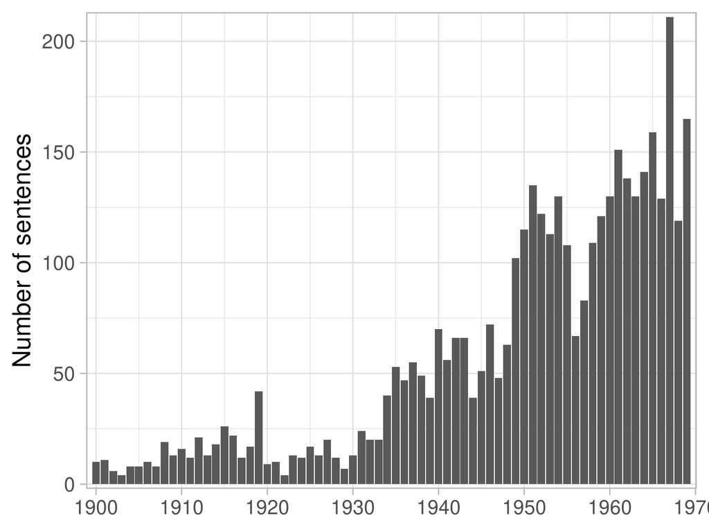

### Closest sentence from ‘rational’ and ‘rationality’ of the backbone community

| Sentence | Title | Year | Journal | Authors | Words Similarity |
| --- | --- | --- | --- | --- | --- |
| For businessmen the application of this kind of criterion can lead to behavior which entrepreneurs in other societies might regard as in conflict with “rational” calculations. | [French Canadians as Industrial Entrepreneurs](http://www.jstor.org/stable/1827203) | 1960 | Journal of Political Economy | Norman W. Taylor | 0.807 |
| The theory advanced here attempts to make explicit the way in which intended but limited rationality operates as a limitation to firm size. | [Hierarchical Control and Optimum Firm Size](http://www.jstor.org/stable/1829822) | 1967 | Journal of Political Economy | Oliver E. Williamson | 0.781 |
| Profit maximization is not the same thing as rationality because other ends also may be pursued in a rational way. | [Recent Developments in Economics](http://www.jstor.org/stable/1884444) | 1954 | The Quarterly Journal of Economics | F. Zeuthen | 0.772 |
| The imperfection of the market is purely irrational if it takes its origin in preferences which obtain no justification, when they are satisfied, in actual enjoyment, and the thwarting of which causes… | [Some Notes on Ideal Output](http://www.jstor.org/stable/2224577) | 1935 | The Economic Journal | R. F. Kahn | 0.765 |
| Here is an argument for ” rationalisation ” which, deriving its strength from the absolute, rather than the relative, degree of imperfection of competition ruling in the industry, should make a strong… | [Mr. Paine and Rationalisation: A Note](http://www.jstor.org/stable/2549226) | 1936 | Economica | R. F. Kahn | 0.764 |
| Individuals are presumed to act as if they were “rational” and were to “maximize” income and satisfactions. | [The Earnings Differential between White Collar and Manual Occupations](http://www.jstor.org/stable/1925725) | 1953 | The Review of Economics and Statistics | Kenneth M. McCaffree | 0.761 |
| Can it not be assumed that rational firms have already taken such possibilities into account? | [Economic Standards for Competitive Freight Rates](http://www.jstor.org/stable/1237154) | 1966 | Journal of Farm Economics | James C. Nelson | 0.761 |
| The apparent paradox to be faced is that the economic theory of the firm and the theory of administration attempt to deal with human behavior in situations in which that behavior is at least “intended… | [A Behavioral Model of Rational Choice](http://www.jstor.org/stable/1884852) | 1955 | The Quarterly Journal of Economics | Herbert A. Simon | 0.757 |
| This new concept of rational behavior allows Neumann-Morgenstern to steer clear of the traps into which the discussion, especially of duopoly, has fallen before. | [Recent Developments of American Economic Thinking](http://www.jstor.org/stable/40432463) | 1951 | Weltwirtschaftliches Archiv | Emil Kauder | 0.755 |
| The businessman reaches this gain by acting “rationally”, i.e. | [Recent Developments of American Economic Thinking](http://www.jstor.org/stable/40432463) | 1951 | Weltwirtschaftliches Archiv | Emil Kauder | 0.754 |
| There is no adequate solution of the problem of defining “rational economic behavior” on the part of an individual when the very rationality of his actions depends on the probable behavior of other in… | [The Theory of Economic Behavior](http://www.jstor.org/stable/1812602) | 1945 | The American Economic Review | Leonid Hurwicz | 0.751 |
| In Part III an attempt is made to determine the size of market necessary for the attainment of high degrees of “rationalization.” | [The Survival Technique and the Extent of Suboptimal Capacity](http://www.jstor.org/stable/1828360) | 1964 | Journal of Political Economy | Leonard W. Weiss | 0.743 |
| This is not to deny that a goodly portion of all business behavior may be non-rational, thoughtless, blindly repetitive, deliberately traditional, or mot’vated by extra-economic objectives. | [Marginal Analysis and Empirical Research](http://www.jstor.org/stable/1801722) | 1946 | The American Economic Review | Fritz Machlup | 0.737 |
| Since this is consistent with the view that shareholders are rational in seeking to maximize their wealth, and that management rationally seeks objectives other than profit maximization, while any oth… | [Profit, Growth and Sales Maximization](http://www.jstor.org/stable/2552269) | 1966 | Economica | John Williamson | 0.737 |
| As to rationality, we know that people usually are capable of following cause and effect in business far enough to see where they can get the most pay for what they have to sell. | [The Relations of Recent Psychological Developments to Economic Theory](http://www.jstor.org/stable/1885945) | 1919 | The Quarterly Journal of Economics | Z. Clark Dickinson | 0.735 |
| Preferences which are the result of ignorance or inertia are almost entirely irrational, though the momentary inconvenience and discomfort which a change of custom inevitably involves, entails an elem… | [Rational and Irrational Consumer Preference](http://www.jstor.org/stable/2224960) | 1938 | The Economic Journal | J. K. Galbraith | 0.735 |
| We must surely fall back on the commonsense view that if competition would not be imperfect but for the imperfection of knowledge, then the reproduction of the conditions of perfect competition ought … | [Rationalisation and the Theory of Excess Capacity](http://www.jstor.org/stable/2549169) | 1936 | Economica | C. L. Paine | 0.735 |
| Yet owing to the fact that in the course of two decades numerous cases involving the same principles have come before the Commission for adjudication, and that conclusions reached on the basis of unso… | [Railway Rate Theories of the Interstate Commerce Commission. I.](http://www.jstor.org/stable/1885824) | 1910 | The Quarterly Journal of Economics | M. B. Hammond | 0.734 |
| It is pertinent, however, to remark that the assumption that entrepreneurs maximise their profits and consumers their utility is not usually taken to imply that the rational man must be well-grounded … | [Safety First and the Holding of Assets](http://www.jstor.org/stable/1907413) | 1952 | Econometrica | A. D. Roy | 0.733 |
| The economist evolved a theory of how the rational businessman maximizes his profits; but this theory, however unassailable it may be logically, does not fit the facts of business practice very well. | [A Proposal for Extending the Theory of the Firm](http://www.jstor.org/stable/1879501) | 1951 | The Quarterly Journal of Economics | W. W. Cooper | 0.732 |

### Closest sentences of the backbone community’s centroid

| Sentence | Title | Year | Journal | Authors | Centroid Similarity |
| --- | --- | --- | --- | --- | --- |
| One notices this in at least three areas of economiiic thought: in the theory of the market, in the theory of development, and in the theory of decision making, both public and private. | [The Economics of Knowledge and the Knowledge of Economics](http://www.jstor.org/stable/1821262) | 1966 | The American Economic Review | Kenneth E. Boulding | 0.7983592 |
| Contrary to the opinion of many critics of economics as a science,39 Friedman makes the often overlooked but extremely significant contention that the usefulness or practicality of positivist theories… | [Advocacy versus Analysis in Economics](http://www.jstor.org/stable/1054708) | 1955 | Southern Economic Journal | Campbell R. McConnell | 0.7822529 |
| Recognition of the modifying influence of custom was essential: “to escape error, we ought, in applying the conclusions of political economy to the actual affairs of life to consider not only what wil… | [John Stuart Mill’s Principles: A Centenary Estimate](http://www.jstor.org/stable/1831728) | 1949 | The American Economic Review | Vincent W. Bladen | 0.7755292 |
| Had instruction in beginning economics been more effective, it would be known that such control must somehow take account of the choices of all people among all goods, of the scarcities of all resourc… | [Corporate Control and Capitalism](http://www.jstor.org/stable/1880509) | 1965 | The Quarterly Journal of Economics | Shorey Peterson | 0.7622978 |
| Turning his guns upon the postulates which support schematic systems of economic theory, deriding in particular the rational character of consumers’ choices, the regulatory effect of competition, and … | [The Impasse in Economic Theory](http://www.jstor.org/stable/1822132) | 1927 | Journal of Political Economy | Paul T. Homan | 0.7604686 |
| Certain producers exhibit surprising nonchalance, or indifference, even to the point where they submit through mere fear of change to a routine which damages their interests.7 Very generally, in fact,… | [Irrationality in Economics](http://www.jstor.org/stable/1881874) | 1954 | The Quarterly Journal of Economics | Louis Baudin | 0.7596270 |
| Next, it can be shown that certain specific theories predict policies which business men do not usually follow, and which, indeed, they are well advised not to follow if they wish to make a profit.3 T… | [Deductive Systems and Empirical Generalizations in the Theory of the Firm](http://www.jstor.org/stable/2661856) | 1952 | Oxford Economic Papers | M. J. Farrell | 0.7580417 |
| In the next section,8 it is noted that the market results found in the model of purely competitive equilibrium are in several respects attractive as norms but that it is not a priori obvious that thes… | [The Normative Problem in Industrial Regulation](http://www.jstor.org/stable/1818988) | 1943 | The American Economic Review | Joe S. Bain | 0.7563966 |
| It would seem to follow that whatever economic evils there may be arise not from the excess but fromthe defect of free competition, and that whatever we may seek to do by way of remedy must lie- some … | [Competitive and Social Value](http://www.jstor.org/stable/2548107) | 1924 | Economica | L. T. Hobhouse | 0.7539555 |
| In order to isolate uncertainty as a factor making for profits let us assume that there were no other barriers against the flow of resources and that none of the resources were indivisible; furthermor… | [Competition, Pliopoly and Profit](http://www.jstor.org/stable/2549871) | 1942 | Economica | Fritz Machlup | 0.7531438 |
| Whence it follows that any socio-economic change which reduces competition between certain goals, and does not at the same time influence unfavorably the possiblity of achieving other objectives, dimi… | [Sociological Presuppositions in Economic Theory](http://www.jstor.org/stable/1053081) | 1940 | Southern Economic Journal | Joseph J. Spengler | 0.7527908 |
| The economic world has learned long since that in human society competition is not itself a pure principle of action, that if there is to be a society, competition must work within certain guide lines… | [The International Food Movement](http://www.jstor.org/stable/1812247) | 1943 | The American Economic Review | John D. Black | 0.7527198 |
| “3 In this situation, how does managerial economics contribute or show promise of contributing to economic theory? | [What can Managerial Economics Contribute to Economic Theory?](http://www.jstor.org/stable/1914478) | 1961 | The American Economic Review | Charles J. Hitch, Roland N. McKean | 0.7521940 |
| To say that private enterprise is inefficient because indivisibilities and imperfect knowledge are part of life, or because people are susceptible to the human weaknesses subsumed in the term moral ha… | [Information and Efficiency: Another Viewpoint](http://www.jstor.org/stable/724977) | 1969 | The Journal of Law & Economics | Harold Demsetz | 0.7509614 |
| Any such statement obviously has implications concerning the adequacy of economic policies, the forces of competition, etc., but on these we shall not elaborate here. | [Measures of Technological Progress in the Light of Recent Growth Theories](http://www.jstor.org/stable/1814395) | 1967 | The American Economic Review | William Fellner | 0.7503240 |

### Closest sentences of each kmean cluster’s centroid composing the backbone community

#### Top terms 5_8: hedonistic, pecuniary, entrepreneur, modern_business, monopoly (1900-1919)

| Sentence | Title | Year | Journal | Authors | Distance to Centroid |
| --- | --- | --- | --- | --- | --- |
| The pecuniary market taken as a whole, with its elaborate system of money, credit, bargaining, accounting, forecasting of demand, business administration and so on, involving numerous recondite functi… | [The Progress of Pecuniary Valuation](http://www.jstor.org/stable/1885801) | 1915 | The Quarterly Journal of Economics | Charles H. Cooley | 8.030931 |
| V Altho it is intended merely to indicate a possible theory of profit, leaving amplification and defense of the theory suggested for another occasion, it will be well to consider briefly three questio… | [The Income of Capital](http://www.jstor.org/stable/1884766) | 1912 | The Quarterly Journal of Economics | G. A. Kleene | 8.146670 |
| Not only are the nature of the price-system and the role of pecuniary valuation excluded from its concern, but such institutions as the market, trade, contract, property, and competition, which give t… | [The Place of Value Theory in Economics: I](http://www.jstor.org/stable/1821866) | 1918 | Journal of Political Economy | Walton H. Hamilton | 8.184954 |
| Development of the theory of profit, 151. | [Price Fixing and the Theory of Profit](http://www.jstor.org/stable/1884491) | 1919 | The Quarterly Journal of Economics | Kemper Simpson | 8.313128 |
| Nor does Fisher lose caste as a theorist when he heaps up psychology, good and indifferent, in an attempt to find the origin of interest in the economic judgment.3 But on the contrary, despite his use… | [The Place of Value Theory in Economics: I](http://www.jstor.org/stable/1821866) | 1918 | Journal of Political Economy | Walton H. Hamilton | 8.346724 |

#### Top terms 5_26: free_competition, imperfection, imperfect_competition, perfect_competition, monopoly (1920-1939)

| Sentence | Title | Year | Journal | Authors | Distance to Centroid |
| --- | --- | --- | --- | --- | --- |
| What Professor Chamberlin really contends, is that there is a difference in “approach,” in economic “Weltanschauung,” between Mrs. Robinson and himself; but the reader could hardly fail to carry away … | [Professor Chamberlin on Monopolistic and Imperfect Competition](http://www.jstor.org/stable/1884087) | 1938 | The Quarterly Journal of Economics | Nicholas Kaldor | 7.086185 |
| In the absence of any attempt whatever at a rational separation of market spheres in terms of the best social results achievable, a chaotic, wasteful, specious competition may persist for a long time … | [Competitive Significance of Substitutes for Public Utility Service](http://www.jstor.org/stable/1803814) | 1937 | The American Economic Review | B. N. Behling | 7.453934 |
| NOTES AND MEMORANDA ANOTHER FUNDAMENTAL OBJECTION TO LAISSEZ-FAIRE MRs. ROBINSON has raised an interesting objection to the notion that perfect competition tends to secure the economic maximum.’ | [Another Fundamental Objection to Laissez-Faire](http://www.jstor.org/stable/2225171) | 1936 | The Economic Journal | R. F. Harrod | 7.525473 |
| competition, her rejection of “product differentiation,” and her broad definition of a “commodity” ;8 in Imperfect Competition, her separate chapters on “Monopoly Equilibrium” and on “Competitive Equi… | [Monopolistic or Imperfect Competition?](http://www.jstor.org/stable/1881679) | 1937 | The Quarterly Journal of Economics | Edward H. Chamberlin | 7.568087 |
| The economic process, therefore, does not take place in large unform markets, but by a multifarious interaction between concrete productive units, now by substantially free competition, now by a partl… | [Theoretical Remarks on Price Policy Hotelling’s Case with Variations](http://www.jstor.org/stable/1883687) | 1933 | The Quarterly Journal of Economics | F. Zeuthen | 7.657483 |

#### Top terms 5_37: entrepreneur, business_behavior, business_behaviour, businessman, entrepreneurial (1940-1949)

| Sentence | Title | Year | Journal | Authors | Distance to Centroid |
| --- | --- | --- | --- | --- | --- |
| In the followirng we set out to show that by attributing to the entrepreneur the desire to maximise his profits we also attribute to him a particular psychology, which, though very plauisible, is rath… | [A Note on Profit Maximisation and its Implications](http://www.jstor.org/stable/2967520) | 1943 | The Review of Economic Studies | T. De Scitovszky | 7.796316 |
| Part of the prominence of its place is undoubtedly a result of the fact that a business economy has become institutionalized in our society.6 The traditional doctrine of economics that action in a bus… | [The Motivation of Economic Activities](http://www.jstor.org/stable/137203) | 1940 | The Canadian Journal of Economics and Political Science / Revue canadienne d’Economique et de Science politique | Talcott Parsons | 7.910302 |
| One further comment on the empirical aspect of the argument seems called for-one having to do with the business situation itself. | [Round Table on Population Problems](http://www.jstor.org/stable/1814516) | 1940 | The American Economic Review | Otto Nathan , O. E. Baker , James G. Evans, Alan R. Sweezy | 7.950943 |
| Not all of the assumptions made in creating a hypothetical firm are equally important for its behavior. | [Relations Between Wage Rates, Costs, and Prices](http://www.jstor.org/stable/1815125) | 1942 | The American Economic Review | Lloyd G. Reynolds | 8.046276 |
| I want to move now to some observations regarding the applicability of economic theory to modern business organization. | [Current Institutional Trends in Business](http://www.jstor.org/stable/1233790) | 1949 | Journal of Farm Economics | A. C. Hoffman | 8.133805 |

#### Top terms 5_41: pure_competition, monopolistic, monopolistic_competition, imperfect_competition, perfect_competition (1940-1949)

| Sentence | Title | Year | Journal | Authors | Distance to Centroid |
| --- | --- | --- | --- | --- | --- |
| The purpose of the present essay is not to condemn the abstract theory of monopolistic competition, as such; it is rather to oppose the unjustifiable use which has been made of it. | [Monopolistic Competition Theory and Public Price Policy](http://www.jstor.org/stable/1816756) | 1942 | The American Economic Review | Vernon A. Mund | 7.028214 |
| The economic world has learned long since that in human society competition is not itself a pure principle of action, that if there is to be a society, competition must work within certain guide lines… | [The International Food Movement](http://www.jstor.org/stable/1812247) | 1943 | The American Economic Review | John D. Black | 7.038262 |
| As long as he has not done it, and shown that the problem is incapable of solution, his statements about the “threatened wreckage” of economic theory through the assumption of monopolistic competition… | [Professor Hicks’ Statics](http://www.jstor.org/stable/1883335) | 1940 | The Quarterly Journal of Economics | Fritz Machlup | 7.141741 |
| This does not deny the importance of competitive economic theory in the formulation and constant improvement of basic concepts, but it does seem to censure researchers for not having used theory in th… | [[Agricultural Marketing Research]: Discussion](http://www.jstor.org/stable/1232864) | 1949 | Journal of Farm Economics | Max E. Brunk , L. H. Simerl , E. W. Gaumnitz | 7.219849 |
| This does not deny the importance of competitive economic theory in the formulation and constant improvement of basic concepts, but it does seem to censure researchers for not having used theory in th… | [The Field of Agricultural Marketing Research: Objectives, Definition, Content, Criteria](http://www.jstor.org/stable/1232331) | 1949 | Journal of Farm Economics | Geoffrey Shepherd | 7.219850 |

#### Top terms 5_58: businessman, business_behaviour, businessmen, business_decisions, profit_maximization (1950-1959)

| Sentence | Title | Year | Journal | Authors | Distance to Centroid |
| --- | --- | --- | --- | --- | --- |
| In criticisms of classical economic theory much has been made of the point that the motivations that govern business, whether or not we choose to classify them as “economic,” involve far more than a s… | [Some Institutional Factors in Business Investment Decisions](http://www.jstor.org/stable/1818336) | 1954 | The American Economic Review | Edgar M. Hoover | 7.282129 |
| Contrary to the opinion of many critics of economics as a science,39 Friedman makes the often overlooked but extremely significant contention that the usefulness or practicality of positivist theories… | [Advocacy versus Analysis in Economics](http://www.jstor.org/stable/1054708) | 1955 | Southern Economic Journal | Campbell R. McConnell | 7.415029 |
| Mrs. Robinson’s “single assumption,” although often made by others, is extravagantly unrealistic; all that depends upon it is therefore useless for prediction, unless there are reasons for supposing t… | [On Maximizing Profits: A Distinction Between Chamberlin and Robinson](http://www.jstor.org/stable/1813588) | 1951 | The American Economic Review | Stephen Enke | 7.619643 |
| III A second minor hypothesis of Professor Philbrook which demands careful scrutiny, and considerable qualification, is his view of the limited usefulness of economic analysis to the businessman. | [The Role of Economics in Education for Business Administration](http://www.jstor.org/stable/1055067) | 1958 | Southern Economic Journal | John P. Owen | 7.792924 |
| The economist evolved a theory of how the rational businessman maximizes his profits; but this theory, however unassailable it may be logically, does not fit the facts of business practice very well. | [A Proposal for Extending the Theory of the Firm](http://www.jstor.org/stable/1879501) | 1951 | The Quarterly Journal of Economics | W. W. Cooper | 7.801763 |

#### Top terms 5_60: perfect_competition, monopolistic, pure_competition, imperfect_competition, monopolistic_competition (1950-1959)

| Sentence | Title | Year | Journal | Authors | Distance to Centroid |
| --- | --- | --- | --- | --- | --- |
| 8 We find some solace in J. M. Clark’s lament that: ‘It seems unfortunate if economists who defend realistic forms of competition thereby expose themselves to the charge of defending monopoly.’ | [A Critique of United States Experience with Price-Fixing Agreements and the Per Se Rule](http://www.jstor.org/stable/2097474) | 1959 | The Journal of Industrial Economics | Almarin Phillips | 6.729040 |
| 3 Likewise, Mr. Farrell’s contribution to the discussion 4 takes place under the rubric ” The Case Against the Imperfect Competition Theories.” | [“Full Cost” and Monopolistic Competition](http://www.jstor.org/stable/2227007) | 1952 | The Economic Journal | Edward H. Chamberlin | 7.055431 |
| I shall argue that, apart f rom such pedagogic merit as they may have, the theories of monopolistic and imperfect competition have not proved to be useful formulations, in the sense that Marshall’s fo… | [Advertising, Product Variation, and the Limits of Economics](http://www.jstor.org/stable/1825745) | 1951 | Journal of Political Economy | Alfred Sherrard | 7.370564 |
| It is not impossible that economists themselves, in some slight measure, have contributed to its demise; for, neglecting the imperfection of our knowledge and the problems arising from it, they have, … | [Imperfect Knowledge and Economic Efficiency](http://www.jstor.org/stable/2661972) | 1953 | Oxford Economic Papers | G. B. Richardson | 7.508426 |
| 1 cannot refrain in this connection from again referring to the position taken by Professor Hicks who, reasoning that “a general abandonment of the assumption of perfect competition … must have very d… | [The Product as an Economic Variable](http://www.jstor.org/stable/1884146) | 1953 | The Quarterly Journal of Economics | Edward H. Chamberlin | 7.547655 |

#### Top terms 5_63: profit_maximization, businessmen, enterprises, businessman, managerial (1960-1969)

| Sentence | Title | Year | Journal | Authors | Distance to Centroid |
| --- | --- | --- | --- | --- | --- |
| Or, to refer to the point raised by Krooss in 1958, what significance can be attached to scattered evidence that businessmen are motivated in their behavior by considerations other than to maximize pr… | [Business History and Economic History](http://www.jstor.org/stable/2115899) | 1966 | The Journal of Economic History | Harold F. Williamson | 7.509231 |
| When profit maximization is taken as an attribute of the firm but not the businessman, and when the firm’s costs are seen to include the supply price of the entrepreneur, most of the confusion over th… | [The Profit Maximization Assumption](http://www.jstor.org/stable/2661778) | 1963 | Oxford Economic Papers | H. T. Koplin | 7.658189 |
| It is of interest to the economic theorist whether firm managements are motivated to maximize sales subject to a minimum profit constraint, as Baumol hypothesizes, or to maximize profits, as tradition… | [Executive Incomes, Profits and Revenues: A Comment on Functional Specification](http://www.jstor.org/stable/1056052) | 1969 | Southern Economic Journal | Samuel H. Baker | 7.760170 |
| One arises because of the convenient assumption of rational profit-maximizing behavior on the part of the theoretical entrepreneur and the disturbing fact that firms, as they are observed in the real … | [A Theory of Interfirm Organization](http://www.jstor.org/stable/1884355) | 1960 | The Quarterly Journal of Economics | Almarin Phillips | 7.808065 |
| Some further discussion of the operation of an enterprise is in order, since it is in that connection that the prices both of products and of productive services are determined-ignoring for the moment… | [Methodology in Economics: Part II](http://www.jstor.org/stable/1055525) | 1961 | Southern Economic Journal | Frank H. Knight | 7.851596 |

#### Top terms 5_77: pure_competition, perfect_competition, monopolistic, oligopoly, market_system (1960-1969)

| Sentence | Title | Year | Journal | Authors | Distance to Centroid |
| --- | --- | --- | --- | --- | --- |
| It would be rather surprising if the institution of the so-called ‘common markets’ did not bring theoreticians to insist on some aspects of reality which the theory of monopolistic competition tends t… | [Common Markets: Towards a Theory of Market Integration](http://www.jstor.org/stable/2097733) | 1962 | The Journal of Industrial Economics | Louis Phlips | 6.977940 |
| Johr, who had spent some months in Harvard and Chicago, includes in his work all the important results of Joan Robinson, E. H. Chamberlin, and R. Triffin on competition and monopoly; but they are so i… | [The Old and the New–Some Recent Trends in the Literature of German Economics](http://www.jstor.org/stable/1809373) | 1964 | The American Economic Review | K. W. Rothschild | 7.293151 |
| An implication of the discussion so far for a market equilibrium 3. | [On the Tax Structure of Interest Rates](http://www.jstor.org/stable/1885450) | 1969 | The Quarterly Journal of Economics | Gordon Pye | 7.498986 |
| Partly with the assistance of legal interpretations given in glamorous anti-trust trials, the notion of a single-price market, with many buyers and many sellers, is included in the level of popular ec… | [On the Idea of a Market](http://www.jstor.org/stable/2097525) | 1964 | The Journal of Industrial Economics | Robert D. Entenberg, A. James Boness | 7.569809 |
| “3 Let all markets be in equilibrium, argues Patinkin, and allow pu’ to change.” | [Walras, Patinkin and the Money Tâtonnement](http://www.jstor.org/stable/2229557) | 1966 | The Economic Journal | David Collard | 7.595622 |

### Top articles (most sentences) of the backbone cluster

| Title | Year | Journal | Authors | Number sentences | Words Similarity |
| --- | --- | --- | --- | --- | --- |
| [Some Notes on Ideal Output](http://www.jstor.org/stable/2224577) | 1935 | The Economic Journal | R. F. Kahn | 21 | 0.656 |
| [A Critique of Concepts of Workable Competition](http://www.jstor.org/stable/1882232) | 1958 | The Quarterly Journal of Economics | Stephen H. Sosnick | 14 | 0.595 |
| [Rational and Irrational Consumer Preference](http://www.jstor.org/stable/2224960) | 1938 | The Economic Journal | J. K. Galbraith | 13 | 0.651 |
| [Social Biases and Recent Theories of Competition](http://www.jstor.org/stable/1885753) | 1943 | The Quarterly Journal of Economics | William H. Nicholls | 13 | 0.607 |
| [Marginal Analysis and Empirical Research](http://www.jstor.org/stable/1801722) | 1946 | The American Economic Review | Fritz Machlup | 13 | 0.631 |
| [Management Economics and the Theory of the Firm](http://www.jstor.org/stable/2097339) | 1967 | The Journal of Industrial Economics | Brian J. Loasby | 13 | 0.633 |
| [Theories of the Firm: Marginalist, Behavioral, Managerial](http://www.jstor.org/stable/1815603) | 1967 | The American Economic Review | Fritz Machlup | 13 | 0.603 |
| [On Maximizing Profits: A Distinction Between Chamberlin and Robinson](http://www.jstor.org/stable/1813588) | 1951 | The American Economic Review | Stephen Enke | 12 | 0.634 |
| [Antitrust and the Classic Model](http://www.jstor.org/stable/1812286) | 1957 | The American Economic Review | Shorey Peterson | 12 | 0.603 |
| [Objective Functions and Models of Corporate Optimization](http://www.jstor.org/stable/1885129) | 1961 | The Quarterly Journal of Economics | Martin Shubik | 12 | 0.597 |
| [The Motives of Managers, Environmental Restraints, and the Theory of Managerial Enterprise](http://www.jstor.org/stable/1879325) | 1964 | The Quarterly Journal of Economics | William L. Baldwin | 12 | 0.598 |
| [The Theory of Restrictive Trade Practices](http://www.jstor.org/stable/2662248) | 1965 | Oxford Economic Papers | G. B. Richardson | 12 | 0.608 |
| [Imperfect Knowledge and Economic Efficiency](http://www.jstor.org/stable/2661972) | 1953 | Oxford Economic Papers | G. B. Richardson | 11 | 0.606 |
| [The Role of Economics in Education for Business Administration](http://www.jstor.org/stable/1055067) | 1958 | Southern Economic Journal | John P. Owen | 11 | 0.616 |
| [Is Oligopoly Illegal? A Jurisprudential Approach](http://www.jstor.org/stable/1883060) | 1960 | The Quarterly Journal of Economics | Jacob Weissman | 11 | 0.613 |

### Top articles (most sentences) of the cluster for each time window

#### Top articles for 5_8: hedonistic, pecuniary, entrepreneur, modern_business, monopoly (1900-1919)

| Title | Year | Journal | Authors | Number sentences | Words Similarity |
| --- | --- | --- | --- | --- | --- |
| [The Rationality of Economic Activity](http://www.jstor.org/stable/1820997) | 1910 | Journal of Political Economy | Wesley C. Mitchell | 9 | 0.637 |
| [Trust Literature: A Survey and A Criticism](http://www.jstor.org/stable/1884894) | 1901 | The Quarterly Journal of Economics | Charles J. Bullock | 8 | 0.633 |
| [Professor Clark’s Economics](http://www.jstor.org/stable/1883836) | 1908 | The Quarterly Journal of Economics | Thornstein Veblen | 7 | 0.628 |
| [The Limitations of Marginal Utility](http://www.jstor.org/stable/1822146) | 1909 | Journal of Political Economy | Thorstein Veblen | 7 | 0.626 |
| [A Division Among Theorists in Their Analysis of Profits](http://www.jstor.org/stable/1884490) | 1919 | The Quarterly Journal of Economics | C. J. Foreman | 7 | 0.613 |
| [Price Fixing and the Theory of Profit](http://www.jstor.org/stable/1884491) | 1919 | The Quarterly Journal of Economics | Kemper Simpson | 7 | 0.597 |
| [A New Text: Seligman: “Social Value”](http://www.jstor.org/stable/1817617) | 1906 | Journal of Political Economy | H. J. Davenport | 6 | 0.628 |
| [The Relations of Recent Psychological Developments to Economic Theory](http://www.jstor.org/stable/1885945) | 1919 | The Quarterly Journal of Economics | Z. Clark Dickinson | 6 | 0.639 |
| [The Progress of Pecuniary Valuation](http://www.jstor.org/stable/1885801) | 1915 | The Quarterly Journal of Economics | Charles H. Cooley | 5 | 0.619 |
| [The Fortune of John Jacob Astor: III](http://www.jstor.org/stable/1820382) | 1908 | Journal of Political Economy | Anna Youngman | 4 | 0.617 |

#### Top articles for 5_26: free_competition, imperfection, imperfect_competition, perfect_competition, monopoly (1920-1939)

| Title | Year | Journal | Authors | Number sentences | Words Similarity |
| --- | --- | --- | --- | --- | --- |
| [Some Notes on Ideal Output](http://www.jstor.org/stable/2224577) | 1935 | The Economic Journal | R. F. Kahn | 21 | 0.656 |
| [Rational and Irrational Consumer Preference](http://www.jstor.org/stable/2224960) | 1938 | The Economic Journal | J. K. Galbraith | 13 | 0.651 |
| [The Ethics of Competition](http://www.jstor.org/stable/1884053) | 1923 | The Quarterly Journal of Economics | Frank H. Knight | 9 | 0.616 |
| [Rationalisation of Industry](http://www.jstor.org/stable/2223585) | 1927 | The Economic Journal | D. H. MacGregor | 9 | 0.649 |
| [A Generalization of the Theory of Imperfect Competition](http://www.jstor.org/stable/1231448) | 1937 | Journal of Farm Economics | G. J. Stigler | 9 | 0.604 |
| [Professor Chamberlin on Monopolistic and Imperfect Competition](http://www.jstor.org/stable/1884087) | 1938 | The Quarterly Journal of Economics | Nicholas Kaldor | 8 | 0.610 |
| [Rationalisation and the Theory of Excess Capacity](http://www.jstor.org/stable/2549169) | 1936 | Economica | C. L. Paine | 7 | 0.645 |
| [Notes on the Anti-Trust Law Policy](http://www.jstor.org/stable/1882488) | 1939 | The Quarterly Journal of Economics | Paul T. Homan | 6 | 0.617 |
| [Robinson’s Economics of Imperfect Competition](http://www.jstor.org/stable/1823265) | 1934 | Journal of Political Economy | Joseph A. Schumpeter, A. J. Nichol | 5 | 0.627 |
| [Market Imperfection and Excess Capacity](http://www.jstor.org/stable/2549105) | 1935 | Economica | Nicholas Kaldor | 5 | 0.592 |

#### Top articles for 5_37: entrepreneur, business_behavior, business_behaviour, businessman, entrepreneurial (1940-1949)

| Title | Year | Journal | Authors | Number sentences | Words Similarity |
| --- | --- | --- | --- | --- | --- |
| [Marginal Analysis and Empirical Research](http://www.jstor.org/stable/1801722) | 1946 | The American Economic Review | Fritz Machlup | 13 | 0.631 |
| [Short-Period Price Determination in Theory and Practice](http://www.jstor.org/stable/1810625) | 1948 | The American Economic Review | R. A. Gordon | 8 | 0.604 |
| [Collective Bargaining and the Common Interest](http://www.jstor.org/stable/1811183) | 1943 | The American Economic Review | Edwin G. Nourse | 6 | 0.632 |
| [The Meaning of “Price Policy”](http://www.jstor.org/stable/1882058) | 1941 | The Quarterly Journal of Economics | E. G. Nourse | 5 | 0.624 |
| [The Measurement of Statistical Cost Functions: An Appraisal of Some Recent Contributions](http://www.jstor.org/stable/1803513) | 1942 | The American Economic Review | Hans Staehle | 5 | 0.630 |
| [A Reconsideration of the Theory of the Individual Business](http://www.jstor.org/stable/2661938) | 1949 | Oxford Economic Papers | P. W. S. Andrews | 5 | 0.626 |
| [Economic Theory and Business Behaviour](http://www.jstor.org/stable/2295916) | 1949 | The Review of Economic Studies | D. C. Hague | 5 | 0.615 |
| [Psychological Analysis of Business Decisions and Expectations](http://www.jstor.org/stable/1802255) | 1946 | The American Economic Review | George Katona | 4 | 0.606 |
| [Price Theory and Oligopoly](http://www.jstor.org/stable/2225674) | 1947 | The Economic Journal | K. W. Rothschild | 4 | 0.613 |
| [The Business Leader in Theory and Reality](http://www.jstor.org/stable/3484172) | 1949 | The American Journal of Economics and Sociology | Fritz Redlich | 4 | 0.595 |

#### Top articles for 5_41: pure_competition, monopolistic, monopolistic_competition, imperfect_competition, perfect_competition (1940-1949)

| Title | Year | Journal | Authors | Number sentences | Words Similarity |
| --- | --- | --- | --- | --- | --- |
| [Social Biases and Recent Theories of Competition](http://www.jstor.org/stable/1885753) | 1943 | The Quarterly Journal of Economics | William H. Nicholls | 12 | 0.607 |
| [Toward a Concept of Workable Competition](http://www.jstor.org/stable/1807048) | 1940 | The American Economic Review | J. M. Clark | 7 | 0.602 |
| [Collective Bargaining and Economic Theory](http://www.jstor.org/stable/1053337) | 1947 | Southern Economic Journal | Werner Hochwald | 7 | 0.610 |
| [Imperfect Competition in Agricultural Processing and Distributing Industries](http://www.jstor.org/stable/137496) | 1944 | The Canadian Journal of Economics and Political Science / Revue canadienne d’Economique et de Science politique | William H. Nicholls | 5 | 0.605 |
| [The Effectiveness of the Federal Antitrust Laws: A Symposium](http://www.jstor.org/stable/1809325) | 1949 | The American Economic Review | Dexter Merriam Keezer | 5 | 0.595 |
| [Competing Products and Monopolistic Competition](http://www.jstor.org/stable/1881664) | 1940 | The Quarterly Journal of Economics | Morris A. Copeland | 4 | 0.597 |
| [Monopolistic Competition Theory and Public Price Policy](http://www.jstor.org/stable/1816756) | 1942 | The American Economic Review | Vernon A. Mund | 4 | 0.594 |
| [The Normative Problem in Industrial Regulation](http://www.jstor.org/stable/1818988) | 1943 | The American Economic Review | Joe S. Bain | 4 | 0.619 |
| [Neumann’s and Morgenstern’s New Approach to Static Economics](http://www.jstor.org/stable/1825790) | 1946 | Journal of Political Economy | J. Marschak | 4 | 0.611 |
| [Price Theory and Oligopoly](http://www.jstor.org/stable/2225674) | 1947 | The Economic Journal | K. W. Rothschild | 4 | 0.604 |

#### Top articles for 5_58: businessman, business_behaviour, businessmen, business_decisions, profit_maximization (1950-1959)

| Title | Year | Journal | Authors | Number sentences | Words Similarity |
| --- | --- | --- | --- | --- | --- |
| [On Maximizing Profits: A Distinction Between Chamberlin and Robinson](http://www.jstor.org/stable/1813588) | 1951 | The American Economic Review | Stephen Enke | 12 | 0.634 |
| [The Role of Economics in Education for Business Administration](http://www.jstor.org/stable/1055067) | 1958 | Southern Economic Journal | John P. Owen | 11 | 0.616 |
| [The Construction of a New Theory of Profit](http://www.jstor.org/stable/1813587) | 1951 | The American Economic Review | Jean Marchal | 9 | 0.611 |
| [The Profit Concept and Theory: A Restatement](http://www.jstor.org/stable/1825573) | 1954 | Journal of Political Economy | J. Fred Weston | 9 | 0.621 |
| [Biological Analogies in the Theory of the Firm](http://www.jstor.org/stable/1812528) | 1952 | The American Economic Review | Edith Tilton Penrose | 8 | 0.619 |
| [A Note on Entrepreneurial Behaviour](http://www.jstor.org/stable/2295762) | 1957 | The Review of Economic Studies | J. P. Nettl | 8 | 0.614 |
| [Non-Pecuniary Elements and Business Behaviour](http://www.jstor.org/stable/2661907) | 1959 | Oxford Economic Papers | John H. Dunning | 8 | 0.617 |
| [THE DEVELOPMENT OF THE THEORY OF ENTREPRENEURSHIP](http://www.jstor.org/stable/29793189) | 1959 | Indian Economic Review | Meenakshi Tyagarajan | 8 | 0.602 |
| [The Economist’s Description of Business Behaviour](http://www.jstor.org/stable/2551061) | 1952 | Economica | G. F. Thirlby | 7 | 0.609 |
| [Biological Analogies in the Theory of the Firm: Rejoinder](http://www.jstor.org/stable/1812403) | 1953 | The American Economic Review | Edith T. Penrose | 7 | 0.607 |

#### Top articles for 5_60: perfect_competition, monopolistic, pure_competition, imperfect_competition, monopolistic_competition (1950-1959)

| Title | Year | Journal | Authors | Number sentences | Words Similarity |
| --- | --- | --- | --- | --- | --- |
| [Antitrust and the Classic Model](http://www.jstor.org/stable/1812286) | 1957 | The American Economic Review | Shorey Peterson | 10 | 0.602 |
| [A Critique of Concepts of Workable Competition](http://www.jstor.org/stable/1882232) | 1958 | The Quarterly Journal of Economics | Stephen H. Sosnick | 10 | 0.594 |
| [The Impact of Recent Monopoly Theory on the Schumpeterian System](http://www.jstor.org/stable/1925875) | 1951 | The Review of Economics and Statistics | Edward H. Chamberlin | 7 | 0.604 |
| [Product Differentiation and Welfare Economics](http://www.jstor.org/stable/1881993) | 1955 | The Quarterly Journal of Economics | Alex Hunter | 6 | 0.617 |
| [Monopolistic Competition Revisited](http://www.jstor.org/stable/2549607) | 1951 | Economica | Edward H. Chamberlin | 5 | 0.619 |
| [Perspectives on Monopoly](http://www.jstor.org/stable/1830240) | 1951 | Journal of Political Economy | Neil H. Jacoby | 5 | 0.595 |
| [The Inadequacy of the Theory of the Firm as a Branch of Welfare Economics](http://www.jstor.org/stable/2661855) | 1952 | Oxford Economic Papers | T. Wilson | 5 | 0.596 |
| [Imperfect Knowledge and Economic Efficiency](http://www.jstor.org/stable/2661972) | 1953 | Oxford Economic Papers | G. B. Richardson | 5 | 0.609 |
| [Intangible Property as a Tool for Analyzing the Relationships Between Government and Private Enterprise](http://www.jstor.org/stable/1884151) | 1953 | The Quarterly Journal of Economics | Edward A. Carlin | 5 | 0.610 |
| [The Shoe Machinery Case and the Problem of the Good Trust](http://www.jstor.org/stable/1884451) | 1954 | The Quarterly Journal of Economics | Lucile Sheppard Keyes | 5 | 0.609 |

#### Top articles for 5_63: profit_maximization, businessmen, enterprises, businessman, managerial (1960-1969)

| Title | Year | Journal | Authors | Number sentences | Words Similarity |
| --- | --- | --- | --- | --- | --- |
| [Management Economics and the Theory of the Firm](http://www.jstor.org/stable/2097339) | 1967 | The Journal of Industrial Economics | Brian J. Loasby | 13 | 0.633 |
| [The Motives of Managers, Environmental Restraints, and the Theory of Managerial Enterprise](http://www.jstor.org/stable/1879325) | 1964 | The Quarterly Journal of Economics | William L. Baldwin | 12 | 0.598 |
| [Theories of the Firm: Marginalist, Behavioral, Managerial](http://www.jstor.org/stable/1815603) | 1967 | The American Economic Review | Fritz Machlup | 12 | 0.602 |
| [The Profit Maximization Assumption](http://www.jstor.org/stable/2661778) | 1963 | Oxford Economic Papers | H. T. Koplin | 10 | 0.603 |
| [A Reformulation of Naive Profit Theory](http://www.jstor.org/stable/1054904) | 1960 | Southern Economic Journal | Martin Bronfenbrenner | 8 | 0.602 |
| [An Indifference Approach to the Theory of the Firm](http://www.jstor.org/stable/1055729) | 1961 | Southern Economic Journal | Edgar O. Edwards | 8 | 0.608 |
| [Ideal and Reality in the Choice between Alternative Techniques](http://www.jstor.org/stable/2662573) | 1964 | Oxford Economic Papers | Ronald L. Meek | 8 | 0.624 |
| [Are Monetary and Fiscal Policies Enough?](http://www.jstor.org/stable/2228849) | 1964 | The Economic Journal | R. F. Harrod | 8 | 0.598 |
| [Objective Functions and Models of Corporate Optimization](http://www.jstor.org/stable/1885129) | 1961 | The Quarterly Journal of Economics | Martin Shubik | 7 | 0.599 |
| [Operations Research and the Theory of the Firm](http://www.jstor.org/stable/1055227) | 1962 | Southern Economic Journal | Almarin Phillips | 7 | 0.634 |

#### Top articles for 5_77: pure_competition, perfect_competition, monopolistic, oligopoly, market_system (1960-1969)

| Title | Year | Journal | Authors | Number sentences | Words Similarity |
| --- | --- | --- | --- | --- | --- |
| [Is Oligopoly Illegal? A Jurisprudential Approach](http://www.jstor.org/stable/1883060) | 1960 | The Quarterly Journal of Economics | Jacob Weissman | 10 | 0.610 |
| [Economic Theory and the Meaning of Competition](http://www.jstor.org/stable/1879604) | 1968 | The Quarterly Journal of Economics | Paul J. McNulty | 9 | 0.621 |
| [Uncertainty and the Welfare Economics of Medical Care](http://www.jstor.org/stable/1812044) | 1963 | The American Economic Review | Kenneth J. Arrow | 7 | 0.618 |
| [The Theory of Restrictive Trade Practices](http://www.jstor.org/stable/2662248) | 1965 | Oxford Economic Papers | G. B. Richardson | 7 | 0.611 |
| [The Origin and Early Development of Monopolistic Competition Theory](http://www.jstor.org/stable/1884318) | 1961 | The Quarterly Journal of Economics | Edward H. Chamberlin | 6 | 0.597 |
| [Politics, Policy, and the Pigovian Margins](http://www.jstor.org/stable/2601517) | 1962 | Economica | James M. Buchanan | 6 | 0.622 |
| [Common Markets: Towards a Theory of Market Integration](http://www.jstor.org/stable/2097733) | 1962 | The Journal of Industrial Economics | Louis Phlips | 6 | 0.590 |
| [The Possibility of a Social Welfare Function](http://www.jstor.org/stable/1815299) | 1966 | The American Economic Review | James S. Coleman | 6 | 0.616 |
| [Ordo and Coercion: A Logical Critique](http://www.jstor.org/stable/1055165) | 1960 | Southern Economic Journal | Henry M. Oliver, Jr. | 5 | 0.618 |
| [Market Structure Analysis as an Orientation for Research in Agricultural Economics](http://www.jstor.org/stable/1235883) | 1961 | Journal of Farm Economics | Robert L. Clodius , Willard F. Mueller | 5 | 0.609 |

### Most cited references in the backbone community

| First Author | Year | Journal | Citation by article | Citation by sentence |
| --- | --- | --- | --- | --- |
| LESTER-R | 1946 | AM EC REV | 2 | 50 |
| ROBINSONEAG | 1950 | EC J DEC | 2 | 50 |
| CLARK-J | 1940 | AM EC REV EVANSTON | 2 | 40 |
| REDER-M | 1947 | J POLITICAL EC | 2 | 34 |
| HARRODRF | 1939 | OXFORD ECON PAP | 2 | 32 |
| BAUMOL-W | 1962 | AM EC REV | 2 | 24 |
| LANZILLOTTI-R | 1960 | J FARM ECON | 2 | 10 |
| MUELLER-W | 1957 | J FARM EC | 2 | 10 |
| FARRIS-P | 1958 | J FARM EC | 2 | 10 |

| First Author | Year | Journal | Citation by article | Citation by sentence |
| --- | --- | --- | --- | --- |
| BAUMOL-W | 1959 | BUSINESS BEHAV VALUE | 18 | 216 |
| FELLNER-W | 1949 | COMPETITION FEW | 17 | 204 |
| MARRIS-R | 1964 | EC THEORY MANAGERIAL | 9 | 117 |
| WILLIAMSON-O | 1964 | EC DISCRETIONARY BEH | 8 | 96 |
| PENROSE-E | 1959 | THEORY GROWTH FIRM | 8 | 96 |
| CYERT-R | 1963 | BEHAV THEORY FIRM | 7 | 84 |
| BERLE-A | 1932 | MODERN CORPORATION P | 7 | 84 |
| GALBRAITH-J | 1952 | AM CAPITALISM CONCEP | 13 | 78 |
| MACHLUPF | 1946 | MARGINAL ANAL EMPIRI | 6 | 72 |
| FELLNERW | 1949 | COMPETITION FEW | 9 | 72 |
| BAUMOL-W | 1952 | WELFARE EC THEORY ST | 7 | 70 |
| ROBINSON-J | 1933 | EC IMPERFECT COMPETI | 5 | 60 |
| SIMON-H | 1957 | ADM BEHAV | 5 | 60 |
| LUTZ-F | 1951 | THEORY INVESTMENT FI | 5 | 60 |
| SHUBIK-M | 1959 | NAVAL RES LOGISTICS | 8 | 56 |

### Most cited references per kmean clusters

#### Top references 5_37: entrepreneur, business_behavior, business_behaviour, businessman, entrepreneurial (1940-1949)

| First Author | Year | Journal | Citation by article | Citation by sentence |
| --- | --- | --- | --- | --- |
| LESTER-R | 1946 | AM EC REV | 1 | 13 |
| HALLRL | 1939 | OXFORD ECON PAP | 1 | 13 |
| HARRODRF | 1939 | OXFORD ECON PAP | 1 | 13 |
| KATONAG | 1946 | AM ECON REV | 1 | 13 |
| KATONAG | 1945 | PRICE CONTROL BUSINE | 1 | 13 |
| LESTERRA | 1941 | EC LABOR | 1 | 13 |
| PATINKIN-D | 1947 | Q J EC | 1 | 8 |
| COASE-R | 1946 | ECONOMICA | 1 | 8 |
| BUCHANA-N | 1942 | J POLITICAL EC | 1 | 8 |
| REDER-M | 1947 | J POLITICAL EC | 1 | 8 |

| First Author | Year | Journal | Citation by article | Citation by sentence |
| --- | --- | --- | --- | --- |
| GORDONRA | 1945 | BUSINESS LEADERSHIP | 3 | 24 |
| HARTAG | 1940 | ANTICIPATIONS UNCERT | 3 | 12 |
| TINBERGENJ | 1939 | METHOD APPL INVESTME | 3 | 12 |
| HALLRL | 1939 | OXFORD EC PAPERS | 2 | 8 |
| LANGEO | 1944 | PRICE FLEXIBILITY EM | 2 | 8 |
| BOULDING | 1941 | EC ANAL | 1 | 8 |
| JOSEPHMFW | 1933 | EC J | 1 | 8 |
| STIGLER | 1946 | THEORY PRICE | 1 | 8 |
| TRIFFIN | 1940 | MONOPOLISTIC COMPETI | 1 | 8 |
| BRADYRA | 1943 | BUSINESS SYSTEM POWE | 2 | 8 |

#### Top references 5_41: pure_competition, monopolistic, monopolistic_competition, imperfect_competition, perfect_competition (1940-1949)

| First Author | Year | Journal | Citation by article | Citation by sentence |
| --- | --- | --- | --- | --- |
| BLAIRGM | 1948 | AM EC REV PAPERS MAY | 1 | 5 |
| CLARKJM | 1942 | READINGS SOCIAL CONT | 1 | 5 |
| MASONES | 1947 | PRICING PROBLEMS STA | 1 | 5 |
| KEYNES-J | 1936 | GENERAL THEORY EMPLO | 1 | 4 |
| *NATBURECRES | 1943 | COST BEHAV PRIC POL | 1 | 4 |
| HALLRL | 1939 | OXFORD EC PAPRS MAY | 1 | 4 |
| HAMILTONW | 1938 | PRICE PRICE POLICIES | 1 | 4 |
| HARRODRF | 1939 | OXFORD EC PAPERS MAY | 1 | 4 |
| KAHNRF | 1937 | EC J MAR | 1 | 4 |
| NOURSEEG | 1941 | Q J EC FEB | 1 | 4 |

| First Author | Year | Journal | Citation by article | Citation by sentence |
| --- | --- | --- | --- | --- |
| VONNEUMANNJ | 1944 | THEORY GAMES EC BEHA | 3 | 12 |
| LANGEO | 1944 | COWLES COMMISSION MO | 2 | 8 |
| MARSHALL | 1920 | PRINCIPLES EC | 2 | 8 |
| LERNERAP | 1944 | EC CONTROL | 3 | 6 |
| MARSHALLA | 1920 | PRINCIPLES EC | 2 | 6 |
| VONNEUMANNJ | 1947 | THEORY GAMES EC BEHA | 3 | 6 |
| CLARKJM | 1948 | ALTERNATIVE SERFDOM | 1 | 5 |
| ROBINSONJ | 1933 | EC IMPERFECT COMPETI | 2 | 4 |
| KNIGHTFH | 1921 | RISK UNCERTAINTY PRO | 1 | 4 |
| MARSCHAKJ | 1938 | ECONOMETRICA OCT | 1 | 4 |

#### Top references 5_58: businessman, business_behaviour, businessmen, business_decisions, profit_maximization (1950-1959)

| First Author | Year | Journal | Citation by article | Citation by sentence |
| --- | --- | --- | --- | --- |
| FRIEDMAN-M | 1948 | J POLIT EC | 1 | 12 |
| ROBINSONEAG | 1950 | EC J DEC | 1 | 12 |
| HENDERSONHD | 1921 | SUPPLY DEMAND | 1 | 12 |
| TRIFFINR | 1940 | MONOPOLISTIC COMPETI | 1 | 12 |
| ZINGLER-E | 1956 | HOUSTON BUSINESS REV | 1 | 11 |
| RIGBY-P | 1957 | HOUSTON BUSINESS REV | 1 | 11 |
| JOHNSON-H | 1957 | ATLANTA EC REV | 1 | 11 |
| MARKOWITZ-H | 1952 | J FINANCE | 1 | 9 |
| ALCHIAN-A | 1950 | J POLIT EC | 1 | 9 |
| ENKE-S | 1951 | AM EC REV | 1 | 9 |

| First Author | Year | Journal | Citation by article | Citation by sentence |
| --- | --- | --- | --- | --- |
| MACHLUPF | 1946 | MARGINAL ANAL EMPIRI | 6 | 72 |
| THIRLBYGF | 1946 | ECONOMICA FEB | 5 | 35 |
| BOULDINGKE | 1950 | RECONSTRUCTION EC | 3 | 27 |
| GORDONRA | 1948 | SHORT PERIOD PRICE D | 2 | 24 |
| LESTERRA | 1946 | SHORTCOMINGS MARGINA | 2 | 24 |
| SAVAGE-L | 1954 | FDN STAT | 4 | 24 |
| GALBRAITH-J | 1952 | AM CAPITALISM CONCEP | 5 | 20 |
| KALECKIM | 1939 | ESSAYS THEORY EC FLU | 2 | 18 |
| KEYNESJM | 1930 | TREATISE MONEY | 2 | 18 |
| PIGOUAC | 1932 | EC WELFARE | 2 | 18 |

#### Top references 5_60: perfect_competition, monopolistic, pure_competition, imperfect_competition, monopolistic_competition (1950-1959)

| First Author | Year | Journal | Citation by article | Citation by sentence |
| --- | --- | --- | --- | --- |
| CLARK-J | 1940 | AM EC REV EVANSTON | 1 | 10 |
| LIEBHAFSKY-H | 1955 | CAN J EC POL SCI | 1 | 10 |
| HAYEK-F | 1944 | ROAD SERFDOM | 1 | 10 |
| PETERSON-S | 1957 | AM EC REV | 1 | 10 |
| BURNS-A | 1936 | DECLINE COMPETITION | 1 | 10 |
| BERLE-A | 1954 | 20TH CENTURY CAPITAL | 1 | 10 |
| SMITH-B | 1951 | NEW YORK U LAW REV | 1 | 10 |
| TAUSSIG-F | 1911 | PRINCIPLES EC | 1 | 10 |
| SPIEGEL-H | 1952 | DEV EC THOUGHT | 1 | 10 |
| SCHUMPETER-J | 1947 | CAPITALISM SOCIALISM | 1 | 10 |

| First Author | Year | Journal | Citation by article | Citation by sentence |
| --- | --- | --- | --- | --- |
| FELLNERW | 1949 | COMPETITION FEW | 4 | 20 |
| ROBINSONJ | 1933 | EC IMPERFECT COMPETI | 4 | 20 |
| GALBRAITH-J | 1952 | AM CAPITALISM CONCEP | 8 | 16 |
| CHAMBERLINEH | 1933 | THEORY MONOPOLISTIC | 3 | 15 |
| CHAMBERLINEH | 1954 | MONOPOLY COMPETITION | 3 | 15 |
| HARROD | 1931 | EC J | 3 | 15 |
| ADELMANMA | 1951 | REV EC STAT NOV | 2 | 10 |
| CRUMWL | 1939 | CORPORATE SIZE EARNI | 2 | 10 |
| MACHLUPF | 1952 | POLITICAL EC MONOPOL | 2 | 10 |
| OLIVER-H | 1954 | CRITIQUE SOCIOECONOM | 1 | 10 |

#### Top references 5_63: profit_maximization, businessmen, enterprises, businessman, managerial (1960-1969)

| First Author | Year | Journal | Citation by article | Citation by sentence |
| --- | --- | --- | --- | --- |
| BAUMOL-W | 1962 | AM EC REV | 2 | 24 |
| WILLIAMSON-O | 1963 | BEHAVIORAL THEORY FI | 1 | 13 |
| LOASBY-B | 1967 | LLOYDS BANK REV JAN | 1 | 13 |
| SIMON-H | 1961 | ADM BEHAVIOR | 1 | 13 |
| ROBINSONEAG | 1950 | EC J DEC | 1 | 13 |
| EELLS-R | 1960 | MEANING MODERN BUSIN | 1 | 13 |
| DRUCKER-P | 1955 | PRACTICE MANAGEMENT | 1 | 13 |
| COHEN-K | 1965 | THEORY FIRM | 1 | 13 |
| BATES-J | 1964 | FINANCING SMALL BUSI | 1 | 13 |
| HALL-R | 1939 | OXFORD EC PAP | 1 | 12 |

| First Author | Year | Journal | Citation by article | Citation by sentence |
| --- | --- | --- | --- | --- |
| BAUMOL-W | 1959 | BUSINESS BEHAV VALUE | 18 | 216 |
| MARRIS-R | 1964 | EC THEORY MANAGERIAL | 9 | 117 |
| WILLIAMSON-O | 1964 | EC DISCRETIONARY BEH | 8 | 96 |
| PENROSE-E | 1959 | THEORY GROWTH FIRM | 8 | 96 |
| CYERT-R | 1963 | BEHAV THEORY FIRM | 7 | 84 |
| BERLE-A | 1932 | MODERN CORPORATION P | 7 | 84 |
| FELLNER-W | 1949 | COMPETITION FEW | 10 | 70 |
| ROBINSON-J | 1933 | EC IMPERFECT COMPETI | 5 | 60 |
| SIMON-H | 1957 | ADM BEHAV | 5 | 60 |
| LUTZ-F | 1951 | THEORY INVESTMENT FI | 5 | 60 |

#### Top references 5_77: pure_competition, perfect_competition, monopolistic, oligopoly, market_system (1960-1969)

| First Author | Year | Journal | Citation by article | Citation by sentence |
| --- | --- | --- | --- | --- |
| KNIGHT-F | 1924 | Q J EC | 1 | 10 |
| LANZILLOTTI-R | 1960 | J FARM ECON | 2 | 10 |
| CLARK-J | 1940 | AM EC REV EVANSTON | 1 | 10 |
| ELLIS-H | 1943 | AM ECON REV | 1 | 10 |
| ADELMAN-M | 1948 | HARVARD LAW REV | 1 | 10 |
| PARSONS-T | 1931 | Q J EC | 1 | 10 |
| SCHUMPETER-J | 1954 | HIST EC ANAL | 1 | 10 |
| SWEEZY-P | 1939 | J POLITICAL EC | 1 | 10 |
| MUELLER-W | 1957 | J FARM EC | 2 | 10 |
| GRUCHY-A | 1947 | MODERN EC THOUGHT | 1 | 10 |

| First Author | Year | Journal | Citation by article | Citation by sentence |
| --- | --- | --- | --- | --- |
| BAUMOL-W | 1952 | WELFARE EC THEORY ST | 7 | 70 |
| EDGEWORTH-F | 1881 | MATHEMATICAL PSYCHIC | 6 | 54 |
| DEBREU-G | 1959 | THEORY VALUES | 7 | 49 |
| ARROW-K | 1951 | SOCIAL CHOICE INDIVI | 8 | 48 |
| LANGE-O | 1938 | EC THEORY SOCIALISM | 4 | 40 |
| FELLNER-W | 1949 | COMPETITION FEW | 7 | 35 |
| BAIN-J | 1956 | BARRIERS NEW COMPETI | 6 | 30 |
| BOULDING-K | 1950 | RECONSTRUCTION EC | 3 | 30 |
| TRIFFIN-R | 1940 | MONOPOLISTIC COMPETI | 3 | 30 |
| BUCHANAN-J | 1962 | CALCULUS CONSENT LOG | 4 | 28 |

## Intertemporal cluster *6: bounded, bounded_rationality, ability_workers, game_situations*

The cluster gathers 13121 sentences from our corpus. It represents 8.1% of all the sentences selected over the whole period.

The community exists from 1950 to 2019.

The most recurring authors are Robert Sugden (98 sentences; 18 articles), John Conlisk (74 sentences; 2 articles), Herbert A. Simon (67 sentences; 10 articles), Gary S. Becker (66 sentences; 9 articles), Eric Sheppard (65 sentences; 2 articles), Trevor J. Barnes (64 sentences; 1 articles), Oliver E. Williamson (61 sentences; 21 articles), Amos Witztum (61 sentences; 3 articles), Bryan Caplan (58 sentences; 4 articles), William H. Redmond (58 sentences; 6 articles).

The most recurring journals are Journal of Economic Issues (1028 sentences; 380 articles), The American Economic Review (949 sentences; 474 articles), Cambridge Journal of Economics (639 sentences; 217 articles), Econometrica (629 sentences; 247 articles), Public Choice (609 sentences; 330 articles).

### Top TF-IDF terms describing the community

| Token | TF-IDF |
| --- | --- |
| bounded | 0.0046836 |
| bounded_rationality | 0.0045899 |
| ability_workers | 0.0033224 |
| game_situations | 0.0015343 |
| rationality_postulates | 0.0015266 |
| market_responses | 0.0014651 |
| individual_rationality | 0.0014222 |
| low_ability | 0.0013555 |
| choice_theory | 0.0012712 |
| realisation_process | 0.0011407 |
| rational_choice | 0.0010901 |
| agent_behavior | 0.0010788 |
| abstract_rationality | 0.0010163 |
| collective_rationality | 0.0010055 |
| boundedly | 0.0009647 |
| boundedly_rational | 0.0009647 |
| rational_irrationality | 0.0008721 |
| mathematical_expectations | 0.0008115 |
| situations_involving | 0.0008115 |
| rationalizability | 0.0008076 |

### Top TF-IDF terms describing the different k-means clusters

#### Top terms 6_57: rational_approach, rational_player, irrational, rational_behavior, irrationality (1950-1959)

| Token | TF-IDF |
| --- | --- |
| rational_approach | 0.0017737 |
| rational_player | 0.0017227 |
| irrational | 0.0015765 |
| rational_behavior | 0.0015402 |
| irrationality | 0.0013702 |
| rationalistic | 0.0013380 |
| rationalism | 0.0012543 |
| rational_players | 0.0011635 |
| act_rationally | 0.0011616 |
| agent_behavior | 0.0011433 |
| social_rationality | 0.0011108 |
| players | 0.0010254 |
| symmetry | 0.0010045 |
| term_rational | 0.0009308 |
| player | 0.0009196 |

#### Top terms 6_74: rationality_postulates, game_situations, economic_rationality, irrational_behavior, rational_behavior (1960-1969)

| Token | TF-IDF |
| --- | --- |
| rationality_postulates | 0.0045232 |
| game_situations | 0.0030272 |
| economic_rationality | 0.0025057 |
| irrational_behavior | 0.0019938 |
| rational_behavior | 0.0016653 |
| market_responses | 0.0015658 |
| impulsive | 0.0013664 |
| irrationality | 0.0013587 |
| rationalism | 0.0011543 |
| behave_rationally | 0.0010931 |
| individual_rationality | 0.0010485 |
| rational_expectations | 0.0010379 |
| irrational | 0.0010319 |
| postulates | 0.0010004 |
| entrepreneurial_behavior | 0.0009847 |

#### Top terms 6_91: bounded_rationality, bounded, rationality_postulates, rationality_hypothesis, rationality_conditions (1970-1979)

| Token | TF-IDF |
| --- | --- |
| bounded_rationality | 0.0018648 |
| bounded | 0.0018157 |
| rationality_postulates | 0.0014295 |
| rationality_hypothesis | 0.0013235 |
| rationality_conditions | 0.0013024 |
| collective_rationality | 0.0011431 |
| rationality | 0.0010611 |
| rational_behavior | 0.0010229 |
| rational_system | 0.0010184 |
| bargains | 0.0008681 |
| organizational | 0.0008237 |
| behavioral_theory | 0.0008230 |
| procedural_rationality | 0.0007623 |
| irrationality | 0.0007252 |
| soviet | 0.0007146 |

#### Top terms 6_95: bounded, bounded_rationality, individual_rationality, individually_rational, players (1980-1989)

| Token | TF-IDF |
| --- | --- |
| bounded | 0.0029986 |
| bounded_rationality | 0.0028910 |
| individual_rationality | 0.0017791 |
| individually_rational | 0.0016547 |
| players | 0.0012484 |
| noncooperative | 0.0011992 |
| opportunism | 0.0011283 |
| rational_choice | 0.0010994 |
| rationality | 0.0010913 |
| individually | 0.0010593 |
| voters | 0.0010116 |
| rational_consumer | 0.0009881 |
| rational_behavior | 0.0009673 |
| collective_rationality | 0.0009500 |
| rationalizability | 0.0009219 |

#### Top terms 6_113: rational_choice, individual_rationality, choice_theory, realisation_process, economic_sociology (1990-1999)

| Token | TF-IDF |
| --- | --- |
| rational_choice | 0.0046021 |
| individual_rationality | 0.0030834 |
| choice_theory | 0.0030817 |
| realisation_process | 0.0015715 |
| economic_sociology | 0.0015412 |
| abstract_rationality | 0.0012822 |
| rationality | 0.0011833 |
| individually_rational | 0.0011575 |
| rationality_hypothesis | 0.0011422 |
| procedural_rationality | 0.0010181 |
| rationality_assumption | 0.0010100 |
| contributors_rational | 0.0008840 |
| sociology | 0.0008792 |
| procedural | 0.0008069 |
| individually | 0.0007804 |

#### Top terms 6_122: bounded, bounded_rationality, boundedly, boundedly_rational, unbounded_rationality (1990-1999)

| Token | TF-IDF |
| --- | --- |
| bounded | 0.0329789 |
| bounded_rationality | 0.0319262 |
| boundedly | 0.0045926 |
| boundedly_rational | 0.0045926 |
| unbounded_rationality | 0.0043520 |
| unbounded | 0.0036785 |
| simon’s | 0.0031478 |
| abstract_rationality | 0.0023762 |
| rationality | 0.0023387 |
| opportunism | 0.0023019 |
| simon | 0.0022602 |
| bounded_rational | 0.0019041 |
| limited_rationality | 0.0016477 |
| regress | 0.0015073 |
| rationality_approach | 0.0014882 |

#### Top terms 6_130: bounded, bounded_rationality, individual_rationality, collective_rationality, rationality (2000-2009)

| Token | TF-IDF |
| --- | --- |
| bounded | 0.0074401 |
| bounded_rationality | 0.0072682 |
| individual_rationality | 0.0027317 |
| collective_rationality | 0.0019694 |
| rationality | 0.0017452 |
| boundedly | 0.0016076 |
| boundedly_rational | 0.0016076 |
| rational_irrationality | 0.0013322 |
| rationalizable | 0.0012615 |
| instrumental_rationality | 0.0012077 |
| rationalist | 0.0011707 |
| rationality_constraint | 0.0011427 |
| simon | 0.0010418 |
| simon’s | 0.0010152 |
| contributors_rational | 0.0009827 |

#### Top terms 6_150: bounded, bounded_rationality, ability_workers, rational_choice, individual_rationality (2010-2019)

| Token | TF-IDF |
| --- | --- |
| bounded | 0.0059508 |
| bounded_rationality | 0.0056261 |
| ability_workers | 0.0034689 |
| rational_choice | 0.0027148 |
| individual_rationality | 0.0025066 |
| boundedly | 0.0022905 |
| boundedly_rational | 0.0022905 |
| collective_rationality | 0.0022211 |
| rationalizability | 0.0021275 |
| choice_theory | 0.0018356 |
| rationalizable | 0.0016260 |
| low_ability | 0.0014266 |
| rationality | 0.0013713 |
| instrumental_rationality | 0.0011873 |
| consequentialist | 0.0010793 |

### Distribution of sentences over time

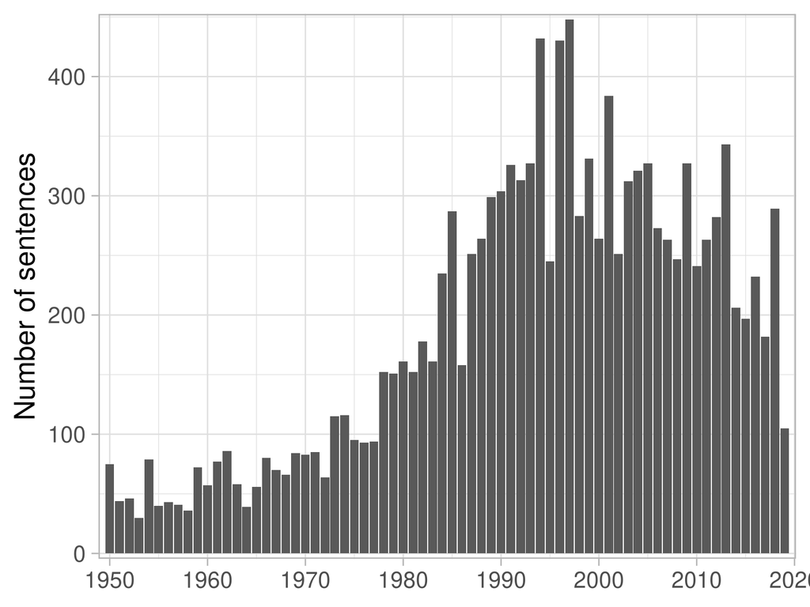

### Closest sentence from ‘rational’ and ‘rationality’ of the backbone community

| Sentence | Title | Year | Journal | Authors | Words Similarity |
| --- | --- | --- | --- | --- | --- |
| INTRODUCTION ALTHOUGH it has long been agreed that traditional economic theory “assumes” rational behavior, at one time there was considerable disagreement over the meaning of the word “rational.” | [Irrational Behavior and Economic Theory](http://www.jstor.org/stable/1827018) | 1962 | Journal of Political Economy | Gary S. Becker | 0.860 |
| Using this concept of rationalizability in the context of rational expectations equilibria, the question thus is whether such equilibria can be justified as a unique consequence of individual rational… | [Are Rational Expectations Equilibria with Private Information Eductively Stable?](http://www.jstor.org/stable/41795156) | 2004 | Journal of Economics | Maik Heinemann | 0.852 |
| A Turn to Rationality Some economic rationality is beginning to be used in analyzing objectives and means. | [Tomorrow’s Economic Order](http://www.jstor.org/stable/23480313) | 1969 | Business Economics | Yale Brozen | 0.849 |
| The present note reports a further case that might prove helpful in assessing the empirical relevance of the assumption of full rationality. | [A Piece of Evidence Regarding the Full Rationality of Economic Agents](http://www.jstor.org/stable/40752155) | 1999 | Journal of Institutional and Theoretical Economics (JITE) / Zeitschrift für die gesamte Staatswissenschaft | Tommaso Luzzati | 0.849 |
| A new concept of economic rationality evolves from this; it calls for provisos “for every possible conduct” of the other participants; that is, “its description must include rules of conduct for all c… | [Oligopolistic Indeterminacy](http://www.jstor.org/stable/40434383) | 1952 | Weltwirtschaftliches Archiv | Fritz Machlup | 0.846 |
| Instead, the intention of the paper is just to take a few initial steps toward a broad approach to rationality and 1 At an anonymous referee’s suggestion, the term “rationality” is avoided here when r… | [Conventional and Unconventional Behavior under Uncertainty](http://www.jstor.org/stable/4538865) | 2003 | Journal of Post Keynesian Economics | David Dequech | 0.845 |
| Royal Economic Society I I359 and the circumstances under which, human behaviour might be rational. | [Rationality, Learning and Social Norms](http://www.jstor.org/stable/2235527) | 1996 | The Economic Journal | Abhinay Muthoo | 0.844 |
| At the same time, I believe that specific deviations from rationality in the agents’ choices and in the agents’ processing of information potentially enhance the realism and economic analysis of certa… | [Rational Asset Prices](http://www.jstor.org/stable/3094517) | 2002 | The Journal of Finance | George M. Constantinides | 0.844 |
| The preference and informational meanings of the term rational are often commingled by modern economists so that rational individuals become characterized as persons having consistent and durable pref… | [The Political Economy of Gordon Tullock](http://www.jstor.org/stable/30026518) | 2004 | Public Choice | Roger D. Congleton | 0.844 |
| Rationality into Economics 531 new models of limited rationality into main stream empirical and theoretical economics. | [Incorporating Limited Rationality into Economics](http://www.jstor.org/stable/23644754) | 2013 | Journal of Economic Literature | Matthew Rabin | 0.844 |
| One qualification to this interpretation of economic rationality should be noted. | [Disguised Unemployment in Underdeveloped Economies](http://www.jstor.org/stable/2661834) | 1961 | Oxford Economic Papers | William J. Barber | 0.843 |
| Nevertheless, it is worth emphasizing that, for the purpose of this paper, rationality is an assumption that is explored and not a hypothesis that is tested. | [Peasants and Dualism with or without Surplus Labor](http://www.jstor.org/stable/1829592) | 1966 | Journal of Political Economy | Amartya K. Sen | 0.840 |
| ACCORDING TO THE theory of rational expec tations, the decisions of individuals and organi zations can be influenced by what they anticipate conditions will be like in the future.1 Recent events indic… | [Inflation Expectations: Recent Causes and Effects](http://www.jstor.org/stable/23481384) | 1977 | Business Economics | John J. Casson | 0.840 |
| The purpose of this restriction is to demonstrate that even if the instru mental conception of rationality is accepted as appropriate for economics, the main justifications for its adoption all entail… | [The source of optimality in action](http://www.jstor.org/stable/23599909) | 1997 | Cambridge Journal of Economics | J. W. Fedderke | 0.836 |
| Since models of bounded rationality do not rely on this assumption, deriving a similar empirically verifiable prediction of this paradigm is more dif- * Berk: School of Business Administration, Univer… | [The Price is Right, But are the Bids? An Investigation of Rational Decision Theory](http://www.jstor.org/stable/2118313) | 1996 | The American Economic Review | Jonathan B. Berk, Eric Hughson , Kirk Vandezande | 0.833 |
| First, we explore the idea of a rationality spillover. | [Experimental methods for environment and development economics](http://www.jstor.org/stable/44379045) | 2009 | Environment and Development Economics | MARIAH D. EHMKE , JASON F. SHOGREN | 0.832 |
| The hypothesis of economic rationality has been defended on the basis of a priori theoretical considerations, and it has been supported by casual empirical observations. | [The Empirical Content of Economic Rationality: A Test for a Less Developed Economy](http://www.jstor.org/stable/1837211) | 1969 | Journal of Political Economy | John Wise , Pan A. Yotopoulos | 0.831 |
| EVIDENCE The rationality hypothesis in economics has been the subject of much philosophical debate. | [On the Relevance of Learning and Evolution to Economic Theory](http://www.jstor.org/stable/2235529) | 1996 | The Economic Journal | Tilman Börgers | 0.831 |
| The structure of rational beliefs In most economic applications the concept of “rationality” must be understood with respect to statements about conditional probabilities. | [On the Structure and Diversity of Rational Beliefs](http://www.jstor.org/stable/25054813) | 1994 | Economic Theory | Mordecai Kurz | 0.831 |
| The various questions that have been raised about the rationality assumption appear to have legitimized and encouraged the development of economic theories that model departures from economic rational… | [A Psychological Perspective on Economics](http://www.jstor.org/stable/3132218) | 2003 | The American Economic Review | Daniel Kahneman | 0.831 |

### Closest sentences of the backbone community’s centroid

| Sentence | Title | Year | Journal | Authors | Centroid Similarity |
| --- | --- | --- | --- | --- | --- |
| 12 Let me shift from the abstract to the concrete and consider the attempt to apply the rationality postulate in the context of agricultural development in peasant societies, where I am on familiar te… | [Economy as Instituted Process: Change, Transformation, and Progress](http://www.jstor.org/stable/4226820) | 1994 | Journal of Economic Issues | John Adams | 0.7541001 |
| If one assumes that the necessary resources are available and that farm households take rational decisions, it is then expected that the household will undertake productive investment in agriculture i… | [Surplus Utilisation and Capital Formation in Bangladesh Agriculture](http://www.jstor.org/stable/40794300) | 1980 | The Bangladesh Development Studies | Atiqur Rahman | 0.7526054 |
| In this study, we would like to point to a much simpler explanation that, surprisingly, has not been mentioned in the discussions that have followed the circulation of the paper and that is fully cons… | [Holy Cows or Cash Cows? The Economic Return to Livestock in Rural India](http://www.jstor.org/stable/26545260) | 2018 | Economic Development and Cultural Change | ORAZIO ATTANASIO, BRITTA AUGSBURG | 0.7497106 |
| It has been claimed that there is no definition of “rational” such that rational individuals could be depended upon to make all and only the sorts of transactions Coase envisions.3 It has been argued … | [Coase’s Theorem and the Speculative Withholding of Land](http://www.jstor.org/stable/3145816) | 1985 | Land Economics | Walter Horn | 0.7490844 |
| The basic tenet of the architects of this strategy is that ‘farmers in developing countries are acting in a rational economic way’, which means that these farmers maximise profit according to the rule… | [Organisation of agriculture for rural development: the Indian case](http://www.jstor.org/stable/23596469) | 1978 | Cambridge Journal of Economics | Ashok Rudra | 0.7472950 |
| As the debate in the late 1970s between “political economists” and “moral economists” over peasant decision-making and the latter’s claim of a “subsistence ethic” as opposed to the former’s insistence… | [Conversion to Islam and Rational Choice Institutional Analysis: Comment](http://www.jstor.org/stable/40752984) | 1997 | Journal of Institutional and Theoretical Economics (JITE) / Zeitschrift für die gesamte Staatswissenschaft | K. S. Jomo | 0.7428177 |
| This assumption regarding farmer behavior provides simultaneously a rationale for the push for restrictive legislation against foreigners while satisfying the economists’ precept of rational behavior … | [Restriction of Farm Ownership as Rent-Seeking Behavior: Family Farmers Have It Their Way](http://www.jstor.org/stable/3486729) | 1984 | The American Journal of Economics and Sociology | David N. Laband | 0.7425462 |
| Rational Economic Perceptions and Priorities: Asodar In one of his perceptive papers, Professor Raymond Firth, the well-known anthropologist, has argued that in smaller units of operation farmers are … | [Cooperative Dairying and the Profiles of Social Change in India](http://www.jstor.org/stable/1153629) | 1978 | Economic Development and Cultural Change | A. H. Somjee, Geeta Somjee | 0.7406233 |
| To explain something like this, beginning with standard economic theory, at first sight it seems as if we need to give up the axiom of peasant rationality. | [One Kind of Power](http://www.jstor.org/stable/2663145) | 1986 | Oxford Economic Papers | Kaushik Basu | 0.7386627 |
| 2 The maintained hypothesis of this paper is that farmers are optimizing agents and that they have rational expectations. | [Human Capital, Adaptive Ability, and the Distributional Implications of Agricultural Policy](http://www.jstor.org/stable/1240714) | 1985 | American Journal of Agricultural Economics | Wallace E. Huffman | 0.7382257 |
| With startling suddenness this conservative farmer had seen all the inherent contradictions of the notion of value which had suddenly appeared on the surface-the absurdity of the situation, the utter … | [The Existence and Exercise of Corporate Power: An Opaque Fact](http://www.jstor.org/stable/4225943) | 1987 | Journal of Economic Issues | John R. Munkirs , Janet T. Knoedler | 0.7351748 |
| Taking into account the natural limitations to increase yields and the increasing control that the elites had over the land market, this attitude seems to be the most rational alternative to maximize … | [The Rain in Spain? Climate versus urban demand as causes of agricultural stagnation in eighteenth-century Spain](http://www.jstor.org/stable/43298628) | 2013 | European Review of Economic History | CARLOS SANTIAGO-CABALLERO | 0.7316840 |
| Appeal to irrational behavior is a handy escape when confronted with puzzling historical events, but, as a recent Nobel Prize winner has so eloquently shown for traditional agriculture, it has limits.… | [Some Myths Die Hard–Urban Disamenities One More Time: A Reply](http://www.jstor.org/stable/2120653) | 1981 | The Journal of Economic History | Jeffrey G. Williamson | 0.7293742 |
| Economic theory implies that economically rational farmers make input decisions as a function of the opportunity cost of inputs. | [Rice Technology, Farmer Rationality, and Agricultural Policy in Egypt](http://www.jstor.org/stable/1240454) | 1983 | American Journal of Agricultural Economics | John M. Antle, Ali S. Aitah | 0.7287189 |
| With startling suddenness this conservative farmer had seen all the inherent contradictions of the notion of value which had suddenly appeared on the surface-the absurdity of the situation, the utter … | [The Dichotomy: Views of a Fifth Generation Institutionalist](http://www.jstor.org/stable/4226068) | 1988 | Journal of Economic Issues | John R. Munkirs | 0.7269771 |

### Closest sentences of each kmean cluster’s centroid composing the backbone community

#### Top terms 6_57: rational_approach, rational_player, irrational, rational_behavior, irrationality (1950-1959)

| Sentence | Title | Year | Journal | Authors | Distance to Centroid |
| --- | --- | --- | --- | --- | --- |
| “32 Thus, the concept of rational behavior assumes an economic coloring. | [Individualism and Economic Theory](http://www.jstor.org/stable/3483667) | 1950 | The American Journal of Economics and Sociology | Walter A. Weisskopf | 6.926749 |
| We may hypothesize a continuum of rationality, with decisions ranging from those made purely on impulse to those which may be regarded as fully rational. | [Some Sociological Aspects of Occupational Choice](http://www.jstor.org/stable/3484558) | 1959 | The American Journal of Economics and Sociology | W. L. Slocum | 7.330957 |
| Much behavior which seems rational is better regarded as rationalizable. | [Conditions of American Technological Progress](http://www.jstor.org/stable/1818333) | 1954 | The American Economic Review | Irving H. Siegel | 7.462959 |
| Even if all economic behavior is not rational, economic theory argues in favor of the profitability of being rational. | [Science and Welfare in Economic Policy](http://www.jstor.org/stable/1884300) | 1959 | The Quarterly Journal of Economics | F. Zeuthen | 7.583864 |
| We can agree with Graham Wallas that human nature is largely irrational, but it is important not to forget his further conclusion that it is not completely irrational and that the quantity and quality… | [The Manipulation of Popular Impulse: Graham Wallas Revisited](http://www.jstor.org/stable/139059) | 1959 | The Canadian Journal of Economics and Political Science / Revue canadienne d’Economique et de Science politique | T. H. Qualter | 7.620781 |

#### Top terms 6_74: rationality_postulates, game_situations, economic_rationality, irrational_behavior, rational_behavior (1960-1969)

| Sentence | Title | Year | Journal | Authors | Distance to Centroid |
| --- | --- | --- | --- | --- | --- |
| INTRODUCTION ALTHOUGH it has long been agreed that traditional economic theory “assumes” rational behavior, at one time there was considerable disagreement over the meaning of the word “rational.” | [Irrational Behavior and Economic Theory](http://www.jstor.org/stable/1827018) | 1962 | Journal of Political Economy | Gary S. Becker | 6.749677 |
| Ever since, the assumption of “rational behavior”-with all its protean implications-has been a convenient and essential shorthand to describe a most complex set of elements which determine the making … | [An Economist’s Image of History](http://www.jstor.org/stable/1056650) | 1968 | Southern Economic Journal | Werner Hochwald | 7.170844 |
| argues that if people were known to behave rationally economists would have to place considerable emphasis on the rationality assumption. | [Rational Action and Economic Theory: A Reply to I. Kirzner](http://www.jstor.org/stable/1828378) | 1963 | Journal of Political Economy | Gary S. Becker | 7.297053 |
| We submit that our approach in fact does furnish an intuitively satisfactory and analytically fruitful concept of rational behavior. | [A General Theory of Rational Behavior in Game Situations](http://www.jstor.org/stable/1909772) | 1966 | Econometrica | John C. Harsanyi | 7.340513 |
| The hypothesis of economic rationality has been defended on the basis of a priori theoretical considerations, and it has been supported by casual empirical observations. | [The Empirical Content of Economic Rationality: A Test for a Less Developed Economy](http://www.jstor.org/stable/1837211) | 1969 | Journal of Political Economy | John Wise , Pan A. Yotopoulos | 7.378427 |

#### Top terms 6_91: bounded_rationality, bounded, rationality_postulates, rationality_hypothesis, rationality_conditions (1970-1979)

| Sentence | Title | Year | Journal | Authors | Distance to Centroid |
| --- | --- | --- | --- | --- | --- |
| In this note, we argue that, within Scott’s framework, such an assumption is inconsistent with the notion of rationality on the part of individuals. | [Bankruptcy, Secured Debt, and Optimal Capital Structure: Comment](http://www.jstor.org/stable/2327158) | 1979 | The Journal of Finance | Clifford W. Smith, Jr., Jerold B. Warner | 7.131517 |
| “26 A number of controversies in the social sciences, especially as it pertains to the problem of rationality, are due to the making of elliptical judgments on the respective rationality or irrational… | [Methodological Problems in Contrasting Economic Systems](http://www.jstor.org/stable/3485238) | 1970 | The American Journal of Economics and Sociology | Horst K. Betz, E. K. Hunt | 7.220813 |
| RICHARD T. ELY LECTURE Rationality as Process and as Product of Thought B, HERBERT A. SIMON:~ This opportunity to deliver the Richard T. Ely Lecture affords me some very personal satisfactions. | [Rationality as Process and as Product of Thought](http://www.jstor.org/stable/1816653) | 1978 | The American Economic Review | Herbert A. Simon | 7.402085 |
| However, the implications of more “rationality” will be considered, as well as whether the label is always being correctly applied.4 Two related ideas will be presented. | [Contract Theory and the Moderation of Inflation by Recession and by Controls](http://www.jstor.org/stable/2534370) | 1976 | Brookings Papers on Economic Activity | Martin Neil Baily , William D. Nordhaus, Christopher A. Sims | 7.540513 |
| Further, the rationality or irrationality of an economic decision may depend on one’s point of view. | [Employment Implications of Industrialisation in Developing Countries: A Survey](http://www.jstor.org/stable/2231038) | 1974 | The Economic Journal | David Morawetz | 7.562441 |

#### Top terms 6_95: bounded, bounded_rationality, individual_rationality, individually_rational, players (1980-1989)

| Sentence | Title | Year | Journal | Authors | Distance to Centroid |
| --- | --- | --- | --- | --- | --- |
| Rationality is an immensely rich, complex, and subtle notion, and I certainly will not pretend to offer a completely satisfactory definition of it in this paper. | [Economic Theory and the Problem of Translation: Part Two](http://www.jstor.org/stable/4225251) | 1982 | Journal of Economic Issues | Ken Dennis | 7.002877 |
| Russell and Thaler consider the nature of equilibria conditions in markets with some agents who are not rational. | [An Examination of Farm Sector Real Asset Dynamics: 1910-85](http://www.jstor.org/stable/1241689) | 1987 | American Journal of Agricultural Economics | Allen M. Featherstone, Timothy G. Baker | 7.245123 |
| If rationality is not identical to the means-end characterization given it within positivistic scientific economics, then it is possible that despite its non-positivistic scientific character, economi… | [The Non-Rational Domain and the Limits of Economic Analysis: Comment](http://www.jstor.org/stable/1058171) | 1981 | Southern Economic Journal | Tibor R. Machan | 7.274371 |
| Individuals behave rationally in that they weigh the costs and benefits of their options. | [Chameleon Voters and Public Choice](http://www.jstor.org/stable/30024732) | 1987 | Public Choice | Timur Kuran | 7.326014 |
| In short, economic agents behave “rationally”. | [The Effectiveness of Orderly Marketing Agreements: The Color TV Case](http://www.jstor.org/stable/23482636) | 1983 | Business Economics | Victor A. Canto , Arthur B. Laffer | 7.352237 |

#### Top terms 6_113: rational_choice, individual_rationality, choice_theory, realisation_process, economic_sociology (1990-1999)

| Sentence | Title | Year | Journal | Authors | Distance to Centroid |
| --- | --- | --- | --- | --- | --- |
| I am greatly endebted to Amos Tversky for many discussions of the issue of rationality over the years, and for insightful comments on drafts of this paper. | [New Challenges to the Rationality Assumption](http://www.jstor.org/stable/40753012) | 1994 | Journal of Institutional and Theoretical Economics (JITE) / Zeitschrift für die gesamte Staatswissenschaft | Daniel Kahneman | 6.707518 |
| Economists routinely assume that people are rational when they make decisions: they maximize utility, they rationally maximize profits, and so on. | [New-Keynesian Economics Today: The Empire Strikes Back](http://www.jstor.org/stable/25604023) | 1995 | The American Economist | Brian Snowdon, Howard Vane | 6.935596 |
| This article will argue for an enriched definition of rationality that considers the actual outcomes of decisions, and will present evidence that challenges the rationality assumption in new ways. | [New Challenges to the Rationality Assumption](http://www.jstor.org/stable/40753012) | 1994 | Journal of Institutional and Theoretical Economics (JITE) / Zeitschrift für die gesamte Staatswissenschaft | Daniel Kahneman | 7.019416 |
| An attempt is made to generate new insights here by applying findings of rational choice theory. | [Pay and Political Participation in Classical Athens: An Empirical Application of Rational Choice Theory](http://www.jstor.org/stable/40751630) | 1993 | Journal of Institutional and Theoretical Economics (JITE) / Zeitschrift für die gesamte Staatswissenschaft | Stephan Podes | 7.100177 |
| Introduction * Richard Quandt contributed actively to three important developments in rational choice theory. | [Linear Probability Models of the Demand for Attributes with an Empirical Application to Estimating the Preferences of Legislators](http://www.jstor.org/stable/3087459) | 1997 | The RAND Journal of Economics | James J. Heckman , James M. Snyder Jr. | 7.192440 |

#### Top terms 6_122: bounded, bounded_rationality, boundedly, boundedly_rational, unbounded_rationality (1990-1999)

| Sentence | Title | Year | Journal | Authors | Distance to Centroid |
| --- | --- | --- | --- | --- | --- |
| 51 General analysis of “bounded rationality,” pioneered by Herbert Simon, has transformed, in many ways, our understanding of what it is to be rational in a world of limited epistemic, cognitive, and … | [Maximization and the Act of Choice](http://www.jstor.org/stable/2171939) | 1997 | Econometrica | Amartya Sen | 5.690129 |
| Introduction Bounded rationality is by now a term so widely accepted that it is probably here to stay. | [Homo Socio-oeconomicus: The Emergence of a General Model of Man in the Social Sciences](http://www.jstor.org/stable/40751361) | 1990 | Journal of Institutional and Theoretical Economics (JITE) / Zeitschrift für die gesamte Staatswissenschaft | Siegwart Lindenberg | 6.185403 |
| Introduction When the organizer of this conference on “Bounded Rationality” invited me to participate, I responded with the suggestion that I might write something on “Rationally Bounded Rationality.” | [Choosing What to Choose](http://www.jstor.org/stable/40753025) | 1994 | Journal of Institutional and Theoretical Economics (JITE) / Zeitschrift für die gesamte Staatswissenschaft | James M. Buchanan | 6.213390 |
| All of this body of research may be seen as part of the important multi pronged effort aimed at addressing the multi-sided nature of a quite “slippery” concept: bounded rationality. | [Simple and Inertial Behavior: An Optimizing Decision Model with Imprecise Perceptions](http://www.jstor.org/stable/25054682) | 1993 | Economic Theory | Fernando Vega-Redondo | 6.277686 |
| In this essay I shall try to provide a taxonomy of bounded rationality that is more detailed than one usually finds in discussions of the topic by economic theorists. | [Bounded Rationality, Indeterminacy, and the Theory of the Firm](http://www.jstor.org/stable/2235528) | 1996 | The Economic Journal | Roy Radner | 6.314601 |

#### Top terms 6_130: bounded, bounded_rationality, individual_rationality, collective_rationality, rationality (2000-2009)

| Sentence | Title | Year | Journal | Authors | Distance to Centroid |
| --- | --- | --- | --- | --- | --- |
| 3 September 2001 John R. Commons and Herbert A. Simon on the Concept of Rationality Joelle Forest and Caroline Mehier H. A. Simon and J. R. Commons are known to have been influenced by an intellectual… | [John R. Commons and Herbert A. Simon on the Concept of Rationality](http://www.jstor.org/stable/4227692) | 2001 | Journal of Economic Issues | Joëlle Forest , Caroline Mehier | 6.449675 |
| Rationality is not detached from the world; it is situated in and operates through specific cues, triggers and constraints. | [Presidential Address: The Revival of Veblenian Institutional Economics](http://www.jstor.org/stable/25511183) | 2007 | Journal of Economic Issues | Geoffrey M. Hodgson | 6.861674 |
| I Introduction FOR SOME TIME NOW THERE HAS BEEN a growing unease among mainstream economists concerning the very limited nature of rationality in economics. | [Social Circumstances and Rationality: Some Lessons from Adam Smith Why We May Not All Be Equally Sovereign](http://www.jstor.org/stable/3488050) | 2005 | The American Journal of Economics and Sociology | Amos Witztum | 6.878184 |
| “Combining the Results of Rationality Studies: What Did We Know and When Did We Know It?” | [Meta-Analysis](http://www.jstor.org/stable/3216959) | 2002 | The Journal of Economic Perspectives | Robert S. Goldfarb, H. O. Stekler , David Neumark , William Wascher | 6.936159 |
| A revealed preference characterization of dd-rationality is still an open question. | [Consumer Choice and Revealed Bounded Rationality](http://www.jstor.org/stable/40283069) | 2009 | Economic Theory | Paola Manzini , Marco Mariotti | 7.006056 |

#### Top terms 6_150: bounded, bounded_rationality, ability_workers, rational_choice, individual_rationality (2010-2019)

| Sentence | Title | Year | Journal | Authors | Distance to Centroid |
| --- | --- | --- | --- | --- | --- |
| Introduction Economists only recently departed from the rational man and the notion of common knowledge of rationality when theorizing on economic problems. | [THE NEUROECONOMICS OF DEPTH OF STRATEGIC REASONING](http://www.jstor.org/stable/23723789) | 2010 | History of Economic Ideas | Giorgio Coricelli, Rosemarie Nagel | 7.002646 |
| “John R. Commons and Herbert A. Simon on the Concept of Rationality.” | [Has Anything Changed in the Past Century? Revisiting Graue’s “The Social Cost of Bad Debt”](http://www.jstor.org/stable/23071532) | 2011 | Journal of Economic Issues | Dan Friesner , Donald Hackney , Matthew McPherson, Dan Axelsen | 7.078874 |
| Our results fit well into the concept of bounded rationality in the sense that subjects behave in a sensible way, but fail to achieve full rationality. | [Information, Learning and Expectations in an Experimental Model Economy](http://www.jstor.org/stable/24029608) | 2013 | Economica | Michael W. M. Roos, Wolfgang J. Luhan | 7.111689 |
| Hildenbrand’s market-level results do not come from the extension of rational individual behavior to markets or entire economies, but rather from moving away from any form of rational utility maximiza… | [Conundrums of the representative agent](http://www.jstor.org/stable/26784188) | 2017 | Cambridge Journal of Economics | D. Wade Hands | 7.189031 |
| Some of the conclusions reached in the full rationality paradigm sound unin tuitive. | [Social Learning with Coarse Inference](http://www.jstor.org/stable/23358354) | 2013 | American Economic Journal: Microeconomics | Antonio Guarino, Philippe Jehiel | 7.219245 |

### Top articles (most sentences) of the backbone cluster

| Title | Year | Journal | Authors | Number sentences | Words Similarity |
| --- | --- | --- | --- | --- | --- |
| [Why Bounded Rationality?](http://www.jstor.org/stable/2729218) | 1996 | Journal of Economic Literature | John Conlisk | 65 | 0.691 |
| [Is There a Place for the Rational Actor? A Geographical Critique of the Rational Choice Paradigm](http://www.jstor.org/stable/144038) | 1992 | Economic Geography | Trevor J. Barnes, Eric Sheppard | 64 | 0.647 |
| [Rational Choice: A Survey of Contributions from Economics and Philosophy](http://www.jstor.org/stable/2233854) | 1991 | The Economic Journal | Robert Sugden | 50 | 0.654 |
| [The source of optimality in action](http://www.jstor.org/stable/23599909) | 1997 | Cambridge Journal of Economics | J. W. Fedderke | 50 | 0.683 |
| [Rationality, Bounded or not, and Institutional Analysis](http://www.jstor.org/stable/40751359) | 1990 | Journal of Institutional and Theoretical Economics (JITE) / Zeitschrift für die gesamte Staatswissenschaft | Ekkehart Schlicht | 44 | 0.656 |
| [Social Dimensions of Individualistic Rationality](http://www.jstor.org/stable/23245228) | 2012 | The American Journal of Economics and Sociology | Amos Witztum | 43 | 0.663 |
| [On Institutional Rationality](http://www.jstor.org/stable/4227993) | 2004 | Journal of Economic Issues | William H. Redmond | 40 | 0.646 |
| [Irrational Behavior and Economic Theory](http://www.jstor.org/stable/1827018) | 1962 | Journal of Political Economy | Gary S. Becker | 39 | 0.692 |
| [On the Status of the Nash Type of Noncooperative Equilibrium in Economic Theory](http://www.jstor.org/stable/3439426) | 1982 | The Scandinavian Journal of Economics | Leif Johansen | 39 | 0.667 |
| [Veblen and the Problem of Rationality](http://www.jstor.org/stable/25511231) | 2007 | Journal of Economic Issues | Ferudun Yılmaz | 35 | 0.647 |
| [Rational Irrationality: A Framework for the Neoclassical-Behavioral Debate](http://www.jstor.org/stable/40325987) | 2000 | Eastern Economic Journal | Bryan Caplan | 34 | 0.683 |
| [The discourse of bounded rationality in academic and policy arenas: pathologising the errant consumer](http://www.jstor.org/stable/23602006) | 2013 | Cambridge Journal of Economics | Judith Mehta | 34 | 0.671 |
| [The Meaning of Rationality in the Social Sciences](http://www.jstor.org/stable/40750743) | 1984 | Zeitschrift für die gesamte Staatswissenschaft / Journal of Institutional and Theoretical Economics | Joseph A. Schumpeter | 33 | 0.645 |
| [MODELING RATIONAL AGENTS THE CONSISTENCY VIEW OF RATIONALITY AND THE CHANGING IMAGE OF NEOCLASSICAL ECONOMICS](http://www.jstor.org/stable/43107641) | 2005 | Cahiers d’économie politique / Papers in Political Economy | Nicola Giocoli | 31 | 0.669 |
| [On the Relevance of Learning and Evolution to Economic Theory](http://www.jstor.org/stable/2235529) | 1996 | The Economic Journal | Tilman Börgers | 30 | 0.682 |

### Top articles (most sentences) of the cluster for each time window

#### Top articles for 6_57: rational_approach, rational_player, irrational, rational_behavior, irrationality (1950-1959)

| Title | Year | Journal | Authors | Number sentences | Words Similarity |
| --- | --- | --- | --- | --- | --- |
| [Irrationality in Economics](http://www.jstor.org/stable/1881874) | 1954 | The Quarterly Journal of Economics | Louis Baudin | 22 | 0.661 |
| [Individualism and Economic Theory](http://www.jstor.org/stable/3483667) | 1950 | The American Journal of Economics and Sociology | Walter A. Weisskopf | 12 | 0.721 |
| [For the Abandonment of Symmetry in Game Theory](http://www.jstor.org/stable/1927448) | 1959 | The Review of Economics and Statistics | T. C. Schelling | 12 | 0.647 |
| [A Behavioral Model of Rational Choice](http://www.jstor.org/stable/1884852) | 1955 | The Quarterly Journal of Economics | Herbert A. Simon | 10 | 0.673 |
| [Theory of the Reluctant Duelist](http://www.jstor.org/stable/1811911) | 1956 | The American Economic Review | Daniel Ellsberg | 10 | 0.646 |
| [An Economic Theory of Political Action in a Democracy](http://www.jstor.org/stable/1827369) | 1957 | Journal of Political Economy | Anthony Downs | 9 | 0.650 |
| [Rational Selection of Decision Functions](http://www.jstor.org/stable/1907435) | 1954 | Econometrica | Herman Chernoff | 8 | 0.675 |
| [Economics and the Social Sciences](http://www.jstor.org/stable/2226710) | 1950 | The Economic Journal | A. G. Papandreou | 6 | 0.676 |
| [Rational Behavior, Uncertain Prospects, and Measurable Utility](http://www.jstor.org/stable/1907264) | 1950 | Econometrica | Jacob Marschak | 6 | 0.624 |
| [The Potential Contribution of Sociological Theory and Research to Economics](http://www.jstor.org/stable/3484606) | 1952 | The American Journal of Economics and Sociology | Arnold M. Rose | 6 | 0.672 |

#### Top articles for 6_74: rationality_postulates, game_situations, economic_rationality, irrational_behavior, rational_behavior (1960-1969)

| Title | Year | Journal | Authors | Number sentences | Words Similarity |
| --- | --- | --- | --- | --- | --- |
| [Irrational Behavior and Economic Theory](http://www.jstor.org/stable/1827018) | 1962 | Journal of Political Economy | Gary S. Becker | 39 | 0.692 |
| [A General Theory of Rational Behavior in Game Situations](http://www.jstor.org/stable/1909772) | 1966 | Econometrica | John C. Harsanyi | 19 | 0.657 |
| [The Empirical Content of Economic Rationality: A Test for a Less Developed Economy](http://www.jstor.org/stable/1837211) | 1969 | Journal of Political Economy | John Wise , Pan A. Yotopoulos | 19 | 0.712 |
| [Bargaining and Conflict Situations in the Light of a New Approach to Game Theory](http://www.jstor.org/stable/1816287) | 1965 | The American Economic Review | John C. Harsanyi | 16 | 0.675 |
| [The Possibility of a Social Welfare Function](http://www.jstor.org/stable/1815299) | 1966 | The American Economic Review | James S. Coleman | 16 | 0.650 |
| [On Merit Goods](http://www.jstor.org/stable/40909986) | 1966 | FinanzArchiv / Public Finance Analysis | John G. Head | 15 | 0.651 |
| [American Unionism: From Protest to Going Concern](http://www.jstor.org/stable/4223896) | 1968 | Journal of Economic Issues | Jack Barbash | 11 | 0.634 |
| [Rational Expectations and the Theory of Price Movements](http://www.jstor.org/stable/1909635) | 1961 | Econometrica | John F. Muth | 9 | 0.673 |
| [The Changing Moral Temper of Economic Thought](http://www.jstor.org/stable/41796158) | 1961 | Zeitschrift für Nationalökonomie / Journal of Economics | Walter A. Weißkopf | 8 | 0.723 |
| [Distortion of Subjective Probabilities as a Reaction to Uncertainty](http://www.jstor.org/stable/1884325) | 1961 | The Quarterly Journal of Economics | William Fellner | 8 | 0.649 |

#### Top articles for 6_91: bounded_rationality, bounded, rationality_postulates, rationality_hypothesis, rationality_conditions (1970-1979)

| Title | Year | Journal | Authors | Number sentences | Words Similarity |
| --- | --- | --- | --- | --- | --- |
| [Rationality as Process and as Product of Thought](http://www.jstor.org/stable/1816653) | 1978 | The American Economic Review | Herbert A. Simon | 26 | 0.673 |
| [Ordinal Preference and Rational Choice](http://www.jstor.org/stable/1913486) | 1973 | Econometrica | Hans G. Herzberger | 20 | 0.648 |
| [Social Evaluation Through Notional Choice](http://www.jstor.org/stable/1881825) | 1974 | The Quarterly Journal of Economics | Sidney S. Alexander | 14 | 0.630 |
| [Rational Decision Making in Business Organizations](http://www.jstor.org/stable/1808698) | 1979 | The American Economic Review | Herbert A. Simon | 14 | 0.650 |
| [Bargain and Contract Theory in Law and Economics](http://www.jstor.org/stable/4224465) | 1976 | Journal of Economic Issues | S. Todd Lowry | 12 | 0.653 |
| [The Non-Rational Domain and the Limits of Economic Analysis](http://www.jstor.org/stable/1057009) | 1979 | Southern Economic Journal | Richard B. McKenzie | 9 | 0.680 |
| [Synoptic versus Incremental Scholarly Advice in Economic Policy: Some Implications of So-Called “Rational” Tax Systems](http://www.jstor.org/stable/40910769) | 1970 | FinanzArchiv / Public Finance Analysis | Gunther Engelhardt | 8 | 0.622 |
| [Rational Expectations in the Macro Model](http://www.jstor.org/stable/2534381) | 1976 | Brookings Papers on Economic Activity | William Poole , Edmund S. Phelps, Martin N. Baily | 8 | 0.650 |
| [Bayesian Decision Theory and Utilitarian Ethics](http://www.jstor.org/stable/1816692) | 1978 | The American Economic Review | John C. Harsanyi | 8 | 0.635 |
| [Manias, Panics, and Rationality](http://www.jstor.org/stable/20642310) | 1978 | Eastern Economic Journal | Charles P. Kindleberger | 8 | 0.670 |

#### Top articles for 6_95: bounded, bounded_rationality, individual_rationality, individually_rational, players (1980-1989)

| Title | Year | Journal | Authors | Number sentences | Words Similarity |
| --- | --- | --- | --- | --- | --- |
| [On the Status of the Nash Type of Noncooperative Equilibrium in Economic Theory](http://www.jstor.org/stable/3439426) | 1982 | The Scandinavian Journal of Economics | Leif Johansen | 39 | 0.667 |
| [The Meaning of Rationality in the Social Sciences](http://www.jstor.org/stable/40750743) | 1984 | Zeitschrift für die gesamte Staatswissenschaft / Journal of Institutional and Theoretical Economics | Joseph A. Schumpeter | 33 | 0.645 |
| [The Relevance of Quasi Rationality in Competitive Markets](http://www.jstor.org/stable/1818646) | 1985 | The American Economic Review | Thomas Russell, Richard Thaler | 26 | 0.657 |
| [Rationalizable Strategic Behavior](http://www.jstor.org/stable/1911196) | 1984 | Econometrica | B. Douglas Bernheim | 21 | 0.664 |
| [Axiomatic Characterizations of Rational Choice in Strategic Environments](http://www.jstor.org/stable/3440381) | 1986 | The Scandinavian Journal of Economics | B. Douglas Bernheim | 21 | 0.647 |
| [Knowledge and Rationality in the Austrian School: An Analytical Survey](http://www.jstor.org/stable/40324999) | 1985 | Eastern Economic Journal | Richard N. Langlois | 19 | 0.652 |
| [Max Weber’s Authority Models and the Theory of X-Inefficiency: The Economic Sociologist’s Analysis Adds More Structure to Leibenstein’s Critique of Rationality](http://www.jstor.org/stable/3487550) | 1989 | The American Journal of Economics and Sociology | Stanley Vanagunas | 18 | 0.658 |
| [The Rationalist Conception of Action](http://www.jstor.org/stable/4225646) | 1985 | Journal of Economic Issues | Geoff Hodgson | 17 | 0.644 |
| [Expecting and Affecting](http://www.jstor.org/stable/2663333) | 1989 | Oxford Economic Papers | Michael Bacharach | 14 | 0.674 |
| [Bargaining and the Sources of Transaction Costs: The Case of Government Regulation](http://www.jstor.org/stable/764805) | 1987 | Journal of Law, Economics, & Organization | Douglas D. Heckathorn, Steven M. Maser | 13 | 0.634 |

#### Top articles for 6_113: rational_choice, individual_rationality, choice_theory, realisation_process, economic_sociology (1990-1999)

| Title | Year | Journal | Authors | Number sentences | Words Similarity |
| --- | --- | --- | --- | --- | --- |
| [Is There a Place for the Rational Actor? A Geographical Critique of the Rational Choice Paradigm](http://www.jstor.org/stable/144038) | 1992 | Economic Geography | Trevor J. Barnes, Eric Sheppard | 64 | 0.647 |
| [The source of optimality in action](http://www.jstor.org/stable/23599909) | 1997 | Cambridge Journal of Economics | J. W. Fedderke | 47 | 0.685 |
| [Rational Choice: A Survey of Contributions from Economics and Philosophy](http://www.jstor.org/stable/2233854) | 1991 | The Economic Journal | Robert Sugden | 46 | 0.657 |
| [On the Relevance of Learning and Evolution to Economic Theory](http://www.jstor.org/stable/2235529) | 1996 | The Economic Journal | Tilman Börgers | 30 | 0.682 |
| [Rationality, Bounded or not, and Institutional Analysis](http://www.jstor.org/stable/40751359) | 1990 | Journal of Institutional and Theoretical Economics (JITE) / Zeitschrift für die gesamte Staatswissenschaft | Ekkehart Schlicht | 26 | 0.651 |
| [Economic Sociology in Retrospect and Prospect: In Search of Its Identity within Economics and Sociology](http://www.jstor.org/stable/3487999) | 1999 | The American Journal of Economics and Sociology | Milan Zafirovski | 24 | 0.633 |
| [Collective Action and Rational Choice: Place, Community, and the Limits to Individual Self-Interest](http://www.jstor.org/stable/144039) | 1992 | Economic Geography | Byron Miller | 23 | 0.626 |
| [Selecting Social Goals: Alternative Concepts of Rationality: Both the Orthodox and the Heterodox Must Be Able to Explain the Origin and Significance of Values](http://www.jstor.org/stable/3487542) | 1990 | The American Journal of Economics and Sociology | Robert D. Ley, L. E. Johnson | 21 | 0.652 |
| [New Challenges to the Rationality Assumption](http://www.jstor.org/stable/40753012) | 1994 | Journal of Institutional and Theoretical Economics (JITE) / Zeitschrift für die gesamte Staatswissenschaft | Daniel Kahneman | 21 | 0.686 |
| [Taking Ethics Seriously: Economics and Contemporary Moral Philosophy](http://www.jstor.org/stable/2728513) | 1993 | Journal of Economic Literature | Daniel M. Hausman , Michael S. McPherson | 18 | 0.645 |

#### Top articles for 6_122: bounded, bounded_rationality, boundedly, boundedly_rational, unbounded_rationality (1990-1999)

| Title | Year | Journal | Authors | Number sentences | Words Similarity |
| --- | --- | --- | --- | --- | --- |
| [Why Bounded Rationality?](http://www.jstor.org/stable/2729218) | 1996 | Journal of Economic Literature | John Conlisk | 55 | 0.694 |
| [Bounded Rationality](http://www.jstor.org/stable/40751353) | 1990 | Journal of Institutional and Theoretical Economics (JITE) / Zeitschrift für die gesamte Staatswissenschaft | Reinhard Selten | 18 | 0.672 |
| [Rationality, Bounded or not, and Institutional Analysis](http://www.jstor.org/stable/40751359) | 1990 | Journal of Institutional and Theoretical Economics (JITE) / Zeitschrift für die gesamte Staatswissenschaft | Ekkehart Schlicht | 18 | 0.663 |
| [Legal Responses to Bounded Rationality in German Administration](http://www.jstor.org/stable/40753028) | 1994 | Journal of Institutional and Theoretical Economics (JITE) / Zeitschrift für die gesamte Staatswissenschaft | Christoph Engel | 18 | 0.660 |
| [Decision Theory without Logical Omniscience: Toward an Axiomatic Framework for Bounded Rationality](http://www.jstor.org/stable/2566994) | 1999 | The Review of Economic Studies | Barton L. Lipman | 16 | 0.686 |
| [On Bounded Rationality: Experimental Work at the University of Frankfurt/Main](http://www.jstor.org/stable/40751354) | 1990 | Journal of Institutional and Theoretical Economics (JITE) / Zeitschrift für die gesamte Staatswissenschaft | Reinhard Tietz | 14 | 0.667 |
| [How to Decide How to Decide How to…: Modeling Limited Rationality](http://www.jstor.org/stable/2938176) | 1991 | Econometrica | Barton L. Lipman | 14 | 0.700 |
| [Institutional Economics and the Evolutionary Metaphor](http://www.jstor.org/stable/40751943) | 1996 | Journal of Institutional and Theoretical Economics (JITE) / Zeitschrift für die gesamte Staatswissenschaft | Gisela Kubon-Gilke | 12 | 0.695 |
| [Sargent versus Simon: bounded rationality unbound](http://www.jstor.org/stable/23599908) | 1997 | Cambridge Journal of Economics | Esther-Mirjam Sent | 12 | 0.652 |
| [Reason, Bounded Rationality, and the Lebenswelt: Socially Sensitive Decision Making](http://www.jstor.org/stable/3487312) | 1992 | The American Journal of Economics and Sociology | John W. Murphy | 11 | 0.636 |

#### Top articles for 6_130: bounded, bounded_rationality, individual_rationality, collective_rationality, rationality (2000-2009)

| Title | Year | Journal | Authors | Number sentences | Words Similarity |
| --- | --- | --- | --- | --- | --- |
| [On Institutional Rationality](http://www.jstor.org/stable/4227993) | 2004 | Journal of Economic Issues | William H. Redmond | 40 | 0.646 |
| [Veblen and the Problem of Rationality](http://www.jstor.org/stable/25511231) | 2007 | Journal of Economic Issues | Ferudun Yılmaz | 35 | 0.647 |
| [Rational Irrationality: A Framework for the Neoclassical-Behavioral Debate](http://www.jstor.org/stable/40325987) | 2000 | Eastern Economic Journal | Bryan Caplan | 34 | 0.683 |
| [MODELING RATIONAL AGENTS THE CONSISTENCY VIEW OF RATIONALITY AND THE CHANGING IMAGE OF NEOCLASSICAL ECONOMICS](http://www.jstor.org/stable/43107641) | 2005 | Cahiers d’économie politique / Papers in Political Economy | Nicola Giocoli | 31 | 0.669 |
| [Karl Mannheim, Max Weber, and the Problem of Social Rationality in Thorstein Veblen](http://www.jstor.org/stable/4227992) | 2004 | Journal of Economic Issues | Rick Tilman | 29 | 0.635 |
| [Weber and Veblen on the Rationalization Process](http://www.jstor.org/stable/25511413) | 2009 | Journal of Economic Issues | Cyril Hedoin | 26 | 0.622 |
| [John R. Commons and Herbert A. Simon on the Concept of Rationality](http://www.jstor.org/stable/4227692) | 2001 | Journal of Economic Issues | Joëlle Forest , Caroline Mehier | 22 | 0.668 |
| [Bounded Rationality, Institutions, and Uncertainty](http://www.jstor.org/stable/4227723) | 2001 | Journal of Economic Issues | David Dequech | 21 | 0.683 |
| [Combining the Results of Rationality Studies: What Did We know and When Did We know It?](http://www.jstor.org/stable/29794238) | 2001 | Indian Economic Review | ROBERT S. GOLDFARB, H.O. STEKLER | 21 | 0.646 |
| [THE HICKSIAN RATIONAL CONSUMER](http://www.jstor.org/stable/43107640) | 2005 | Cahiers d’économie politique / Papers in Political Economy | Manuel Fernández-Grela | 20 | 0.686 |

#### Top articles for 6_150: bounded, bounded_rationality, ability_workers, rational_choice, individual_rationality (2010-2019)

| Title | Year | Journal | Authors | Number sentences | Words Similarity |
| --- | --- | --- | --- | --- | --- |
| [Social Dimensions of Individualistic Rationality](http://www.jstor.org/stable/23245228) | 2012 | The American Journal of Economics and Sociology | Amos Witztum | 43 | 0.663 |
| [The discourse of bounded rationality in academic and policy arenas: pathologising the errant consumer](http://www.jstor.org/stable/23602006) | 2013 | Cambridge Journal of Economics | Judith Mehta | 34 | 0.671 |
| [Two conceptions of economics and maximisation](http://www.jstor.org/stable/23601728) | 2013 | Cambridge Journal of Economics | Ricardo F. Crespo | 30 | 0.677 |
| [Companies and markets: economic theories of the firm and a concept of companies as bargaining agencies](http://www.jstor.org/stable/24915748) | 2016 | Cambridge Journal of Economics | Patrick Spread | 25 | 0.686 |
| [Labor Market Signaling and Self-Confidence: Wage Compression and the Gender Pay Gap](http://www.jstor.org/stable/10.1086/666646) | 2012 | Journal of Labor Economics | Luís Santos-Pinto | 19 | 0.626 |
| [The Social Cost of Near-Rational Investment](http://www.jstor.org/stable/44251587) | 2017 | The American Economic Review | Tarek A. Hassan , Thomas M. Mertens | 19 | 0.681 |
| [On the Rationality of Team Reasoning and Some of its Normative Implications](http://www.jstor.org/stable/26596218) | 2018 | Revue d’économie politique | Cyril Hédoin | 18 | 0.650 |
| [RATIONALITY AND RULES: BEHAVIORAL FOUNDATIONS AND POLICY IMPLICATIONS](http://www.jstor.org/stable/44806118) | 2016 | History of Economic Ideas | Viktor J. Vanberg | 17 | 0.674 |
| [OBJECTIVE AND SUBJECTIVE RATIONALITY IN A MULTIPLE PRIOR MODEL](http://www.jstor.org/stable/40664491) | 2010 | Econometrica | Itzhak Gilboa , Fabio Maccheroni , Massimo Marinacci, David Schmeidler | 16 | 0.663 |
| [Incorporating Limited Rationality into Economics](http://www.jstor.org/stable/23644754) | 2013 | Journal of Economic Literature | Matthew Rabin | 16 | 0.703 |

### Most cited references in the backbone community

| First Author | Year | Journal | Citation by article | Citation by sentence |
| --- | --- | --- | --- | --- |
| SELTEN-R | 1975 | INT J GAME THEORY | 14 | 322 |
| SIMON-H | 1955 | Q J EC | 2 | 162 |
| HAUSMAN-J | 1979 | BELL J EC | 2 | 162 |
| BUSH-P | 1993 | I EC THEORY METHOD P | 2 | 150 |
| SIMON-H | 1951 | ECONOMETRICA | 2 | 72 |
| NASH-J | 1950 | ECONOMICTRICA | 2 | 62 |
| NASH-J | 1953 | ECONOMETRICA | 2 | 62 |
| HARSANYI-J | 1956 | ECONOMETRICA | 2 | 62 |
| PEARCE-D | 1984 | ECONOMETRICA | 2 | 42 |
| MYERSON-R | 1978 | INT J GAME THEORY | 2 | 42 |

| First Author | Year | Journal | Citation by article | Citation by sentence |
| --- | --- | --- | --- | --- |
| WILLIAMSON-O | 1975 | MARKETS HIERARCHIES | 134 | 16884 |
| WILLIAMSON-O | 1985 | EC I CAPITALISM FIRM | 158 | 16116 |
| NELSON-R | 1982 | EVOLUTIONARY THEORY | 77 | 9856 |
| SAVAGE-L | 1954 | FDN STAT | 62 | 8556 |
| BECKER-G | 1976 | EC APPROACH HUMAN BE | 56 | 8344 |
| FRIEDMAN-M | 1953 | ESSAYS POSITIVE EC | 52 | 4056 |
| RAWLS-J | 1971 | THEORY JUSTICE | 40 | 3600 |
| KREPS-D | 1990 | COURSE MICROECONOMIC | 53 | 3445 |
| KEYNES-J | 1936 | GEN THEORY EMPLOYMEN | 71 | 3195 |
| OLSON-M | 1965 | LOGIC COLLECTIVE ACT | 40 | 2560 |
| SCHELLING-T | 1960 | STRATEGY CONFLICT | 35 | 2345 |
| ARROW-K | 1951 | SOCIAL CHOICE INDIVI | 26 | 2080 |
| DOWNS-A | 1957 | EC THEORY DEMOCRACY | 48 | 2064 |
| KAHNEMAN-D | 1982 | JUDGMENT UNCERTAINTY | 25 | 2025 |
| KEYNES-J | 1936 | GENERAL THEORY EMPLO | 37 | 1702 |

### Most cited references per kmean clusters

#### Top references 6_57: rational_approach, rational_player, irrational, rational_behavior, irrationality (1950-1959)

| First Author | Year | Journal | Citation by article | Citation by sentence |
| --- | --- | --- | --- | --- |
| VONMISESL | 1949 | HUMAN ACTION TREATIS | 1 | 22 |
| KNIGHTFH | 1951 | AM EC REV MAR | 1 | 22 |
| CUVILLIERA | 1951 | SOCIOLOGIE CONNAISSA | 1 | 22 |
| FISHERAGB | 1945 | EC PROGR SOCIAL SECU | 1 | 22 |
| SAMUELSONP | 1951 | ECONOMICS | 1 | 22 |
| NASH-J | 1950 | ECONOMICTRICA | 1 | 12 |
| NASH-J | 1953 | ECONOMETRICA | 1 | 12 |
| HARSANYI-J | 1956 | ECONOMETRICA | 1 | 12 |
| SCHELLING-T | 1957 | J CONFLICT RESOLUT | 1 | 12 |
| LUCE-R | 1957 | GAMES DECISIONS | 1 | 12 |

| First Author | Year | Journal | Citation by article | Citation by sentence |
| --- | --- | --- | --- | --- |
| VONNEUMANN-J | 1947 | THEORY GAMES EC BEHA | 11 | 88 |
| FRIEDMANM | 1948 | J POLITICAL EC AUG | 2 | 44 |
| MARSCHAKJ | 1950 | ECONOMETRICA APR | 2 | 44 |
| WALD-A | 1950 | STAT DECISION FUNCTI | 5 | 25 |
| ARROW-K | 1951 | COWLES COMMISSION MO | 3 | 24 |
| BRAITHWAITE-R | 1955 | THEORY GAMES TOOL MO | 2 | 24 |
| ALLAISM | 1952 | INT S CTR NAT RECH S | 1 | 22 |
| ELVINGERF | 1930 | METHODES MODERNES VE | 1 | 22 |
| GOLDENWEISEREA | 1951 | MONEY TRADE EC GROWT | 1 | 22 |
| MARSCHAKJ | 1932 | ARCH SOZIALWISSE JUN | 1 | 22 |

#### Top references 6_74: rationality_postulates, game_situations, economic_rationality, irrational_behavior, rational_behavior (1960-1969)

| First Author | Year | Journal | Citation by article | Citation by sentence |
| --- | --- | --- | --- | --- |
| MARRIS-R | 1957 | REV EC STUDIES | 1 | 39 |
| HOTELLING-H | 1935 | ECONOMETRICA JAN | 1 | 39 |
| SAMUELSON-P | 1947 | F EC ANAL | 1 | 39 |
| BALESTRA-P | 1966 | ECONOMETRICA | 1 | 19 |
| NASH-J | 1950 | ECONOMICTRICA | 1 | 19 |
| HARSANYI-J | 1955 | J POLIT EC | 1 | 19 |
| SIMON-H | 1959 | AM EC REV | 1 | 19 |
| ANSCOMBE-F | 1963 | ANN MATH STATISTICS | 1 | 19 |
| MADANSKY-A | 1959 | J AM STATISTICAL ASS | 1 | 19 |
| NASH-J | 1951 | ANN MATH | 1 | 19 |

| First Author | Year | Journal | Citation by article | Citation by sentence |
| --- | --- | --- | --- | --- |
| SAVAGE-L | 1954 | FDN STAT | 9 | 144 |
| EDWARDS-W | 1954 | PSYCHOL B | 3 | 117 |
| ARROW-K | 1951 | SOCIAL CHOICE INDIVI | 7 | 112 |
| FRIEDMAN-M | 1953 | ESSAYS POSITIVE ECON | 5 | 95 |
| BLACK-D | 1958 | THEORY COMMITTEES EL | 5 | 80 |
| MUSGRAVE-R | 1959 | THEORY PUBLIC FINANC | 5 | 80 |
| BUCHANAN-J | 1962 | CALCULUS CONSENT LOG | 4 | 64 |
| DOWNS-A | 1957 | ECONOMIC THEORY DEMO | 4 | 64 |
| KLEIN-L | 1953 | TXB ECONOMETRICS | 3 | 57 |
| PEPELASIS-A | 1962 | SURPLUS LABOR GREEK | 3 | 57 |

#### Top references 6_91: bounded_rationality, bounded, rationality_postulates, rationality_hypothesis, rationality_conditions (1970-1979)

| First Author | Year | Journal | Citation by article | Citation by sentence |
| --- | --- | --- | --- | --- |
| SIMON-H | 1955 | Q J EC | 1 | 26 |
| KAHNEMAN-D | 1973 | PSYCHOLOGICAL REV | 1 | 26 |
| STIGLER-G | 1977 | AM EC REV | 1 | 26 |
| STIGLER-G | 1961 | J POLITICAL EC | 1 | 26 |
| MUTH-J | 1961 | ECONOMETRICA | 1 | 26 |
| SIMON-H | 1975 | ARTIFICIAL INTEL | 1 | 26 |
| SIMON-H | 1956 | ECONOMETRICA | 1 | 26 |
| BECKER-G | 1974 | J POLIT EC | 1 | 26 |
| SIMON-H | 1951 | ECONOMETRICA | 1 | 26 |
| BECKER-G | 1962 | J POLITICAL EC | 1 | 26 |

| First Author | Year | Journal | Citation by article | Citation by sentence |
| --- | --- | --- | --- | --- |
| SAMUELSON-P | 1947 | F EC ANALYSIS | 10 | 260 |
| SEN-A | 1970 | COLLECTIVE CHOICE SO | 12 | 240 |
| MARCH-J | 1958 | ORGANIZATIONS | 8 | 208 |
| CYERT-R | 1963 | BEHAVIORAL THEORY FI | 14 | 196 |
| WILLIAMSON-O | 1975 | MARKETS HIERARCHIES | 7 | 182 |
| FRIEDMAN-M | 1953 | ESSAYS POSITIVE EC | 12 | 168 |
| DOWNS-A | 1957 | EC THEORY DEMOCRACY | 6 | 156 |
| SIMON-H | 1957 | MODELS MAN SOCIAL RA | 10 | 140 |
| RAWLS-J | 1971 | THEORY JUSTICE | 10 | 140 |
| ARROW-K | 1971 | GENERAL COMPETITIVE | 18 | 126 |

#### Top references 6_95: bounded, bounded_rationality, individual_rationality, individually_rational, players (1980-1989)

| First Author | Year | Journal | Citation by article | Citation by sentence |
| --- | --- | --- | --- | --- |
| SELTEN-R | 1975 | INT J GAME THEORY | 2 | 42 |
| PEARCE-D | 1984 | ECONOMETRICA | 2 | 42 |
| MYERSON-R | 1978 | INT J GAME THEORY | 2 | 42 |
| BECKER-G | 1965 | EC J | 1 | 26 |
| KAHNEMAN-D | 1979 | ECONOMETRICA | 1 | 26 |
| EINHORN-H | 1978 | PSYCHOL REV | 1 | 26 |
| HAUSMAN-J | 1979 | BELL J EC | 1 | 26 |
| LANCASTER-K | 1966 | J POLITICAL EC | 1 | 26 |
| THALER-R | 1980 | J EC BEHAVIOR ORG | 1 | 26 |
| GRETHER-D | 1979 | AM EC REV | 1 | 26 |

| First Author | Year | Journal | Citation by article | Citation by sentence |
| --- | --- | --- | --- | --- |
| LUCE-R | 1957 | GAMES DECISIONS | 26 | 1014 |
| DOWNS-A | 1957 | EC THEORY DEMOCRACY | 42 | 714 |
| ARROW-K | 1971 | GENERAL COMPETITIVE | 23 | 483 |
| FRIEDMAN-J | 1977 | EC PROGR PRIVATE VAL | 12 | 468 |
| KAHNEMAN-D | 1982 | JUDGMENT UNCERTAINTY | 16 | 416 |
| KEYNES-J | 1936 | GENERAL THEORY MONEY | 39 | 390 |
| NELSON-R | 1982 | EVOLUTIONARY THEORY | 13 | 338 |
| SAVAGE-L | 1954 | FDN STAT | 16 | 336 |
| VONNEUMANN-J | 1944 | THEORY GAMES EC BEHA | 13 | 273 |
| SIMON-H | 1976 | METHOD APPRAISAL EC | 7 | 273 |

#### Top references 6_113: rational_choice, individual_rationality, choice_theory, realisation_process, economic_sociology (1990-1999)

| First Author | Year | Journal | Citation by article | Citation by sentence |
| --- | --- | --- | --- | --- |
| CURRY-M | 1989 | GEOGR REV | 1 | 64 |
| THRIFT-N | 1983 | ENV PLANNING D | 1 | 64 |
| HART-O | 1988 | ECONOMETRICA | 1 | 64 |
| BUTLER-J | 1990 | FEMINISM POSTMODERNI | 1 | 64 |
| OKISHIO-N | 1961 | KOBE U EC REV | 1 | 64 |
| WALKER-R | 1985 | SOCIAL RELATIONS SPA | 1 | 64 |
| MERTON-R | 1936 | AM SOCIOL REV | 1 | 64 |
| SHAIKH-A | 1980 | CAMBRIDGE J ECON | 1 | 64 |
| CALHOUN-C | 1987 | CLASS SPACE MAKING U | 1 | 64 |
| CARLING-A | 1986 | NEW LEFT REV | 1 | 64 |

| First Author | Year | Journal | Citation by article | Citation by sentence |
| --- | --- | --- | --- | --- |
| OLSON-M | 1965 | LOGIC COLLECTIVE ACT | 40 | 2560 |
| NELSON-R | 1982 | EVOLUTIONARY THEORY | 43 | 2021 |
| KEYNES-J | 1936 | GENERAL THEORY EMPLO | 37 | 1702 |
| AXELROD-R | 1984 | EVOLUTION COOPERATIO | 25 | 1600 |
| WILLIAMSON-O | 1985 | EC I CAPITALISM FIRM | 61 | 1586 |
| KREPS-D | 1990 | COURSE MICROECONOMIC | 33 | 1551 |
| ELSTER-J | 1989 | CEMENT SOC | 22 | 1408 |
| FRANK-R | 1988 | PASSIONS REASON | 28 | 1288 |
| ARROW-K | 1951 | SOCIAL CHOICE INDIVI | 19 | 1216 |
| BECKER-G | 1976 | EC APPROACH HUMAN BE | 24 | 1128 |

#### Top references 6_122: bounded, bounded_rationality, boundedly, boundedly_rational, unbounded_rationality (1990-1999)

| First Author | Year | Journal | Citation by article | Citation by sentence |
| --- | --- | --- | --- | --- |
| MACHINA-M | 1989 | J ECON LIT | 1 | 55 |
| ARTHUR-W | 1989 | ECON J | 1 | 55 |
| DAVID-P | 1985 | AER PAPERS P | 1 | 55 |
| DEBONDT-W | 1985 | J FINANC | 1 | 55 |
| DELONG-J | 1990 | J POLIT ECON | 1 | 55 |
| FAMA-E | 1988 | J POLITICAL EC | 1 | 55 |
| BANERJEE-A | 1992 | Q J ECON | 1 | 55 |
| BIKHCHANDANI-S | 1992 | J POLIT ECON | 1 | 55 |
| MEHRA-R | 1985 | J MONETARY EC | 1 | 55 |
| COASE-R | 1937 | ECONOMICA | 1 | 55 |

| First Author | Year | Journal | Citation by article | Citation by sentence |
| --- | --- | --- | --- | --- |
| WILLIAMSON-O | 1985 | EC I CAPITALISM FIRM | 48 | 2640 |
| NELSON-R | 1982 | EVOLUTIONARY THEORY | 21 | 1155 |
| SAVAGE-L | 1954 | FDN STAT | 14 | 770 |
| SARGENT-T | 1993 | BOUNDED RATIONALITY | 13 | 715 |
| FRANK-R | 1988 | PASSIONS REASONS | 12 | 660 |
| WILLIAMSON-O | 1975 | MARKETS HIERARCHIES | 34 | 612 |
| KAHNEMAN-D | 1982 | JUDGMENT UNCERTAINTY | 9 | 495 |
| KNIGHT-F | 1921 | RISK UNCERTAINTY PRO | 9 | 495 |
| BECKER-G | 1976 | EC APPROACH HUMAN BE | 8 | 440 |
| ELSTER-J | 1979 | ULYSSES AND SIRENS | 8 | 440 |

#### Top references 6_130: bounded, bounded_rationality, individual_rationality, collective_rationality, rationality (2000-2009)

| First Author | Year | Journal | Citation by article | Citation by sentence |
| --- | --- | --- | --- | --- |
| COSMIDES-L | 1989 | COGNITION | 1 | 40 |
| TVERSKY-A | 1981 | SCIENCE | 1 | 40 |
| KALBERG-S | 1980 | AM J SOCIOL | 1 | 40 |
| BUSH-P | 1987 | J EC ISSUES | 1 | 40 |
| BUSH-P | 1993 | I EC THEORY METHOD P | 1 | 40 |
| NOZICK-R | 1977 | SYNTHESE | 1 | 40 |
| HODGSON-G | 1985 | J ECON ISSUES | 1 | 40 |
| FOSTER-J | 1981 | J EC ISSUES | 1 | 40 |
| BARKOW-J | 1992 | ADAPTED MIND EVOLUTI | 1 | 40 |
| PEUKERT-H | 2001 | J ECON ISSUES | 1 | 40 |

| First Author | Year | Journal | Citation by article | Citation by sentence |
| --- | --- | --- | --- | --- |
| WILLIAMSON-O | 1985 | EC I CAPITALISM FIRM | 49 | 1029 |
| HODGSON-G | 1988 | EC I MANIFESTO MODER | 29 | 1015 |
| HODGSON-G | 1993 | EC EVOLUTION BRINGIN | 19 | 760 |
| HODGSON-G | 1999 | EVOLUTION I EVOLUTIO | 18 | 720 |
| SIMON-H | 1982 | MODELS BOUNDED REALI | 17 | 680 |
| COLEMAN-J | 1990 | FDN SOCIAL THEORY | 16 | 640 |
| HODGSON-G | 2001 | EC FORGOT HIST PROBL | 18 | 630 |
| KEYNES-J | 1936 | GEN THEORY EMPLOYMEN | 39 | 585 |
| WEBER-M | 1978 | EC SOC OUTLINE INTER | 14 | 560 |
| VEBLEN-T | 1899 | THEORY LEISURE CLASS | 15 | 525 |

#### Top references 6_150: bounded, bounded_rationality, ability_workers, rational_choice, individual_rationality (2010-2019)

| First Author | Year | Journal | Citation by article | Citation by sentence |
| --- | --- | --- | --- | --- |
| BOWLES-S | 1985 | AM EC REV | 1 | 43 |
| COLEMAN-J | 1993 | AM SOCIOL REV | 1 | 43 |
| SIMON-H | 1986 | RATIONAL CHOICE CONT | 1 | 43 |
| AKERLOF-G | 1980 | Q J EC | 1 | 43 |
| AKERLOF-G | 1990 | Q J ECON | 1 | 43 |
| BERNHEIM-B | 1994 | J POLIT ECON | 1 | 43 |
| HIRSCHMAN-A | 1984 | AM EC REV | 1 | 43 |
| AGELL-J | 1995 | ECONOMICA | 1 | 43 |
| FERSHTMAN-C | 1993 | ECON J | 1 | 43 |
| BINGLEY-P | 1997 | ECON J | 1 | 43 |

| First Author | Year | Journal | Citation by article | Citation by sentence |
| --- | --- | --- | --- | --- |
| KEYNES-J | 1936 | GEN THEORY EMPLOYMEN | 32 | 960 |
| WILLIAMSON-O | 1975 | MARKETS HIERARCHIES | 14 | 602 |
| THALER-R | 2008 | NUDGE IMPROVING DECI | 12 | 408 |
| LAWSON-T | 2003 | REORIENTING EC | 13 | 390 |
| FRIEDMAN-M | 1953 | ESSAYS POSITIVE EC | 10 | 340 |
| BECKER-G | 1976 | EC APPROACH HUMAN BE | 9 | 270 |
| BECKER-G | 1996 | ACCOUNTING TASTE | 6 | 258 |
| DAVIS-J | 2003 | THEORY INDIVIDUAL EC | 8 | 240 |
| ROBBINS-L | 1935 | ESSAY NATURE SIGNIFI | 5 | 215 |
| SEN-A | 1987 | ETHICS EC | 5 | 215 |

## Intertemporal cluster *7: rationalisation, revision_received, western_economic, meetings*

The cluster gathers 3415 sentences from our corpus. It represents 2.11% of all the sentences selected over the whole period.

The community exists from 1900 to 1979.

The most recurring authors are Frank H. Knight (63 sentences; 29 articles), Talcott Parsons (48 sentences; 9 articles), Walton H. Hamilton (46 sentences; 8 articles), Wesley C. Mitchell (30 sentences; 8 articles), Alfred Schuetz (28 sentences; 1 articles), O. H. Taylor (25 sentences; 7 articles), J. M. Clark (21 sentences; 9 articles), F. A. v. Hayek (18 sentences; 5 articles), F. W. Taussig (16 sentences; 14 articles), Milton Friedman (15 sentences; 8 articles).

The most recurring journals are Journal of Political Economy (537 sentences; 333 articles), The Quarterly Journal of Economics (458 sentences; 309 articles), The American Economic Review (450 sentences; 384 articles), The Economic Journal (287 sentences; 213 articles), Economica (222 sentences; 129 articles).

### Top TF-IDF terms describing the community

| Token | TF-IDF |
| --- | --- |
| rationalisation | 0.0032550 |
| revision_received | 0.0029882 |
| western_economic | 0.0025247 |
| meetings | 0.0024448 |
| social_world | 0.0019420 |
| association_meetings | 0.0018757 |
| economics_association | 0.0018078 |
| milton_friedman | 0.0017376 |
| annual_meeting | 0.0016486 |
| canadian_economics | 0.0015907 |
| milton | 0.0015670 |
| professor_hayek | 0.0015455 |
| inquiry_vol | 0.0014854 |
| london_school | 0.0014843 |
| und | 0.0013943 |
| assistant_professor | 0.0013403 |
| brookings | 0.0013321 |
| associate_professor | 0.0013109 |
| assistant | 0.0013006 |
| annual | 0.0012621 |

### Top TF-IDF terms describing the different k-means clusters

#### Top terms 7_2: sufficient_reason, commission, railroad, sentiment, mill’s (1900-1919)

| Token | TF-IDF |
| --- | --- |
| sufficient_reason | 0.0019184 |
| commission | 0.0017799 |
| railroad | 0.0014015 |
| sentiment | 0.0013678 |
| mill’s | 0.0013444 |
| men’s | 0.0011956 |
| darwinian | 0.0011614 |
| writer | 0.0009743 |
| human_conduct | 0.0009673 |
| legislation | 0.0009451 |
| hobson | 0.0009343 |
| practical_conclusions | 0.0009343 |
| taxation | 0.0009222 |
| continuance | 0.0009108 |
| fundamental_principle | 0.0009108 |

#### Top terms 7_10: tariff, commerce, commission, institu, total_supply (1900-1919)

| Token | TF-IDF |
| --- | --- |
| tariff | 0.0026015 |
| commerce | 0.0023381 |
| commission | 0.0021514 |
| institu | 0.0019323 |
| total_supply | 0.0019323 |
| hobson | 0.0018821 |
| merchants | 0.0018347 |
| clause | 0.0017898 |
| chap | 0.0017470 |
| medical | 0.0017470 |
| neces | 0.0016299 |
| transportation | 0.0016299 |
| price_system | 0.0015633 |
| pro | 0.0015126 |
| court | 0.0014795 |

#### Top terms 7_18: rationalisation, und, faculties, der, rationalization (1920-1939)

| Token | TF-IDF |
| --- | --- |
| rationalisation | 0.0036752 |
| und | 0.0015204 |
| faculties | 0.0009494 |
| der | 0.0009071 |
| rationalization | 0.0008331 |
| sombart | 0.0008011 |
| rational_action | 0.0007755 |
| men’s | 0.0007489 |
| die | 0.0007284 |
| humanity | 0.0007243 |
| eighteenth | 0.0007139 |
| rational_conduct | 0.0007139 |
| custom | 0.0006733 |
| human_nature | 0.0006179 |
| eighteenth_century | 0.0006069 |

#### Top terms 7_33: social_world, professor_hayek, actor, lange’s, rational_human (1940-1949)

| Token | TF-IDF |
| --- | --- |
| social_world | 0.0020881 |
| professor_hayek | 0.0016550 |
| actor | 0.0011772 |
| lange’s | 0.0011034 |
| rational_human | 0.0010170 |
| rational_action | 0.0008844 |
| constitutive | 0.0007627 |
| human_conduct | 0.0007019 |
| omniscience | 0.0006914 |
| interpersonal | 0.0006904 |
| rationalism | 0.0006662 |
| paragraphs | 0.0006630 |
| involving_risk | 0.0006477 |
| professor_knight’s | 0.0006045 |
| religious | 0.0005935 |

#### Top terms 7_56: friedman’s, governmental_action, views_expressed, schultz, economic_considerations (1950-1959)

| Token | TF-IDF |
| --- | --- |
| friedman’s | 0.0012040 |
| governmental_action | 0.0011613 |
| views_expressed | 0.0010625 |
| schultz | 0.0010178 |
| economic_considerations | 0.0009073 |
| friedman | 0.0008526 |
| total_supply | 0.0008241 |
| milton | 0.0008098 |
| main_purpose | 0.0007835 |
| milton_friedman | 0.0007835 |
| professor_samuelson | 0.0007825 |
| factor_price | 0.0007277 |
| alternative_policies | 0.0007111 |
| paragraphs | 0.0006978 |
| expediency | 0.0006247 |

#### Top terms 7_69: policy_implications, oeconomica, milton, milton_friedman, indebted (1960-1969)

| Token | TF-IDF |
| --- | --- |
| policy_implications | 0.0031097 |
| oeconomica | 0.0022691 |
| milton | 0.0021583 |
| milton_friedman | 0.0021355 |
| indebted | 0.0020573 |
| draft | 0.0020357 |
| brookings | 0.0019650 |
| earlier_draft | 0.0018405 |
| ford | 0.0017585 |
| acta_oeconomica | 0.0016640 |
| national_institute | 0.0015941 |
| friedman | 0.0015889 |
| colleagues | 0.0015564 |
| national_science | 0.0015412 |
| science_foundation | 0.0015412 |

#### Top terms 7_88: earlier_version, london_school, revision_received, assistant_professor, assistant (1970-1979)

| Token | TF-IDF |
| --- | --- |
| earlier_version | 0.0034050 |
| london_school | 0.0032971 |
| revision_received | 0.0031597 |
| assistant_professor | 0.0030808 |
| assistant | 0.0030560 |
| milton_friedman | 0.0028608 |
| meetings | 0.0027879 |
| western_economic | 0.0027586 |
| economics_university | 0.0025667 |
| milton | 0.0023657 |
| economic_association | 0.0022685 |
| associate_professor | 0.0021956 |
| association_meetings | 0.0020004 |
| economics_association | 0.0019793 |
| indebted | 0.0019081 |

### Distribution of sentences over time

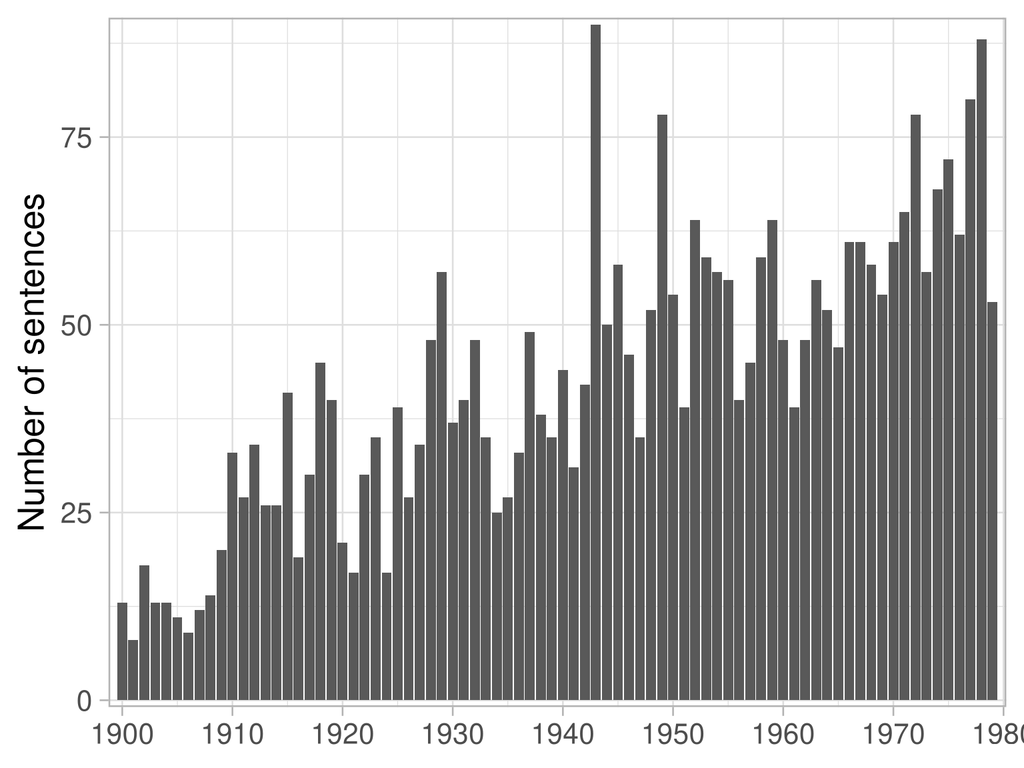

### Closest sentence from ‘rational’ and ‘rationality’ of the backbone community

| Sentence | Title | Year | Journal | Authors | Words Similarity |
| --- | --- | --- | --- | --- | --- |
| We have already noted that the concept of rationality has its native place not at the level of the every-day conception of the social world, but at the theoretical level of the scientific observation … | [The Problem of Rationality in the Social World](http://www.jstor.org/stable/2549460) | 1943 | Economica | Alfred Schuetz | 0.813 |
| The present writer’s inclination is to question the advisability of seeking solutions possessing the required equilibrium properties but sacrificing the rationality of behavior. | [What Has Happened to the Theory of Games](http://www.jstor.org/stable/1831502) | 1953 | The American Economic Review | Leonid Hurwicz | 0.800 |
| This concept recognizes the well-known fact - well-known, in particular, to economists - that the great mass of our everyday actions is not the result of rational reasoning on rationally performed obs… | [Vilfredo Pareto (1848-1923)](http://www.jstor.org/stable/1883096) | 1949 | The Quarterly Journal of Economics | Joseph A. Schumpeter | 0.776 |
| In order to answer this question we must analyse the various equivocal implications which are hidden in the term ” rationality” as it is applied to the level of every-day experience. | [The Problem of Rationality in the Social World](http://www.jstor.org/stable/2549460) | 1943 | Economica | Alfred Schuetz | 0.774 |
| Similarly Dr. Mehmke in the Stuttgarter Neues Tagblatt argues “that we can only describe as rational what is in the interest not only of the individual, but also of the nation and of humanity. | [The Meaning of Rationalization: An Analysis of the Literature](http://www.jstor.org/stable/1883398) | 1932 | The Quarterly Journal of Economics | Robert A. Brady | 0.771 |
| Indeed it is really necessary to explain it rationally, for, unless we are willing to accept a blind fatalism, according to which history moves on without being controlled by human volition, we must r… | [The Economic Utilization of History: Annual Address of the President](http://www.jstor.org/stable/473) | 1912 | The American Economic Review | Henry W. Farnam | 0.770 |
| We built economics on the idea of rational choos? | [Economics and Modern Psycholoy: I](http://www.jstor.org/stable/1820785) | 1918 | Journal of Political Economy | J. M. Clark | 0.769 |
| “Rationality” has been imputed to the consumer only in the sense that his preferences are assumed to be unambiguous and self-consistent. | [Professor Knight and the Theory of Demand](http://www.jstor.org/stable/1825792) | 1946 | Journal of Political Economy | Robert L. Bishop | 0.767 |
| Three general sets of circumstances have to be examined: the niotive of rationalisation, the circumstances under which rationalisation takes place, and the methods of rationalisation actually adopted. | [Rationalisation and Technological Unemployment](http://www.jstor.org/stable/2224241) | 1930 | The Economic Journal | T. E. Gregory | 0.763 |
| ness dealings renders possible accounting?a system of “economic rationalism.” | [The Rationality of Economic Activity](http://www.jstor.org/stable/1820997) | 1910 | Journal of Political Economy | Wesley C. Mitchell | 0.758 |
| The existence of society in which men can live a life of reason is dependent finally on the existence of a body of tradition, sentiments, beliefs, and personal loyalties that can be understood and sha… | [Physics and Society](http://www.jstor.org/stable/137200) | 1940 | The Canadian Journal of Economics and Political Science / Revue canadienne d’Economique et de Science politique | Robert E. Park | 0.753 |
| Preferences which are the result of ignorance or inertia are almost entirely irrational, though the momentary inconvenience and discomfort, which a change of custom inevitably involves, entails an ele… | [Some Notes on Ideal Output](http://www.jstor.org/stable/2224577) | 1935 | The Economic Journal | R. F. Kahn | 0.749 |
| And again: “The construction of a strictly rational course of action serves the sociologist in these cases, on account of its evident understandability and lack of ambiguity …. as an ideal type for th… | [“Capitalism” in Recent German Literature: Sombart and Weber (Concluded)](http://www.jstor.org/stable/1822319) | 1929 | Journal of Political Economy | Talcott Parsons | 0.748 |
| This short analysis shows that we cannot speak of an isolated rational act, if we mean by this an act resulting from deliberated choice, but only of a system of rational acts.’ | [The Problem of Rationality in the Social World](http://www.jstor.org/stable/2549460) | 1943 | Economica | Alfred Schuetz | 0.748 |
| That would involve a wider meaning of rationality than is under consideration here. | [Wants and Activities in Marshall](http://www.jstor.org/stable/1883923) | 1931 | The Quarterly Journal of Economics | Talcott Parsons | 0.743 |
| It seems that we have to distinguish between the rationality of knowledge which is a prerequisite of the rational choice and the rationality of the choice itself. | [The Problem of Rationality in the Social World](http://www.jstor.org/stable/2549460) | 1943 | Economica | Alfred Schuetz | 0.743 |
| On the other hand, even though certain regularities of behavior and their systematic association with market conditions may be observed, it may be that their rational necessity in terms of human motiv… | [Market Classifications in Modern Price Theory](http://www.jstor.org/stable/1883410) | 1942 | The Quarterly Journal of Economics | Joe S. Bain | 0.743 |
| The modern tendency to find mental satisfaction in measuring everything by a fixed rational standard, and the way it takes for granted that everything can be related to everything else, certainly rece… | [On the Economic Significance of Culture](http://www.jstor.org/stable/2113261) | 1944 | The Journal of Economic History | Harold A. Innis | 0.743 |
| If then individual judgments are not rational and instincts are non-dependable, Hobson can seek to accomplish a definite social purpose only upon the assumption of the possibility of rationality in co… | [Economic Theory and “Social Reform”](http://www.jstor.org/stable/1820938) | 1915 | Journal of Political Economy | Walton H. Hamilton | 0.737 |
| Some of the manifestations of planning and of rationalisation are of this nature. | [Trends in Business Administration](http://www.jstor.org/stable/2548975) | 1932 | Economica | Arnold Plant | 0.737 |

### Closest sentences of the backbone community’s centroid

| Sentence | Title | Year | Journal | Authors | Centroid Similarity |
| --- | --- | --- | --- | --- | --- |
| The implications of the arguments contained in this paper are outlined in Section 8. | [Bentham or Bergson? Finite Sensibility, Utility Functions and Social Welfare Functions](http://www.jstor.org/stable/2296793) | 1975 | The Review of Economic Studies | Yew-Kwang Ng | 0.8492060 |
| Some Implications for Economics I hope that these remarks will help provide some perspective for the discussions which follow. | [Operations Research and Economics](http://www.jstor.org/stable/1927407) | 1958 | The Review of Economics and Statistics | W. W. Cooper | 0.8372826 |
| The aim of the later sections of the present paper has been merely to develop a point of view from which intelligent judgment of the question is possible. | [Economic Psychology and the Value Problem](http://www.jstor.org/stable/1882434) | 1925 | The Quarterly Journal of Economics | Frank H. Knight | 0.8368329 |
| The present paper provides a more considered judgment on some of the issues raised in that essay. | [Some Reflections on Central Banking in Canada](http://www.jstor.org/stable/139119) | 1958 | The Canadian Journal of Economics and Political Science / Revue canadienne d’Economique et de Science politique | J. N. Wolfe | 0.8348305 |
| A second purpose of this paper, then, is to question the validity of this presumption. | [Exchange Rate Policy in Relation to Internal and External Balance](http://www.jstor.org/stable/3439564) | 1977 | The Scandinavian Journal of Economics | Sixten Korkman | 0.8321524 |
| In what follows an attempt will be made to evaluate those arguments which occupy an important place in recent and contemporary literature of the subject. | [Recent and Contemporary Theories of Progressive Taxation](http://www.jstor.org/stable/1824777) | 1938 | Journal of Political Economy | Elmer D. Fagan | 0.8314391 |
| “2 The purpose of this paper is to explore in detail the implications of this assertion. | [Joint Supply, the Taussig-Pigou Controversy, and the Competitive Provision of Public Goods](http://www.jstor.org/stable/724774) | 1973 | The Journal of Law & Economics | Robert B. Ekelund, Jr., Joe R. Hulett | 0.8308265 |
| This paper will examine the reasons for, and implications of, these conclusions. | [On Risk-Adjusted Capitalization Rates and Valuation by Individuals](http://www.jstor.org/stable/2325419) | 1970 | The Journal of Finance | Michael Adler | 0.8259172 |
| Various issues have been thrown up in the ensuing discussion; and it is the purpose of this paper to explore, on a theoretical plane, the central problems in the debate. | [DEFICIT FINANCING AND ECONOMIC DEVELOPMENT](http://www.jstor.org/stable/29793055) | 1956 | Indian Economic Review | Jagdish Bhagwati | 0.8192029 |
| My analysis expounded in this article, as well as my conclusions drawn therefrom, and my propositions will certainly be disputed by many, and from many aspects. | [THE “UNSOLVABLE” DILEMMA OF REGULATING EARNINGS IN HUNGARY](http://www.jstor.org/stable/40728610) | 1978 | Acta Oeconomica | S. BALÁZSY | 0.8167069 |
| Some of the chief implications will now be discussed; but several important points, and some significant refinements of the points here presented, must be reserved for treatment elsewhere. | [The Taxation of Stockholders](http://www.jstor.org/stable/1881958) | 1950 | The Quarterly Journal of Economics | W. L. Crum | 0.8161592 |
| These considerations complicate, but do not alter, the essential arguments of this paper. | [Life Cycle Consumption and Labor Supply: An Explanation of the Relationship between Income and Consumption Over the Life Cycle](http://www.jstor.org/stable/1814894) | 1974 | The American Economic Review | James Heckman | 0.8160740 |
| Beyond that, what, may we ask, do the conclusions of this paper suggest with respect to an ideal policy. | [The Economics of the Right-to-Work Controversy](http://www.jstor.org/stable/1054873) | 1966 | Southern Economic Journal | Lowell E. Gallaway | 0.8150028 |
| The above argument must be qualified in at least three ways, and it is the implications of these qualifications which are investigated in the first part of this paper. | [International Reserve Economies in Less Developed Countries](http://www.jstor.org/stable/2662892) | 1978 | Oxford Economic Papers | John R. Dodsworth | 0.8148245 |
| Acceptance of the arguments put forward in this paper has some important implications. | [Management Objectives, Fares and Service Levels in Bus Transport](http://www.jstor.org/stable/20052491) | 1978 | Journal of Transport Economics and Policy | C. A. Nash | 0.8133344 |

### Closest sentences of each kmean cluster’s centroid composing the backbone community

#### Top terms 7_2: sufficient_reason, commission, railroad, sentiment, mill’s (1900-1919)

| Sentence | Title | Year | Journal | Authors | Distance to Centroid |
| --- | --- | --- | --- | --- | --- |
| The case for the policy of ” the three F’s” is stated with his usual persuasive power by Cairnes in an essay already referred to, and his arguments are substantially repeated in the Report of the Bess… | [Some Features of the Economic Movement in Ireland, 1880-1900](http://www.jstor.org/stable/2956987) | 1901 | The Economic Journal | C. F. Bastable | 7.519845 |
| In the brief chapter on “The Principles of 1907,” we find the climax of the argument. | [English Poor-Law Reform](http://www.jstor.org/stable/1820483) | 1911 | Journal of Political Economy | Edith Abbott | 7.831629 |
| This he regards as the principal defect of the classical doctrine, but upon detailed examination he finds a variety of other difficulties in it.1 In the view of the present writer it is possible to de… | [The Ricardian Theory of Gold Movements and Professor Laughlin’s Views of Money](http://www.jstor.org/stable/1882786) | 1904 | The Quarterly Journal of Economics | A. C. Whitaker | 8.201255 |
| The errors in the bases on which this conclusion was rested, and the fallacies in the argu- 1 This article gives the substance of a lecture delivered at Harvard University in April, 1905. | [The Probable Increase of the Negro Race in the United States](http://www.jstor.org/stable/1885288) | 1905 | The Quarterly Journal of Economics | Walter F. Willcox | 8.258776 |
| Mr. Nettleton’s book is to a great extent a compilation of facts and opinions, but in the second chapter the author presents his own conclusions in a vigorous argument against the trust. | [Trust Literature: A Survey and A Criticism](http://www.jstor.org/stable/1884894) | 1901 | The Quarterly Journal of Economics | Charles J. Bullock | 8.339860 |

#### Top terms 7_10: tariff, commerce, commission, institu, total_supply (1900-1919)

| Sentence | Title | Year | Journal | Authors | Distance to Centroid |
| --- | --- | --- | --- | --- | --- |
| And a sixth persuades himself that the author almost unconsciously has furthered the tendency toward a new articulation of economic doctrine free from atomic pre? | [An Appraisal of Clay’s Economics](http://www.jstor.org/stable/1820538) | 1919 | Journal of Political Economy | Walton H. Hamilton | 7.524400 |
| Now the point of most essential interest in the study of man and wealth, and the point to which Jevons at once turns, is not a disconnected series of decisions, but the relation between them? | [Economics and Modern Psycholoy: I](http://www.jstor.org/stable/1820785) | 1918 | Journal of Political Economy | J. M. Clark | 7.594169 |
| An economic philosophy which can assimi? | [Economics and Modern Psycholoy: I](http://www.jstor.org/stable/1820785) | 1918 | Journal of Political Economy | J. M. Clark | 7.778627 |
| Consistency, however, as well as the fact that much of the Tariff Boards work was evidently untrustworthy, even had the fundamental fallacy of comparative cost of production been accepted, forbade the… | [The Tariff of 1913: I](http://www.jstor.org/stable/1821090) | 1914 | Journal of Political Economy | H. Parker Willis | 7.827828 |
| Its importance, to them, lies, not in its content, but in its existence.1 Unlike Smith and the later economists, Hobson is concerned with a state of social well-being that can be attained only by con? | [Economic Theory and “Social Reform”](http://www.jstor.org/stable/1820938) | 1915 | Journal of Political Economy | Walton H. Hamilton | 7.887234 |

#### Top terms 7_18: rationalisation, und, faculties, der, rationalization (1920-1939)

| Sentence | Title | Year | Journal | Authors | Distance to Centroid |
| --- | --- | --- | --- | --- | --- |
| Finally, I suggest that all Souter’s essential criticisms of the “neo-Austrian” position can be met successfully, and the advantages of a clear-cut division of theoretical labor in the social sciences… | [Some Reflections on “The Nature and Significance of Economics”](http://www.jstor.org/stable/1882825) | 1934 | The Quarterly Journal of Economics | Talcott Parsons | 7.268783 |
| I select this theory for critical examination, not from any desire to select what some would regard as an easy target, but because it so happens that such an examination brings out, more vividly than … | [Consumption and the Trade Cycle](http://www.jstor.org/stable/2549142) | 1932 | Economica | Lionel Robbins | 7.446696 |
| The present article is purely expository; our appraisal of the theory is left for another occasion. | [A New Approach to the Methodology of the Social Sciences](http://www.jstor.org/stable/2626877) | 1937 | Economica | Alfred Stonier, Karl Bode | 7.981316 |
| This presentation of the matter should perhaps suffice, but a different view is taken by a recent writer, Nurkse, and an examination of his argument may make the subject plainer.’ | [The Theory of International Trade in the Absence of an International Standard](http://www.jstor.org/stable/2549167) | 1936 | Economica | P. B. Whale | 8.074363 |
| V. Another group of writers concerns itself with the methodological and epistemological implications of rationalization, conceived as the final industrial and economic triumph of science, conscious ef… | [The Meaning of Rationalization: An Analysis of the Literature](http://www.jstor.org/stable/1883398) | 1932 | The Quarterly Journal of Economics | Robert A. Brady | 8.170229 |

#### Top terms 7_33: social_world, professor_hayek, actor, lange’s, rational_human (1940-1949)

| Sentence | Title | Year | Journal | Authors | Distance to Centroid |
| --- | --- | --- | --- | --- | --- |
| I have a strong conviction that an important part in this conspicuous dilemma of the thought of our time is played by methodological considerations of the kind under discussion in these brief remarks. | [Reply to Professor Knight](http://www.jstor.org/stable/136913) | 1940 | The Canadian Journal of Economics and Political Science / Revue canadienne d’Economique et de Science politique | Talcott Parsons | 7.840973 |
| We have already noted that the concept of rationality has its native place not at the level of the every-day conception of the social world, but at the theoretical level of the scientific observation … | [The Problem of Rationality in the Social World](http://www.jstor.org/stable/2549460) | 1943 | Economica | Alfred Schuetz | 7.897602 |
| The humblest grubber among “facts” must approach them with some equipment of questions, hypotheses, and methods of classification, all of which imply the acceptance of principles derived from a wider … | [Ruskin and the Orthodox Political Economists](http://www.jstor.org/stable/1053391) | 1943 | Southern Economic Journal | John Tyree Fain | 7.930387 |
| If a critical remark is added to that article it is only because to the writer it seems that the section on rationality suffers from a certain amount of vagueness which leaves it rather indefinite wha… | [The Meaning of Rationality: A Note on Professor Lange’s Article](http://www.jstor.org/stable/2295759) | 1946 | The Review of Economic Studies | K. W. Rothschild | 7.986769 |
| This short analysis shows that we cannot speak of an isolated rational act, if we mean by this an act resulting from deliberated choice, but only of a system of rational acts.’ | [The Problem of Rationality in the Social World](http://www.jstor.org/stable/2549460) | 1943 | Economica | Alfred Schuetz | 8.167295 |

#### Top terms 7_56: friedman’s, governmental_action, views_expressed, schultz, economic_considerations (1950-1959)

| Sentence | Title | Year | Journal | Authors | Distance to Centroid |
| --- | --- | --- | --- | --- | --- |
| A thorough discussion of these problems among both ” theoretical ” and ” applied ” economists may considerably contribute to the elucidation of the issues involved, and perhaps lead towards a substant… | [Economic Theory as a Guide to Policy: Some Suggestions for Re-Appraisal](http://www.jstor.org/stable/2227892) | 1955 | The Economic Journal | H. Tyszynski | 7.311612 |
| In presenting this paper, I shall concentrate primarily on those aspects of the problems upon which an economist can throw some light. | [The British Health Experiment: The First Two Years of the National Health Service](http://www.jstor.org/stable/1910840) | 1951 | The American Economic Review | Seymour E. Harris | 7.502996 |
| 2 Economic Essays, Essay 14. | [Domar and Dynamic Economics](http://www.jstor.org/stable/2228074) | 1959 | The Economic Journal | R. F. Harrod | 7.530142 |
| Various issues have been thrown up in the ensuing discussion; and it is the purpose of this paper to explore, on a theoretical plane, the central problems in the debate. | [DEFICIT FINANCING AND ECONOMIC DEVELOPMENT](http://www.jstor.org/stable/29793055) | 1956 | Indian Economic Review | Jagdish Bhagwati | 7.562254 |
| Some of the chief implications will now be discussed; but several important points, and some significant refinements of the points here presented, must be reserved for treatment elsewhere. | [The Taxation of Stockholders](http://www.jstor.org/stable/1881958) | 1950 | The Quarterly Journal of Economics | W. L. Crum | 7.566160 |

#### Top terms 7_69: policy_implications, oeconomica, milton, milton_friedman, indebted (1960-1969)

| Sentence | Title | Year | Journal | Authors | Distance to Centroid |
| --- | --- | --- | --- | --- | --- |
| However, in contrast to the economist who may be mainly * The author wishes to thank John Moroney of Lehigh University for a critical reading of the first draft of this note. | [A Note on the Cost of Capital, Leverage, Dividends, and the Corporate Veil](http://www.jstor.org/stable/1055366) | 1964 | Southern Economic Journal | Eli Schwartz | 6.787579 |
| THOMAS D. WILLETT* * The author is a graduate student in economics at the University of Virginia. | [International Short-Term Capital Movements: Comments](http://www.jstor.org/stable/1812122) | 1967 | The American Economic Review | Thomas D. Willett | 6.845585 |
| IV The analysis of this paper has three primary implications for policy and future research. | [The Interest Rate, Taxation, and the Personal Savings Incentive](http://www.jstor.org/stable/1879515) | 1968 | The Quarterly Journal of Economics | M. S. Feldstein, S. C. Tsiang | 6.874617 |
| 324 p. Reviewed in Acta Oeconomica. | [HUNGARY’S NATIONAL INCOME ESTABLISHED ON THE BASIS OF THE SYSTEM OF NATIONAL ACCOUNTS](http://www.jstor.org/stable/40727836) | 1968 | Acta Oeconomica | A. Csernok | 6.986970 |
| I am very grateful to Professors Samuelson and Modigliani for proposing discussion’ on the implications of the results which emerged from my 1962 article.2 Their paper is excellent in many respects. | [New Results in an Old Framework: Comment on Samuelson and Modigliani](http://www.jstor.org/stable/2974426) | 1966 | The Review of Economic Studies | Luigi L. Pasinetti | 7.094508 |

#### Top terms 7_88: earlier_version, london_school, revision_received, assistant_professor, assistant (1970-1979)

| Sentence | Title | Year | Journal | Authors | Distance to Centroid |
| --- | --- | --- | --- | --- | --- |
| Hence * An earlier version of this paper was presented at the Western Economic Association Convention June 1975 in San Diego, California. | [Retail Credit, Credit Cards and Price Discrimination](http://www.jstor.org/stable/1057787) | 1977 | Southern Economic Journal | Michael M. Murphy, Mack Ott | 6.166705 |
| Paper presented to Canadian Economics Association Annual Meeting Feldstein, M.S. | [On Measuring the Social Opportunity Cost of Permanent and Temporary Employment](http://www.jstor.org/stable/134346) | 1978 | The Canadian Journal of Economics / Revue canadienne d’Economique | Glenn P. Jenkins, Chun-Yan Kuo | 6.247236 |
| A paper presented at the 43rd Annual Conference of the Western Economic Association, an abstract of which appears in Western Economic Journal. | [The Nursing Home as a Public Utility](http://www.jstor.org/stable/4224067) | 1971 | Journal of Economic Issues | Leahmae McCoy | 6.265547 |
| I presented an expanded version of this paper at the Western Economic Association meetings, Santa Clara, California, August 1972. | [Aggregate Demand, Job Search, and Employment](http://www.jstor.org/stable/1830744) | 1973 | Journal of Political Economy | Herschel I. Grossman | 6.295855 |
| An earlier version of this paper was presented at the 1977 meetings of the American Economic Association. | [The Motivation for Zoning: Efficiency or Wealth Redistribution?](http://www.jstor.org/stable/3145769) | 1979 | Land Economics | Michael L. Goetz, Larry E. Wofford | 6.374695 |

### Top articles (most sentences) of the backbone cluster

| Title | Year | Journal | Authors | Number sentences | Words Similarity |
| --- | --- | --- | --- | --- | --- |
| [The Problem of Rationality in the Social World](http://www.jstor.org/stable/2549460) | 1943 | Economica | Alfred Schuetz | 28 | 0.677 |
| [Economic Theory and “Social Reform”](http://www.jstor.org/stable/1820938) | 1915 | Journal of Political Economy | Walton H. Hamilton | 20 | 0.624 |
| [The Rationality of Economic Activity](http://www.jstor.org/stable/1820997) | 1910 | Journal of Political Economy | Wesley C. Mitchell | 17 | 0.665 |
| [Economics and the Idea of Natural Laws](http://www.jstor.org/stable/1885439) | 1929 | The Quarterly Journal of Economics | O. H. Taylor | 13 | 0.606 |
| [The Meaning of Rationalization: An Analysis of the Literature](http://www.jstor.org/stable/1883398) | 1932 | The Quarterly Journal of Economics | Robert A. Brady | 13 | 0.668 |
| [“Capitalism” in Recent German Literature: Sombart and Weber (Concluded)](http://www.jstor.org/stable/1822319) | 1929 | Journal of Political Economy | Talcott Parsons | 10 | 0.650 |
| [Problems of Rationalisation](http://www.jstor.org/stable/2224429) | 1930 | The Economic Journal | Stokes , Macgregor | 10 | 0.634 |
| [Rational Human Conduct and Modern Industrial Society](http://www.jstor.org/stable/1052713) | 1943 | Southern Economic Journal | Karl W. Kapp | 10 | 0.644 |
| [The Limitations of Marginal Utility](http://www.jstor.org/stable/1822146) | 1909 | Journal of Political Economy | Thorstein Veblen | 9 | 0.637 |
| [The Price-System and Social Policy](http://www.jstor.org/stable/1820786) | 1918 | Journal of Political Economy | Walton H. Hamilton | 9 | 0.634 |
| [Wants and Activities in Marshall](http://www.jstor.org/stable/1883923) | 1931 | The Quarterly Journal of Economics | Talcott Parsons | 9 | 0.644 |
| [Scientism and the Study of Society. Part III](http://www.jstor.org/stable/2549942) | 1944 | Economica | F. A. v. Hayek | 9 | 0.613 |
| [The Scope and Method of Economics](http://www.jstor.org/stable/2296113) | 1945 | The Review of Economic Studies | O. Lange | 9 | 0.659 |
| [Economics and Modern Psycholoy: I](http://www.jstor.org/stable/1820785) | 1918 | Journal of Political Economy | J. M. Clark | 8 | 0.691 |
| [Expectation and Rational Conduct](http://www.jstor.org/stable/41793308) | 1937 | Zeitschrift für Nationalökonomie / Journal of Economics | T. W. Hutchison | 8 | 0.633 |

### Top articles (most sentences) of the cluster for each time window

#### Top articles for 7_2: sufficient_reason, commission, railroad, sentiment, mill’s (1900-1919)

| Title | Year | Journal | Authors | Number sentences | Words Similarity |
| --- | --- | --- | --- | --- | --- |
| [The Limitations of Marginal Utility](http://www.jstor.org/stable/1822146) | 1909 | Journal of Political Economy | Thorstein Veblen | 9 | 0.637 |
| [The Incidence of Urban Rates III](http://www.jstor.org/stable/2956835) | 1900 | The Economic Journal | F. Y. Edgeworth | 5 | 0.615 |
| [The Relations of Recent Psychological Developments to Economic Theory](http://www.jstor.org/stable/1885945) | 1919 | The Quarterly Journal of Economics | Z. Clark Dickinson | 5 | 0.611 |
| [The Rationality of Economic Activity](http://www.jstor.org/stable/1820997) | 1910 | Journal of Political Economy | Wesley C. Mitchell | 4 | 0.650 |
| [Economic Theory and “Social Reform”](http://www.jstor.org/stable/1820938) | 1915 | Journal of Political Economy | Walton H. Hamilton | 4 | 0.648 |
| [The Socialist Economics of Karl Marx and His Followers](http://www.jstor.org/stable/1883435) | 1907 | The Quarterly Journal of Economics | Thorstein Veblen | 3 | 0.615 |
| [Professor Clark’s Economics](http://www.jstor.org/stable/1883836) | 1908 | The Quarterly Journal of Economics | Thornstein Veblen | 3 | 0.635 |
| [English Rural Land Questions](http://www.jstor.org/stable/2221737) | 1911 | The Economic Journal | L. L. Price | 3 | 0.629 |
| [Railway Rate Theories of the Interstate Commerce Commission](http://www.jstor.org/stable/1883614) | 1911 | The Quarterly Journal of Economics | M. B. Hammond | 3 | 0.585 |
| [Trust Literature: A Survey and A Criticism](http://www.jstor.org/stable/1884894) | 1901 | The Quarterly Journal of Economics | Charles J. Bullock | 2 | 0.650 |

#### Top articles for 7_10: tariff, commerce, commission, institu, total_supply (1900-1919)

| Title | Year | Journal | Authors | Number sentences | Words Similarity |
| --- | --- | --- | --- | --- | --- |
| [Economic Theory and “Social Reform”](http://www.jstor.org/stable/1820938) | 1915 | Journal of Political Economy | Walton H. Hamilton | 16 | 0.618 |
| [The Rationality of Economic Activity](http://www.jstor.org/stable/1820997) | 1910 | Journal of Political Economy | Wesley C. Mitchell | 13 | 0.669 |
| [The Price-System and Social Policy](http://www.jstor.org/stable/1820786) | 1918 | Journal of Political Economy | Walton H. Hamilton | 9 | 0.634 |
| [Economics and Modern Psycholoy: I](http://www.jstor.org/stable/1820785) | 1918 | Journal of Political Economy | J. M. Clark | 7 | 0.698 |
| [The Function and Problems of Economic Theory](http://www.jstor.org/stable/1820787) | 1918 | Journal of Political Economy | C. E. Ayres | 7 | 0.640 |
| [The Earlier Commercial Policy of the United States](http://www.jstor.org/stable/1820710) | 1902 | Journal of Political Economy | Thomas Walker Page | 6 | 0.643 |
| [An Appraisal of Clay’s Economics](http://www.jstor.org/stable/1820538) | 1919 | Journal of Political Economy | Walton H. Hamilton | 6 | 0.636 |
| [Is an Ideal Money Attainable?](http://www.jstor.org/stable/1820954) | 1903 | Journal of Political Economy | Charles A. Conant | 5 | 0.630 |
| [The Legality of the Combination of Competitors Under the Sherman Act](http://www.jstor.org/stable/1820986) | 1917 | Journal of Political Economy | Sumner H. Slichter | 5 | 0.603 |
| [The Standard of Value and Prices](http://www.jstor.org/stable/1820833) | 1907 | Journal of Political Economy | Ralph H. Hess | 4 | 0.608 |

#### Top articles for 7_18: rationalisation, und, faculties, der, rationalization (1920-1939)

| Title | Year | Journal | Authors | Number sentences | Words Similarity |
| --- | --- | --- | --- | --- | --- |
| [Economics and the Idea of Natural Laws](http://www.jstor.org/stable/1885439) | 1929 | The Quarterly Journal of Economics | O. H. Taylor | 13 | 0.606 |
| [The Meaning of Rationalization: An Analysis of the Literature](http://www.jstor.org/stable/1883398) | 1932 | The Quarterly Journal of Economics | Robert A. Brady | 13 | 0.668 |
| [“Capitalism” in Recent German Literature: Sombart and Weber (Concluded)](http://www.jstor.org/stable/1822319) | 1929 | Journal of Political Economy | Talcott Parsons | 10 | 0.650 |
| [Problems of Rationalisation](http://www.jstor.org/stable/2224429) | 1930 | The Economic Journal | Stokes , Macgregor | 10 | 0.634 |
| [Wants and Activities in Marshall](http://www.jstor.org/stable/1883923) | 1931 | The Quarterly Journal of Economics | Talcott Parsons | 9 | 0.644 |
| [Expectation and Rational Conduct](http://www.jstor.org/stable/41793308) | 1937 | Zeitschrift für Nationalökonomie / Journal of Economics | T. W. Hutchison | 8 | 0.633 |
| [A Functional Approach to Social-Economic Data](http://www.jstor.org/stable/1821031) | 1920 | Journal of Political Economy | Leverett S. Lyon | 7 | 0.608 |
| [“Capitalism” In Recent German Literature: Sombart and Weber](http://www.jstor.org/stable/1820700) | 1928 | Journal of Political Economy | Talcott Parsons | 7 | 0.655 |
| [Fourier and Anarchism](http://www.jstor.org/stable/1884047) | 1928 | The Quarterly Journal of Economics | E. S. Mason | 7 | 0.605 |
| [Some Reflections on “The Nature and Significance of Economics”](http://www.jstor.org/stable/1882825) | 1934 | The Quarterly Journal of Economics | Talcott Parsons | 7 | 0.637 |

#### Top articles for 7_33: social_world, professor_hayek, actor, lange’s, rational_human (1940-1949)

| Title | Year | Journal | Authors | Number sentences | Words Similarity |
| --- | --- | --- | --- | --- | --- |
| [The Problem of Rationality in the Social World](http://www.jstor.org/stable/2549460) | 1943 | Economica | Alfred Schuetz | 28 | 0.677 |
| [Rational Human Conduct and Modern Industrial Society](http://www.jstor.org/stable/1052713) | 1943 | Southern Economic Journal | Karl W. Kapp | 10 | 0.644 |
| [Scientism and the Study of Society. Part III](http://www.jstor.org/stable/2549942) | 1944 | Economica | F. A. v. Hayek | 9 | 0.613 |
| [The Scope and Method of Economics](http://www.jstor.org/stable/2296113) | 1945 | The Review of Economic Studies | O. Lange | 9 | 0.659 |
| [The Utility Analysis of Choices Involving Risk](http://www.jstor.org/stable/1826045) | 1948 | Journal of Political Economy | Milton Friedman, L. J. Savage | 8 | 0.601 |
| [The Meaning of Rationality: A Note on Professor Lange’s Article](http://www.jstor.org/stable/2295759) | 1946 | The Review of Economic Studies | K. W. Rothschild | 6 | 0.657 |
| [Uncertainty and the Utility Function](http://www.jstor.org/stable/2226342) | 1948 | The Economic Journal | W. E. Armstrong | 6 | 0.598 |
| [Psychological Aspects of Economic Thought](http://www.jstor.org/stable/1826270) | 1949 | Journal of Political Economy | Walter A. Weisskopf | 6 | 0.616 |
| [John R. Commons’ Point of View](http://www.jstor.org/stable/3159056) | 1942 | The Journal of Land & Public Utility Economics | Kenneth H. Parsons, John R. Commons | 5 | 0.598 |
| [The Theory of Economic Behavior](http://www.jstor.org/stable/1812602) | 1945 | The American Economic Review | Leonid Hurwicz | 5 | 0.658 |

#### Top articles for 7_56: friedman’s, governmental_action, views_expressed, schultz, economic_considerations (1950-1959)

| Title | Year | Journal | Authors | Number sentences | Words Similarity |
| --- | --- | --- | --- | --- | --- |
| [The Reduction of Fluctuations in the Incomes of Primary Producers Further Considered](http://www.jstor.org/stable/2228040) | 1954 | The Economic Journal | P. T. Bauer, F. W. Paish | 5 | 0.614 |
| [Robertson on Utility and Scope](http://www.jstor.org/stable/2550835) | 1953 | Economica | Lionel Robbins | 4 | 0.626 |
| [Government Expenditure: Significant Issues of Definition](http://www.jstor.org/stable/2976619) | 1954 | The Journal of Finance | C. Lowell Harriss | 4 | 0.606 |
| [On “The Methodology of Positive Economics”](http://www.jstor.org/stable/1884303) | 1959 | The Quarterly Journal of Economics | Eugene Rotwein | 4 | 0.602 |
| [The Pragmatic Basis of Economic Theory](http://www.jstor.org/stable/137857) | 1950 | The Canadian Journal of Economics and Political Science / Revue canadienne d’Economique et de Science politique | H. Scott Gordon | 3 | 0.623 |
| [The Future of Economic Liberalism](http://www.jstor.org/stable/1910579) | 1952 | The American Economic Review | Overton H. Taylor | 3 | 0.612 |
| [Productivity, Wages, and the Balance of Payments](http://www.jstor.org/stable/1925749) | 1955 | The Review of Economics and Statistics | Svend Laursen | 3 | 0.623 |
| [Economic Theory as a Guide to Policy: Some Suggestions for Re-Appraisal](http://www.jstor.org/stable/2227892) | 1955 | The Economic Journal | H. Tyszynski | 3 | 0.600 |
| [The Taxonomic Approach to the Study of Economic Policies](http://www.jstor.org/stable/1811583) | 1955 | The American Economic Review | A. C. L. Day | 3 | 0.597 |
| [Economic Theory, Value Judgments, and Economic Policy](http://www.jstor.org/stable/3485033) | 1955 | The American Journal of Economics and Sociology | Forest G. Hill | 3 | 0.586 |

#### Top articles for 7_69: policy_implications, oeconomica, milton, milton_friedman, indebted (1960-1969)

| Title | Year | Journal | Authors | Number sentences | Words Similarity |
| --- | --- | --- | --- | --- | --- |
| [A Theory of Balance-of-Payments Adjustments following upon Output Expansions in the Foreign-Trade and Domestic-Trade Industries](http://www.jstor.org/stable/1055387) | 1966 | Southern Economic Journal | Hang-Sheng Cheng | 4 | 0.612 |
| [The Problem of Social Cost](http://www.jstor.org/stable/724810) | 1960 | The Journal of Law & Economics | R. H. Coase | 3 | 0.610 |
| [A Survey of the Theory of International Trade: Part 2, The Neo-Classical Theory](http://www.jstor.org/stable/1910353) | 1965 | Econometrica | John S. Chipman | 3 | 0.594 |
| [The Theory of Investment Cycles in a Socialist Economy](http://www.jstor.org/stable/4379376) | 1968 | Eastern European Economics | Nikola Čobeljić , Radmila Stojanović | 3 | 0.594 |
| [The Comparative Advantage Aspects](http://www.jstor.org/stable/1235689) | 1960 | Journal of Farm Economics | Charles E. French, Earl W. Kehrberg | 2 | 0.606 |
| [United States Experience](http://www.jstor.org/stable/2977967) | 1961 | The Journal of Finance | Frank A. Southard, Jr. | 2 | 0.609 |
| [Domestic Air Transport Policy-Part II](http://www.jstor.org/stable/2601602) | 1961 | Economica | Lucien Foldes | 2 | 0.589 |
| [On the Use of Deductive Systems in Economics, with Special Reference to Mathematics](http://www.jstor.org/stable/25602566) | 1962 | The American Economist | Stuart I. Greenbaum | 2 | 0.635 |
| [The Character of Improvements and of Technical Progress](http://www.jstor.org/stable/2228358) | 1962 | The Economic Journal | Charles Kennedy | 2 | 0.606 |
| [Assumptions in Economic Theory](http://www.jstor.org/stable/1823864) | 1963 | The American Economic Review | Ernest Nagel | 2 | 0.612 |

#### Top articles for 7_88: earlier_version, london_school, revision_received, assistant_professor, assistant (1970-1979)

| Title | Year | Journal | Authors | Number sentences | Words Similarity |
| --- | --- | --- | --- | --- | --- |
| [The Scientific Contributions of Milton Friedman](http://www.jstor.org/stable/3439568) | 1977 | The Scandinavian Journal of Economics | Niels Thygesen | 6 | 0.595 |
| [Notes on New Books](http://www.jstor.org/stable/2230837) | 1976 | The Economic Journal | NULL | 4 | 0.619 |
| [On European Social Rates of Discount: Survey](http://www.jstor.org/stable/40910998) | 1973 | FinanzArchiv / Public Finance Analysis | Heinz Schleicher | 3 | 0.618 |
| [Private Property and Dispersion of Ownership in Large Corporations](http://www.jstor.org/stable/2978337) | 1973 | The Journal of Finance | Louis De Alessi | 3 | 0.607 |
| [On Risk-Adjusted Capitalization Rates and Valuation by Individuals](http://www.jstor.org/stable/2325419) | 1970 | The Journal of Finance | Michael Adler | 2 | 0.640 |
| [Price-Expectations Effects on Interest Rates](http://www.jstor.org/stable/2325796) | 1970 | The Journal of Finance | William E. Gibson | 2 | 0.597 |
| [Professor Friedman’s Views on Money](http://www.jstor.org/stable/2551751) | 1971 | Economica | F. H. Hahn | 2 | 0.606 |
| [Robbins on the History of Development Theory](http://www.jstor.org/stable/1152743) | 1972 | Economic Development and Cultural Change | William D. Grampp | 2 | 0.611 |
| [A Keynesian View of Friedman’s Theoretical Framework for Monetary Analysis](http://www.jstor.org/stable/1830416) | 1972 | Journal of Political Economy | Paul Davidson | 2 | 0.607 |
| [Economics and the Quality of Life](http://www.jstor.org/stable/1239206) | 1972 | American Journal of Agricultural Economics | Emery N. Castle | 2 | 0.607 |

### Most cited references in the backbone community

| First Author | Year | Journal | Citation by article | Citation by sentence |
| --- | --- | --- | --- | --- |
| TOBIN-J | 1958 | REV ECON STUD | 16 | 32 |
| ARROW-K | 1961 | REV ECON STAT | 10 | 20 |
| MUTH-J | 1961 | ECONOMETRICA | 9 | 9 |
| SHARPE-W | 1964 | J FINANCE | 8 | 8 |
| BECKER-G | 1965 | EC J | 7 | 7 |
| COASE-R | 1960 | J LAW EC | 7 | 7 |
| DIEWERT-W | 1971 | J POLIT EC | 7 | 7 |
| STIGLER-G | 1961 | J POLITICAL EC | 7 | 7 |
| AVERCH-H | 1962 | AM EC REV | 7 | 7 |
| HOCHMAN-H | 1969 | AM EC REV | 7 | 7 |
| BARRO-R | 1971 | AM ECONOMIC REV | 7 | 7 |
| SOLOW-R | 1957 | REV EC STATISTICS | 6 | 6 |
| FRIEDMAN-M | 1968 | AER | 6 | 6 |
| LINTNER-J | 1965 | REV EC STATISTICS | 6 | 6 |
| SARGENT-T | 1975 | J POLITICAL EC | 6 | 6 |

| First Author | Year | Journal | Citation by article | Citation by sentence |
| --- | --- | --- | --- | --- |
| SAMUELSON-P | 1947 | F ECONOMICS | 15 | 30 |
| FRIEDMAN-M | 1953 | ESSAYS POSITIVE ECON | 13 | 26 |
| FRIEDMAN-M | 1969 | OPTIMUM QUANTITY MON | 13 | 26 |
| MEADE-J | 1955 | THEORY INT EC POLICY | 7 | 21 |
| BAUMOL-W | 1967 | BUSINESS BEHAVIOR VA | 7 | 21 |
| FRIEDMAN-M | 1962 | CAPITALISM FREEDOM | 9 | 18 |
| MARKOWITZ-H | 1959 | PORTFOLIO SELECTION | 9 | 18 |
| KOOPMANS-T | 1957 | 3 ESSAYS STATE ECONO | 8 | 16 |
| SCHERER-F | 1970 | IND MARKET STRUCTURE | 8 | 16 |
| HICKSJR | 1939 | EC J DEC | 5 | 15 |
| SAMUELSON-P | 1947 | F EC ANAL | 5 | 15 |
| THOMAS-B | 1954 | MIGRATION EC GROWTH | 5 | 15 |
| MYRDALG | 1932 | POLITISCHE ELEMENT N | 2 | 12 |
| HICKSJR | 1934 | ECONOMICA | 2 | 12 |
| BAUMOL-W | 1952 | SPATIAL EQUILIBRIUM | 6 | 12 |

### Most cited references per kmean clusters

#### Top references 7_33: social_world, professor_hayek, actor, lange’s, rational_human (1940-1949)

| First Author | Year | Journal | Citation by article | Citation by sentence |
| --- | --- | --- | --- | --- |
| VICKREY-W | 1945 | ECONOMETRICA | 1 | 8 |
| ARMSTRONG-W | 1939 | EC J | 1 | 8 |
| KAYSEN-C | 1946 | REV ECON STUD | 1 | 8 |
| TINTNERG | 1942 | Q J ECON | 1 | 8 |
| ARMSTRONG | 1948 | ECON J | 1 | 8 |
| MARSHALLA | 1920 | PRINCIPLES EC | 1 | 8 |
| MARSCHAKJ | 1938 | ECONOMETRICA | 1 | 8 |
| FROMME | 1947 | MAN HIM | 1 | 6 |
| FREUDS | 1948 | COLLECT PAPERS | 1 | 6 |
| MYRDAL-G | 1944 | AM DISLEMMA | 1 | 6 |

| First Author | Year | Journal | Citation by article | Citation by sentence |
| --- | --- | --- | --- | --- |
| MYRDALG | 1932 | POLITISCHE ELEMENT N | 2 | 12 |
| HICKSJR | 1934 | ECONOMICA | 2 | 12 |
| LERNERAP | 1944 | EC CONTROL | 4 | 8 |
| *MNRESCOMM | 1942 | MINN INC 1938 39 | 1 | 8 |
| *UDELBURECBUS | 1941 | DEL INC STAT | 1 | 8 |
| ASHTONJ | 1893 | HIST ENGLISH LOTTERI | 1 | 8 |
| BERNOULLID | 1896 | VERSUCH NEUEN THEORI | 1 | 8 |
| EWENCL | 1932 | LOTTERIES SWEEPSTAKE | 1 | 8 |
| FRIEDMANM | 1945 | INCOME INDEPENDENT P | 1 | 8 |
| HANNAFA | 1948 | ANAL WISCONSIN INC 2 | 1 | 8 |

#### Top references 7_56: friedman’s, governmental_action, views_expressed, schultz, economic_considerations (1950-1959)

| First Author | Year | Journal | Citation by article | Citation by sentence |
| --- | --- | --- | --- | --- |
| MARSCHAK-J | 1950 | ECONOMETRICA | 5 | 5 |
| FRIEDMAN-M | 1953 | ESSAYS POSITIVE EC | 1 | 4 |
| FRIEDMAN-M | 1948 | J POLIT EC | 4 | 4 |
| MOSTELLER-F | 1951 | J POLIT ECON | 4 | 4 |
| ROBERTSONDH | 1952 | UTILITY ALL OTHER ES | 1 | 4 |
| HICKS-J | 1939 | EC J | 1 | 3 |
| MARKOWITZ-H | 1952 | J POLITICAL EC | 3 | 3 |
| NASH-J | 1950 | ECONOMICTRICA | 3 | 3 |
| SINGER-H | 1950 | AM EC REV | 3 | 3 |
| PHILLIPS-A | 1954 | EC J | 1 | 3 |

| First Author | Year | Journal | Citation by article | Citation by sentence |
| --- | --- | --- | --- | --- |
| HICKSJR | 1939 | EC J DEC | 5 | 15 |
| MEADEJE | 1951 | THEORY EC POLICY | 3 | 9 |
| DUESENBERRYJS | 1949 | INCOME SAVING THEORY | 4 | 8 |
| LESTERRA | 1946 | SHORTCOMINGS MARGINA | 2 | 6 |
| POPPERKR | 1944 | ECONOMICA | 2 | 6 |
| TINBERGENJ | 1952 | THEORY EC POLICY | 2 | 6 |
| MARGETAW | 1938 | THEORY PRICES | 3 | 6 |
| NURKSER | 1952 | SOME ASPECTS CAPITAL | 2 | 6 |
| BAKERJD | 1952 | J FARM EC NOV | 2 | 6 |
| DORFMANR | 1953 | AM EC REV DEC | 2 | 6 |

#### Top references 7_69: policy_implications, oeconomica, milton, milton_friedman, indebted (1960-1969)

| First Author | Year | Journal | Citation by article | Citation by sentence |
| --- | --- | --- | --- | --- |
| SOLOW-R | 1957 | REV EC STATISTICS | 6 | 6 |
| TOBIN-J | 1958 | REV ECON STUD | 6 | 6 |
| ARROW-K | 1961 | REV ECON STAT | 5 | 5 |
| DAVIS-O | 1962 | J POLIT EC | 5 | 5 |
| BAUMOL-W | 1952 | Q J EC | 4 | 4 |
| TOBIN-J | 1956 | REV EC STATISTICS | 4 | 4 |
| JOHNSON-H | 1958 | INT TRADE EC GROWTH | 1 | 4 |
| FRIEDMAN-M | 1953 | ESSAYS POSITIVE ECON | 1 | 4 |
| NURKSE-R | 1961 | ECONOMIC DEVELOPMENT | 1 | 4 |
| JOHNSON-H | 1958 | INT TRADE ECONOMIC G | 1 | 4 |

| First Author | Year | Journal | Citation by article | Citation by sentence |
| --- | --- | --- | --- | --- |
| MEADE-J | 1955 | THEORY INT EC POLICY | 7 | 21 |
| SAMUELSON-P | 1947 | F EC ANAL | 5 | 15 |
| THOMAS-B | 1954 | MIGRATION EC GROWTH | 5 | 15 |
| BAUMOL-W | 1952 | SPATIAL EQUILIBRIUM | 6 | 12 |
| ARROW-K | 1951 | SOCIAL CHOICE INDIVI | 4 | 12 |
| DORFMAN-R | 1958 | LINEAR PROGRAMMING E | 4 | 12 |
| FRIEDMAN-M | 1953 | ESSAYS POSITIVE EC | 5 | 10 |
| ISARD-W | 1956 | LOCATION SPACE EC | 3 | 9 |
| MEADE-J | 1952 | GEOMETRY INT TRADE | 3 | 9 |
| PIGOU-A | 1932 | EC WELFARE | 3 | 9 |

#### Top references 7_88: earlier_version, london_school, revision_received, assistant_professor, assistant (1970-1979)

| First Author | Year | Journal | Citation by article | Citation by sentence |
| --- | --- | --- | --- | --- |
| TOBIN-J | 1958 | REV ECON STUD | 10 | 10 |
| MUTH-J | 1961 | ECONOMETRICA | 9 | 9 |
| SHARPE-W | 1964 | J FINANCE | 8 | 8 |
| BECKER-G | 1965 | EC J | 7 | 7 |
| COASE-R | 1960 | J LAW EC | 7 | 7 |
| DIEWERT-W | 1971 | J POLIT EC | 7 | 7 |
| STIGLER-G | 1961 | J POLITICAL EC | 7 | 7 |
| AVERCH-H | 1962 | AM EC REV | 7 | 7 |
| HOCHMAN-H | 1969 | AM EC REV | 7 | 7 |
| BARRO-R | 1971 | AM ECONOMIC REV | 7 | 7 |

| First Author | Year | Journal | Citation by article | Citation by sentence |
| --- | --- | --- | --- | --- |
| SAMUELSON-P | 1947 | F ECONOMICS | 15 | 30 |
| FRIEDMAN-M | 1953 | ESSAYS POSITIVE ECON | 13 | 26 |
| FRIEDMAN-M | 1969 | OPTIMUM QUANTITY MON | 13 | 26 |
| BAUMOL-W | 1967 | BUSINESS BEHAVIOR VA | 7 | 21 |
| FRIEDMAN-M | 1962 | CAPITALISM FREEDOM | 9 | 18 |
| MARKOWITZ-H | 1959 | PORTFOLIO SELECTION | 9 | 18 |
| KOOPMANS-T | 1957 | 3 ESSAYS STATE ECONO | 8 | 16 |
| SCHERER-F | 1970 | IND MARKET STRUCTURE | 8 | 16 |

## Intertemporal cluster *8: economic_science, conventional_economics, elite, political_considerations*

The cluster gathers 6233 sentences from our corpus. It represents 3.85% of all the sentences selected over the whole period.

The community exists from 1900 to 1979.

The most recurring authors are Frank H. Knight (86 sentences; 27 articles), Allan G. Gruchy (65 sentences; 9 articles), Paul T. Homan (63 sentences; 12 articles), Walton H. Hamilton (52 sentences; 9 articles), Wesley C. Mitchell (50 sentences; 11 articles), Talcott Parsons (46 sentences; 8 articles), L. L. Price (43 sentences; 7 articles), R. W. Souter (42 sentences; 3 articles), A. B. Wolfe (40 sentences; 14 articles), J. M. Clark (39 sentences; 13 articles).

The most recurring journals are The American Economic Review (1012 sentences; 513 articles), The Quarterly Journal of Economics (670 sentences; 268 articles), Journal of Political Economy (666 sentences; 267 articles), Journal of Economic Issues (539 sentences; 140 articles), The Economic Journal (451 sentences; 201 articles).

### Top TF-IDF terms describing the community

| Token | TF-IDF |
| --- | --- |
| economic_science | 0.0009650 |
| conventional_economics | 0.0007971 |
| elite | 0.0007569 |
| political_considerations | 0.0006150 |
| professor_robbins | 0.0005750 |
| mathematics | 0.0005673 |
| robbins | 0.0005596 |
| fetter | 0.0005278 |
| institutional_economics | 0.0005194 |
| teaching | 0.0005136 |
| economic_method | 0.0005082 |
| laden | 0.0004956 |
| natural_sciences | 0.0004935 |
| fundamental_economic | 0.0004905 |
| taussig | 0.0004863 |
| economic_study | 0.0004757 |
| faculties | 0.0004725 |
| instruction | 0.0004701 |
| scientific_method | 0.0004671 |
| theoretical_concepts | 0.0004457 |

### Top TF-IDF terms describing the different k-means clusters

#### Top terms 8_6: economic_science, economic_method, pure_economics, economic_principles, davenport (1900-1919)

| Token | TF-IDF |
| --- | --- |
| economic_science | 0.0016205 |
| economic_method | 0.0012812 |
| pure_economics | 0.0009890 |
| economic_principles | 0.0009760 |
| davenport | 0.0009428 |
| writer | 0.0009218 |
| tho | 0.0009212 |
| fundamental_economic | 0.0008813 |
| fetter | 0.0008777 |
| science | 0.0008333 |
| doctrine | 0.0008160 |
| doctrines | 0.0007957 |
| treatises | 0.0007723 |
| economic_principle | 0.0007178 |
| clark | 0.0006984 |

#### Top terms 8_13: instruction, student, training, students, acquaintance (1900-1919)

| Token | TF-IDF |
| --- | --- |
| instruction | 0.0067836 |
| student | 0.0039017 |
| training | 0.0033329 |
| students | 0.0031077 |
| acquaintance | 0.0029854 |
| economic_study | 0.0029072 |
| teaching | 0.0023642 |
| faculties | 0.0021677 |
| elementary_economics | 0.0020331 |
| teacher | 0.0019845 |
| induction | 0.0018717 |
| taussig | 0.0014884 |
| citizen | 0.0014476 |
| books | 0.0014334 |
| intimate | 0.0014204 |

#### Top terms 8_20: economic_science, sciences, science, scientific, robbins (1920-1939)

| Token | TF-IDF |
| --- | --- |
| economic_science | 0.0028387 |
| sciences | 0.0016290 |
| science | 0.0014512 |
| scientific | 0.0014485 |
| robbins | 0.0012125 |
| subject_matter | 0.0011734 |
| professor_robbins | 0.0011734 |
| natural_science | 0.0011729 |
| ethics | 0.0011255 |
| scientific_method | 0.0010740 |
| natural_sciences | 0.0010389 |
| art | 0.0008661 |
| social_sciences | 0.0008010 |
| researches | 0.0007821 |
| biological | 0.0007640 |

#### Top terms 8_44: economic_science, commons, teaching, natural_sciences, sciences (1940-1949)

| Token | TF-IDF |
| --- | --- |
| economic_science | 0.0024665 |
| commons | 0.0014975 |
| teaching | 0.0013936 |
| natural_sciences | 0.0012798 |
| sciences | 0.0012202 |
| scientific | 0.0012117 |
| robbins | 0.0012091 |
| scientific_method | 0.0012027 |
| science | 0.0010479 |
| scarce_means | 0.0008897 |
| scientists | 0.0008766 |
| economic_research | 0.0008595 |
| social_sciences | 0.0008458 |
| political_scientists | 0.0008065 |
| subject_matter | 0.0007541 |

#### Top terms 8_54: mathematics, schumpeter, taxonomic, elite, mathematical_economics (1950-1959)

| Token | TF-IDF |
| --- | --- |
| mathematics | 0.0012982 |
| schumpeter | 0.0009786 |
| taxonomic | 0.0008608 |
| elite | 0.0008220 |
| mathematical_economics | 0.0008134 |
| scientific | 0.0007838 |
| economic_science | 0.0007160 |
| political_considerations | 0.0006720 |
| mathematicians | 0.0006165 |
| hutchison | 0.0006149 |
| deductive | 0.0006081 |
| political_economist | 0.0005889 |
| positivist | 0.0005818 |
| scientific_knowledge | 0.0005818 |
| prerequisite | 0.0005584 |

#### Top terms 8_67: institutional_economics, economic_philosophy, conventional_economics, mathematics, teaching (1960-1969)

| Token | TF-IDF |
| --- | --- |
| institutional_economics | 0.0016831 |
| economic_philosophy | 0.0010208 |
| conventional_economics | 0.0009392 |
| mathematics | 0.0009075 |
| teaching | 0.0008177 |
| sciences | 0.0007438 |
| professional_economists | 0.0007363 |
| mathematical_economics | 0.0007076 |
| ayres | 0.0006998 |
| profession | 0.0006914 |
| economic_science | 0.0006747 |
| academic_economists | 0.0006550 |
| koopmans | 0.0006550 |
| professional | 0.0006370 |
| acta_oeconomica | 0.0006326 |

#### Top terms 8_80: institutional_economics, economic_science, positive_economics, conventional_economics, neoclassical_economics (1970-1979)

| Token | TF-IDF |
| --- | --- |
| institutional_economics | 0.0010578 |
| economic_science | 0.0009074 |
| positive_economics | 0.0008986 |
| conventional_economics | 0.0008210 |
| neoclassical_economics | 0.0006835 |
| institutionalists | 0.0006367 |
| mathematical_economics | 0.0006367 |
| paradigm | 0.0006034 |
| neoclassical | 0.0005993 |
| epistemological | 0.0005861 |
| historians | 0.0005687 |
| physics | 0.0005572 |
| ideology | 0.0005468 |
| empiricism | 0.0005370 |
| microeconomics | 0.0005314 |

### Distribution of sentences over time

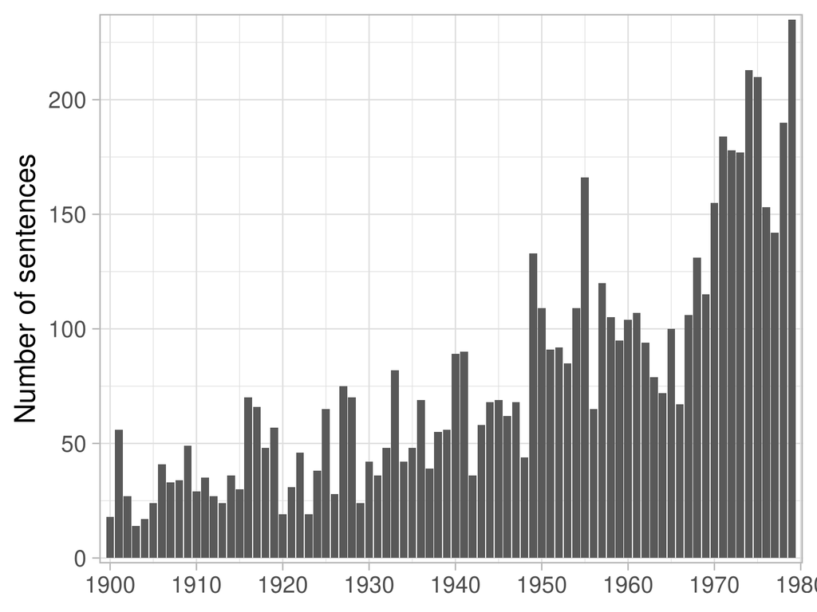

### Closest sentence from ‘rational’ and ‘rationality’ of the backbone community

| Sentence | Title | Year | Journal | Authors | Words Similarity |
| --- | --- | --- | --- | --- | --- |
| It may be suspected that those who credit “modern psychology” with having undermined “general economic theory” do not always trouble to distinguish the various possible meanings of the term “rational.… | [Equilibrium Economics and Business-Cycle Theory: A Commentary](http://www.jstor.org/stable/1882527) | 1930 | The Quarterly Journal of Economics | R. W. Souter | 0.794 |
| We note that with few exceptions, economists and game theorists alike have tended to avoid such issues.41 Once we leave the realm of strictly competitive games, problems multiply rapidly and every aut… | [Advances in Game Theory](http://www.jstor.org/stable/1809773) | 1958 | The American Economic Review | Harvey M. Wagner | 0.793 |
| As a thoroughly rationalized statement of that which never remotely approaches the rational,- as a formulation of the logic implicit in the market,- it has, in some directions, an important function i… | [Proposed Modifications in Austrian Theory and Terminology](http://www.jstor.org/stable/1881982) | 1902 | The Quarterly Journal of Economics | H. J. Davenport | 0.788 |
| These economists argue that pr?dation is too costly and uncertain to be used by the rational firm.2 If pr?dation is not likely, other similar actions have a greater probability of occurring. | [The Effect of the Growth of Multimarket Firms on Economic Performance: The Milk Industry](http://www.jstor.org/stable/25603154) | 1978 | The American Economist | Glenn N. Pettengill | 0.772 |
| The actions of economizing individuals, however important to the economic scientist, are in the concrete the actions of men whose motivation is not exhausted by economic factors and whose rational act… | [“Ability to Pay”](http://www.jstor.org/stable/1880677) | 1946 | The Quarterly Journal of Economics | Bernard W. Dempsey, S. J. | 0.770 |
| So long as economists follow this practice of explaining what is rational conduct under the conditions as- Sitmed, aind depend upon an assumption that inen are rational to make the theory a tolerably … | [The Role of Money in Economic Theory](http://www.jstor.org/stable/1803798) | 1916 | The American Economic Review | Wesley C. Mitchell | 0.767 |
| This is a serious disadvanatage; for, if it be difficult to force the miiore elaborate an-d refined ,of economic arguments within the limits of coiimmon intellectual capacity, or if it prove impossibl… | [Economics and Commercial Education](http://www.jstor.org/stable/2957411) | 1901 | The Economic Journal | L. L. Price | 0.766 |
| A complete “objective rationality” in economic conduct requires a complete economic science, which can tell one with “certainty” exactly what the effects of one decision or the other will be, and even… | [Expectation and Rational Conduct](http://www.jstor.org/stable/41793308) | 1937 | Zeitschrift für Nationalökonomie / Journal of Economics | T. W. Hutchison | 0.764 |
| So far as the question of economic method is concerned, here again it is clear no abstract reasoning can suffice: the history of each people and the facts of each case must be investigated, and genera… | [The Iron Industry in the United States](http://www.jstor.org/stable/1883422) | 1900 | The Quarterly Journal of Economics | F. W. Taussig | 0.760 |
| In its use are found the molds of economic rationality, and the clues to economic explanations. | [The Role of Money in Economic Theory](http://www.jstor.org/stable/1803798) | 1916 | The American Economic Review | Wesley C. Mitchell | 0.756 |
| NOTES AND MEMORANDA 439 I need not add that, upon almost all the subjects treated in my article, I was glad to be able to appeal to the authority of such a work as the Principles of Economics. | [The Variation of Productive Forces: A Rejoinder](http://www.jstor.org/stable/1884078) | 1904 | The Quarterly Journal of Economics | Charles J. Bullock | 0.756 |
| Advocated and adopted policies often appear incongruous to economists because they sometimes actually are, but also due to their conception within a broader “rationality.” | [Development of Agricultural Policy](http://www.jstor.org/stable/1233835) | 1950 | Journal of Farm Economics | Arnold Brekke | 0.755 |
| Sometimes economists come close to rationalizing all market results and private institutions by the argument that they would not occur and survive if they were not otpimally satisfying individuals’ pr… | [Economic Growth as an Objective of Government Policy](http://www.jstor.org/stable/1818484) | 1964 | The American Economic Review | James Tobin | 0.755 |
| But considerations of this kind vary in every country and with every age, and they can neither form the basis of any general science, nor supersede the investigation of the broad economic tendencies w… | [Modern Logicians and Economic Methods](http://www.jstor.org/stable/2221171) | 1905 | The Economic Journal | R. B. Haldane | 0.748 |
| It is necessary to clear thinking in this field to recognize that when we go beyond alternatives as they are and preferences as they are, we have passed from the realm of fact to that of what ought to… | [The Concept of Normal Price in Value and Distribution](http://www.jstor.org/stable/1885079) | 1917 | The Quarterly Journal of Economics | F. H. Knight | 0.748 |
| To some economists at least, it has held open the possibility and hope that important questions that had been troublesome for classical economics could now be addressed without sacrifice of the centra… | [Rational Decision Making in Business Organizations](http://www.jstor.org/stable/1808698) | 1979 | The American Economic Review | Herbert A. Simon | 0.748 |
| The Neoclassical Revival Peering forward from the late 1950’s, it would not have been unreasonable to predict that theories of bounded rationality would soon find a large place in the mainstream of ec… | [Rational Decision Making in Business Organizations](http://www.jstor.org/stable/1808698) | 1979 | The American Economic Review | Herbert A. Simon | 0.748 |
| What can hardly be denied by an alert observer of the controversy is that some confusion has prevailed between the habitual use in economic reasoning of certain appropriate assumptions, and the approv… | [The Study of Economic History](http://www.jstor.org/stable/2221137) | 1906 | The Economic Journal | L. L. Price | 0.747 |
| ing the economists deal with a type of activity in which the rational element is peculiarly prominent. | [The Rationality of Economic Activity](http://www.jstor.org/stable/1820997) | 1910 | Journal of Political Economy | Wesley C. Mitchell | 0.744 |
| It is likely that if economic writing placed more emphasis on the limitations of the scientific viewpoint there might be more and not less sane recognition of the place which ways and means and ration… | [Economics At Its Best](http://www.jstor.org/stable/1811405) | 1926 | The American Economic Review | Frank H. Knight | 0.743 |
| If, as seems probable, the future is likely to bring with it a diminution in the emphasis laid upon purely economic considerations and upon methods derived from the natural sciences, then it would be … | [The Responsibility of Economic Historians](http://www.jstor.org/stable/2113777) | 1941 | The Journal of Economic History | John U. Nef | 0.743 |

### Closest sentences of the backbone community’s centroid

| Sentence | Title | Year | Journal | Authors | Centroid Similarity |
| --- | --- | --- | --- | --- | --- |
| To remove confusion one must separate the different meanings of “value” and the different ways in which they relate to the social sciences, particularly economics. | [Are the Social Sciences Really Inferior?](http://www.jstor.org/stable/1055084) | 1961 | Southern Economic Journal | Fritz Machlup | 0.8663246 |
| Finally, the idea that the researcher can “face the valuations and introduce them as explicitly stated, specific, and sufficiently concretized value premises” is only sensible if the values can be ext… | [Explanation and Value in Economics](http://www.jstor.org/stable/4224885) | 1979 | Journal of Economic Issues | Timothy J. Brennan | 0.8465118 |
| But the problem of value in economics is very much more serious since some of our mosl basic postulates, theorems, and methodologies are rife with implicit value judgments.1 It is thought by many that… | [Value Freedom in Economics](http://www.jstor.org/stable/25602990) | 1975 | The American Economist | Walter Block | 0.8463429 |
| VALUE JUDGMENTS AND ECONOMIC SCIENCE Vincent J. Tarascio The problem of values and its implication for economic science has been a source of methodological controversy ever since logical positivists d… | [Value Judgments and Economic Science](http://www.jstor.org/stable/4224070) | 1971 | Journal of Economic Issues | Vincent J. Tarascio | 0.8432772 |
| “4 It is important to stress what this paper is not saying: I am not taking the position, now fash ionable in many quarters, that there is no such thing as a value-free economics, that all economic an… | [Value Implications of Economic Theory](http://www.jstor.org/stable/25602889) | 1973 | The American Economist | Murray N. Rothbard | 0.8412384 |
| VALUE FREEDOM IN ECONOMICS by Walter Block* It shall be the contention of this paper that the study of economics is shot through with implicit value judgments, and that if economics is to ever attain … | [Value Freedom in Economics](http://www.jstor.org/stable/25602990) | 1975 | The American Economist | Walter Block | 0.8387980 |
| 4 December 1979 Explanation and Value in Economics Timothy J. Brennan The issue of whether value judgments are essential to economics is one of continuing controversy. | [Explanation and Value in Economics](http://www.jstor.org/stable/4224885) | 1979 | Journal of Economic Issues | Timothy J. Brennan | 0.8371242 |
| The Theory of Valuation Ayres is a persistent critic of “the pestilence of moral agnosticism,” by which he means radically relativistic ethical theories which deny The author is Instructor of Economic… | [Value Theory, Planning, and Reform: Ayres as Incrementalist and Utopian](http://www.jstor.org/stable/4224354) | 1974 | Journal of Economic Issues | Rick Tilman | 0.8322917 |
| VII THE VALUE PROBLEM LAST, BUT MOST ASSUREDLY NOT LEAST, the value problem in the social sciences in general and in economics in particular derives and is sustained by the forementioned orthodox conc… | [Genuine or Spurious Institutionalism? Veblen and Ayres Seen from a Neo-Classical Perspective Raises the Question](http://www.jstor.org/stable/3486907) | 1979 | The American Journal of Economics and Sociology | Louis Junker | 0.8303571 |
| -, l ’ The Basis of Value Judgments in Economics, ’ ’ in Human Values and Economic Policy, edited by Sidney Hook, New York, New York University Press, 1967, 55-72. | [Grants Economics: A Simple Introduction](http://www.jstor.org/stable/25602830) | 1972 | The American Economist | Kenneth E. Boulding, Martin Pfaff , Janos Horvath | 0.8295446 |
| It must be recognized that the mechanistic mode of thought in which most economists have been trained implicitly involves value judgments, and it is only through a thorough recognition and reevaluatio… | [Positivism, Values and the Closure of Economic Thought](http://www.jstor.org/stable/3485879) | 1974 | The American Journal of Economics and Sociology | John A. Whippen , Stephen M. Renas | 0.8272617 |
| Following this, the necessity of explanation as the “cause” of value judgment in economics is addressed by looking at alternative justifications for believing economics to be value laden. | [Explanation and Value in Economics](http://www.jstor.org/stable/4224885) | 1979 | Journal of Economic Issues | Timothy J. Brennan | 0.8269921 |
| “Value in the History of Economic Thought.” | [The Transition from Classical to Neoclassical Economics: A Scientific Revolution](http://www.jstor.org/stable/4224433) | 1975 | Journal of Economic Issues | Michel De Vroey | 0.8246987 |
| It should then go without saying that we cannot make use of the valuative criteria of one to judge the “effciency” of the other.l5 We would also do well to heed the advice Joan Robinson offers in conc… | [Methodological Problems in Contrasting Economic Systems](http://www.jstor.org/stable/3485238) | 1970 | The American Journal of Economics and Sociology | Horst K. Betz, E. K. Hunt | 0.8198588 |
| I have distinguished eleven different kinds of value-reference in economics, but have enough sense to spare you this exhibition of my pedagogic dissecting zeal. | [Are the Social Sciences Really Inferior?](http://www.jstor.org/stable/1055084) | 1961 | Southern Economic Journal | Fritz Machlup | 0.8194347 |

### Closest sentences of each kmean cluster’s centroid composing the backbone community

#### Top terms 8_6: economic_science, economic_method, pure_economics, economic_principles, davenport (1900-1919)

| Sentence | Title | Year | Journal | Authors | Distance to Centroid |
| --- | --- | --- | --- | --- | --- |
| To catalogue the subjects to which the term “economic” is applied is to belie the careful definitions of the science pent up in books; to find an economic theory consistent with this multiform express… | [The Institutional Approach to Economic Theory](http://www.jstor.org/stable/1814009) | 1919 | The American Economic Review | Walton H. Hamilton | 6.541461 |
| The conversion of some modern economists to the economics of the untutored mind is still happily largely presumptive, and implied from the failure of economic science generally to develop a positive d… | [The Conversion of the Economist](http://www.jstor.org/stable/1822392) | 1909 | Journal of Political Economy | John Cummings | 6.594990 |
| These critics of economic “theory” are, let us hope, really critics of those excessive generalizations of the pure deductive school, which are not always capable of being brought into closer touch wit… | [Some Problems of Logical Method in Political Economy](http://www.jstor.org/stable/1819612) | 1917 | Journal of Political Economy | J. Viner | 6.618108 |
| What lies before Professor Schmoller’s readers, therefore, in this first volume of the Outlines is but one-half of the compendious statement which he here purposes making of his theoretical position a… | [Gustav Schmoller’s Economics](http://www.jstor.org/stable/1882903) | 1901 | The Quarterly Journal of Economics | Thornstein Veblen | 6.677923 |
| One hesitates to approach the invidious task of assigniing primacy in this new school of thought; for that there is a new school, and that it has come to include a passably generous membership-somewha… | [A New Text: Seligman: “Social Value”](http://www.jstor.org/stable/1817617) | 1906 | Journal of Political Economy | H. J. Davenport | 6.771637 |

#### Top terms 8_13: instruction, student, training, students, acquaintance (1900-1919)

| Sentence | Title | Year | Journal | Authors | Distance to Centroid |
| --- | --- | --- | --- | --- | --- |
| For critical examinations of theories and texts, old and new, of systems of economics established and proposed, our work may be a preparation; but our students must learn to stand and walk in the econ… | [Teaching the Introductory Course in Economics](http://www.jstor.org/stable/1885990) | 1916 | The Quarterly Journal of Economics | Charles E. Persons | 6.819570 |
| One is tempted to take a further step and ask whether early and rigorous drill in orthodox economic theory is necessarily the only fit training for the academic student of economics. | [The Place of Economic Theory in Graduate Work](http://www.jstor.org/stable/1823137) | 1917 | Journal of Political Economy | James A. Field | 6.852281 |
| While it may be a misconception of the nature of economics as a science to suppose that we can teach it with anything like the same rigorous, inductive scientific method possible and desirable in the … | [“Sourcebooks” in Elementary Economics](http://www.jstor.org/stable/1820025) | 1913 | Journal of Political Economy | A. B. Wolfe | 6.866518 |
| Herewith for the first time economic readers are put in possession of a fully advised deliverance on economic science at large as seen and cultivated by that modernized historical school of which Prof… | [Gustav Schmoller’s Economics](http://www.jstor.org/stable/1882903) | 1901 | The Quarterly Journal of Economics | Thornstein Veblen | 6.900552 |
| Nevertheless, the ordinary procedure has been to inculcate certain accepted generalizations or principles before admitting the student to the more factual and descriptive courses in economics; and her… | [The Place of Economic Theory in Graduate Work](http://www.jstor.org/stable/1823137) | 1917 | Journal of Political Economy | James A. Field | 7.246852 |

#### Top terms 8_20: economic_science, sciences, science, scientific, robbins (1920-1939)

| Sentence | Title | Year | Journal | Authors | Distance to Centroid |
| --- | --- | --- | --- | --- | --- |
| rests on a conception of the nature of scientific method, which, because it smacks too exclusively of mechanics, is inadequate in general, and especially in its applicability to the study of human beh… | [Professor Knight on Psychology](http://www.jstor.org/stable/1885818) | 1925 | The Quarterly Journal of Economics | Morris A. Copeland | 6.317609 |
| Two thoughts contend for the uppermost place in the mind of an economist who turns aside from whatever special problems have been engaging his energies and steps away a little so as to get a general v… | [English Political Economy](http://www.jstor.org/stable/2548381) | 1928 | Economica | Allyn A. Young | 6.468718 |
| It must be apparent how fragile the framework of economic science is when it is realized that its alternative forms are equally dependent upon sets of ideas, or points of view, which are not themselve… | [Issues in Economic Theory: an Attempt to Clarify](http://www.jstor.org/stable/1884782) | 1928 | The Quarterly Journal of Economics | Paul T. Homan | 6.535056 |
| Historically, the scientific pretensions of economics have been mainly in the first field, or that of “pure” economics, and in this field the explanatory generalizations have been of a rather abstract… | [Issues in Economic Theory: an Attempt to Clarify](http://www.jstor.org/stable/1884782) | 1928 | The Quarterly Journal of Economics | Paul T. Homan | 6.636612 |
| In this way by examining the propositions of economic science to determine to what subject-matter they actually refer, we can detect without difficulty a central body of problems, which undoubtedly be… | [On the Subject-Matter and Method of Economic Science](http://www.jstor.org/stable/2548905) | 1933 | Economica | Felix Kaufmann | 6.662768 |

#### Top terms 8_44: economic_science, commons, teaching, natural_sciences, sciences (1940-1949)

| Sentence | Title | Year | Journal | Authors | Distance to Centroid |
| --- | --- | --- | --- | --- | --- |
| “3 On the other hand, Robbins, by rejecting consideration of the goal of the economy, by declining to permit normative elements in economic science, and by refusing to allow the economist qua economis… | [The Welfare Economics of Heinrich Pesch](http://www.jstor.org/stable/1882259) | 1949 | The Quarterly Journal of Economics | Richard E. Mulcahy, S.J. | 6.278406 |
| An Essay on the Nature and Significance of Economic Science, p. | [Croce and the Nature of Economic Science](http://www.jstor.org/stable/1884568) | 1945 | The Quarterly Journal of Economics | Giorgio Tagliacozzo | 6.763559 |
| A large proportion of economists throughout the world today entertain a “solipsistic” attitude toward the field of economic inquiry: they act as though only they, and other economists sharing their po… | [Isolationism in Economic Method](http://www.jstor.org/stable/1882134) | 1949 | The Quarterly Journal of Economics | George J. Schuller | 6.770648 |
| Does recognition of the limitations of economics as a body of knowledge imply that, in this agitated world, we economists are to remain aloof, detached and indifferent, content to point out to bewilde… | [The Economist in the Twentieth Century: An Oration Delivered on the 53rd Anniversary of the Foundation of the London School of Economics](http://www.jstor.org/stable/2549851) | 1949 | Economica | Lionel Robbins | 6.820335 |
| The temptation to reduce the fundamental concepts or ultimate content of economic theory to propositions of the same meaning-content as those of physical science is a natural one; but it is just that-… | [The Significance and Basic Postulates of Economic Theory: A Rejoinder](http://www.jstor.org/stable/1824617) | 1941 | Journal of Political Economy | Frank H. Knight | 6.939338 |

#### Top terms 8_54: mathematics, schumpeter, taxonomic, elite, mathematical_economics (1950-1959)

| Sentence | Title | Year | Journal | Authors | Distance to Centroid |
| --- | --- | --- | --- | --- | --- |
| He openly challenges the widespread belief that it is worthwhile to explore the possible interaction of philosophy and economics by stating: „I hold that the garb of philosophy is removable … in the c… | [The Methodology of Schumpeter’s „History of Economic Analysis“](http://www.jstor.org/stable/41795946) | 1958 | Zeitschrift für Nationalökonomie / Journal of Economics | Hans Aufricht | 6.838276 |
| Finally, Veblen’s plea for objectivity represents an attempt to escape what he considered to be the normative features of economic science, for he persistently complained that economists had failed to… | [The Influence of Veblen’s Methodology](http://www.jstor.org/stable/1827108) | 1954 | Journal of Political Economy | A. W. Coats | 7.070913 |
| For it seems to me that the “economic” science and art of the pursuit of wealth and economic welfare by and for each human society and all its members needs development by each economist, never in com… | [Economic Science Only–Or Political Economy?](http://www.jstor.org/stable/1882293) | 1957 | The Quarterly Journal of Economics | O. H. Taylor | 7.110434 |
| But if it be once admitted that a theory which we take invariably, absolutely, and unquestioningly for granted, and which we regard ourselves as having explored to the uttermost so that all its implic… | [Economics and Sincerity](http://www.jstor.org/stable/2661862) | 1953 | Oxford Economic Papers | G. L. S. Shackle | 7.212686 |
| If this interpretation is adopted, the declarations as to the scientific character of economics amount to no more than a convenient classification into “pure” or “theoretical,” and “applied” or “pract… | [Programs and Prognoses](http://www.jstor.org/stable/1881968) | 1954 | The Quarterly Journal of Economics | Paul Streeten | 7.294324 |

#### Top terms 8_67: institutional_economics, economic_philosophy, conventional_economics, mathematics, teaching (1960-1969)

| Sentence | Title | Year | Journal | Authors | Distance to Centroid |
| --- | --- | --- | --- | --- | --- |
| 8 T. J. Koopmans, Three Essays on the State of Economic Science. | [Methodologie aus der Sicht des Wirtschaftstheoretikers](http://www.jstor.org/stable/40436355) | 1965 | Weltwirtschaftliches Archiv | Rudolf Richter | 6.499838 |
| Koopmans, Tj., Three Essays on the State of Economic Science, I. | [Time Horizons and Terminal Capital](http://www.jstor.org/stable/3438933) | 1968 | The Swedish Journal of Economics | Peter Bohm | 6.510110 |
| Koopmans, T. C. Three Essays on the State of Economic Science. | [Logic and Expediency in Economic Theorizing](http://www.jstor.org/stable/1829828) | 1967 | Journal of Political Economy | D. V. T. Bear, Daniel Orr | 6.594621 |
| Economics, to a great extent even in its actual organization, has failed to recognize that the ‘theorizing’ of conceiving economic theory very likely requires for best results a dif ferent approach-a … | [On the Use of Deductive Systems in Economics, with Special Reference to Mathematics](http://www.jstor.org/stable/25602566) | 1962 | The American Economist | Stuart I. Greenbaum | 6.639434 |
| So he turns his back upon a dreary science and a dead past, and looks for argument in the life, the prejudices, the passions of today.86 Faced with this challenge to their professional expertise, what… | [Political Economy and the Tariff Reform Campaign of 1903](http://www.jstor.org/stable/724975) | 1968 | The Journal of Law & Economics | A. W. Coats | 6.754408 |

#### Top terms 8_80: institutional_economics, economic_science, positive_economics, conventional_economics, neoclassical_economics (1970-1979)

| Sentence | Title | Year | Journal | Authors | Distance to Centroid |
| --- | --- | --- | --- | --- | --- |
| Pure economic theory is capable of demonstrating that a contention may be internally inconsistent or of revealing its hidden assumptions, and an economist armed only with such analytical equipment may… | [Should Economists Pay Attention to Philosophers?](http://www.jstor.org/stable/1840386) | 1978 | Journal of Political Economy | Scott Gordon | 6.482475 |
| Because, as noted earlier, economics cannot accurately blueprint economic reality and lacks the degree of finality- producing power characteristic of some nonlife sciences, every economist is in some … | [Was 1922-1972 a Golden Age in the History of Economics?](http://www.jstor.org/stable/4224335) | 1974 | Journal of Economic Issues | Joseph Spengler | 6.573340 |
| Koopmans, T. C. Three Essays on the State of Economic Science. | [Matching, Vacancies, and Mobility](http://www.jstor.org/stable/1829623) | 1970 | Journal of Political Economy | Harrison C. White | 6.661523 |
| The Nobel wisdom that: “economics cannot tell us what to believe,” only rather “help us to sort out the costs and benefits of various arrangements, as those costs and benefits are defined by the ethic… | [Beyond Positive Economics: Toward Moral Philosophy](http://www.jstor.org/stable/25602892) | 1973 | The American Economist | David A. Martin | 6.744703 |
| Rueff, J.: Les fondements philosophiques des 8yst8mes economiques. | [A Monetary Approach to the Exchange Rate: Doctrinal Aspects and Empirical Evidence](http://www.jstor.org/stable/3439924) | 1976 | The Scandinavian Journal of Economics | Jacob A. Frenkel | 6.748470 |

### Top articles (most sentences) of the backbone cluster

| Title | Year | Journal | Authors | Number sentences | Words Similarity |
| --- | --- | --- | --- | --- | --- |
| [John R. Commons’ Concept of Twentieth-Century Economics](http://www.jstor.org/stable/1824210) | 1940 | Journal of Political Economy | Allan G. Gruchy | 28 | 0.622 |
| [Explanation and Value in Economics](http://www.jstor.org/stable/4224885) | 1979 | Journal of Economic Issues | Timothy J. Brennan | 28 | 0.623 |
| [“The Nature and Significance of Economic Science” in Recent Discussion](http://www.jstor.org/stable/1883978) | 1933 | The Quarterly Journal of Economics | R. W. Souter | 27 | 0.637 |
| [Toward a Humanist Reconstruction of Economic Science](http://www.jstor.org/stable/4224777) | 1979 | Journal of Economic Issues | Jon D. Wisman | 27 | 0.609 |
| [Issues in Economic Theory: an Attempt to Clarify](http://www.jstor.org/stable/1884782) | 1928 | The Quarterly Journal of Economics | Paul T. Homan | 24 | 0.632 |
| [The Methodology of Schumpeter’s „History of Economic Analysis“](http://www.jstor.org/stable/41795946) | 1958 | Zeitschrift für Nationalökonomie / Journal of Economics | Hans Aufricht | 24 | 0.621 |
| [On the Possibility of a Political Economics](http://www.jstor.org/stable/4224050) | 1970 | Journal of Economic Issues | Robert L. Heilbroner | 22 | 0.611 |
| [In Defense of Institutional Economics](http://www.jstor.org/stable/3438981) | 1968 | The Swedish Journal of Economics | K. William Kapp | 21 | 0.617 |
| [The Impasse in Economic Theory](http://www.jstor.org/stable/1822132) | 1927 | Journal of Political Economy | Paul T. Homan | 20 | 0.638 |
| [The Welfare Economics of Heinrich Pesch](http://www.jstor.org/stable/1882259) | 1949 | The Quarterly Journal of Economics | Richard E. Mulcahy, S.J. | 19 | 0.609 |
| [On the Empirical Method of Economic Instruction](http://www.jstor.org/stable/1819350) | 1901 | Journal of Political Economy | Robert F. Hoxie | 18 | 0.648 |
| [The Practical Aspects of Economic](http://www.jstor.org/stable/2221425) | 1909 | The Economic Journal | L. L. Price | 18 | 0.640 |
| [Croce and the Nature of Economic Science](http://www.jstor.org/stable/1884568) | 1945 | The Quarterly Journal of Economics | Giorgio Tagliacozzo | 17 | 0.630 |
| [Neoinstituionalism and the Economics of Dissent](http://www.jstor.org/stable/4223993) | 1969 | Journal of Economic Issues | Allan G. Gruchy | 17 | 0.601 |
| [The Logical Foundations of Economic Research](http://www.jstor.org/stable/1232709) | 1949 | Journal of Farm Economics | Kenneth H. Parsons | 16 | 0.638 |

### Top articles (most sentences) of the cluster for each time window

#### Top articles for 8_6: economic_science, economic_method, pure_economics, economic_principles, davenport (1900-1919)

| Title | Year | Journal | Authors | Number sentences | Words Similarity |
| --- | --- | --- | --- | --- | --- |
| [The Fundamental Economic Principle](http://www.jstor.org/stable/1884895) | 1901 | The Quarterly Journal of Economics | Charles A. Tuttle | 13 | 0.644 |
| [A Positive Theory of Economics](http://www.jstor.org/stable/1882745) | 1902 | The Quarterly Journal of Economics | Frederick B. Hawley | 11 | 0.642 |
| [The Institutional Approach to Economic Theory](http://www.jstor.org/stable/1814009) | 1919 | The American Economic Review | Walton H. Hamilton | 11 | 0.622 |
| [The Role of Money in Economic Theory](http://www.jstor.org/stable/1803798) | 1916 | The American Economic Review | Wesley C. Mitchell | 10 | 0.661 |
| [The Place of Economic Theory in Graduate Work](http://www.jstor.org/stable/1823137) | 1917 | Journal of Political Economy | James A. Field | 10 | 0.634 |
| [The Preconceptions of Economic Science](http://www.jstor.org/stable/1883770) | 1900 | The Quarterly Journal of Economics | Thorstein Veblen | 9 | 0.629 |
| [Gustav Schmoller’s Economics](http://www.jstor.org/stable/1882903) | 1901 | The Quarterly Journal of Economics | Thornstein Veblen | 9 | 0.648 |
| [The Practical Aspects of Economic](http://www.jstor.org/stable/2221425) | 1909 | The Economic Journal | L. L. Price | 9 | 0.640 |
| [Modern Logicians and Economic Methods](http://www.jstor.org/stable/2221171) | 1905 | The Economic Journal | R. B. Haldane | 8 | 0.685 |
| [The Demand and Supply Concepts: An Introduction to the Study of Market Price](http://www.jstor.org/stable/1819697) | 1906 | Journal of Political Economy | Robert H. Hoxie | 8 | 0.641 |

#### Top articles for 8_13: instruction, student, training, students, acquaintance (1900-1919)

| Title | Year | Journal | Authors | Number sentences | Words Similarity |
| --- | --- | --- | --- | --- | --- |
| [On the Empirical Method of Economic Instruction](http://www.jstor.org/stable/1819350) | 1901 | Journal of Political Economy | Robert F. Hoxie | 16 | 0.644 |
| [The Practical Aspects of Economic](http://www.jstor.org/stable/2221425) | 1909 | The Economic Journal | L. L. Price | 9 | 0.640 |
| [A High-School Course in Economics](http://www.jstor.org/stable/1820350) | 1911 | Journal of Political Economy | O. L. Manchester | 6 | 0.622 |
| [The Practical Utilty of Economic Science](http://www.jstor.org/stable/2957306) | 1902 | The Economic Journal | Edwin Cannan | 5 | 0.645 |
| [A Suggestion for a New Economic Arithmetic](http://www.jstor.org/stable/2221205) | 1908 | The Economic Journal | T. N. Carver | 5 | 0.635 |
| [The Enlargement of Economics](http://www.jstor.org/stable/2220699) | 1908 | The Economic Journal | W. J. Ashley | 5 | 0.602 |
| [The Place of Economic Theory in Graduate Work](http://www.jstor.org/stable/1823137) | 1917 | Journal of Political Economy | James A. Field | 5 | 0.626 |
| [Some Problems of Logical Method in Political Economy](http://www.jstor.org/stable/1819612) | 1917 | Journal of Political Economy | J. Viner | 5 | 0.612 |
| [Economics and Commercial Education](http://www.jstor.org/stable/2957411) | 1901 | The Economic Journal | L. L. Price | 4 | 0.649 |
| [Methods of Teaching Elementary Economics at the University of Michigan](http://www.jstor.org/stable/1822973) | 1909 | Journal of Political Economy | F. M. Taylor | 4 | 0.639 |

#### Top articles for 8_20: economic_science, sciences, science, scientific, robbins (1920-1939)

| Title | Year | Journal | Authors | Number sentences | Words Similarity |
| --- | --- | --- | --- | --- | --- |
| [“The Nature and Significance of Economic Science” in Recent Discussion](http://www.jstor.org/stable/1883978) | 1933 | The Quarterly Journal of Economics | R. W. Souter | 27 | 0.637 |
| [Issues in Economic Theory: an Attempt to Clarify](http://www.jstor.org/stable/1884782) | 1928 | The Quarterly Journal of Economics | Paul T. Homan | 24 | 0.632 |
| [The Impasse in Economic Theory](http://www.jstor.org/stable/1822132) | 1927 | Journal of Political Economy | Paul T. Homan | 20 | 0.638 |
| [Some Positive Contributions of the Institutional Concept](http://www.jstor.org/stable/1883700) | 1927 | The Quarterly Journal of Economics | Lionel D. Edie | 14 | 0.625 |
| [Sociological Elements in Economic Thought](http://www.jstor.org/stable/1883862) | 1935 | The Quarterly Journal of Economics | Talcott Parsons | 13 | 0.622 |
| [Nassau Senior’s Contribution to the Methodology of Economics](http://www.jstor.org/stable/2549222) | 1936 | Economica | Marian Bowley | 13 | 0.627 |
| [The Scope and Definition of Economics](http://www.jstor.org/stable/1824178) | 1939 | Journal of Political Economy | Raymond T. Bye | 13 | 0.607 |
| [Economic Theory in the Calculable Future](http://www.jstor.org/stable/1815276) | 1925 | The American Economic Review | Thorstein Veblen | 12 | 0.623 |
| [Equilibrium Economics and Business-Cycle Theory: A Commentary](http://www.jstor.org/stable/1882527) | 1930 | The Quarterly Journal of Economics | R. W. Souter | 12 | 0.635 |
| [How Do We Want Economists to Behave?](http://www.jstor.org/stable/2223780) | 1932 | The Economic Journal | Lindley M. Fraser | 12 | 0.634 |

#### Top articles for 8_44: economic_science, commons, teaching, natural_sciences, sciences (1940-1949)

| Title | Year | Journal | Authors | Number sentences | Words Similarity |
| --- | --- | --- | --- | --- | --- |
| [John R. Commons’ Concept of Twentieth-Century Economics](http://www.jstor.org/stable/1824210) | 1940 | Journal of Political Economy | Allan G. Gruchy | 28 | 0.622 |
| [The Welfare Economics of Heinrich Pesch](http://www.jstor.org/stable/1882259) | 1949 | The Quarterly Journal of Economics | Richard E. Mulcahy, S.J. | 19 | 0.609 |
| [Croce and the Nature of Economic Science](http://www.jstor.org/stable/1884568) | 1945 | The Quarterly Journal of Economics | Giorgio Tagliacozzo | 17 | 0.630 |
| [The Logical Foundations of Economic Research](http://www.jstor.org/stable/1232709) | 1949 | Journal of Farm Economics | Kenneth H. Parsons | 16 | 0.638 |
| [Economic Research in the Federal Government](http://www.jstor.org/stable/1805806) | 1941 | The American Economic Review | Morris A. Copeland | 11 | 0.612 |
| [Economics and Anthropology: A Rejoinder](http://www.jstor.org/stable/1824431) | 1941 | Journal of Political Economy | Melville J. Herskovits | 11 | 0.605 |
| [Professor Robbins’ Definition of Economics](http://www.jstor.org/stable/1826801) | 1943 | Journal of Political Economy | Robert Scoon | 10 | 0.620 |
| [Isolationism in Economic Method](http://www.jstor.org/stable/1882134) | 1949 | The Quarterly Journal of Economics | George J. Schuller | 10 | 0.630 |
| [The Economist in the Twentieth Century: An Oration Delivered on the 53rd Anniversary of the Foundation of the London School of Economics](http://www.jstor.org/stable/2549851) | 1949 | Economica | Lionel Robbins | 10 | 0.621 |
| [J. M. Keynes’ Concept of Economic Science](http://www.jstor.org/stable/1054123) | 1949 | Southern Economic Journal | Allan G. Gruchy | 9 | 0.601 |

#### Top articles for 8_54: mathematics, schumpeter, taxonomic, elite, mathematical_economics (1950-1959)

| Title | Year | Journal | Authors | Number sentences | Words Similarity |
| --- | --- | --- | --- | --- | --- |
| [The Methodology of Schumpeter’s „History of Economic Analysis“](http://www.jstor.org/stable/41795946) | 1958 | Zeitschrift für Nationalökonomie / Journal of Economics | Hans Aufricht | 24 | 0.621 |
| [Advocacy versus Analysis in Economics](http://www.jstor.org/stable/1054708) | 1955 | Southern Economic Journal | Campbell R. McConnell | 15 | 0.624 |
| [Economic Theory as a Guide to Policy: Some Suggestions for Re-Appraisal](http://www.jstor.org/stable/2227892) | 1955 | The Economic Journal | H. Tyszynski | 15 | 0.603 |
| [The Taxonomic Approach to the Study of Economic Policies](http://www.jstor.org/stable/1811583) | 1955 | The American Economic Review | A. C. L. Day | 14 | 0.615 |
| [Public Policy and Political Considerations](http://www.jstor.org/stable/1927016) | 1957 | The Review of Economics and Statistics | Betty G. Fishman, Leo Fishman | 14 | 0.626 |
| [The Pragmatic Basis of Economic Theory](http://www.jstor.org/stable/137857) | 1950 | The Canadian Journal of Economics and Political Science / Revue canadienne d’Economique et de Science politique | H. Scott Gordon | 13 | 0.628 |
| [Illustrations of Degrees of Validity in Economics](http://www.jstor.org/stable/1054038) | 1952 | Southern Economic Journal | Ewing P. Shahan | 11 | 0.624 |
| [Positive Economics, Welfare Economics, and Political Economy](http://www.jstor.org/stable/724934) | 1959 | The Journal of Law & Economics | James M. Buchanan | 10 | 0.618 |
| [The Problem of Verification in Economics](http://www.jstor.org/stable/1054005) | 1955 | Southern Economic Journal | Fritz Machlup | 9 | 0.621 |
| [The Orientation of Agricultural Economics](http://www.jstor.org/stable/1233950) | 1955 | Journal of Farm Economics | Karl Brandt | 8 | 0.608 |

#### Top articles for 8_67: institutional_economics, economic_philosophy, conventional_economics, mathematics, teaching (1960-1969)

| Title | Year | Journal | Authors | Number sentences | Words Similarity |
| --- | --- | --- | --- | --- | --- |
| [In Defense of Institutional Economics](http://www.jstor.org/stable/3438981) | 1968 | The Swedish Journal of Economics | K. William Kapp | 21 | 0.617 |
| [Neoinstituionalism and the Economics of Dissent](http://www.jstor.org/stable/4223993) | 1969 | Journal of Economic Issues | Allan G. Gruchy | 17 | 0.601 |
| [The Use of Economists in British Administration](http://www.jstor.org/stable/2661827) | 1961 | Oxford Economic Papers | P. D. Henderson | 15 | 0.632 |
| [SCOPE AND PROBLEMS OF ECONOMIC PHILOSOPHY](http://www.jstor.org/stable/40748212) | 1960 | Zeitschrift für die gesamte Staatswissenschaft / Journal of Institutional and Theoretical Economics | THEO SURANYI-UNGER | 14 | 0.623 |
| [On the Scientific Foundations of Marginalism](http://www.jstor.org/stable/3484427) | 1962 | The American Journal of Economics and Sociology | Adamantia Pollis , Bertram L. Koslin | 13 | 0.615 |
| [On the Use of Deductive Systems in Economics, with Special Reference to Mathematics](http://www.jstor.org/stable/25602566) | 1962 | The American Economist | Stuart I. Greenbaum | 10 | 0.630 |
| [Economic Reasoning and Military Science](http://www.jstor.org/stable/25602533) | 1960 | The American Economist | T. C. Schelling | 9 | 0.614 |
| [Methodology in Economics: Part I](http://www.jstor.org/stable/1055085) | 1961 | Southern Economic Journal | Frank H. Knight | 9 | 0.617 |
| [Symposium on Restrictive Practices Legislation: Economic Analysis and Public Policy](http://www.jstor.org/stable/2228801) | 1960 | The Economic Journal | J. Biseman | 7 | 0.614 |
| [Two Early Articles by Alfred Marshall](http://www.jstor.org/stable/2228577) | 1963 | The Economic Journal | Alfred Marshall, Royden Harrison | 7 | 0.624 |

#### Top articles for 8_80: institutional_economics, economic_science, positive_economics, conventional_economics, neoclassical_economics (1970-1979)

| Title | Year | Journal | Authors | Number sentences | Words Similarity |
| --- | --- | --- | --- | --- | --- |
| [Explanation and Value in Economics](http://www.jstor.org/stable/4224885) | 1979 | Journal of Economic Issues | Timothy J. Brennan | 28 | 0.623 |
| [Toward a Humanist Reconstruction of Economic Science](http://www.jstor.org/stable/4224777) | 1979 | Journal of Economic Issues | Jon D. Wisman | 27 | 0.609 |
| [On the Possibility of a Political Economics](http://www.jstor.org/stable/4224050) | 1970 | Journal of Economic Issues | Robert L. Heilbroner | 22 | 0.611 |
| [The Heterodox Methodology of Two Chicago Economists](http://www.jstor.org/stable/4224457) | 1975 | Journal of Economic Issues | Eva Hirsch , Abraham Hirsch | 15 | 0.623 |
| [Should Economists Pay Attention to Philosophers?](http://www.jstor.org/stable/1840386) | 1978 | Journal of Political Economy | Scott Gordon | 14 | 0.632 |
| [Was 1922-1972 a Golden Age in the History of Economics?](http://www.jstor.org/stable/4224335) | 1974 | Journal of Economic Issues | Joseph Spengler | 13 | 0.608 |
| [Values, Facts, and Science: On the Problem of Objectivity in Economics](http://www.jstor.org/stable/40749831) | 1975 | Zeitschrift für die gesamte Staatswissenschaft / Journal of Institutional and Theoretical Economics | WILLI MEYER | 13 | 0.624 |
| [On the Explanation of Rules Using Rational Choice Models](http://www.jstor.org/stable/4224778) | 1979 | Journal of Economic Issues | Alexander James Field | 13 | 0.616 |
| [Economics: Allocation or Valuation?](http://www.jstor.org/stable/4224360) | 1974 | Journal of Economic Issues | Philip A. Klein | 12 | 0.605 |
| [American Institutionalism: Premature Death, Permanent Resurrection](http://www.jstor.org/stable/4224689) | 1978 | Journal of Economic Issues | Philip A. Klein | 12 | 0.605 |

### Most cited references in the backbone community

[output not shown]

| First Author | Year | Journal | Citation by article | Citation by sentence |
| --- | --- | --- | --- | --- |
| DEBREU-G | 1959 | THEORY VALUE | 18 | 504 |
| KUHN-T | 1970 | STRUCTURE SCI REVOLU | 17 | 476 |
| FRIEDMAN-M | 1953 | ESSAYS POSITIVE ECON | 31 | 465 |
| LEIJONHUFVUD-A | 1968 | KEYNESIAN EC EC KEYN | 17 | 459 |
| KOOPMANS-T | 1957 | 3 ESSAYS STATE ECONO | 17 | 255 |
| KEYNES-J | 1936 | GENERAL THEORY EMPLO | 30 | 240 |
| GEORGESCUROEGEN-N | 1971 | ENTROPY LAW EC PROCE | 8 | 224 |
| GALBRAITH-J | 1967 | NEW INDUSTRIAL STATE | 18 | 216 |
| HICKSJR | 1939 | EC J DEC | 4 | 60 |
| MEADEJE | 1951 | THEORY EC POLICY | 4 | 56 |
| GALBRAITH-J | 1958 | AFFLUENT SOC | 8 | 48 |
| MEADE-J | 1955 | THEORY INT ECONOMIC | 8 | 48 |
| KALDORN | 1939 | EC J SEP | 3 | 45 |
| FRIEDMAN-M | 1953 | ESSAYS POSITIVE EC | 9 | 45 |
| BAUMOL-W | 1952 | WELFARE EC THEORY ST | 4 | 40 |

### Most cited references per kmean clusters

#### Top references 8_44: economic_science, commons, teaching, natural_sciences, sciences (1940-1949)

| First Author | Year | Journal | Citation by article | Citation by sentence |
| --- | --- | --- | --- | --- |
| BYERT | 1944 | AM ECON REV S 2 | 1 | 19 |
| BYE | 1939 | J POLITICAL EC | 1 | 19 |
| BYERT | 1939 | J POLITICAL EC | 1 | 19 |
| BYERT | 1944 | AM ECON REV | 1 | 19 |
| CANNANE | 1932 | ECON J | 1 | 19 |
| CLARKJM | 1944 | AM ECON REV | 1 | 19 |
| CLARKJM | 1947 | AM ECON REV | 1 | 19 |
| DEMPSEYBW | 1936 | REORGANIZATION SOCIA | 1 | 19 |
| FRASERL | 1947 | EC THOUGHT LANGUAGE | 1 | 19 |
| FRASERL | 1932 | ECON J | 1 | 19 |

| First Author | Year | Journal | Citation by article | Citation by sentence |
| --- | --- | --- | --- | --- |
| HUTCHISON-T | 1938 | SIGNIFICANCE BASIC P | 2 | 32 |
| LANGEO | 1938 | EC THEORY SOCIALISM | 3 | 30 |
| LERNERAP | 1944 | EC CONTROL | 2 | 20 |
| MYRDALG | 1932 | POLITISCHE ELEMENT N | 2 | 20 |
| MUELLERFH | 1941 | H PESCH HIS THEORY S | 1 | 19 |
| WAGNERA | 1924 | LEHRBUCH NATIONALOKO | 1 | 19 |
| WAGNERA | 1911 | DIESOZIALE BEFAHIGUN | 1 | 19 |
| WAGNERA | 1896 | LIBERALISMUS SOCIALI | 1 | 19 |
| WAGNERA | 1905 | LEHRBUCH NATIONALOKO | 1 | 19 |
| WAGNERA | 1918 | ETHIK VOLKSWIRTSCHAF | 1 | 19 |

#### Top references 8_54: mathematics, schumpeter, taxonomic, elite, mathematical_economics (1950-1959)

| First Author | Year | Journal | Citation by article | Citation by sentence |
| --- | --- | --- | --- | --- |
| HICKS-J | 1939 | EC J | 1 | 15 |
| HARROD-R | 1938 | EC J | 1 | 15 |
| SCITOVSKYT | 1951 | AM EC REV JUN | 1 | 15 |
| ORCUTTGH | 1952 | REV EC STAT AUG | 1 | 15 |
| HICKSJR | 1941 | REV EC STUDIES FEB | 1 | 15 |
| BRONFENBRENNERM | 1953 | J POLITICAL EC APR | 1 | 15 |
| HICKSJR | 1939 | EC J DEC | 1 | 15 |
| LEONTIEFWW | 1953 | STUDIES STRUCTURE AM | 1 | 15 |
| ROBBINSL | 1953 | ECONOMICA MAY | 1 | 15 |
| PHILLIPS-A | 1954 | EC J | 1 | 14 |

| First Author | Year | Journal | Citation by article | Citation by sentence |
| --- | --- | --- | --- | --- |
| HICKSJR | 1939 | EC J DEC | 4 | 60 |
| MEADEJE | 1951 | THEORY EC POLICY | 4 | 56 |
| KALDORN | 1939 | EC J SEP | 3 | 45 |
| BAUMOL-W | 1952 | WELFARE EC THEORY ST | 4 | 40 |
| PARSONST | 1937 | STRUCTURE SOCIAL ACT | 3 | 39 |
| BAKERJD | 1952 | J FARM EC NOV | 2 | 30 |
| BOULDINGKE | 1953 | CANADIAN J EC AUG | 2 | 30 |
| DORFMANR | 1953 | AM EC REV DEC | 2 | 30 |
| JAMESSF | 1951 | REV EC STUDIES | 2 | 30 |
| TINBERGENJ | 1952 | THEORY EC POLICY | 2 | 30 |

#### Top references 8_67: institutional_economics, economic_philosophy, conventional_economics, mathematics, teaching (1960-1969)

| First Author | Year | Journal | Citation by article | Citation by sentence |
| --- | --- | --- | --- | --- |
| PERROUX-F | 1950 | SOC RES | 1 | 17 |
| KERR-C | 1960 | INDUSTRIALISM INDUST | 1 | 17 |
| MCCONNELL-C | 1963 | ECONOMICS PRINCIPLES | 1 | 17 |
| WARD-E | 1968 | INT ENCYCLOPEDIA SOC | 1 | 17 |
| SAMUELSON-P | 1948 | ECONOMICS INTRO ANAL | 1 | 17 |
| SAMUELSON-P | 1964 | ECONOMICS INTRO ANAL | 1 | 17 |
| ROBBINS-L | 1935 | ESSAY NATURE SIGNIFI | 1 | 17 |
| RAYMOND-A | 1968 | PROGR DISILLUSION | 1 | 17 |
| MYRDAL-G | 1956 | INT ECONOMY PROBLEMS | 1 | 17 |
| MYRDAL-G | 1962 | CHALLENGE AFFLUENCE | 1 | 17 |

| First Author | Year | Journal | Citation by article | Citation by sentence |
| --- | --- | --- | --- | --- |
| GALBRAITH-J | 1958 | AFFLUENT SOC | 8 | 48 |
| MEADE-J | 1955 | THEORY INT ECONOMIC | 8 | 48 |
| FRIEDMAN-M | 1953 | ESSAYS POSITIVE EC | 9 | 45 |
| SAMUELSON-P | 1947 | HARVARD ECONOMIC STU | 6 | 30 |
| MACHLUP | 1956 | SO EC J APR | 2 | 26 |
| ARROW-K | 1951 | SOCIAL CHOICE INDIVI | 6 | 24 |
| STIGLER | 1960 | QJ EC | 3 | 21 |
| HAGEN-E | 1962 | THEORY SOCIAL CHANGE | 5 | 20 |
| MYRDAL-G | 1957 | RICH LANDS POOR | 5 | 20 |
| HICKS-J | 1939 | VALUE CAPITAL | 3 | 18 |

#### Top references 8_80: institutional_economics, economic_science, positive_economics, conventional_economics, neoclassical_economics (1970-1979)

| First Author | Year | Journal | Citation by article | Citation by sentence |
| --- | --- | --- | --- | --- |
| FURUBOTN-E | 1972 | J EC LIT | 1 | 28 |
| RICHTER-M | 1966 | ECONOMETRICA | 1 | 28 |
| SEN-A | 1976 | ECONOMETRICA | 1 | 28 |
| WILBER-C | 1978 | J EC ISSUES | 1 | 28 |
| WILBER-C | 1975 | J ECON ISSUES | 1 | 28 |
| BLAUG-M | 1975 | HISTORY POLITICAL EC | 1 | 28 |
| SCRIVEN-M | 1970 | READINGS PHILOSOPHY | 1 | 28 |
| GOLDBERG-V | 1974 | J EC ISSUES | 1 | 28 |
| BAUMBERGER-J | 1977 | J EC ISSUES | 1 | 28 |
| HOLLIS-M | 1973 | MIND | 1 | 28 |

| First Author | Year | Journal | Citation by article | Citation by sentence |
| --- | --- | --- | --- | --- |
| DEBREU-G | 1959 | THEORY VALUE | 18 | 504 |
| KUHN-T | 1970 | STRUCTURE SCI REVOLU | 17 | 476 |
| FRIEDMAN-M | 1953 | ESSAYS POSITIVE ECON | 31 | 465 |
| LEIJONHUFVUD-A | 1968 | KEYNESIAN EC EC KEYN | 17 | 459 |
| KOOPMANS-T | 1957 | 3 ESSAYS STATE ECONO | 17 | 255 |
| KEYNES-J | 1936 | GENERAL THEORY EMPLO | 30 | 240 |
| GEORGESCUROEGEN-N | 1971 | ENTROPY LAW EC PROCE | 8 | 224 |
| GALBRAITH-J | 1967 | NEW INDUSTRIAL STATE | 18 | 216 |

## Intertemporal cluster *9: compilation_royal, professor_commons, institutional_economics, journal_compilation*

The cluster gathers 22683 sentences from our corpus. It represents 14.01% of all the sentences selected over the whole period.

The community exists from 1920 to 2019.

The most recurring authors are Warren J. Samuels (128 sentences; 31 articles), Tony Lawson (110 sentences; 19 articles), Geoffrey M. Hodgson (108 sentences; 25 articles), Larry Dwyer (96 sentences; 3 articles), Robert Sugden (91 sentences; 25 articles), Sheila C. Dow (70 sentences; 15 articles), Kurt Dopfer (69 sentences; 10 articles), David Dequech (67 sentences; 17 articles), David Colander (65 sentences; 30 articles), Philip Mirowski (62 sentences; 13 articles).

The most recurring journals are Journal of Economic Issues (2269 sentences; 911 articles), Cambridge Journal of Economics (1537 sentences; 547 articles), The American Economic Review (1351 sentences; 884 articles), Journal of Post Keynesian Economics (933 sentences; 425 articles), The Economic Journal (891 sentences; 561 articles).

### Top TF-IDF terms describing the community

| Token | TF-IDF |
| --- | --- |
| compilation_royal | 0.0025164 |
| professor_commons | 0.0024480 |
| institutional_economics | 0.0022975 |
| journal_compilation | 0.0022729 |
| issn | 0.0018192 |
| compilation | 0.0016130 |
| mohr | 0.0015676 |
| mohr_siebeck | 0.0012692 |
| siebeck | 0.0012692 |
| institutionalism | 0.0012051 |
| doi | 0.0010362 |
| issues_association | 0.0008754 |
| institutionalists | 0.0008684 |
| fetter | 0.0008160 |
| locke | 0.0008160 |
| supreme_court | 0.0008020 |
| sombart | 0.0007926 |
| mainstream | 0.0007846 |
| furnished | 0.0007705 |
| mitchell’s | 0.0007599 |

### Top TF-IDF terms describing the different k-means clusters

#### Top terms 9_31: institutional_economics, institutionalism, institutionalists, veblen’s, institutionalist (1920-1939)

| Token | TF-IDF |
| --- | --- |
| institutional_economics | 0.0125952 |
| institutionalism | 0.0074481 |
| institutionalists | 0.0038720 |
| veblen’s | 0.0037380 |
| institutionalist | 0.0032420 |
| professor_commons | 0.0026269 |
| commons’s | 0.0024672 |
| institutional | 0.0021377 |
| veblenian | 0.0020752 |
| economic_institutions | 0.0020547 |
| relativity | 0.0018382 |
| individual_action | 0.0017911 |
| institutional_economists | 0.0017197 |
| collective_action | 0.0017094 |
| institutional_approach | 0.0017044 |

#### Top terms 9_94: neoclassical, determinate_solutions, agents, neoclassical_economics, mainstream (1980-1989)

| Token | TF-IDF |
| --- | --- |
| neoclassical | 0.0008333 |
| determinate_solutions | 0.0006777 |
| agents | 0.0006323 |
| neoclassical_economics | 0.0006285 |
| mainstream | 0.0006077 |
| economic_agents | 0.0005974 |
| economic_inquiry | 0.0005806 |
| positive_economics | 0.0005700 |
| physics | 0.0005278 |
| economist_qua | 0.0005166 |
| methodologists | 0.0004996 |
| economic_science | 0.0004896 |
| qua_economist | 0.0004663 |
| acceptance_decisions | 0.0004447 |
| causality | 0.0004415 |

#### Top terms 9_97: revision_received, inquiry_vol, economics_university, manuscript_received, economic_inquiry (1980-1989)

| Token | TF-IDF |
| --- | --- |
| revision_received | 0.0038921 |
| inquiry_vol | 0.0038682 |
| economics_university | 0.0028802 |
| manuscript_received | 0.0025703 |
| economic_inquiry | 0.0024903 |
| massachusetts | 0.0023365 |
| london_school | 0.0022073 |
| manuscript | 0.0022047 |
| u.s.a | 0.0021590 |
| final_revision | 0.0021183 |
| department | 0.0020378 |
| economics_association | 0.0020141 |
| assistant | 0.0019804 |
| u.s.a_manuscript | 0.0018382 |
| university | 0.0018218 |

#### Top terms 9_112: contingent_valuation, expected_utility, economic_intuition, optimal, optimal_plans (1990-1999)

| Token | TF-IDF |
| --- | --- |
| contingent_valuation | 0.0015375 |
| expected_utility | 0.0012250 |
| economic_intuition | 0.0009615 |
| optimal | 0.0009447 |
| optimal_plans | 0.0007779 |
| outcomes | 0.0007629 |
| social_choice | 0.0006897 |
| preferences | 0.0006766 |
| utility_theory | 0.0006412 |
| dynamic_choice | 0.0005834 |
| contingent | 0.0005486 |
| experimental | 0.0005415 |
| choice_theory | 0.0005406 |
| intuition | 0.0004969 |
| allais_paradox | 0.0004793 |

#### Top terms 9_118: institutional_economics, mainstream, neoclassical, neoclassical_economics, mainstream_economics (1990-1999)

| Token | TF-IDF |
| --- | --- |
| institutional_economics | 0.0021911 |
| mainstream | 0.0019732 |
| neoclassical | 0.0018580 |
| neoclassical_economics | 0.0016839 |
| mainstream_economics | 0.0016130 |
| inquiry_vol | 0.0014206 |
| evolutionary | 0.0009422 |
| dialogue | 0.0009179 |
| economic_inquiry | 0.0008889 |
| deductivist | 0.0008754 |
| realist | 0.0008516 |
| revision_received | 0.0008511 |
| workaday | 0.0008430 |
| final_revision | 0.0008196 |
| tobin’s_marginal | 0.0008024 |

#### Top terms 9_128: compilation_royal, journal_compilation, compilation, royal_economic, mainstream (2000-2009)

| Token | TF-IDF |
| --- | --- |
| compilation_royal | 0.0026090 |
| journal_compilation | 0.0023655 |
| compilation | 0.0017056 |
| royal_economic | 0.0015042 |
| mainstream | 0.0013116 |
| mainstream_economics | 0.0010969 |
| royal | 0.0010783 |
| economic_society | 0.0008915 |
| institutional_economics | 0.0008738 |
| business_school | 0.0008039 |
| critical_realism | 0.0007894 |
| critical_realist | 0.0007894 |
| heterodox | 0.0007480 |
| neoclassical | 0.0007237 |
| economic_intuition | 0.0007228 |

#### Top terms 9_141: doi, issn, issues_association, mohr, heterodox (2010-2019)

| Token | TF-IDF |
| --- | --- |
| doi | 0.0021573 |
| issn | 0.0019099 |
| issues_association | 0.0017406 |
| mohr | 0.0016499 |
| heterodox | 0.0015713 |
| mainstream | 0.0013406 |
| mohr_siebeck | 0.0013325 |
| siebeck | 0.0013325 |
| heterodox_economics | 0.0013215 |
| business_school | 0.0011195 |
| mainstream_economics | 0.0010505 |
| evolutionary_economics | 0.0010344 |
| royal_economic | 0.0010055 |
| theoretical_economics | 0.0009069 |
| economic_intuition | 0.0009002 |

### Distribution of sentences over time

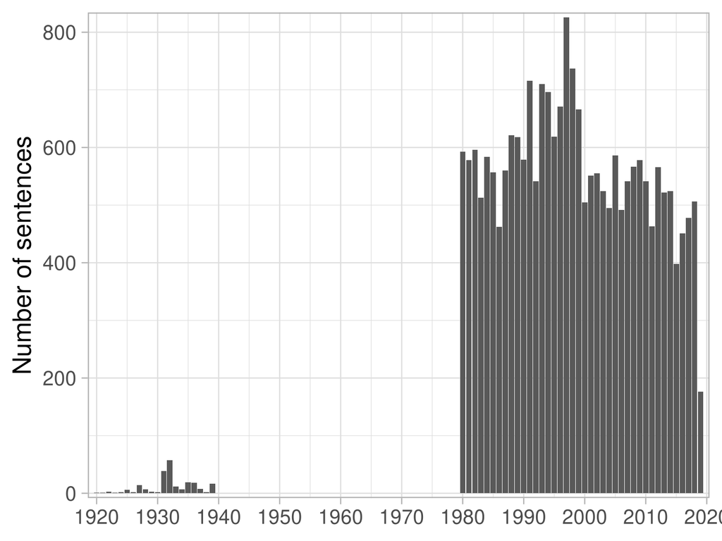

### Closest sentence from ‘rational’ and ‘rationality’ of the backbone community

| Sentence | Title | Year | Journal | Authors | Words Similarity |
| --- | --- | --- | --- | --- | --- |
| Statement of Problem The possibility that decision makers shape their economic behavior on the basis of rational expectations has profound implications for many empirical problems and policy issues. | [An Empirical Window on Rational Expectations Formation](http://www.jstor.org/stable/2109664) | 1992 | The Review of Economics and Statistics | Richard L. Pollock, Jack P. Suyderhoud | 0.846 |
| A number of competing explanations have been proposed, some of which reject the present value model, some which reject rational expectations, and others which reject the assumption of rational optimis… | [Irrational Analysts’ Expectations as a Cause of Excess Volatility in Stock Prices](http://www.jstor.org/stable/2957948) | 1997 | The Economic Journal | George Bulkley , Richard D. F. Harris | 0.809 |
| Simple pricing rules versus universal rationality Much of recent macroeconomic theorizing is based on the twin assumptions of individual optimizing behavior and rational expectations. | [Real Business Cycles in a Keynesian Macro Model](http://www.jstor.org/stable/2663708) | 1993 | Oxford Economic Papers | Howard F. Naish | 0.805 |
| Notions of procedural rationality are not absent from modern economics. | [Selecting Social Goals: Alternative Concepts of Rationality: Both the Orthodox and the Heterodox Must Be Able to Explain the Origin and Significance of Values](http://www.jstor.org/stable/3487542) | 1990 | The American Journal of Economics and Sociology | Robert D. Ley, L. E. Johnson | 0.795 |
| Since ‘normal science’ in economics primarily involves deriving the testing implications of the assumption of rationality, it seems natural to yield to this temptation by looking for areas in which th… | [Continuity and Change in the Economics Industry](http://www.jstor.org/stable/2233846) | 1991 | The Economic Journal | Richard Schmalensee | 0.795 |
| In The Rational Foundations of Economic Behavior, edited by Kenneth J Arrow, Enrico Colombatto, Marc Perlman, and Christian Schmidt, Proceedings of the IEA Conference held in Turin, Italy. | [COMMON COMPONENTS OF RISK AND UNCERTAINTY ATTITUDES ACROSS CONTEXTS AND DOMAINS: EVIDENCE FROM 30 COUNTRIES](http://www.jstor.org/stable/24539256) | 2015 | Journal of the European Economic Association | Ferdinand M. Vieider, Mathieu Lefebvre , Ranoua Bouchouicha , Thorsten Chmura , Rustamdjan Hakimov , Michal Krawczyk , Peter Martinsson | 0.788 |
| The assumption of a constant rate of discount is not merely sufficient to generate time-consistent choices; it may be implied by a certain type of rational reasoning. | [The Endogenous Determination of Time Preference](http://www.jstor.org/stable/2951254) | 1997 | The Quarterly Journal of Economics | Gary S. Becker , Casey B. Mulligan | 0.787 |
| We remark that Proposition 3 applies despite the rational expectations assumption: though every agent knows the model, the market machanism forces it to rationally choose the longterm slowest growth t… | [Exploring Growth Trajectories](http://www.jstor.org/stable/40215967) | 1997 | Journal of Economic Growth | Guido Cozzi | 0.786 |
| While the authors claim that their estimates are consistent with “economic theory”-meaning the idea of rational, foresighted people-they have made numerous assumptions that seem at variance with such … | [Should Generational Accounts Replace Public Budgets and Deficits?](http://www.jstor.org/stable/2138153) | 1994 | The Journal of Economic Perspectives | Robert Haveman | 0.786 |
| Given how private agents form their expectations, a rational policymaker, in choosing policy to maximize UO, the expected value of present and future realizations of his preference function, has to si… | [Inflation and Reputation with Generic Policy Preferences](http://www.jstor.org/stable/1992305) | 1990 | Journal of Money, Credit and Banking | Herschel I. Grossman | 0.784 |
| Mainstream neoclassical conclusions about the virtues of market arrangements rest foursquare on the comprehensive rationality of individual agents. | [Evolutionary Theorizing in Economics](http://www.jstor.org/stable/2696495) | 2002 | The Journal of Economic Perspectives | Richard R. Nelson, Sidney G. Winter | 0.783 |
| conclude that their results are incompatible with the behaviour of standard, rational agents but consistent with both projection bias and salience. | [Something in the Air](http://www.jstor.org/stable/26543944) | 2018 | The Review of Economic Studies | TOM Y. CHANG , WEI HUANG , YONGXIANG WANG | 0.783 |
| In this paper, a rational choice explanation for this fact is offered. | [Location Choice as a Signal for Product Quality: The Economics of “Made in Germany”](http://www.jstor.org/stable/40752001) | 1997 | Journal of Institutional and Theoretical Economics (JITE) / Zeitschrift für die gesamte Staatswissenschaft | Justus Haucap , Christian Wey , Jens F. Barmbold | 0.781 |
| In other words, the claim that the rational actor approach offers a first-round presumption that market and political behav iour will be the same?that the “onus of proof” lies with those who dispute b… | [Psychological Dimensions in Voter Choice](http://www.jstor.org/stable/27698312) | 2008 | Public Choice | Geoffrey Brennan | 0.778 |
| Reading again that work under this spirit, will provide some further arguments to all those who hold textbook type formal economic rationality as responsible for disorienting social science to “false … | [ON THE SOCIAL NATURE OF RATIONALITY IN ADAM SMITH AND JOHN STUART MILL](http://www.jstor.org/stable/43107634) | 2005 | Cahiers d’économie politique / Papers in Political Economy | Michel S. Zouboulakis | 0.776 |
| Subsequent sections address the problem of reductionism in economic theory, and show that mainstream explanations of economic and institutional phenomena in terms of given, rational individuals are no… | [The Approach of Institutional Economics](http://www.jstor.org/stable/2564954) | 1998 | Journal of Economic Literature | Geoffrey M. Hodgson | 0.775 |
| ‘Probabilities vs. money: a test of some fundamental assumptions about rational decision making’, EcoNoMIC JOURNAL, vol. | [Precautionary Saving and Social Learning across Generations: An Experiment](http://www.jstor.org/stable/3590289) | 2003 | The Economic Journal | T. Parker Ballinger, Michael G. Palumbo , Nathaniel T. Wilcox | 0.765 |
| His concern not only with the importance of institutional changes, but also with a more accurate view of human behavior than that suggested by today’s neoclassical economic rationality, is presented i… | [The Misperception of Walras](http://www.jstor.org/stable/2117989) | 1994 | The American Economic Review | B. Bürgenmeier | 0.764 |
| As the latter is presupposed by rational choice th ory to reject it is to challenge the notion of practical reason at the heart of neoclassical economics. | [A Rhetorical Conception of Practical Rationality](http://www.jstor.org/stable/4227126) | 1996 | Journal of Economic Issues | Kevin Quinn | 0.761 |
| However, once we break ourselves of the habit of associating policy regimes with fixed parameters, it is seen that there is no justification for restricting the assumptions of rationality and rational… | [Econometric Policy Evaluation: Note](http://www.jstor.org/stable/1804021) | 1984 | The American Economic Review | Thomas F. Cooley, Stephen F. LeRoy, Neil Raymon | 0.758 |

### Closest sentences of the backbone community’s centroid

| Sentence | Title | Year | Journal | Authors | Centroid Similarity |
| --- | --- | --- | --- | --- | --- |
| ‘Lapses in economic theory lie not in its acceptance of the principle of scarcity and preferences, nor indeed in the fact that it takes the market as a possible instrument through which the preference… | [Amiya Kumar Dasgupta (1903-1992)](http://www.jstor.org/stable/2235071) | 1994 | The Economic Journal | Amartya Sen | 0.8086327 |
| Thus, if decisions on either side of the market are made in conditions other than those assumed to hold in the idealized competitive structure, the price at which the transaction occurs does not conta… | [The Nearly Good, the Bad, and the Ugly in Cost-Effectiveness Analysis of Health Care](http://www.jstor.org/stable/4227090) | 1996 | Journal of Economic Issues | William Hildred, Larry Watkins | 0.8068752 |
| From this results the dilemma of economic theory which cannot foreswear abstractions and which must therefore chose and decide what is essential and what may be neglected. | [Historical School and “Methodenstreit”](http://www.jstor.org/stable/40751103) | 1988 | Journal of Institutional and Theoretical Economics (JITE) / Zeitschrift für die gesamte Staatswissenschaft | Karl Häuser | 0.8044158 |
| It is interesting to note that an economic interpretation can be given. | [Identification of Covariance Structures](http://www.jstor.org/stable/4093224) | 2006 | Econometric Theory | Riccardo Lucchetti | 0.8022395 |
| If we are to try to make sense of such arguments from an economic point of view, it may help to expand a bit the conventional boundaries of economic analysis. | [Royalties for Artists versus Royalties for Authors and Composers](http://www.jstor.org/stable/41810769) | 2001 | Journal of Cultural Economics | HENRY HANSMANN , MARINA SANTILLI | 0.7985193 |
| The kind of relations assumed to be relevant for an explananation of “economic outcomes” differs in scope and structure from the usual “rationality of market decisions.” | [A Network Analysis of Markets](http://www.jstor.org/stable/4226515) | 1992 | Journal of Economic Issues | P. R. Beije , J. Groenewegen | 0.7982179 |
| The arguments presented in this paper rely on a more sophisticated economic framework. | [Employment Arguments for Protection and the Vita Theory](http://www.jstor.org/stable/40324888) | 1984 | Eastern Economic Journal | H. Peter Gray | 0.7979982 |
| that an important limiting case of real-world interest could be analyzed, with a large gain in terms simplicity, in terms of price-taking behaviour, and hence they gave a justification for taking the … | [Concepts of Competition](http://www.jstor.org/stable/2663661) | 1995 | Oxford Economic Papers | John Vickers | 0.7972919 |
| Many of the controversies of economic theory have been concerned with the behaviour of a small number of self-interested decision makers, or with economic behaviour when the assumptions of perfect com… | [Non-Cooperative Strategies for Dynamic Policy Games and the Problem of Time Inconsistency](http://www.jstor.org/stable/2662670) | 1984 | Oxford Economic Papers | A. J. Hughes Hallett | 0.7963171 |
| An answer to an economic question can be obtained only at the cost of making some assumptions; some may be ‘natural’ economic assumptions, but others are formal, purely mathematical assumptions, and s… | [Presidential Address: Mathematics in economics and econometrics](http://www.jstor.org/stable/41336401) | 2011 | The Canadian Journal of Economics / Revue canadienne d’Economique | Victoria Zinde-Walsh | 0.7945211 |
| Rather than challenge this view, in this paper we mean to point to the more contentious aspects of markets. | [Market and Society: How Do They Relate, and How Do They Contribute to Welfare?](http://www.jstor.org/stable/4228146) | 2005 | Journal of Economic Issues | Wilfred Dolfsma, John Finch , Robert McMaster | 0.7939408 |
| Going beyond this particular construction, I attempt to bring into sharper focus the nature of the underlying conceptual problem as well as its significance for economic analysis. | [On the timing of wage payments](http://www.jstor.org/stable/23596556) | 1981 | Cambridge Journal of Economics | Donald J. Harris | 0.7930412 |
| This brings me back to the aim of maintaining a critical element in economic method ology about the substance of economic theories. | [Rhetoric vs realism in economic methodology: a critical assessment of recent contributions](http://www.jstor.org/stable/23600472) | 2001 | Cambridge Journal of Economics | Fabienne Peter | 0.7926054 |
| Much has been written and said about the unreasonableness of the rational economic man, the lack of accord between the model of perfect competition and actual industrial structures, the failure of mar… | [The Rhetoric of Economics Texts](http://www.jstor.org/stable/4226317) | 1990 | Journal of Economic Issues | David George | 0.7920347 |
| Thus, most of the authors invoke a condition for an optimal economic outcome, but only one draws a private/social distinction that immediately suggests that free markets may not yield the best outcome… | [Market Failures and Efficiency in the Principles Course](http://www.jstor.org/stable/1182955) | 1999 | The Journal of Economic Education | Janusz R. Mrozek | 0.7915895 |

### Closest sentences of each kmean cluster’s centroid composing the backbone community

#### Top terms 9_31: institutional_economics, institutionalism, institutionalists, veblen’s, institutionalist (1920-1939)

| Sentence | Title | Year | Journal | Authors | Distance to Centroid |
| --- | --- | --- | --- | --- | --- |
| ECONOMIC THEORY-INSTITUTIONALISM: WHAT IT IS AND WHAT IT HOPES TO BECOME PAUL T. HOMAN, Chairman M. A. COPELAND.-A natural science viewpoint requires important modifications of neo-classical economic … | [Economic Theory–Institutionalism: What It Is and What It Hopes to Become](http://www.jstor.org/stable/1802980) | 1931 | The American Economic Review | Paul T. Homan , M. A. Copeland , Eveline M. Burns, J. J. Spengler , O. H. Taylor , William Jaffé | 5.582587 |
| In this note the writer merely desires to point out that Professor Homan has attempted to set up an institutional economics differentiated from traditional economics by conceiving both as systematic b… | [An Appraisal of Institutional Economics: Comment](http://www.jstor.org/stable/1805296) | 1932 | The American Economic Review | Nathan L. Silverstein | 5.676461 |
| 4 COMMONS ON INSTITUTIONAL ECONOMICS Institutional Economics is a militant sage’s summing up of his lifetime’s thinking. | [Commons on Institutional Economics](http://www.jstor.org/stable/1807801) | 1935 | The American Economic Review | Wesley C. Mitchell | 5.923373 |
| VII One of the chief services that Professor Commons’s treatise performs is to clarify the relations of “institutional economics” to what for lack of a better term is called “orthodox economics.” | [Commons on Institutional Economics](http://www.jstor.org/stable/1807801) | 1935 | The American Economic Review | Wesley C. Mitchell | 6.026255 |
| The differentiating characteristics of an institutional economics are hard to find; but some economists have oriented their thinking by a postulated institutional prescription of human conduct in an e… | [An Appraisal of Institutional Economics](http://www.jstor.org/stable/1807255) | 1932 | The American Economic Review | Paul T. Homan | 6.207066 |

#### Top terms 9_94: neoclassical, determinate_solutions, agents, neoclassical_economics, mainstream (1980-1989)

| Sentence | Title | Year | Journal | Authors | Distance to Centroid |
| --- | --- | --- | --- | --- | --- |
| Koopmans, Tjalling C. Three Essays on the State of Economic Science. | [Survival and Pareto Optimality in Public Utility Rate Making](http://www.jstor.org/stable/4537558) | 1980 | Journal of Post Keynesian Economics | Warren J. Samuels | 6.963586 |
| 4, October-December 1985 Towards an Empirically Valid Economics Alfred S. Eichner* The movement to replace neoclassical theory with an alternative body of theory, one that can place economics on a sci… | [Towards an Empirically Valid Economics](http://www.jstor.org/stable/40325007) | 1985 | Eastern Economic Journal | Alfred S. Eichner | 6.974045 |
| 820 Revue economique - No 5, septembre 1980. it is not enough to possess a theoretical under-standing of the general principles on which the economic system works. | [Planning Approach to Economic Policy Formation](http://www.jstor.org/stable/3501353) | 1980 | Revue économique | Wassily Leontief | 7.013611 |
| Economic theory has always to be mixed with a large dollop of fact before prescriptions for action can be framed; but the facts are usually obscure, disputed, seen through different eyes against a dif… | [Economics in Theory and Practice](http://www.jstor.org/stable/1805562) | 1985 | The American Economic Review | Alec Cairncross | 7.023700 |
| Concluding Comments The discipline of economics has taught us through various historic, economic events that the decisions of the seller are premised on a course of action that will best further his o… | [AN ECONOMIC AND LEGAL ASSESSMENT OF RECENT VISUAL ARTISTS’ REVERSION RIGHTS AGREEMENTS IN THE UNITED STATES](http://www.jstor.org/stable/41804883) | 1982 | Journal of Cultural Economics | Carl M. Colonna , Carol G. Colonna | 7.075438 |

#### Top terms 9_97: revision_received, inquiry_vol, economics_university, manuscript_received, economic_inquiry (1980-1989)

| Sentence | Title | Year | Journal | Authors | Distance to Centroid |
| --- | --- | --- | --- | --- | --- |
| This paper was presented at the Canadian Economic Theory Conference, Montreal, May 1978. | [Increasing Generalized Correlation: A Definition and Some Economic Consequences](http://www.jstor.org/stable/134617) | 1980 | The Canadian Journal of Economics / Revue canadienne d’Economique | Larry G. Epstein, Stephen M. Tanny | 6.392231 |
| 1 March 1988 Economic Theory as an Art Form Alan W. Dyer . | [Economic Theory as an Art Form](http://www.jstor.org/stable/4225961) | 1988 | Journal of Economic Issues | Alan W. Dyer | 6.401385 |
| National Institute Economie Review a - i- CHAPTER I. | [CHAPTER I. THE WORLD ECONOMY](http://www.jstor.org/stable/23875506) | 1980 | National Institute Economic Review | NULL | 6.463476 |
| Discussion paper, University of Dortmund, Department of Econom | [Competition of Newspapers and the Location of Political Parties](http://www.jstor.org/stable/30025173) | 1989 | Public Choice | Norbert Schulz , Joachim Weimann | 6.536181 |
| The first version of this paper was presented to the Seventh Canadian Economic Theory Conference, University of Alberta, May 1982. | [Optimal Leisure-Effort Choice with Endogenously Determined Earnings](http://www.jstor.org/stable/2534838) | 1983 | Journal of Labor Economics | Peter J. McCabe | 6.629275 |

#### Top terms 9_112: contingent_valuation, expected_utility, economic_intuition, optimal, optimal_plans (1990-1999)

| Sentence | Title | Year | Journal | Authors | Distance to Centroid |
| --- | --- | --- | --- | --- | --- |
| Moreover, Professor Mirowski’s book cannot be reviewed adequately in a short note because his sweeping claim encompasses over a century of economic theorising, his historical account and his arguments… | [Economics as Social Physics](http://www.jstor.org/stable/2233566) | 1991 | The Economic Journal | D. A. Walker | 7.057319 |
| This paper attempts to bridge the gap between economic theory and observations from the field. | [The Evolution of Social Norms in Common Property Resource Use](http://www.jstor.org/stable/2118304) | 1996 | The American Economic Review | Rajiv Sethi , E. Somanathan | 7.084596 |
| Our results were motivated by, and have implications for, utility theory and we begin in ?2 with a brief account of the theory. | [Utility Theory and Continuous Monotonic Functions](http://www.jstor.org/stable/25054784) | 1994 | Economic Theory | Alan F. Beardon | 7.157060 |
| An opposing yet potentially complementary theory is derived from an economic perspective, arguably similar to that proposed by Boserup in her later work. | [Agricultural Intensification, Diversification, and Commercial Production among Smallholder Coffee Growers in Central Kenya](http://www.jstor.org/stable/144250) | 1999 | Economic Geography | Bryan Dorsey | 7.366647 |
| The “implications of Jaffé’s thesis are important issues for the history of economic thought. | [The Walras Paradox](http://www.jstor.org/stable/40325613) | 1995 | Eastern Economic Journal | Roger Koppl | 7.367217 |

#### Top terms 9_118: institutional_economics, mainstream, neoclassical, neoclassical_economics, mainstream_economics (1990-1999)

| Sentence | Title | Year | Journal | Authors | Distance to Centroid |
| --- | --- | --- | --- | --- | --- |
| On Method What has been said should not be intended as an argument for the incommensurability of economic theories - as if each au thor constructed a different object of knowledge which was linked in … | [HISTORY OF ECONOMIC THOUGHT AS A PROBLEM](http://www.jstor.org/stable/23722222) | 1994 | History of Economic Ideas | Riccardo Bellofiore | 6.614624 |
| In Chichilnisky, Graciela, The Formulation of Economic Theory: Essays in Honor of Kenneth Arrow. | [Global Environmental Risks](http://www.jstor.org/stable/2138501) | 1993 | The Journal of Economic Perspectives | Graciela Chichilnisky, Geoffrey Heal | 6.801234 |
| Theoretical Systems in Economics: Conflict and Dialogue The most important effects on the economic disciplines of this post-epistemological revolution seem to be two deep changes that are involving pr… | [EPISTEMIC RELATIVISM, THE POST-MODERN TURN IN PHILOSOPHY, AND THE HISTORY OF ECONOMIC THOUGHT](http://www.jstor.org/stable/23722225) | 1994 | History of Economic Ideas | Ernesto Screpanti | 6.822283 |
| In this essay we shall attempt to take into account both traditional neoclassical views and the new, more institutional, research which is currently entering the economic mainstream. | [The feminist challenge to neoclassical economics](http://www.jstor.org/stable/23599798) | 1993 | Cambridge Journal of Economics | Frances R. Woolley | 6.838783 |
| Introduction In the last decade, there has been an increase in the scope and volume of research on the economics profession and its practitioners.1 Also, historians of economic thought have traced the… | [Philosophical Pattern Comparisons among Eminent Economists](http://www.jstor.org/stable/25603945) | 1993 | The American Economist | Michael Szenberg | 6.892262 |

#### Top terms 9_128: compilation_royal, journal_compilation, compilation, royal_economic, mainstream (2000-2009)

| Sentence | Title | Year | Journal | Authors | Distance to Centroid |
| --- | --- | --- | --- | --- | --- |
| This brings me back to the aim of maintaining a critical element in economic method ology about the substance of economic theories. | [Rhetoric vs realism in economic methodology: a critical assessment of recent contributions](http://www.jstor.org/stable/23600472) | 2001 | Cambridge Journal of Economics | Fabienne Peter | 6.473395 |
| “The Role of the Histoiy of Economic Thought in the Understanding of Modern Economics.” | [Paradigms and Novelty in Economics: The History of Economic Thought as a Source of Enlightenment](http://www.jstor.org/stable/27739810) | 2009 | The American Journal of Economics and Sociology | Wilfred Dolfsma , Patrick J. Welch | 6.584833 |
| ‘The Duhem-Quine Thesis in Economics: A Reinterpre tation’, Paper presented at the 20th World Congress of Philosophy, Boston, MS. | [Dealing with the Duhem—Quine thesis in financial economics: can causal holism help?](http://www.jstor.org/stable/23601915) | 2006 | Cambridge Journal of Economics | Siobhain McGovern | 6.942056 |
| Paper presented at the Conference on Economic Theory, Philosophy, and Contemporaiy Social Issues, Cambridge, MA. | [An Evaluation of Keynes’s Projected Possibilities](http://www.jstor.org/stable/27739706) | 2008 | The American Journal of Economics and Sociology | C.-Y. Cynthia Lin | 7.080878 |
| Taking this last quote as a starting point for thinking about the dominant “habits of thought” in today’s economic theory, one can depart from Veblen’s original focus and address the question placed o… | [**“Why is Economics not an Evolutionary Science?” New Answers to Veblen’s Old Question**](http://www.jstor.org/stable/40647677) | 2009 | Journal of Economic Issues | Leonhard Dobusch, Jakob Kapeller | 7.098727 |

#### Top terms 9_141: doi, issn, issues_association, mohr, heterodox (2010-2019)

| Sentence | Title | Year | Journal | Authors | Distance to Centroid |
| --- | --- | --- | --- | --- | --- |
| My article indicates parallel developments and discussions within economics and interprets Luhmann’s insights in light of modern economic thought. | [Economy as a Social System: Niklas Luhmann’s Contribution and its Significance for Economics](http://www.jstor.org/stable/23526088) | 2013 | American Journal of Economics and Sociology | Ivan A. Boldyrev | 6.068684 |
| This article aims at making a general contribution to our understanding of economics, as well as a few specific ones. | [Some institutions (social norms and conventions) of contemporary mainstream economics, macroeconomics and financial economics](http://www.jstor.org/stable/26784186) | 2017 | Cambridge Journal of Economics | David Dequech | 6.764295 |
| and Catherine Vibest ^Toulouse School of Economics, ^Goethe University Frankfurt and ?CEPR Final version received 29 March 2008. | [Railway (De)Regulation: A European Efficiency Comparison](http://www.jstor.org/stable/27764397) | 2010 | Economica | GUIDO FRIEBEL , MARC IVALDI , CATHERINE VIBES | 6.770126 |
| Economie Perspectives Bullard, James, and Christopher J Waller. | [Central Bank Design](http://www.jstor.org/stable/23560020) | 2013 | The Journal of Economic Perspectives | Ricardo Reis | 6.868361 |
| This article was Gordon’s presidential address delivered at the Meet ing of the American Economic Association in 1975, where he addressed two themes: «First, the mainstream of economic theory sacrific… | [MARK BLAUG (1927-2011). AN UNREPENTANT LAKATOSIAN](http://www.jstor.org/stable/23723602) | 2012 | History of Economic Ideas | Marcel Boumans | 7.069234 |

### Top articles (most sentences) of the backbone cluster

| Title | Year | Journal | Authors | Number sentences | Words Similarity |
| --- | --- | --- | --- | --- | --- |
| [The Alleged Value Neutrality of Economics: An Alternative View](http://www.jstor.org/stable/4225142) | 1982 | Journal of Economic Issues | Larry Dwyer | 60 | 0.624 |
| [Value Judgments and Value Neutrality in Economics](http://www.jstor.org/stable/3548914) | 2006 | Economica | Philippe Mongin | 30 | 0.627 |
| [Morality, Maximization, and Economic Behavior](http://www.jstor.org/stable/1061094) | 1997 | Southern Economic Journal | Alan G. Isaac | 28 | 0.612 |
| [Limits to the expansion of neoclassical economics](http://www.jstor.org/stable/23598136) | 1988 | Cambridge Journal of Economics | Phedon Nicolaides | 24 | 0.614 |
| [Institutional Economics and the Evolutionary Metaphor](http://www.jstor.org/stable/40751943) | 1996 | Journal of Institutional and Theoretical Economics (JITE) / Zeitschrift für die gesamte Staatswissenschaft | Gisela Kubon-Gilke | 23 | 0.649 |
| [Does Institutionalism Complement or Compete with “Orthodox Economics”?](http://www.jstor.org/stable/1808612) | 1931 | The American Economic Review | E. M. Burns | 20 | 0.626 |
| [‘Value Freedom’ and the Scope of Economic Inquiry: I. Positivism’s Standard View and the Political Economists](http://www.jstor.org/stable/3486191) | 1982 | The American Journal of Economics and Sociology | Larry Dwyer | 20 | 0.609 |
| [A Realist Perspective on Contemporary “Economic Theory”](http://www.jstor.org/stable/4226914) | 1995 | Journal of Economic Issues | Tony Lawson | 20 | 0.631 |
| [Economics and Psychology: Lessons for Our Own Day From the Early Twentieth Century](http://www.jstor.org/stable/2729503) | 1996 | Journal of Economic Literature | Shira B. Lewin | 20 | 0.619 |
| [Varieties of Capitalism and Varieties of Economic Theory](http://www.jstor.org/stable/4177194) | 1996 | Review of International Political Economy | Geoffrey M. Hodgson | 20 | 0.598 |
| [Rhetoric vs realism in economic methodology: a critical assessment of recent contributions](http://www.jstor.org/stable/23600472) | 2001 | Cambridge Journal of Economics | Fabienne Peter | 20 | 0.616 |
| [Some institutions (social norms and conventions) of contemporary mainstream economics, macroeconomics and financial economics](http://www.jstor.org/stable/26784186) | 2017 | Cambridge Journal of Economics | David Dequech | 20 | 0.605 |
| [Kaldor on method: a challenge to contemporary methodology](http://www.jstor.org/stable/23599747) | 1997 | Cambridge Journal of Economics | Thomas A. Boylan, Paschal O’Gorman | 19 | 0.608 |
| [ECONOMISTS AND LANGUAGE](http://www.jstor.org/stable/23722607) | 1998 | History of Economic Ideas | Jan Horst Keppler | 19 | 0.612 |
| [THE NOTION OF DYNAMIC ECONOMICS](http://www.jstor.org/stable/43828063) | 2012 | Giornale degli Economisti e Annali di Economia | Aldo Montesano, H. Ampt , I. Moscati | 19 | 0.608 |

### Top articles (most sentences) of the cluster for each time window

#### Top articles for 9_31: institutional_economics, institutionalism, institutionalists, veblen’s, institutionalist (1920-1939)

| Title | Year | Journal | Authors | Number sentences | Words Similarity |
| --- | --- | --- | --- | --- | --- |
| [Does Institutionalism Complement or Compete with “Orthodox Economics”?](http://www.jstor.org/stable/1808612) | 1931 | The American Economic Review | E. M. Burns | 20 | 0.626 |
| [An Appraisal of Institutional Economics](http://www.jstor.org/stable/1807255) | 1932 | The American Economic Review | Paul T. Homan | 15 | 0.635 |
| [Institutional Economics](http://www.jstor.org/stable/1813952) | 1932 | The American Economic Review | W. H. Kiekhofer , John Maurice Clark, Paul T. Homan , Hugh M. Fletcher , Max J. Wasserman , Willard E. Atkins , Francis D. Tyson , William W. Hewett , R. T. Ely | 14 | 0.613 |
| [Types of Institutionalism](http://www.jstor.org/stable/1822897) | 1932 | Journal of Political Economy | Abram L. Harris | 12 | 0.623 |
| [Economic Theory–Institutionalism: What It Is and What It Hopes to Become](http://www.jstor.org/stable/1802980) | 1931 | The American Economic Review | Paul T. Homan , M. A. Copeland , Eveline M. Burns, J. J. Spengler , O. H. Taylor , William Jaffé | 10 | 0.629 |
| [Commons on Institutional Economics](http://www.jstor.org/stable/1807801) | 1935 | The American Economic Review | Wesley C. Mitchell | 8 | 0.622 |
| [The Concept of National Planning in Institutional Economics](http://www.jstor.org/stable/1053234) | 1939 | Southern Economic Journal | Allan G. Gruchy | 8 | 0.611 |
| [Institutional Economics](http://www.jstor.org/stable/495) | 1931 | The American Economic Review | John R. Commons | 7 | 0.614 |
| [Issues in Economic Theory: an Attempt to Clarify](http://www.jstor.org/stable/1884782) | 1928 | The Quarterly Journal of Economics | Paul T. Homan | 6 | 0.629 |
| [Sociological Elements in Economic Thought](http://www.jstor.org/stable/1883862) | 1935 | The Quarterly Journal of Economics | Talcott Parsons | 6 | 0.616 |

#### Top articles for 9_94: neoclassical, determinate_solutions, agents, neoclassical_economics, mainstream (1980-1989)

| Title | Year | Journal | Authors | Number sentences | Words Similarity |
| --- | --- | --- | --- | --- | --- |
| [The Alleged Value Neutrality of Economics: An Alternative View](http://www.jstor.org/stable/4225142) | 1982 | Journal of Economic Issues | Larry Dwyer | 59 | 0.624 |
| [Limits to the expansion of neoclassical economics](http://www.jstor.org/stable/23598136) | 1988 | Cambridge Journal of Economics | Phedon Nicolaides | 23 | 0.612 |
| [‘Value Freedom’ and the Scope of Economic Inquiry: I. Positivism’s Standard View and the Political Economists](http://www.jstor.org/stable/3486191) | 1982 | The American Journal of Economics and Sociology | Larry Dwyer | 20 | 0.609 |
| [Another Defense of Methodological Apriorism](http://www.jstor.org/stable/40325024) | 1983 | Eastern Economic Journal | Robert L. Greenfield, Joseph T. Salerno | 17 | 0.622 |
| [Moral Philosophy, Cognitive Psychology and Economic Theory](http://www.jstor.org/stable/40325006) | 1985 | Eastern Economic Journal | Sandra R. Baum | 17 | 0.604 |
| [Classical Mechanics with an Ethical Dimension: Professor Tinbergen’s Economics](http://www.jstor.org/stable/4226032) | 1988 | Journal of Economic Issues | Kurt Dopfer | 17 | 0.596 |
| [Determinate Solutions and Valuational Processes: Overcoming the Foreclosure of Process](http://www.jstor.org/stable/4538153) | 1989 | Journal of Post Keynesian Economics | Warren J. Samuels | 17 | 0.613 |
| [‘Value Freedom’ and the Scope of Economic Inquiry: II. The Fact/Value Continuum and the Basis for Scientific and Humanistic Policy](http://www.jstor.org/stable/3486607) | 1983 | The American Journal of Economics and Sociology | Larry Dwyer | 16 | 0.610 |
| [The Rhetoric of Economics](http://www.jstor.org/stable/2724987) | 1983 | Journal of Economic Literature | Donald N. McCloskey | 16 | 0.600 |
| [Abstraction, tendencies and stylised facts: a realist approach to economic analysis](http://www.jstor.org/stable/23598149) | 1989 | Cambridge Journal of Economics | Tony Lawson | 16 | 0.610 |

#### Top articles for 9_97: revision_received, inquiry_vol, economics_university, manuscript_received, economic_inquiry (1980-1989)

| Title | Year | Journal | Authors | Number sentences | Words Similarity |
| --- | --- | --- | --- | --- | --- |
| [ON THE DIFFICULTIES AND DEFICIENCIES OF MATHEMATICAL-ECONOMIC RESEARCH IN HUNGARY](http://www.jstor.org/stable/40728842) | 1981 | Acta Oeconomica | J. KORNAI | 4 | 0.627 |
| [The Fundamental Problem](http://www.jstor.org/stable/2662780) | 1981 | Oxford Economic Papers | W. A. Eltis | 4 | 0.614 |
| [Economic Theory and the Problem of Translation: Part Two](http://www.jstor.org/stable/4225251) | 1982 | Journal of Economic Issues | Ken Dennis | 4 | 0.629 |
| [The Macroeconomic Implications of Wage Indexation in a Two-Sector Open Economy](http://www.jstor.org/stable/40439596) | 1988 | Weltwirtschaftliches Archiv | Rogério L. Zandamela | 4 | 0.618 |
| [Toward a Revision of the Economic Theory of Individual Behavior](http://www.jstor.org/stable/4226134) | 1989 | Journal of Economic Issues | Daniel R. Fusfeld | 4 | 0.617 |
| [Methods and Problems in Business Cycle Theory](http://www.jstor.org/stable/1992030) | 1980 | Journal of Money, Credit and Banking | Robert E. Lucas, Jr. | 3 | 0.595 |
| [Basic Issues in Econometrics: Past and Present](http://www.jstor.org/stable/25603532) | 1982 | The American Economist | Arnold Zellner | 3 | 0.647 |
| [Performance in the “Basic Economics Test” (BET) and “Trade-Offs”](http://www.jstor.org/stable/1182671) | 1983 | The Journal of Economic Education | John F. Chizmar , Ronald S. Halinski | 3 | 0.604 |
| [New Thinking about the Market, 1896-1904: Some American Economists on Investment and the Theory of Surplus Capital](http://www.jstor.org/stable/2120077) | 1983 | The Journal of Economic History | Carl P. Parrini, Martin J. Sklar | 3 | 0.599 |
| [Harry G. Johnson: A Bibliography](http://www.jstor.org/stable/1837165) | 1984 | Journal of Political Economy | Vicky M. Longawa | 3 | 0.607 |

#### Top articles for 9_112: contingent_valuation, expected_utility, economic_intuition, optimal, optimal_plans (1990-1999)

| Title | Year | Journal | Authors | Number sentences | Words Similarity |
| --- | --- | --- | --- | --- | --- |
| [Dynamic Choice and the Common Ratio Effect: An Experimental Investigation](http://www.jstor.org/stable/2566184) | 1998 | The Economic Journal | Robin P. Cubitt, Chris Starmer , Robert Sugden | 17 | 0.598 |
| [Choosing What to Choose](http://www.jstor.org/stable/40753025) | 1994 | Journal of Institutional and Theoretical Economics (JITE) / Zeitschrift für die gesamte Staatswissenschaft | James M. Buchanan | 10 | 0.599 |
| [Morality, Maximization, and Economic Behavior](http://www.jstor.org/stable/1061094) | 1997 | Southern Economic Journal | Alan G. Isaac | 10 | 0.608 |
| [Endogenous Preferences: The Cultural Consequences of Markets and Other Economic Institutions](http://www.jstor.org/stable/2564952) | 1998 | Journal of Economic Literature | Samuel Bowles | 10 | 0.607 |
| [Rational Choice: The Contrast between Economics and Psychology](http://www.jstor.org/stable/2937784) | 1991 | Journal of Political Economy | Vernon L. Smith | 9 | 0.618 |
| [Taking Ethics Seriously: Economics and Contemporary Moral Philosophy](http://www.jstor.org/stable/2728513) | 1993 | Journal of Economic Literature | Daniel M. Hausman , Michael S. McPherson | 9 | 0.613 |
| [Economics and Psychology: Lessons for Our Own Day From the Early Twentieth Century](http://www.jstor.org/stable/2729503) | 1996 | Journal of Economic Literature | Shira B. Lewin | 8 | 0.618 |
| [Induced Preferences, Dynamic Consistency and Dutch Books](http://www.jstor.org/stable/2554837) | 1997 | Economica | David Kelsey, Frank Milne | 8 | 0.607 |
| [Self-Control and Saving for Retirement](http://www.jstor.org/stable/2534671) | 1998 | Brookings Papers on Economic Activity | David I. Laibson , Andrea Repetto , Jeremy Tobacman , Robert E. Hall , William G. Gale , George A. Akerlof | 8 | 0.616 |
| [An Ontology of Economic Objects: An Application of Carl Menger’s Ideas](http://www.jstor.org/stable/3487719) | 1999 | The American Journal of Economics and Sociology | Gloria L. Zúñiga | 8 | 0.606 |

#### Top articles for 9_118: institutional_economics, mainstream, neoclassical, neoclassical_economics, mainstream_economics (1990-1999)

| Title | Year | Journal | Authors | Number sentences | Words Similarity |
| --- | --- | --- | --- | --- | --- |
| [Institutional Economics and the Evolutionary Metaphor](http://www.jstor.org/stable/40751943) | 1996 | Journal of Institutional and Theoretical Economics (JITE) / Zeitschrift für die gesamte Staatswissenschaft | Gisela Kubon-Gilke | 19 | 0.653 |
| [Morality, Maximization, and Economic Behavior](http://www.jstor.org/stable/1061094) | 1997 | Southern Economic Journal | Alan G. Isaac | 18 | 0.615 |
| [ITALIAN-STYLE PLURALISM IN ECONOMICS](http://www.jstor.org/stable/23722200) | 1994 | History of Economic Ideas | Duccio Cavalieri, Riccardo Faucci | 17 | 0.618 |
| [The Approach of Institutional Economics](http://www.jstor.org/stable/2564954) | 1998 | Journal of Economic Literature | Geoffrey M. Hodgson | 17 | 0.642 |
| [ECONOMISTS AND LANGUAGE](http://www.jstor.org/stable/23722607) | 1998 | History of Economic Ideas | Jan Horst Keppler | 16 | 0.612 |
| [A Realist Perspective on Contemporary “Economic Theory”](http://www.jstor.org/stable/4226914) | 1995 | Journal of Economic Issues | Tony Lawson | 14 | 0.635 |
| [Varieties of Capitalism and Varieties of Economic Theory](http://www.jstor.org/stable/4177194) | 1996 | Review of International Political Economy | Geoffrey M. Hodgson | 14 | 0.602 |
| [Kaldor on method: a challenge to contemporary methodology](http://www.jstor.org/stable/23599747) | 1997 | Cambridge Journal of Economics | Thomas A. Boylan, Paschal O’Gorman | 14 | 0.611 |
| [WHAT CAN WE ACCOMPLISH WITH HISTORICAL APPROACHES IN AN ADVANCED DISCIPLINE SUCH AS ECONOMICS?](http://www.jstor.org/stable/23722264) | 1993 | History of Economic Ideas | A. W. “Bob” Coats | 13 | 0.615 |
| [Economics and Psychology: Lessons for Our Own Day From the Early Twentieth Century](http://www.jstor.org/stable/2729503) | 1996 | Journal of Economic Literature | Shira B. Lewin | 12 | 0.619 |

#### Top articles for 9_128: compilation_royal, journal_compilation, compilation, royal_economic, mainstream (2000-2009)

| Title | Year | Journal | Authors | Number sentences | Words Similarity |
| --- | --- | --- | --- | --- | --- |
| [Value Judgments and Value Neutrality in Economics](http://www.jstor.org/stable/3548914) | 2006 | Economica | Philippe Mongin | 30 | 0.627 |
| [Rhetoric vs realism in economic methodology: a critical assessment of recent contributions](http://www.jstor.org/stable/23600472) | 2001 | Cambridge Journal of Economics | Fabienne Peter | 20 | 0.616 |
| [Theoretical isolation and explanatory progress: transaction cost economics and the dynamics of dispute](http://www.jstor.org/stable/23603565) | 2004 | Cambridge Journal of Economics | Uskali Mäki | 17 | 0.612 |
| [Economics, realism and reality: a comparison of Mäki and Lawson](http://www.jstor.org/stable/23601622) | 2008 | Cambridge Journal of Economics | Duncan Hodge | 17 | 0.616 |
| [Critical realism, empirical methods and inference: a critical discussion](http://www.jstor.org/stable/23602026) | 2002 | Cambridge Journal of Economics | Paul Downward, John H. Finch, John Ramsay | 16 | 0.617 |
| [The status of economics as a naturalistic social science](http://www.jstor.org/stable/23600463) | 2000 | Cambridge Journal of Economics | Clive Beed, Cara Beed | 15 | 0.618 |
| [Harry Gunnison Brown: An Orthodox Economist and His Contributions](http://www.jstor.org/stable/3487845) | 2002 | The American Journal of Economics and Sociology | Christopher K. Ryan | 15 | 0.601 |
| [Explaining modern economics (as a microcosm of society)](http://www.jstor.org/stable/23601665) | 2008 | Cambridge Journal of Economics | Vinca Bigo | 14 | 0.604 |
| [The Two Methods and the Hard Core of Economics](http://www.jstor.org/stable/27746860) | 2009 | Journal of Post Keynesian Economics | Luiz Carlos Bresser-Pereira | 14 | 0.636 |
| [Homo Economicus Meets G. H. Mead: A Contribution to the Critique of Economic Theory](http://www.jstor.org/stable/27739703) | 2008 | The American Journal of Economics and Sociology | David Wilson , William Dixon | 13 | 0.624 |

#### Top articles for 9_141: doi, issn, issues_association, mohr, heterodox (2010-2019)

| Title | Year | Journal | Authors | Number sentences | Words Similarity |
| --- | --- | --- | --- | --- | --- |
| [Some institutions (social norms and conventions) of contemporary mainstream economics, macroeconomics and financial economics](http://www.jstor.org/stable/26784186) | 2017 | Cambridge Journal of Economics | David Dequech | 20 | 0.605 |
| [THE NOTION OF DYNAMIC ECONOMICS](http://www.jstor.org/stable/43828063) | 2012 | Giornale degli Economisti e Annali di Economia | Aldo Montesano, H. Ampt , I. Moscati | 19 | 0.608 |
| [ECONOMIC MODELS AS ANALOGIES](http://www.jstor.org/stable/42919229) | 2014 | The Economic Journal | Itzhak Gilboa , Andrew Postlewaite, Larry Samuelson , David Schmeidler | 17 | 0.621 |
| [The Bond between Positive and Normative Economics](http://www.jstor.org/stable/26596206) | 2018 | Revue d’économie politique | Daniel M. Hausman | 16 | 0.622 |
| [ON THE ECONOMIC PRINCIPLE: A Letter to Professor V. Pareto](http://www.jstor.org/stable/43828049) | 2012 | Giornale degli Economisti e Annali di Economia | Benedetto Croce, Vilfredo Pareto, C.M. Meredith | 14 | 0.616 |
| [Shackle’s potential surprise function and the formation of expectations in a monetary economy](http://www.jstor.org/stable/43671474) | 2014 | Journal of Post Keynesian Economics | ANDRES F. CANTILLO | 13 | 0.599 |
| [ECONOMICS: BETWEEN PREDICTION AND CRITICISM](http://www.jstor.org/stable/45018858) | 2018 | International Economic Review | Itzhak Gilboa , Andrew Postlewaite, Larry Samuelson , David Schmeidler | 13 | 0.614 |
| [J. M. KEYNES, THINKER OF ECONOMIC COMPLEXITY](http://www.jstor.org/stable/23723514) | 2010 | History of Economic Ideas | Roberto Marchionatti | 12 | 0.631 |
| [THE «SOLITUDE OF THE REFORMIST». PUBLIC POLICY AND VALUE JUDGMENTS IN THE WORK OF FEDERICO CAFFÈ](http://www.jstor.org/stable/23723614) | 2012 | History of Economic Ideas | Paolo Ramazzotti | 12 | 0.609 |
| [What is this ‘school’ called neoclassical economics?](http://www.jstor.org/stable/23601776) | 2013 | Cambridge Journal of Economics | Tony Lawson | 12 | 0.612 |

### Most cited references in the backbone community

| First Author | Year | Journal | Citation by article | Citation by sentence |
| --- | --- | --- | --- | --- |
| RABIN-M | 1993 | AM ECON REV | 34 | 646 |
| KAHNEMAN-D | 1979 | ECONOMETRICA | 75 | 450 |
| FRIEDMAN-M | 1968 | AER | 11 | 341 |
| COASE-R | 1937 | ECONOMICA | 53 | 212 |
| KLAPPHOLZ-K | 1964 | BRIT J PHILOS SCI | 2 | 178 |
| GROSSMAN-S | 1986 | J POLIT EC | 70 | 140 |
| FEHR-E | 1999 | Q J ECON | 63 | 126 |
| FRIEDMAN-M | 1953 | ESSAYS POSITIVE EC | 6 | 114 |
| JENSEN-M | 1976 | J FINANCIAL EC | 45 | 90 |
| KYDLAND-F | 1977 | J POLITICAL EC | 37 | 74 |
| ENGLE-R | 1987 | ECONOMETRICA | 36 | 36 |
| TAYLOR-J | 1993 | CARNEGIE-ROCHESTER C | 35 | 35 |
| HART-O | 1990 | J POLIT ECON | 34 | 34 |
| MAKI-U | 1990 | REV POLITICAL EC | 2 | 34 |
| MAKI-U | 1994 | NEW DIRECTIONS EC ME | 2 | 34 |

| First Author | Year | Journal | Citation by article | Citation by sentence |
| --- | --- | --- | --- | --- |
| FRIEDMAN-M | 1953 | ESSAYS POSITIVE EC | 153 | 13923 |
| WILLIAMSON-O | 1985 | EC I CAPITALISM FIRM | 248 | 9176 |
| KEYNES-J | 1936 | GENERAL THEORY EMPLO | 264 | 8184 |
| WILLIAMSON-O | 1975 | MARKETS HIERARCHIES | 166 | 6640 |
| KEYNES-J | 1936 | GEN THEORY EMPLOYMEN | 183 | 4209 |
| LAWSON-T | 1997 | EC REALITY | 119 | 3808 |
| NELSON-R | 1982 | EVOLUTIONARY THEORY | 115 | 2760 |
| KEYNES-J | 1973 | COLLECTED WRITINGS | 124 | 2604 |
| SCHUMPETER-J | 1954 | HIST EC ANAL | 72 | 2088 |
| ARROW-K | 1971 | GENERAL COMPETITIVE | 82 | 1640 |
| FRIEDMAN-M | 1953 | METHODOLOGY POSITIVE | 40 | 1200 |
| KEYNES-J | 1973 | COLLECTED WRITINGS J | 74 | 1184 |
| DOWNS-A | 1957 | EC THEORY DEMOCRACY | 48 | 1104 |
| KUHN-T | 1962 | STRUCTURE SCI REVOLU | 16 | 944 |
| LATSIS-S | 1976 | METHOD APPRAISAL EC | 16 | 944 |

### Most cited references per kmean clusters

#### Top references 9_94: neoclassical, determinate_solutions, agents, neoclassical_economics, mainstream (1980-1989)

| First Author | Year | Journal | Citation by article | Citation by sentence |
| --- | --- | --- | --- | --- |
| RUDNER-R | 1953 | PHILOS SCI | 1 | 59 |
| HARSANYI-J | 1977 | SOCIAL RES | 1 | 59 |
| SAMUELSON-P | 1963 | AM EC REV | 1 | 59 |
| FIRTH-R | 1952 | PHILOS PHENOMENOLOGI | 1 | 59 |
| MACHLUP-F | 1955 | SO EC J | 1 | 59 |
| KLAPPHOLZ-K | 1964 | BRIT J PHILOS SCI | 1 | 59 |
| STREETEN-P | 1950 | Q J EC | 1 | 59 |
| HEILBRONER-R | 1973 | SOCIAL RES | 1 | 59 |
| KLAPPHOLZ-K | 1959 | ECONOMICA | 1 | 59 |
| WEBER-M | 1949 | METHODOLOGY SOCIAL S | 1 | 59 |

| First Author | Year | Journal | Citation by article | Citation by sentence |
| --- | --- | --- | --- | --- |
| FRIEDMAN-M | 1953 | ESSAYS POSITIVE EC | 49 | 2891 |
| KEYNES-J | 1936 | GENERAL THEORY EMPLO | 111 | 1110 |
| DOWNS-A | 1957 | EC THEORY DEMOCRACY | 48 | 1104 |
| ARROW-K | 1971 | GENERAL COMPETITIVE | 59 | 944 |
| KUHN-T | 1962 | STRUCTURE SCI REVOLU | 16 | 944 |
| LATSIS-S | 1976 | METHOD APPRAISAL EC | 16 | 944 |
| DEBREU-G | 1959 | COWLES F MONOGRAPH | 52 | 832 |
| HOLLIS-M | 1975 | RATIONAL EC MAN PHIL | 14 | 826 |
| SCHUMPETER-J | 1954 | HIST EC ANAL | 44 | 748 |
| KEYNES-J | 1973 | COLLECTED WRITINGS | 66 | 660 |

#### Top references 9_97: revision_received, inquiry_vol, economics_university, manuscript_received, economic_inquiry (1980-1989)

| First Author | Year | Journal | Citation by article | Citation by sentence |
| --- | --- | --- | --- | --- |
| BARRO-R | 1974 | JPE | 19 | 19 |
| MUTH-J | 1961 | ECONOMETRICA | 18 | 18 |
| HAUSMAN-J | 1978 | ECONOMETRICA | 16 | 16 |
| LUCAS-R | 1973 | AER | 14 | 14 |
| AZARIADIS-C | 1975 | JPE | 14 | 14 |
| HALL-R | 1978 | JPE | 13 | 13 |
| FISCHER-S | 1977 | J POLITICAL EC | 13 | 13 |
| JENSEN-M | 1976 | J FINANCIAL EC | 12 | 12 |
| DIXIT-A | 1977 | AM EC REV | 12 | 12 |
| BARRO-R | 1977 | AER | 12 | 12 |

| First Author | Year | Journal | Citation by article | Citation by sentence |
| --- | --- | --- | --- | --- |
| KEYNES-J | 1936 | GENERAL THEORY EMPLO | 36 | 108 |
| ARROW-K | 1971 | GENERAL COMPETITIVE | 23 | 92 |
| FRIEDMAN-M | 1953 | ESSAYS POSITIVE EC | 20 | 80 |
| SAMUELSON-P | 1947 | F EC ANAL | 26 | 78 |
| DEBREU-G | 1959 | THEORY VALUE AXIOMAT | 15 | 45 |
| HICKS-J | 1939 | VALUE CAPITAL | 13 | 39 |
| HICKS-J | 1979 | CAUSALITY EC | 13 | 39 |

#### Top references 9_112: contingent_valuation, expected_utility, economic_intuition, optimal, optimal_plans (1990-1999)

| First Author | Year | Journal | Citation by article | Citation by sentence |
| --- | --- | --- | --- | --- |
| ENGLE-R | 1987 | ECONOMETRICA | 36 | 36 |
| JENSEN-M | 1976 | J FINANCIAL EC | 33 | 33 |
| GROSSMAN-S | 1986 | J POLIT EC | 29 | 29 |
| KAHNEMAN-D | 1979 | ECONOMETRICA | 28 | 28 |
| KAHNEMAN-D | 1979 | ECONOMETRICA | 14 | 28 |
| LUCAS-R | 1988 | J MONETARY ECON | 27 | 27 |
| KYDLAND-F | 1977 | J POLITICAL EC | 27 | 27 |
| COASE-R | 1960 | J LAW EC | 26 | 26 |
| MEHRA-R | 1985 | J MONETARY EC | 24 | 24 |
| ROMER-P | 1986 | J POLITICAL EC | 24 | 24 |

| First Author | Year | Journal | Citation by article | Citation by sentence |
| --- | --- | --- | --- | --- |
| WILLIAMSON-O | 1985 | EC I CAPITALISM FIRM | 87 | 522 |
| FRIEDMAN-M | 1953 | ESSAYS POSITIVE EC | 43 | 430 |
| KEYNES-J | 1936 | GENERAL THEORY EMPLO | 55 | 385 |
| NELSON-R | 1982 | EVOLUTIONARY THEORY | 52 | 364 |
| RAWLS-J | 1971 | THEORY JUSTICE | 36 | 360 |
| WILLIAMSON-O | 1975 | MARKETS HIERARCHIES | 55 | 330 |
| OLSON-M | 1965 | LOGIC COLLECTIVE ACT | 47 | 282 |
| SAVAGE-L | 1954 | FDN STAT | 35 | 280 |

#### Top references 9_118: institutional_economics, mainstream, neoclassical, neoclassical_economics, mainstream_economics (1990-1999)

| First Author | Year | Journal | Citation by article | Citation by sentence |
| --- | --- | --- | --- | --- |
| KAPP-K | 1976 | KYKLOS | 2 | 28 |
| COASE-R | 1937 | ECONOMICA | 21 | 21 |
| LAWSON-T | 1989 | OXFORD ECON PAP | 2 | 20 |
| WILBER-C | 1978 | J EC ISSUES | 2 | 20 |
| DAVID-P | 1985 | AER PAPERS P | 3 | 18 |
| COASE-R | 1937 | ECONOMICA | 9 | 18 |
| ELLSBERG-D | 1961 | Q J EC | 2 | 18 |
| STIGLER-G | 1977 | AM EC REV | 1 | 18 |
| FRIEDMAN-M | 1953 | ESSAYS POSITIVE EC | 2 | 18 |
| SEN-A | 1973 | ECONOMICA | 1 | 18 |

| First Author | Year | Journal | Citation by article | Citation by sentence |
| --- | --- | --- | --- | --- |
| NELSON-R | 1982 | EVOLUTIONARY THEORY | 63 | 1071 |
| WILLIAMSON-O | 1985 | EC I CAPITALISM FIRM | 75 | 1050 |
| HODGSON-G | 1988 | EC I MANIFESTO MODER | 50 | 850 |
| WILLIAMSON-O | 1975 | MARKETS HIERARCHIES | 46 | 782 |
| NORTH-D | 1990 | I I CHANGE ECONOMIC | 44 | 748 |
| FRIEDMAN-M | 1953 | ESSAYS POSITIVE EC | 41 | 738 |
| KEYNES-J | 1936 | GENERAL THEORY EMPLO | 62 | 682 |
| KEYNES-J | 1973 | COLLECTED WRITINGS | 58 | 638 |
| HODGSON-G | 1993 | EC I MANIFESTO MODER | 37 | 629 |

#### Top references 9_128: compilation_royal, journal_compilation, compilation, royal_economic, mainstream (2000-2009)

| First Author | Year | Journal | Citation by article | Citation by sentence |
| --- | --- | --- | --- | --- |
| FEHR-E | 1999 | Q J ECON | 45 | 45 |
| GROSSMAN-S | 1986 | J POLIT EC | 41 | 41 |
| FRIEDMAN-M | 1953 | ESSAYS POSITIVE EC | 4 | 40 |
| TAYLOR-J | 1993 | CARNEGIE-ROCHESTER C | 35 | 35 |
| HART-O | 1990 | J POLIT ECON | 34 | 34 |
| MAKI-U | 1990 | REV POLITICAL EC | 2 | 34 |
| MAKI-U | 1994 | NEW DIRECTIONS EC ME | 2 | 34 |
| MAKI-U | 1998 | PHILOS SOC SCI | 2 | 34 |
| RABIN-M | 1993 | AM ECON REV | 33 | 33 |
| FRIEDMAN-M | 1968 | AER | 1 | 30 |

| First Author | Year | Journal | Citation by article | Citation by sentence |
| --- | --- | --- | --- | --- |
| LAWSON-T | 1997 | EC REALITY | 86 | 1720 |
| WILLIAMSON-O | 1985 | EC I CAPITALISM FIRM | 86 | 1462 |
| FRIEDMAN-M | 1953 | METHODOLOGY POSITIVE | 40 | 1200 |
| KEYNES-J | 1973 | COLLECTED WRITINGS J | 74 | 1184 |
| KEYNES-J | 1936 | GEN THEORY EMPLOYMEN | 115 | 1150 |
| WILLIAMSON-O | 1975 | MARKETS HIERARCHIES | 65 | 1105 |

#### Top references 9_141: doi, issn, issues_association, mohr, heterodox (2010-2019)

| First Author | Year | Journal | Citation by article | Citation by sentence |
| --- | --- | --- | --- | --- |
| KAHNEMAN-D | 1979 | ECONOMETRICA | 24 | 24 |
| LAWSON-T | 2006 | CAMBRIDGE J ECON | 2 | 24 |
| COLANDER-D | 2004 | REV POLITICAL EC | 2 | 24 |
| KAHNEMAN-D | 1979 | ECONOMETRICA | 9 | 18 |
| FEHR-E | 1999 | Q J ECON | 18 | 18 |
| DOW-S | 2004 | J EC METHODOLOGY | 2 | 18 |
| FREY-B | 2004 | ELGAR COMPANION EC P | 2 | 18 |
| DAVIS-J | 2008 | CAMB J ECON | 2 | 18 |
| AKERLOF-G | 1970 | Q J EC | 1 | 17 |
| ZAHAVI-A | 1975 | J THEOR BIOL | 1 | 17 |

| First Author | Year | Journal | Citation by article | Citation by sentence |
| --- | --- | --- | --- | --- |
| KEYNES-J | 1936 | GEN THEORY EMPLOYMEN | 68 | 884 |
| LAWSON-T | 1997 | EC REALITY | 33 | 396 |
| KEYNES-J | 1973 | GEN THEORY EMPLOYMEN | 32 | 384 |
| FRIEDMAN-M | 1953 | THE METHODOLOGY OF P | 21 | 357 |
| SCHUMPETER-J | 1954 | HIST EC ANAL | 28 | 336 |
| LAWSON-T | 2003 | REORIENTING EC | 26 | 312 |
| MARSHALL-A | 1920 | PRINCIPLES EC INTRO | 27 | 270 |
| SMITH-A | 1976 | INQUIRY NATURE CAUSE | 33 | 264 |

## Intertemporal cluster *10: positive_economics, qualitative_economics, economic_historians, economic_reality*

The cluster gathers 8402 sentences from our corpus. It represents 5.19% of all the sentences selected over the whole period.

The community exists from 1920 to 1979.

The most recurring authors are Frank H. Knight (192 sentences; 52 articles), Talcott Parsons (80 sentences; 9 articles), Trygve Haavelmo (60 sentences; 7 articles), Paul T. Homan (56 sentences; 13 articles), Oskar Morgenstern (45 sentences; 10 articles), A. B. Wolfe (42 sentences; 14 articles), Fritz Machlup (42 sentences; 20 articles), Rutledge Vining (42 sentences; 11 articles), Walter A. Weisskopf (37 sentences; 4 articles), E. J. Mishan (37 sentences; 21 articles).

The most recurring journals are The American Economic Review (1363 sentences; 788 articles), The Quarterly Journal of Economics (756 sentences; 381 articles), Journal of Political Economy (747 sentences; 384 articles), Journal of Farm Economics (482 sentences; 337 articles), The Economic Journal (482 sentences; 302 articles).

### Top TF-IDF terms describing the community

| Token | TF-IDF |
| --- | --- |
| positive_economics | 0.0006299 |
| qualitative_economics | 0.0005814 |
| economic_historians | 0.0005166 |
| economic_reality | 0.0004351 |
| economic_law | 0.0004088 |
| historians | 0.0004022 |
| economic_laws | 0.0003857 |
| pareto_criterion | 0.0003831 |
| economic_principle | 0.0003825 |
| tho | 0.0003597 |
| economic_interpretation | 0.0003570 |
| externalities | 0.0003568 |
| ricardian_economics | 0.0003530 |
| economic_principles | 0.0003522 |
| sombart | 0.0003500 |
| policy_instruments | 0.0003472 |
| admissibility | 0.0003429 |
| emphasises | 0.0003402 |
| theoretical_economics | 0.0003312 |
| logical_conclusion | 0.0003310 |

### Top TF-IDF terms describing the different k-means clusters

#### Top terms 10_19: economic_principle, economic_principles, doctrine, economic_doctrine, teaching (1920-1939)

| Token | TF-IDF |
| --- | --- |
| economic_principle | 0.0012017 |
| economic_principles | 0.0008907 |
| doctrine | 0.0008217 |
| economic_doctrine | 0.0007599 |
| teaching | 0.0007599 |
| doctrines | 0.0007329 |
| tho | 0.0007305 |
| economic_law | 0.0006689 |
| economic_laws | 0.0006355 |
| economic_thinking | 0.0006105 |
| alfred_marshall | 0.0005954 |
| positivistic | 0.0005498 |
| laws | 0.0005485 |
| economic_doctrines | 0.0005474 |
| common_sense | 0.0005383 |

#### Top terms 10_36: economic_reality, economic_laws, economic_law, economic_dynamics, contemporary_economic (1940-1949)

| Token | TF-IDF |
| --- | --- |
| economic_reality | 0.0012045 |
| economic_laws | 0.0010322 |
| economic_law | 0.0009417 |
| economic_dynamics | 0.0007987 |
| contemporary_economic | 0.0007528 |
| economic_quantities | 0.0007360 |
| economic_life | 0.0007221 |
| pure_economic | 0.0006856 |
| economic_relations | 0.0005671 |
| laws | 0.0005615 |
| occurrences | 0.0005297 |
| economic_principles | 0.0005188 |
| economic_system | 0.0005140 |
| universe | 0.0005128 |
| complex_economic | 0.0005122 |

#### Top terms 10_42: economic_argument, professor_hayek, economic_welfare, welfare_economics, recent_economic (1940-1949)

| Token | TF-IDF |
| --- | --- |
| economic_argument | 0.0012374 |
| professor_hayek | 0.0010598 |
| economic_welfare | 0.0010078 |
| welfare_economics | 0.0008038 |
| recent_economic | 0.0007598 |
| interpersonal_comparisons | 0.0007010 |
| teachers | 0.0006768 |
| interpersonal | 0.0006366 |
| simons | 0.0006183 |
| dr | 0.0005848 |
| disputes | 0.0005836 |
| international_trade | 0.0005836 |
| major_economic | 0.0005714 |
| economic_questions | 0.0005701 |
| sociological | 0.0005695 |

#### Top terms 10_49: economic_laws, economic_development, economic_system, free_enterprise, economic_doctrines (1950-1959)

| Token | TF-IDF |
| --- | --- |
| economic_laws | 0.0007502 |
| economic_development | 0.0006067 |
| economic_system | 0.0005638 |
| free_enterprise | 0.0005626 |
| economic_doctrines | 0.0005250 |
| economic_phenomena | 0.0005110 |
| economic_life | 0.0004920 |
| modern_economic | 0.0004825 |
| taxonomic | 0.0004768 |
| economic_reality | 0.0004616 |
| economic_change | 0.0004584 |
| economic_propositions | 0.0004511 |
| liberal | 0.0004335 |
| economic_concepts | 0.0004296 |
| economic_law | 0.0004277 |

#### Top terms 10_70: positive_economics, qualitative_economics, economic_meaning, economic_rationale, model (1960-1969)

| Token | TF-IDF |
| --- | --- |
| positive_economics | 0.0011566 |
| qualitative_economics | 0.0010062 |
| economic_meaning | 0.0009211 |
| economic_rationale | 0.0007354 |
| model | 0.0007200 |
| economic_interpretation | 0.0006626 |
| goals | 0.0006424 |
| economic_significance | 0.0006017 |
| economic_development | 0.0005538 |
| economic_objectives | 0.0005370 |
| economic_goals | 0.0005356 |
| social_economics | 0.0005356 |
| military | 0.0004960 |
| game_theory | 0.0004934 |
| economic_phenomena | 0.0004921 |

#### Top terms 10_85: economic_interpretation, positive_economics, economic_history, economic_systems, externalities (1970-1979)

| Token | TF-IDF |
| --- | --- |
| economic_interpretation | 0.0009570 |
| positive_economics | 0.0007656 |
| economic_history | 0.0007193 |
| economic_systems | 0.0006767 |
| externalities | 0.0005841 |
| economic_historians | 0.0005633 |
| economic_motivation | 0.0004714 |
| historians | 0.0004490 |
| acta | 0.0004288 |
| pareto_criterion | 0.0004086 |
| economic_implications | 0.0004067 |
| economic_phenomena | 0.0003929 |
| economic_interpretations | 0.0003849 |
| external_economies | 0.0003837 |
| economic_logic | 0.0003728 |

### Distribution of sentences over time

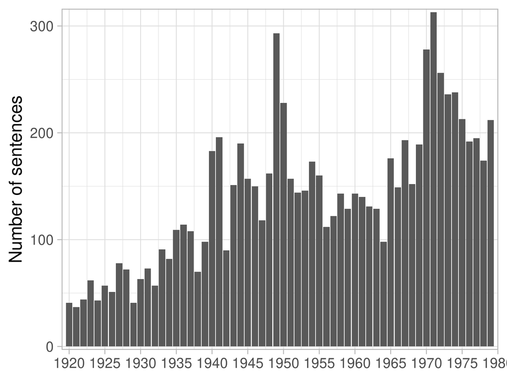

### Closest sentence from ‘rational’ and ‘rationality’ of the backbone community

| Sentence | Title | Year | Journal | Authors | Words Similarity |
| --- | --- | --- | --- | --- | --- |
| Judgments as to the “objective rationality” or “irrationality” of economic conduct can only be fragmentary and negative, apart from the cases where people act in a way which according to their own sta… | [Expectation and Rational Conduct](http://www.jstor.org/stable/41793308) | 1937 | Zeitschrift für Nationalökonomie / Journal of Economics | T. W. Hutchison | 0.827 |
| Economic theory which is, I would remind you, only a part of economics, a small but important part, has been built around the assumption of “rational” behaviour. | [Economics and Human Relations: The Presidential Address Delivered at the Annual Meeting of the Canadian Political Science Association, June 18, 1948](http://www.jstor.org/stable/137927) | 1948 | The Canadian Journal of Economics and Political Science / Revue canadienne d’Economique et de Science politique | V. W. Bladen | 0.812 |
| Rationality in the wide sense in which Professor Lange defines it, is a necessary condition for the economic theory we are used to, but it is not a sufficient condition. | [The Meaning of Rationality: A Note on Professor Lange’s Article](http://www.jstor.org/stable/2295759) | 1946 | The Review of Economic Studies | K. W. Rothschild | 0.810 |
| When it comes to economic doctrines, the individual is often not very rational. | [Irrationality in Economics](http://www.jstor.org/stable/1881874) | 1954 | The Quarterly Journal of Economics | Louis Baudin | 0.804 |
| The concept of the economic man, or of instrumentally rational behavior, is valid and important, but only within limits set by these considerations, and others of a similar character. | [Immutable Law in Economics: Its Reality and Limitations](http://www.jstor.org/stable/1818199) | 1946 | The American Economic Review | Frank H. Knight | 0.790 |
| In distilling from our reasoning about the facts of economic life those parts which are truly a priori, we not only isolate one element of our reasoning as a sort of Pure Logic of Choice in all its pu… | [Economics and Knowledge](http://www.jstor.org/stable/2548786) | 1937 | Economica | F. A. von Hayek | 0.781 |
| To say that this sort of conceptual marionette manipulated by the theoretical economist as a preliminary thought-clearing exercise is “rational” or has perfect foresight may be misleading. | [Expectation and Rational Conduct](http://www.jstor.org/stable/41793308) | 1937 | Zeitschrift für Nationalökonomie / Journal of Economics | T. W. Hutchison | 0.779 |
| It is characteristic that Marshall insists on the irrationality of many of our actual motives, and this is a fact which psychologists are apt to underline when commenting on the severely logical natur… | [Choice in Psychology and as Economic Assumption](http://www.jstor.org/stable/2227128) | 1953 | The Economic Journal | A. L. Macfie | 0.779 |
| Economic action is moreover in principle rational, tho it may in practice be tinged with traditionalism or other non-rational factors. | [Economics and Sociology: Marshall in Relation to the Thought of His Time](http://www.jstor.org/stable/1883233) | 1932 | The Quarterly Journal of Economics | Talcott Parsons | 0.778 |
| ;2 “Basically, for Professor Hicks, as for Jevons and Marshall, economic decisions are made by an abstract calculating machine”;3 “I find myself continuing to believe … that, whatever the origin of th… | [What Kind of Psychology Does Economics Need?](http://www.jstor.org/stable/137982) | 1950 | The Canadian Journal of Economics and Political Science / Revue canadienne d’Economique et de Science politique | C. Reinold Noyes | 0.769 |
| The peculiar character of the problem of a rational economic order is determined precisely by the fact that the knowledge of the circumstances of which we must make use never exists in concentrated or… | [The Use of Knowledge in Society](http://www.jstor.org/stable/1809376) | 1945 | The American Economic Review | F. A. Hayek | 0.768 |
| The beginning of any rational approach to the problems must be recognition that there are universal principles of “economy”–as indeed our author recognizes in his next sentence, which contrasts “the g… | [Anthropology and Economics](http://www.jstor.org/stable/1824430) | 1941 | Journal of Political Economy | Frank H. Knight | 0.765 |
| In order to substantiate and support the doctrine thus sketched we turn to consider briefly the opposite view, which is that of the “economic interpretation.” | [Ethics and the Economic Interpretation](http://www.jstor.org/stable/1886033) | 1922 | The Quarterly Journal of Economics | Frank H. Knight | 0.763 |
| Economists have wrestled with the problem of the utilities of irrationality. | [The Optimal Utilization of National Resources](http://www.jstor.org/stable/1907303) | 1949 | Econometrica | J. Stafford | 0.763 |
| If we temporarily abandon all of our preconceived notions of how well-behaved, rational, logically constructed economies should behave, three cases will hold an interest for us: Case 1. | [Patinkin on Neo-Classical Monetary Theory: A Critique in Walrasian Specifics](http://www.jstor.org/stable/1055011) | 1959 | Southern Economic Journal | Robert E. Kuenne | 0.763 |
| But there is a reason for the particular approach and the economic applications chosen by N-M and the apparent omissions just mentioned: it is their notion of rational economic behaviour, which we are… | [Oligopoly as a Non-Zero-Sum Game](http://www.jstor.org/stable/2296117) | 1957 | The Review of Economic Studies | H. Neisser | 0.763 |
| To say that economic activity-or the conduct of the economic man-is rational behavior raises the quite relevant question: In what measure are men rational? | [Adam Smith and the Economic Man](http://www.jstor.org/stable/1826047) | 1948 | Journal of Political Economy | William D. Grampp | 0.762 |
| Economic rationality thus assumes different forms or is subordinated to the mores of different areas. | [National Patterns of Union Behavior](http://www.jstor.org/stable/1826409) | 1948 | Journal of Political Economy | Adolf Sturmthal | 0.761 |
| Often what is accepted as just and right is the result of rationalising on the basis of economic realities. | [Wage Policy and a Labour Standard](http://www.jstor.org/stable/2227860) | 1956 | The Economic Journal | J. Henry Richardson | 0.761 |
| But this is not an “economic” doctrine; and in any case the application of the term “economy” to each individual is still unintelligible unless it implies an “end” which is not merely “positive,” but … | [“The Nature and Significance of Economic Science” in Recent Discussion](http://www.jstor.org/stable/1883978) | 1933 | The Quarterly Journal of Economics | R. W. Souter | 0.760 |
| Here, economic theory is relevant. | [Economic Theory of Bargaining in Agriculture](http://www.jstor.org/stable/1236804) | 1963 | Journal of Farm Economics | Peter G. Helmberger, Sidney Hoos | 0.760 |

### Closest sentences of the backbone community’s centroid

| Sentence | Title | Year | Journal | Authors | Centroid Similarity |
| --- | --- | --- | --- | --- | --- |
| Ultimately, we confront the paradox that perfectly economic behavior is not economic behavior at all; apart from the possibility of error, it would not be motivated but would be simply a mechanical re… | [Diminishing Returns from Investment](http://www.jstor.org/stable/1830979) | 1944 | Journal of Political Economy | Frank H. Knight | 0.7949203 |
| Here, economic theory is relevant. | [Economic Theory of Bargaining in Agriculture](http://www.jstor.org/stable/1236804) | 1963 | Journal of Farm Economics | Peter G. Helmberger, Sidney Hoos | 0.7808771 |
| Both pure theory and imperfections in the capital market are thus involved. | [Cost-Benefit Analysis: A Survey](http://www.jstor.org/stable/2229670) | 1965 | The Economic Journal | A. R. Prest, R. Turvey | 0.7755926 |
| Perhaps the limitations of the more abstract principles of economic behavior and of markets are not always recognized as explicitly as they should be. | [Value Theory for Economists](http://www.jstor.org/stable/1816504) | 1956 | The American Economic Review | Frank H. Knight | 0.7755046 |
| The capricious and irrational or mistaken judgment of one member of a market may be far more important than all the theoretical generalizations there are. | [Social Biases and Recent Theories of Competition](http://www.jstor.org/stable/1885753) | 1943 | The Quarterly Journal of Economics | William H. Nicholls | 0.7631071 |
| Perhaps influenced unconsciously by the spirit of transcendentalism, perhaps confusing change with progress, or even perhaps with a wisdom born of experience and thought, Professor Galbraith, believin… | [Saving Free Enterprise from Its Friends](http://www.jstor.org/stable/1054086) | 1953 | Southern Economic Journal | George W. Stocking | 0.7588898 |
| In this fearful dilemma the economist will best serve his community by making as clear as possible to himself and to others the thought processes behind his basic assumptions as to market determinants… | [Collective Bargaining and Economic Theory](http://www.jstor.org/stable/1053337) | 1947 | Southern Economic Journal | Werner Hochwald | 0.7556046 |
| The author thinks, however, that his approach is likely to show in a more vivid light a few facts which, although obscurely felt, are not yet generally accepted in economic science. | [Capital Accumulation and Efficient Allocation of Resources](http://www.jstor.org/stable/1905538) | 1953 | Econometrica | Edmond Malinvaud | 0.7549907 |
| It must be noted that the conditions under which these results are valid are hardly realistic; the results are interesting mainly because they indicate one direction in which the market problem may be… | [Neumann’s and Morgenstern’s New Approach to Static Economics](http://www.jstor.org/stable/1825790) | 1946 | Journal of Political Economy | J. Marschak | 0.7493684 |
| What is involved here is a technical debate among economists about some quite subtle economic theories that have not yet been fully tested. | [The Effect of Controls on the Rate of Wage Change in Canada](http://www.jstor.org/stable/134597) | 1979 | The Canadian Journal of Economics / Revue canadienne d’Economique | Frank Reid | 0.7487594 |
| This type of economic theorizing is extremely valuable, but the economic theorist should always be skeptical of his own conclusions; and failure to participate actively in the economic life about him … | [The Public Service and the Professional Social Scientist](http://www.jstor.org/stable/1052905) | 1937 | Southern Economic Journal | James W. Martin | 0.7484869 |
| THE object of this essay 1 is not to make any original contribution to knowledge, but to bring together as it were into one picture a number of phenomena which meet with individual discussion in the a… | [Economic Incentive](http://www.jstor.org/stable/2548301) | 1921 | Economica | D. H. Robertson | 0.7478488 |
| One element in the situation is of especial interest both to men of affairs and to economic theorists. | [Government Debt and Private Investment Policy](http://www.jstor.org/stable/1927189) | 1949 | The Review of Economics and Statistics | Charles C. Abbott | 0.7458442 |
| Several specific hypotheses arise from the economic theory we have outlined. | [An Economic Theory of Suicide](http://www.jstor.org/stable/1830901) | 1974 | Journal of Political Economy | Daniel S. Hamermesh, Neal M. Soss | 0.7456583 |
| A related misunderstanding, tho in its origin apparently not identical, has been pointed out by Mr. T. W.Hutchison,3 in Professor Robbins’ Nature and Significance of Economic Science: ” In a recent pr… | [Collected Works of Carl Menger](http://www.jstor.org/stable/1891101) | 1936 | The Quarterly Journal of Economics | Alan R. Sweezy | 0.7445003 |

### Closest sentences of each kmean cluster’s centroid composing the backbone community

#### Top terms 10_19: economic_principle, economic_principles, doctrine, economic_doctrine, teaching (1920-1939)

| Sentence | Title | Year | Journal | Authors | Distance to Centroid |
| --- | --- | --- | --- | --- | --- |
| It is one of the causes of the unique position of economics that the existence of a definite object of its investigation can be realised only after a prolonged study and it is, therefore, not surprisi… | [The Trend of Economic Thinking](http://www.jstor.org/stable/2548761) | 1933 | Economica | F. A. von Hayek | 6.259911 |
| There is one limiting feature of economic doctrine which is perhaps not so generally kept in mind as it should be; namely, that many of the particular doctrines which go to make it up have been devise… | [Economics of the Recovery Act](http://www.jstor.org/stable/1805890) | 1934 | The American Economic Review | Joseph H. Willits, John Dickinson | 6.400737 |
| The principal schools in the field of economic thought with which we are all familiar have developed around contested methods of analysis, the scope of the subject-matter, the significance of history … | [Economic Thought and Economic Policy in the South](http://www.jstor.org/stable/1052295) | 1933 | Southern Economic Journal | Tipton R. Snavely | 6.648470 |
| I THERE are at present outstanding in economics a number of unresolved controversies; but that is so perennial a situation in economic theory, as indeed in all fields of thought, that it is hardly an … | [Issues in Economic Theory: an Attempt to Clarify](http://www.jstor.org/stable/1884782) | 1928 | The Quarterly Journal of Economics | Paul T. Homan | 6.731072 |
| The competent scholar who presents us with a full-length sketch of Sombart’s work and its bearing upon other approaches to economics will merit our thanks. | [Sombart’s Hochkapitalismus](http://www.jstor.org/stable/1882475) | 1929 | The Quarterly Journal of Economics | Wesley C. Mitchell | 6.787310 |

#### Top terms 10_36: economic_reality, economic_laws, economic_law, economic_dynamics, contemporary_economic (1940-1949)

| Sentence | Title | Year | Journal | Authors | Distance to Centroid |
| --- | --- | --- | --- | --- | --- |
| Abstractness, generality, and mathematical elegance have in some measure become ends in themselves, criteria by which to judge economic theory. | [The Marshallian Demand Curve](http://www.jstor.org/stable/1826553) | 1949 | Journal of Political Economy | Milton Friedman | 6.850602 |
| 1 It should be noted that besides the three meaningful bases for economic theory proposed by Samuelson, of which this is the third, there is another possibility whose use is not unknown in the natural… | [Relaying the Foundations](http://www.jstor.org/stable/2549855) | 1949 | Economica | William J. Baumol | 7.149201 |
| Up to this point the difference of opinion between Professor Pegrum and myself is only one of emphasis, but the last part of his article, in which he criticizes economic theory for claiming a universa… | [Economic Planning and the Science of Economics: Comment](http://www.jstor.org/stable/1803245) | 1941 | The American Economic Review | Carl Landauer | 7.196552 |
| Let us suppose there were a recognized body of economic doctrine the truth and relevancy of which perpetually revealed itself to all who looked below the surface, which taught men what to expect and h… | [John Law and John Keynes](http://www.jstor.org/stable/1882837) | 1948 | The Quarterly Journal of Economics | Edwin B. Wilson | 7.206450 |
| It is especially the latter circumstance which makes the applicability and range of theories uncertain and contributes to the accusation that economic theory is unreal and carried out “in a vacuum.” | [Professor Hicks on Value and Capital](http://www.jstor.org/stable/1824735) | 1941 | Journal of Political Economy | Oskar Morgenstern | 7.221830 |

#### Top terms 10_42: economic_argument, professor_hayek, economic_welfare, welfare_economics, recent_economic (1940-1949)

| Sentence | Title | Year | Journal | Authors | Distance to Centroid |
| --- | --- | --- | --- | --- | --- |
| It seems to me that the most important single source of the difficulties of so much of economic literature with this range of problems lies in the tendency for the great bulk of economists to approach… | [Reply to Professor Knight](http://www.jstor.org/stable/136913) | 1940 | The Canadian Journal of Economics and Political Science / Revue canadienne d’Economique et de Science politique | Talcott Parsons | 6.859667 |
| The extreme doctrinaire positions so sharply and logically presented by Simons, generally seem to me to be impossible, and deserving of severe criticism; but I know of no better stimulant to careful t… | [The Economics of a “Free” Society: Four Essays](http://www.jstor.org/stable/1883465) | 1948 | The Quarterly Journal of Economics | O. H. Taylor | 7.088772 |
| This, CAPITAL 41 I advantages from the general standpoint suggested, illumination of the ultimate difficulties of economic theory, and of the’ reasons why discussion seems so largely to result in mult… | [Professor Mises and the Theory of Capital](http://www.jstor.org/stable/2550107) | 1941 | Economica | F. H. Knight | 7.121209 |
| It bears on the relation of economics to the broader stream of social thought.55 The bulk of Veblen’s writings can be subsumed under that heading. | [Sociological Elements in Veblen’s Economic Theory](http://www.jstor.org/stable/1825050) | 1945 | Journal of Political Economy | Arthur K. Davis | 7.194443 |
| This required it to raise many issues which lie beyond the usual beat of the economist, but in dealing with the practical claim this paper will confine itself to the main economic issues which it rais… | [Equal Pay for Equal Work](http://www.jstor.org/stable/2226870) | 1949 | The Economic Journal | E. H. Phelps Brown | 7.284617 |

#### Top terms 10_49: economic_laws, economic_development, economic_system, free_enterprise, economic_doctrines (1950-1959)

| Sentence | Title | Year | Journal | Authors | Distance to Centroid |
| --- | --- | --- | --- | --- | --- |
| CONCLUSION At best, economic theorizing can be no more than “the quintessence of experience,” and so as the circumstances and events which gave rise to the ideas expressed in the General Theory have p… | [After Twenty Years: The General Theory](http://www.jstor.org/stable/1881866) | 1956 | The Quarterly Journal of Economics | James R. Schlesinger | 6.601369 |
| The process of development of economic theory has been, and must tend still more to be, a more complicated one than the movement back and forth between the real world and hypothesis or theory that cha… | [The Taxonomic Approach to the Study of Economic Policies](http://www.jstor.org/stable/1811583) | 1955 | The American Economic Review | A. C. L. Day | 6.961661 |
| Essentially, the contribution which the studies by Sylos, Bain, and Modigliani offer to the body of economic theory appears to us to lie not in the model they present but in the point of view with whi… | [New Developments on the Oligopoly Front: A Comment](http://www.jstor.org/stable/1825168) | 1959 | Journal of Political Economy | Donald E. Farrar , Charles F. Phillips, Jr. | 7.055616 |
| The various segments of economic theory must not be treated as watertight compartments, but must be synthesized into one general theory. | [Some Basic Principles of Price of Living Measurements: A Survey Article](http://www.jstor.org/stable/1907434) | 1954 | Econometrica | Ragnar Frisch | 7.065526 |
| Anyway, my task here is neither to bury theory nor to praise it, but to try to sketch the relationships between certain points of view that have been proposed for the study of economics. | [Institutionalism and Empiricism in Economics](http://www.jstor.org/stable/1910584) | 1952 | The American Economic Review | Frank H. Knight | 7.123659 |

#### Top terms 10_70: positive_economics, qualitative_economics, economic_meaning, economic_rationale, model (1960-1969)

| Sentence | Title | Year | Journal | Authors | Distance to Centroid |
| --- | --- | --- | --- | --- | --- |
| Here, economic theory is relevant. | [Economic Theory of Bargaining in Agriculture](http://www.jstor.org/stable/1236804) | 1963 | Journal of Farm Economics | Peter G. Helmberger, Sidney Hoos | 6.932346 |
| Two peculiar features of economic theory stand out quite clearly against the background of the previous presentation of Braithwaite’s work. | [Some Reflections on the Relation between Economic Theory and Empirical Reality](http://www.jstor.org/stable/3439181) | 1967 | The Swedish Journal of Economics | Tõnu Puu | 6.997413 |
| What is currently called “economic theory” is nothing but a series of such abstractions, some more atemporal or aspacial than others, but all exposed to modifications imposed by changes of circumstanc… | [Latin American Economists in the United States](http://www.jstor.org/stable/1152553) | 1966 | Economic Development and Cultural Change | Aníbal Pinto , Osvaldo Sunkel | 7.219198 |
| He presents a regrettably brief and somewhat unclear procedure for establishing empirical correspondence32 which asserts that C* and B are not equivalent because extra-logical considerations are essen… | [An Empirical Principle for Deductive Theory in Economics](http://www.jstor.org/stable/1055334) | 1967 | Southern Economic Journal | Robert G. Fabian | 7.347383 |
| Some implications for economic fields, 393; value and welfare, 393; economic competition and organization, 395; economic development and cycles, 396.- V. Conclusion, 398. | [The Economics of Fashion Demand](http://www.jstor.org/stable/1885130) | 1961 | The Quarterly Journal of Economics | Dwight E. Robinson | 7.477810 |

#### Top terms 10_85: economic_interpretation, positive_economics, economic_history, economic_systems, externalities (1970-1979)

| Sentence | Title | Year | Journal | Authors | Distance to Centroid |
| --- | --- | --- | --- | --- | --- |
| The validity and usefulness of any economic theory does not depend solely on its immediate empirical signifi cance, but depends on how it eventually leads to more understanding of the complex workings… | [A Note on Economic Growth, Technical Progress and the Production Function](http://www.jstor.org/stable/23810749) | 1975 | Jahrbücher für Nationalökonomie und Statistik / Journal of Economics and Statistics | Ryuzo Sato , Martin J. Beckmann | 6.998118 |
| In this way a provisional general theory is elucidated and applied to specific economic phenomena with the result that “received” or “accepted” economic theories were shown by Veblen to be based upon … | [Thorstein Veblen’s Theory of Evolutionary Change](http://www.jstor.org/stable/3485893) | 1975 | The American Journal of Economics and Sociology | Stephen Edgell | 7.103102 |
| In order to complete this brief survey of the economic thought of the time, it is necessary to pay some specific attention to that subject. | [Two Monetary Inquiries in Great Britain: The MacMillan Committee of 1931 and the Radcliffe Committee of 1959](http://www.jstor.org/stable/1991236) | 1972 | Journal of Money, Credit and Banking | Scott Gordon | 7.287679 |
| Attempts are made to extend this conceptual framework, unify it, examine its background in the history of economic ideas and indicate its place in the recent theoretical discussion. | [Dissertations in Economics and Business Administration, 1978-1979](http://www.jstor.org/stable/3439671) | 1979 | The Scandinavian Journal of Economics | NULL | 7.417335 |
| Within the context of the present discussion, we cannot but mention an additional facet of modern economic theories that will come to occupy the attention of the quantitative economic historian. | [Explanations and Issues: A Prospectus for Quantitative Economic History](http://www.jstor.org/stable/2117018) | 1971 | The Journal of Economic History | Joseph A. Swanson , Jeffrey G. Williamson | 7.419979 |

### Top articles (most sentences) of the backbone cluster

| Title | Year | Journal | Authors | Number sentences | Words Similarity |
| --- | --- | --- | --- | --- | --- |
| [The Probability Approach in Econometrics](http://www.jstor.org/stable/1906935) | 1944 | Econometrica | Trygve Haavelmo | 36 | 0.617 |
| [Sociological Elements in Economic Thought](http://www.jstor.org/stable/1883862) | 1935 | The Quarterly Journal of Economics | Talcott Parsons | 27 | 0.645 |
| [The Logical Foundations of Economic Research](http://www.jstor.org/stable/1232709) | 1949 | Journal of Farm Economics | Kenneth H. Parsons | 23 | 0.633 |
| [Immutable Law in Economics: Its Reality and Limitations](http://www.jstor.org/stable/1818199) | 1946 | The American Economic Review | Frank H. Knight | 22 | 0.627 |
| [The Pragmatic Basis of Economic Theory](http://www.jstor.org/stable/137857) | 1950 | The Canadian Journal of Economics and Political Science / Revue canadienne d’Economique et de Science politique | H. Scott Gordon | 21 | 0.621 |
| [Some Reflections on the Relation between Economic Theory and Empirical Reality](http://www.jstor.org/stable/3439181) | 1967 | The Swedish Journal of Economics | Tõnu Puu | 21 | 0.636 |
| [Individualism and Economic Theory](http://www.jstor.org/stable/3483667) | 1950 | The American Journal of Economics and Sociology | Walter A. Weisskopf | 19 | 0.626 |
| [“What is Truth” in Economics?](http://www.jstor.org/stable/1825908) | 1940 | Journal of Political Economy | Frank H. Knight | 18 | 0.647 |
| [The Impossibility of a Theoretical Science of Economic Dynamics](http://www.jstor.org/stable/1883027) | 1941 | The Quarterly Journal of Economics | F. S. C. Northrop | 18 | 0.625 |
| [Croce and the Nature of Economic Science](http://www.jstor.org/stable/1884568) | 1945 | The Quarterly Journal of Economics | Giorgio Tagliacozzo | 17 | 0.633 |
| [The Impasse in Economic Theory](http://www.jstor.org/stable/1822132) | 1927 | Journal of Political Economy | Paul T. Homan | 16 | 0.632 |
| [Issues in Economic Theory: an Attempt to Clarify](http://www.jstor.org/stable/1884782) | 1928 | The Quarterly Journal of Economics | Paul T. Homan | 16 | 0.632 |
| [Some Reflections on “The Nature and Significance of Economics”](http://www.jstor.org/stable/1882825) | 1934 | The Quarterly Journal of Economics | Talcott Parsons | 14 | 0.643 |
| [The Scope and Definition of Economics](http://www.jstor.org/stable/1824178) | 1939 | Journal of Political Economy | Raymond T. Bye | 14 | 0.616 |
| [Psychological Aspects of Economic Thought](http://www.jstor.org/stable/1826270) | 1949 | Journal of Political Economy | Walter A. Weisskopf | 14 | 0.638 |

### Top articles (most sentences) of the cluster for each time window

#### Top articles for 10_19: economic_principle, economic_principles, doctrine, economic_doctrine, teaching (1920-1939)

| Title | Year | Journal | Authors | Number sentences | Words Similarity |
| --- | --- | --- | --- | --- | --- |
| [Sociological Elements in Economic Thought](http://www.jstor.org/stable/1883862) | 1935 | The Quarterly Journal of Economics | Talcott Parsons | 27 | 0.645 |
| [The Impasse in Economic Theory](http://www.jstor.org/stable/1822132) | 1927 | Journal of Political Economy | Paul T. Homan | 16 | 0.632 |
| [Issues in Economic Theory: an Attempt to Clarify](http://www.jstor.org/stable/1884782) | 1928 | The Quarterly Journal of Economics | Paul T. Homan | 16 | 0.632 |
| [Some Reflections on “The Nature and Significance of Economics”](http://www.jstor.org/stable/1882825) | 1934 | The Quarterly Journal of Economics | Talcott Parsons | 14 | 0.643 |
| [The Scope and Definition of Economics](http://www.jstor.org/stable/1824178) | 1939 | Journal of Political Economy | Raymond T. Bye | 14 | 0.616 |
| [On the Subject-Matter and Method of Economic Science](http://www.jstor.org/stable/2548905) | 1933 | Economica | Felix Kaufmann | 13 | 0.617 |
| [Expectation and Rational Conduct](http://www.jstor.org/stable/41793308) | 1937 | Zeitschrift für Nationalökonomie / Journal of Economics | T. W. Hutchison | 13 | 0.668 |
| [The Trend of Economics, as seen by Some American Economists](http://www.jstor.org/stable/1884871) | 1925 | The Quarterly Journal of Economics | Allyn A. Young | 12 | 0.633 |
| [Sociological Elements in Economic Thought: II. The Analytical Factor View^1](http://www.jstor.org/stable/1885403) | 1935 | The Quarterly Journal of Economics | Talcott Parsons | 11 | 0.635 |
| [What has Philosophy to Contribute to the Social Sciences, and to Economics in Particular?](http://www.jstor.org/stable/2549250) | 1936 | Economica | Harro Bernadelli | 11 | 0.649 |

#### Top articles for 10_36: economic_reality, economic_laws, economic_law, economic_dynamics, contemporary_economic (1940-1949)

| Title | Year | Journal | Authors | Number sentences | Words Similarity |
| --- | --- | --- | --- | --- | --- |
| [The Probability Approach in Econometrics](http://www.jstor.org/stable/1906935) | 1944 | Econometrica | Trygve Haavelmo | 31 | 0.617 |
| [Immutable Law in Economics: Its Reality and Limitations](http://www.jstor.org/stable/1818199) | 1946 | The American Economic Review | Frank H. Knight | 19 | 0.634 |
| [The Impossibility of a Theoretical Science of Economic Dynamics](http://www.jstor.org/stable/1883027) | 1941 | The Quarterly Journal of Economics | F. S. C. Northrop | 17 | 0.626 |
| [Croce and the Nature of Economic Science](http://www.jstor.org/stable/1884568) | 1945 | The Quarterly Journal of Economics | Giorgio Tagliacozzo | 15 | 0.633 |
| [The Logical Foundations of Economic Research](http://www.jstor.org/stable/1232709) | 1949 | Journal of Farm Economics | Kenneth H. Parsons | 13 | 0.641 |
| [“What is Truth” in Economics?](http://www.jstor.org/stable/1825908) | 1940 | Journal of Political Economy | Frank H. Knight | 12 | 0.645 |
| [J. M. Keynes’ Concept of Economic Science](http://www.jstor.org/stable/1054123) | 1949 | Southern Economic Journal | Allan G. Gruchy | 12 | 0.621 |
| [John R. Commons’ Concept of Twentieth-Century Economics](http://www.jstor.org/stable/1824210) | 1940 | Journal of Political Economy | Allan G. Gruchy | 11 | 0.641 |
| [Psychological Aspects of Economic Thought](http://www.jstor.org/stable/1826270) | 1949 | Journal of Political Economy | Walter A. Weisskopf | 11 | 0.644 |
| [Neoclassical Economics and Monetary Problems](http://www.jstor.org/stable/1810486) | 1949 | The American Economic Review | Paul B. Simpson | 10 | 0.602 |

#### Top articles for 10_42: economic_argument, professor_hayek, economic_welfare, welfare_economics, recent_economic (1940-1949)

| Title | Year | Journal | Authors | Number sentences | Words Similarity |
| --- | --- | --- | --- | --- | --- |
| [The Logical Foundations of Economic Research](http://www.jstor.org/stable/1232709) | 1949 | Journal of Farm Economics | Kenneth H. Parsons | 10 | 0.623 |
| [The Scope and Method of Economics](http://www.jstor.org/stable/137571) | 1945 | The Canadian Journal of Economics and Political Science / Revue canadienne d’Economique et de Science politique | G. N. Halm , F. St. L. Daly | 8 | 0.613 |
| [The Use of Knowledge in Society](http://www.jstor.org/stable/1809376) | 1945 | The American Economic Review | F. A. Hayek | 7 | 0.646 |
| [“What is Truth” in Economics?](http://www.jstor.org/stable/1825908) | 1940 | Journal of Political Economy | Frank H. Knight | 6 | 0.649 |
| [Unemployment: Analysis of Factors](http://www.jstor.org/stable/1816434) | 1941 | The American Economic Review | Oskar Morgenstern | 5 | 0.640 |
| [United States in the World Economy, 1940: A Summary](http://www.jstor.org/stable/1816438) | 1941 | The American Economic Review | Ernest Minor Patterson | 5 | 0.608 |
| [The Role of Expectations in Economics as a Social Science](http://www.jstor.org/stable/2549651) | 1943 | Economica | L. M. Lachmann | 5 | 0.628 |
| [The Probability Approach in Econometrics](http://www.jstor.org/stable/1906935) | 1944 | Econometrica | Trygve Haavelmo | 5 | 0.620 |
| [Optimum Income Distribution as a Goal of Public Policy](http://www.jstor.org/stable/3483786) | 1944 | The American Journal of Economics and Sociology | Rainer Schickele | 5 | 0.599 |
| [Economics and Human Relations: The Presidential Address Delivered at the Annual Meeting of the Canadian Political Science Association, June 18, 1948](http://www.jstor.org/stable/137927) | 1948 | The Canadian Journal of Economics and Political Science / Revue canadienne d’Economique et de Science politique | V. W. Bladen | 5 | 0.630 |

#### Top articles for 10_49: economic_laws, economic_development, economic_system, free_enterprise, economic_doctrines (1950-1959)

| Title | Year | Journal | Authors | Number sentences | Words Similarity |
| --- | --- | --- | --- | --- | --- |
| [The Pragmatic Basis of Economic Theory](http://www.jstor.org/stable/137857) | 1950 | The Canadian Journal of Economics and Political Science / Revue canadienne d’Economique et de Science politique | H. Scott Gordon | 21 | 0.621 |
| [Individualism and Economic Theory](http://www.jstor.org/stable/3483667) | 1950 | The American Journal of Economics and Sociology | Walter A. Weisskopf | 19 | 0.626 |
| [Social Accounting in Relation to Economic Theory](http://www.jstor.org/stable/2228038) | 1954 | The Economic Journal | D. K. Burdett | 14 | 0.609 |
| [The Theory of an Economic System](http://www.jstor.org/stable/1831498) | 1953 | The American Economic Review | Manuel Gottlieb | 11 | 0.633 |
| [Problems of Order of Economic and Agricultural Policy](http://www.jstor.org/stable/1234072) | 1955 | Journal of Farm Economics | Heinrich Niehaus | 11 | 0.614 |
| [Methodological Issues in Quantitative Economics: Variations Upon a Theme by F. H. Knight](http://www.jstor.org/stable/1802203) | 1950 | The American Economic Review | Rutledge Vining | 10 | 0.641 |
| [The Taxonomic Approach to the Study of Economic Policies](http://www.jstor.org/stable/1811583) | 1955 | The American Economic Review | A. C. L. Day | 10 | 0.618 |
| [Economic Understanding: Why and What](http://www.jstor.org/stable/1831633) | 1957 | The American Economic Review | Ben W. Lewis | 10 | 0.622 |
| [Psychological Assumptions of Economic Theory](http://www.jstor.org/stable/3483431) | 1950 | The American Journal of Economics and Sociology | Albert Lauterbach | 9 | 0.632 |
| [The Future of Economic Liberalism](http://www.jstor.org/stable/1910579) | 1952 | The American Economic Review | Overton H. Taylor | 9 | 0.632 |

#### Top articles for 10_70: positive_economics, qualitative_economics, economic_meaning, economic_rationale, model (1960-1969)

| Title | Year | Journal | Authors | Number sentences | Words Similarity |
| --- | --- | --- | --- | --- | --- |
| [Some Reflections on the Relation between Economic Theory and Empirical Reality](http://www.jstor.org/stable/3439181) | 1967 | The Swedish Journal of Economics | Tõnu Puu | 21 | 0.636 |
| [Friedman and Machlup on the Significance of Testing Economic Assumptions](http://www.jstor.org/stable/1828428) | 1965 | Journal of Political Economy | Jack Melitz | 11 | 0.629 |
| [Goals in Social Economics](http://www.jstor.org/stable/4224003) | 1969 | Journal of Economic Issues | Arthur Schweitzer | 10 | 0.605 |
| [Causal versus Teleological Explanation in Economics](http://www.jstor.org/stable/3438991) | 1969 | The Swedish Journal of Economics | Tönu Puu | 9 | 0.616 |
| [On the Question of Operationalism](http://www.jstor.org/stable/1815611) | 1967 | The American Economic Review | Ben B. Seligman | 8 | 0.616 |
| [The Economic Approach to Social Questions](http://www.jstor.org/stable/2552159) | 1968 | Economica | Harry G. Johnson | 8 | 0.637 |
| [An Empirical Principle for Deductive Theory in Economics](http://www.jstor.org/stable/1055334) | 1967 | Southern Economic Journal | Robert G. Fabian | 7 | 0.621 |
| [On the Scientific Foundations of Marginalism](http://www.jstor.org/stable/3484427) | 1962 | The American Journal of Economics and Sociology | Adamantia Pollis , Bertram L. Koslin | 6 | 0.624 |
| [Analytic Economics and the Logic of External Effects](http://www.jstor.org/stable/1823865) | 1963 | The American Economic Review | Sherman Krupp | 6 | 0.622 |
| [On Two Foundation Concepts of the Theory of Political Economy](http://www.jstor.org/stable/1829765) | 1969 | Journal of Political Economy | Rutledge Vining | 6 | 0.595 |

#### Top articles for 10_85: economic_interpretation, positive_economics, economic_history, economic_systems, externalities (1970-1979)

| Title | Year | Journal | Authors | Number sentences | Words Similarity |
| --- | --- | --- | --- | --- | --- |
| [Methodological Problems in Contrasting Economic Systems](http://www.jstor.org/stable/3485238) | 1970 | The American Journal of Economics and Sociology | Horst K. Betz, E. K. Hunt | 14 | 0.610 |
| [On the Possibility of a Political Economics](http://www.jstor.org/stable/4224050) | 1970 | Journal of Economic Issues | Robert L. Heilbroner | 11 | 0.624 |
| [Explanation and Value in Economics](http://www.jstor.org/stable/4224885) | 1979 | Journal of Economic Issues | Timothy J. Brennan | 11 | 0.639 |
| [ECONOMIC SYSTEMS THEORY AND GENERAL EQUILIBRIUM THEORY](http://www.jstor.org/stable/40728182) | 1971 | Acta Oeconomica | J. Kornai | 10 | 0.608 |
| [Radical Political Economy as a ‘Scientific Revolution’](http://www.jstor.org/stable/1056598) | 1972 | Southern Economic Journal | Stephen T. Worland | 8 | 0.613 |
| [THE 4TH HUNGARIAN-BRITISH ECONOMIC COLLOQUIUM](http://www.jstor.org/stable/40728220) | 1973 | Acta Oeconomica | T. Palánkai | 8 | 0.639 |
| [Arthur Spiethoff on Economic Styles](http://www.jstor.org/stable/2116910) | 1970 | The Journal of Economic History | Fritz Redlich | 7 | 0.609 |
| [A Radical Analysis of Welfare Economics and Individual Development](http://www.jstor.org/stable/1882043) | 1972 | The Quarterly Journal of Economics | Herbert Gintis | 7 | 0.611 |
| [The Economic Postulate of Rationality: Some Methodological Views](http://www.jstor.org/stable/3438875) | 1973 | The Swedish Journal of Economics | Runo Axelsson | 7 | 0.631 |
| [The Folklore of the Market: An Inquiry into the Economic Doctrines of the Chicago School](http://www.jstor.org/stable/4224459) | 1975 | Journal of Economic Issues | Ezra J. Mishan | 7 | 0.610 |

### Most cited references in the backbone community

| First Author | Year | Journal | Citation by article | Citation by sentence |
| --- | --- | --- | --- | --- |
| COASE-R | 1960 | J LAW EC | 24 | 96 |
| MUTH-J | 1961 | ECONOMETRICA | 23 | 69 |
| BOULDING-K | 1941 | EC ANAL | 2 | 46 |
| DEWEY-J | 1929 | EXPERIENCE NATURE | 2 | 46 |
| FRAZER-L | 1937 | EC THOUGHT LANGUAGE | 2 | 46 |
| JOHNSON-G | 1944 | J FARM ECON | 2 | 46 |
| KNIGHT | 1940 | J POLITICAL EC | 2 | 46 |
| KNIGHT | 1941 | J POLITICAL EC | 2 | 46 |
| SHEPHERD-G | 1941 | AGR PRICE ANAL | 2 | 46 |
| STIGLER-G | 1961 | J POLITICAL EC | 7 | 14 |
| LERNER-A | 1934 | REV EC STUDIES | 2 | 6 |
| DESCITOVSZKY-T | 1941 | REV ECON STUD | 2 | 4 |

| First Author | Year | Journal | Citation by article | Citation by sentence |
| --- | --- | --- | --- | --- |
| FRIEDMAN-M | 1953 | ESSAYS POSITIVE ECON | 38 | 456 |
| DEBREU-G | 1959 | THEORY VALUE | 40 | 440 |
| DOWNS-A | 1957 | ECONOMIC THEORY DEMO | 27 | 378 |
| ARROW-K | 1951 | SOCIAL CHOICE INDIVI | 30 | 360 |
| KEYNES-J | 1936 | GENERAL THEORY EMPLO | 40 | 240 |
| SAMUELSON-P | 1947 | F EC ANALYSIS | 37 | 148 |
| FRIEDMAN-M | 1962 | CAPITALISM FREEDOM | 21 | 147 |
| HICKS-J | 1946 | VALUE CAPITAL INQUIR | 24 | 144 |
| SMITH-A | 1937 | WEALTH NATIONS | 16 | 128 |
| KOOPMANS-T | 1957 | 3 ESSAYS STATE ECONO | 21 | 126 |
| SAMUELSON-P | 1965 | F EC ANAL | 11 | 121 |
| MEADE-J | 1955 | THEORY INT ECONOMIC | 12 | 96 |
| SAMUELSON-P | 1947 | HARVARD ECONOMIC STU | 13 | 91 |
| GALBRAITH-J | 1958 | AFFLUENT SOC | 11 | 88 |
| KEYNESJM | 1936 | GEN THEORY EMPLOYMEN | 5 | 75 |

### Most cited references per kmean clusters

#### Top references 10_36: economic_reality, economic_laws, economic_law, economic_dynamics, contemporary_economic (1940-1949)

| First Author | Year | Journal | Citation by article | Citation by sentence |
| --- | --- | --- | --- | --- |
| BOULDING-K | 1941 | EC ANAL | 1 | 13 |
| DEWEY-J | 1929 | EXPERIENCE NATURE | 1 | 13 |
| FRAZER-L | 1937 | EC THOUGHT LANGUAGE | 1 | 13 |
| JOHNSON-G | 1944 | J FARM ECON | 1 | 13 |
| KNIGHT | 1940 | J POLITICAL EC | 1 | 13 |
| KNIGHT | 1941 | J POLITICAL EC | 1 | 13 |
| SHEPHERD-G | 1941 | AGR PRICE ANAL | 1 | 13 |
| FROMME | 1947 | MAN HIM | 1 | 11 |
| FREUDS | 1948 | COLLECT PAPERS | 1 | 11 |
| MYRDAL-G | 1944 | AM DISLEMMA | 1 | 11 |

| First Author | Year | Journal | Citation by article | Citation by sentence |
| --- | --- | --- | --- | --- |
| HUTCHISON-T | 1938 | SIGNIFICANCE BASIC P | 2 | 26 |
| MYRDALG | 1932 | POLITISCHE ELEMENT N | 2 | 22 |
| LANGEO | 1944 | PRICE FLEXIBILITY EM | 6 | 18 |
| HICKSJR | 1934 | RECONSIDERATION THEO | 2 | 18 |
| FETTERFA | 1913 | PRINCIPLES EC | 1 | 15 |
| BOWLEY-A | 1937 | ELEMENTS STAT | 1 | 13 |
| CHADDOCK-R | 1925 | PRINCIPLES METHODS S | 1 | 13 |
| DEWEY-J | 1938 | LOGIC THEORY INQUIRY | 1 | 13 |
| PARSONS | 1945 | WIS EXP STA RES B | 1 | 13 |
| SALTER-L | 1948 | THESIS | 1 | 13 |

#### Top references 10_42: economic_argument, professor_hayek, economic_welfare, welfare_economics, recent_economic (1940-1949)

| First Author | Year | Journal | Citation by article | Citation by sentence |
| --- | --- | --- | --- | --- |
| BOULDING-K | 1941 | EC ANAL | 1 | 10 |
| DEWEY-J | 1929 | EXPERIENCE NATURE | 1 | 10 |
| FRAZER-L | 1937 | EC THOUGHT LANGUAGE | 1 | 10 |
| JOHNSON-G | 1944 | J FARM ECON | 1 | 10 |
| KNIGHT | 1940 | J POLITICAL EC | 1 | 10 |
| KNIGHT | 1941 | J POLITICAL EC | 1 | 10 |
| SHEPHERD-G | 1941 | AGR PRICE ANAL | 1 | 10 |
| SCHUMPETERJ | 1942 | CAPITALISM SOCIALISM | 1 | 7 |
| LERNER-A | 1934 | REV EC STUDIES | 2 | 6 |
| DESCITOVSZKY-T | 1941 | REV ECON STUD | 2 | 4 |

| First Author | Year | Journal | Citation by article | Citation by sentence |
| --- | --- | --- | --- | --- |
| HICKSJR | 1939 | VALUE CAPITAL 3 | 5 | 20 |
| LERNERAP | 1944 | EC CONTROL | 5 | 20 |
| LANGEO | 1938 | EC THEORY SOCIALISM | 3 | 12 |
| BOWLEY-A | 1937 | ELEMENTS STAT | 1 | 10 |
| CHADDOCK-R | 1925 | PRINCIPLES METHODS S | 1 | 10 |
| DEWEY-J | 1938 | LOGIC THEORY INQUIRY | 1 | 10 |
| HUTCHISON-T | 1938 | SIGNIFICANCE BASIC P | 1 | 10 |
| PARSONS | 1945 | WIS EXP STA RES B | 1 | 10 |
| SALTER-L | 1948 | THESIS | 1 | 10 |
| TIMMONS-J | 1945 | SOCIAL EC ASPECTS DE | 1 | 10 |

#### Top references 10_49: economic_laws, economic_development, economic_system, free_enterprise, economic_doctrines (1950-1959)

| First Author | Year | Journal | Citation by article | Citation by sentence |
| --- | --- | --- | --- | --- |
| KEYNESJM | 1936 | GENERAL THEORY EMPLO | 1 | 21 |
| JAMESW | 1911 | PRAGMATISME | 1 | 21 |
| VINERJ | 1932 | Z NATIONALOKONOMIE | 1 | 21 |
| *AMECASS | 1948 | AM EC ASS PAP P | 1 | 21 |
| BRIDGMANPW | 1937 | LOGIC MODERN PHYS | 1 | 21 |
| EINSTEIN | 1938 | EVOLUTION PHYS | 1 | 21 |
| JAMESW | 1910 | PRINCIPLES PSYCHOL | 1 | 21 |
| LEWISCI | 1946 | ANAL KNOWLEDGE VALUA | 1 | 21 |
| RICARDOD | 1923 | EC ESSAYS | 1 | 21 |
| RUSSELLB | 1912 | PROBLEMS PHILOS | 1 | 21 |

| First Author | Year | Journal | Citation by article | Citation by sentence |
| --- | --- | --- | --- | --- |
| LESTERRA | 1946 | SHORTCOMINGS MARGINA | 3 | 63 |
| MACHLUPF | 1946 | MARGINAL ANAL EMPIRI | 3 | 63 |
| MEADEJE | 1951 | THEORY EC POLICY | 5 | 50 |
| HICKSJR | 1945 | SOCIAL FRAMEWORK AM | 2 | 42 |
| POPPERKR | 1944 | ECONOMICA | 2 | 42 |
| POPPER | 1945 | OPEN SOC ITS ENEMIES | 2 | 42 |
| HICKSJR | 1939 | EC J DEC | 6 | 42 |
| STONER | 1951 | REV EC STUDIES | 3 | 42 |
| KEYNESJM | 1936 | GEN THEORY EMPLOYMEN | 3 | 33 |
| PARSONS | 1951 | SOCIAL SYSTEM | 3 | 33 |

#### Top references 10_70: positive_economics, qualitative_economics, economic_meaning, economic_rationale, model (1960-1969)

| First Author | Year | Journal | Citation by article | Citation by sentence |
| --- | --- | --- | --- | --- |
| ROTWEIN-E | 1959 | Q J EC | 1 | 11 |
| SIMON-H | 1963 | AM ECON REV | 1 | 11 |
| ARCHIBALD-G | 1959 | BRIT J PHILOS SCI | 1 | 11 |
| NAGEL-E | 1963 | AM EC REV | 1 | 11 |
| MACHLUP-F | 1955 | SO EC J | 1 | 11 |
| KLAPPHOLZ-K | 1959 | ECONOMICA | 1 | 11 |
| KOOPMANS-T | 1957 | 3 ESSAYS STATE EC SC | 1 | 11 |
| WICKSELL-K | 1901 | LECTURES POLITICAL E | 1 | 11 |
| SIDGWICK-H | 1899 | DICT POLITICAL EC | 1 | 11 |
| SIDGWICK-H | 1883 | PRINCIPLES POLITICAL | 1 | 11 |

| First Author | Year | Journal | Citation by article | Citation by sentence |
| --- | --- | --- | --- | --- |
| MEADE-J | 1955 | THEORY INT ECONOMIC | 12 | 96 |
| SAMUELSON-P | 1947 | HARVARD ECONOMIC STU | 13 | 91 |
| GALBRAITH-J | 1958 | AFFLUENT SOC | 11 | 88 |
| ARROW-K | 1951 | SOCIAL CHOICE INDIVI | 12 | 60 |
| DUESENBERRY-J | 1949 | INCOME SAVING THEORY | 6 | 60 |
| DOWNS-A | 1957 | ECONOMIC THEORY DEMO | 7 | 56 |
| BAUMOL-W | 1952 | WELFARE EC THEORY ST | 11 | 55 |
| HICKS-J | 1939 | VALUE CAPITAL | 6 | 48 |
| BECKER-G | 1964 | HUMAN CAPITAL THEORE | 6 | 48 |
| DORFMAN-R | 1958 | LINEAR PROGRAMMING E | 9 | 45 |

#### Top references 10_85: economic_interpretation, positive_economics, economic_history, economic_systems, externalities (1970-1979)

| First Author | Year | Journal | Citation by article | Citation by sentence |
| --- | --- | --- | --- | --- |
| COASE-R | 1960 | J LAW EC | 20 | 20 |
| MUTH-J | 1961 | ECONOMETRICA | 9 | 18 |
| STIGLER-G | 1961 | J POLITICAL EC | 7 | 14 |
| MUTH-J | 1961 | ECONOMETRICA | 14 | 14 |
| FRIEDMAN-M | 1967 | HUMAN VALUES ECONOMI | 1 | 14 |
| LERNER-M | 1948 | PORTABLE VEBLEN | 1 | 14 |
| ALEXANDER-S | 1967 | HUMAN VALUES ECONOMI | 1 | 14 |
| DAHL-R | 1963 | POLITICS ECONOMICS W | 1 | 14 |
| GRAAFF-J | 1957 | THEORETICAL WELFARE | 1 | 14 |
| HEIMANN-E | 1963 | SOZIOLE THEORIE WIRT | 1 | 14 |

| First Author | Year | Journal | Citation by article | Citation by sentence |
| --- | --- | --- | --- | --- |
| DEBREU-G | 1959 | THEORY VALUE | 40 | 440 |
| KEYNES-J | 1936 | GENERAL THEORY EMPLO | 40 | 240 |
| FRIEDMAN-M | 1953 | ESSAYS POSITIVE ECON | 27 | 216 |
| SAMUELSON-P | 1947 | F EC ANALYSIS | 37 | 148 |
| FRIEDMAN-M | 1962 | CAPITALISM FREEDOM | 21 | 147 |
| HICKS-J | 1946 | VALUE CAPITAL INQUIR | 24 | 144 |
| SMITH-A | 1937 | WEALTH NATIONS | 16 | 128 |
| KOOPMANS-T | 1957 | 3 ESSAYS STATE ECONO | 21 | 126 |
| ARROW-K | 1951 | SOCIAL CHOICE INDIVI | 18 | 126 |
| SAMUELSON-P | 1965 | F EC ANAL | 11 | 121 |

## Intertemporal cluster *11: rational_expectations, expectations_hypothesis, expectations_models, expectations_equilibrium*

The cluster gathers 9621 sentences from our corpus. It represents 5.94% of all the sentences selected over the whole period.

The community exists from 1970 to 2019.

The most recurring authors are Thomas J. Sargent (134 sentences; 27 articles), Stephen J. Turnovsky (85 sentences; 31 articles), Christopher A. Sims (75 sentences; 17 articles), William Fellner (73 sentences; 10 articles), Robert E. Hall (69 sentences; 20 articles), N. Gregory Mankiw (65 sentences; 14 articles), Edmund S. Phelps (63 sentences; 11 articles), Stanley Fischer (60 sentences; 16 articles), John J. Struthers (57 sentences; 1 articles), Lars Peter Hansen (56 sentences; 9 articles).

The most recurring journals are The American Economic Review (805 sentences; 343 articles), Journal of Money, Credit and Banking (683 sentences; 307 articles), The Economic Journal (474 sentences; 201 articles), Journal of Post Keynesian Economics (468 sentences; 147 articles), Journal of Political Economy (445 sentences; 199 articles).

### Top TF-IDF terms describing the community

| Token | TF-IDF |
| --- | --- |
| rational_expectations | 0.0199385 |
| expectations_hypothesis | 0.0034892 |
| expectations_models | 0.0034878 |
| expectations_equilibrium | 0.0031972 |
| expectations_model | 0.0024242 |
| contracts_rational | 0.0019411 |
| expectations_equilibria | 0.0018885 |
| supply_rule | 0.0014897 |
| adaptive_expectations | 0.0014461 |
| expectations_formation | 0.0014426 |
| optimal_money | 0.0014382 |
| linear_rational | 0.0014216 |
| term_contracts | 0.0013947 |
| rational_expectation | 0.0013705 |
| expectations_theory | 0.0011746 |
| expectation_formation | 0.0011577 |
| expectations_approach | 0.0011541 |
| price_expectations | 0.0010926 |
| adaptive | 0.0010656 |
| expectations_assumption | 0.0010200 |

### Top TF-IDF terms describing the different k-means clusters

#### Top terms 11_79: rational_expectations, expectations, expectations_hypothesis, expectations_model, adaptive_expectations (1970-1979)

| Token | TF-IDF |
| --- | --- |
| rational_expectations | 0.0210046 |
| expectations | 0.0108369 |
| expectations_hypothesis | 0.0047268 |
| expectations_model | 0.0027082 |
| adaptive_expectations | 0.0025077 |
| muth’s | 0.0024314 |
| price_expectations | 0.0023316 |
| formed_rationally | 0.0021535 |
| model | 0.0021294 |
| adaptive | 0.0019995 |
| natural_rate | 0.0018361 |
| cagan’s | 0.0017572 |
| autoregressive | 0.0017182 |
| muth | 0.0017114 |
| rate_hypothesis | 0.0016761 |

#### Top terms 11_101: rational_expectations, expectations, expectations_hypothesis, expectations_theory, expectations_formation (1980-1989)

| Token | TF-IDF |
| --- | --- |
| rational_expectations | 0.0247837 |
| expectations | 0.0115369 |
| expectations_hypothesis | 0.0059161 |
| expectations_theory | 0.0030796 |
| expectations_formation | 0.0030115 |
| expectation_formation | 0.0020882 |
| expectations_models | 0.0019746 |
| expectations_equilibrium | 0.0017375 |
| formed_rationally | 0.0015840 |
| expectations_approach | 0.0015738 |
| expectations_assumption | 0.0015367 |
| adaptive_expectations | 0.0015278 |
| muth | 0.0014857 |
| expectations_model | 0.0014634 |
| price_expectations | 0.0013757 |

#### Top terms 11_107: rational_expectations, expectations_models, expectations, expectations_equilibrium, expectations_model (1980-1989)

| Token | TF-IDF |
| --- | --- |
| rational_expectations | 0.0320463 |
| expectations_models | 0.0114111 |
| expectations | 0.0097664 |
| expectations_equilibrium | 0.0070731 |
| expectations_model | 0.0056238 |
| linear_rational | 0.0052465 |
| models | 0.0047818 |
| model | 0.0037607 |
| nonlinear_rational | 0.0037497 |
| expectations_equilibria | 0.0034531 |
| exchange_rate | 0.0031880 |
| dynamic_linear | 0.0026046 |
| estimating_dynamic | 0.0026046 |
| instrumental_variables | 0.0026012 |
| expectations_hypothesis | 0.0025099 |

#### Top terms 11_109: rational_expectations, expectations, expectations_hypothesis, expectations_equilibrium, expectations_models (1990-1999)

| Token | TF-IDF |
| --- | --- |
| rational_expectations | 0.0322749 |
| expectations | 0.0117130 |
| expectations_hypothesis | 0.0059473 |
| expectations_equilibrium | 0.0049243 |
| expectations_models | 0.0047256 |
| expectations_model | 0.0030635 |
| expectations_equilibria | 0.0029863 |
| linear_rational | 0.0023710 |
| model | 0.0021750 |
| models | 0.0021251 |
| adaptive_expectations | 0.0020131 |
| rational_expectation | 0.0016929 |
| expectations_formation | 0.0016270 |
| rationalizable_expectations | 0.0015642 |
| equilibria | 0.0015406 |

#### Top terms 11_137: rational_expectations, expectations, expectations_equilibrium, expectations_models, expectations_equilibria (2000-2009)

| Token | TF-IDF |
| --- | --- |
| rational_expectations | 0.0281435 |
| expectations | 0.0101205 |
| expectations_equilibrium | 0.0051260 |
| expectations_models | 0.0037495 |
| expectations_equilibria | 0.0029922 |
| supply_rule | 0.0029321 |
| optimal_money | 0.0028235 |
| expectations_model | 0.0026239 |
| expectations_hypothesis | 0.0026069 |
| rational_expectation | 0.0023521 |
| model | 0.0021221 |
| contracts_rational | 0.0020430 |
| models | 0.0018228 |
| equilibria | 0.0015647 |
| linear_rational | 0.0014968 |

#### Top terms 11_154: rational_expectations, expectations, expectations_equilibrium, expectations_models, expectations_hypothesis (2010-2019)

| Token | TF-IDF |
| --- | --- |
| rational_expectations | 0.0229870 |
| expectations | 0.0098314 |
| expectations_equilibrium | 0.0041159 |
| expectations_models | 0.0031615 |
| expectations_hypothesis | 0.0023627 |
| expectations_equilibria | 0.0022209 |
| expectations_model | 0.0020867 |
| model | 0.0020841 |
| models | 0.0019676 |
| linear_rational | 0.0016260 |
| expectation_formation | 0.0015685 |
| dsge | 0.0014998 |
| adaptive_expectations | 0.0013697 |
| expectations_formation | 0.0013233 |
| rational_expectation | 0.0012787 |

### Distribution of sentences over time

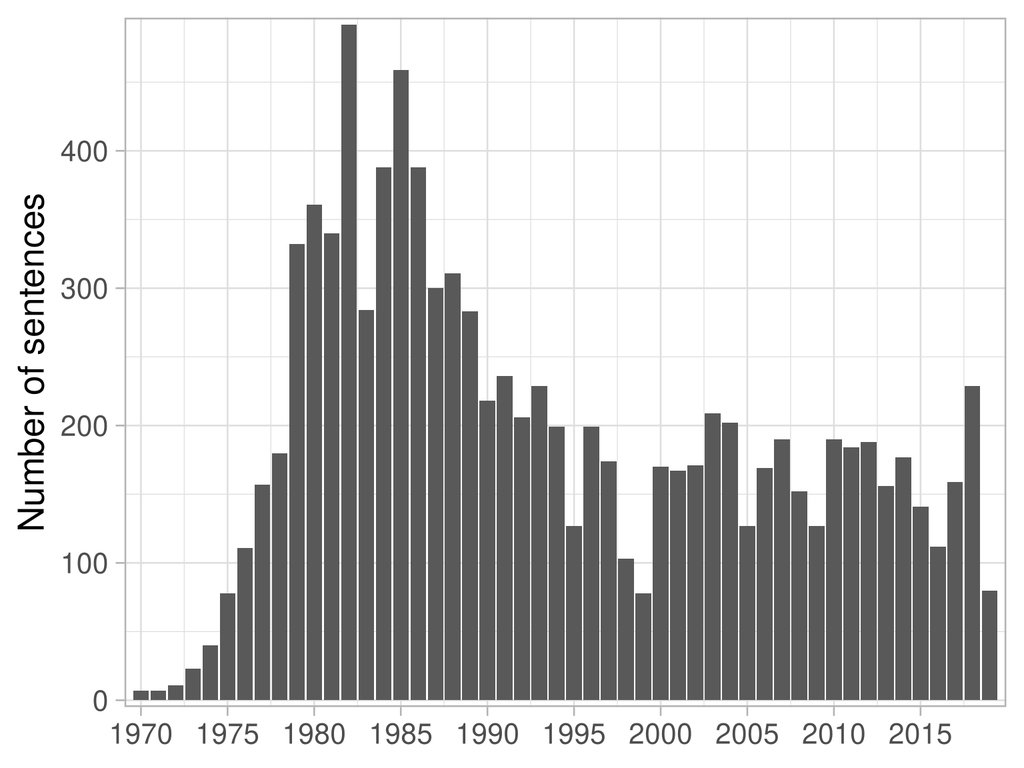

### Closest sentence from ‘rational’ and ‘rationality’ of the backbone community

| Sentence | Title | Year | Journal | Authors | Words Similarity |
| --- | --- | --- | --- | --- | --- |
| This article will criticize rational expectations models for several different reasons. | [What Is so Natural about the Natural Rate of Unemployment?](http://www.jstor.org/stable/4225072) | 1981 | Journal of Economic Issues | Robert Cherry | 0.877 |
| ’ In this article we concentrate on the role of the rational expectations hypothesis in the debate. | [THE CONTROVERSY OVER RATIONAL EXPECTATIONS](http://www.jstor.org/stable/23875719) | 1981 | National Institute Economic Review | David G. Mayes | 0.874 |
| For the purposes of this discussion, it will be assumed that economic agents form rational expectations. | [The Market for Innovations and Short-Run Technological Change: Evidence from Egypt](http://www.jstor.org/stable/1153789) | 1988 | Economic Development and Cultural Change | John M. Antle , Charles C. Crissman | 0.873 |
| In a general way this describes the overlap between the views usually associated with the label “rational expectations” and views expressed in the present paper and in my earlier writings. | [The Valid Core of Rationality Hypotheses In the Theory of Expectations](http://www.jstor.org/stable/1992033) | 1980 | Journal of Money, Credit and Banking | William Fellner | 0.866 |
| Rational Expectations and the Limits of Rationality: An Analysis of Heterogeneity By JOHN HALTIWANGER AND MICHAEL WALDMAN* A recurring controversy in economic thought concerns the conflict between the… | [Rational Expectations and the Limits of Rationality: An Analysis of Heterogeneity](http://www.jstor.org/stable/1814803) | 1985 | The American Economic Review | John Haltiwanger, Michael Waldman | 0.866 |
| The Valid Core of Rationality Hypotheses In the Theory of Expectations INTRODUCTION SECTION 1 DESCRIBES THE BACKGROUND of the debate from which the recent literature on rational expectations has emerg… | [The Valid Core of Rationality Hypotheses In the Theory of Expectations](http://www.jstor.org/stable/1992033) | 1980 | Journal of Money, Credit and Banking | William Fellner | 0.862 |
| By jointly assuming the mantle of rationality and equilibration, and by doing it in a way that enhanced their defensibility, the rational -expectations hypothesis burrowed to the core of economic thou… | [Conceptual Evolution in Economics: The Case of Rational Expectations](http://www.jstor.org/stable/40324998) | 1985 | Eastern Economic Journal | Randall Bausor | 0.862 |
| The first section of this paper presents a broad definition of rational expectations to clarify our understanding of the hypothesis. | [The Rational Expectations Hypothesis and Economic Analysis](http://www.jstor.org/stable/40325000) | 1985 | Eastern Economic Journal | Robert E. McAuliffe | 0.860 |
| One of the most potent of ideas of contemporary economics is the concept of rational expecta tions. | [THE RISE AND FALL OF THE DOLLAR](http://www.jstor.org/stable/23605737) | 1986 | Oxford Review of Economic Policy | CHRISTOPHER BLISS | 0.857 |
| INTRODUCTION The burgeoning literature employing or alluding to the concept of rational expectations’ in time-dependent economic processes is strangely vague regarding possible mechanisms by which the… | [Rational Expectations and Learning from Experience](http://www.jstor.org/stable/1882597) | 1979 | The Quarterly Journal of Economics | Stephen J. DeCanio | 0.856 |
| In Rational Expectations and Economic Policy. | [Anticipated Money and Real Output in Italy: Some Tests of a Rational Expectations Approach](http://www.jstor.org/stable/4537931) | 1985 | Journal of Post Keynesian Economics | Ali F. Darrat | 0.856 |
| “The Valid Core of the Rationality Hypothesis in the Theory of Expectations,” J. | [Recent Work on Business Cycles in Historical Perspective: A Review of Theories and Evidence](http://www.jstor.org/stable/2725624) | 1985 | Journal of Economic Literature | Victor Zarnowitz | 0.856 |
| Rational expecta tions may be appropriately applied to some financial and foreign exchange markets, but there are good grounds for doubting its applicability in other major areas, particularly to macr… | [THE CONTROVERSY OVER RATIONAL EXPECTATIONS](http://www.jstor.org/stable/23875719) | 1981 | National Institute Economic Review | David G. Mayes | 0.853 |
| In this paper we regard the rational expectations hypothesis as a potentially valuable tool in applied economics, realizing the absolute necessity to distinguish between the rational expectations hypo… | [Rational and Non-Rational Expectations of Inflation in Wage Equations for the United Kingdom](http://www.jstor.org/stable/2552959) | 1982 | Economica | Paul Ormerod | 0.850 |
| Several authors usually associated with “rational expectations theory” have recognized the validity of some of these, but no reasonably comprehensive discussion has so far been presented of the qualif… | [The Valid Core of Rationality Hypotheses In the Theory of Expectations](http://www.jstor.org/stable/1992033) | 1980 | Journal of Money, Credit and Banking | William Fellner | 0.848 |
| While many critics of rational expectations have noted the information requirements of the hypothesis, the problem this creates can be avoided by carefully stating the hypothesis in probabilistic term… | [The Concept of Habit in Economic Analysis](http://www.jstor.org/stable/4225959) | 1988 | Journal of Economic Issues | William T. Waller, Jr. | 0.847 |
| This framework is challenged by the literature on rational expectations. | [On Optimal Wage Indexation](http://www.jstor.org/stable/1832058) | 1983 | Journal of Political Economy | Edi Karni | 0.846 |
| Some controversy exists about the mechanism through which a rational expectations equilibrium might be achieved. | [Asset Valuation in an Experimental Market](http://www.jstor.org/stable/1912600) | 1982 | Econometrica | Robert Forsythe , Thomas R. Palfrey, Charles R. Plott | 0.846 |
| We discuss below how this rational expectations approach affects the analysis. | [Quality Uncertainty, Search, and Advertising](http://www.jstor.org/stable/1814660) | 1983 | The American Economic Review | Steven N. Wiggins, W. J. Lane | 0.844 |
| It is clear from this latest work that he sees rational expectations as a potentially useful modeling technique, but stops short of embracing the new classical research program. | [Two Types of Monetarism](http://www.jstor.org/stable/2725227) | 1984 | Journal of Economic Literature | Kevin D. Hoover | 0.843 |
| More recently the use of rational expectations has led to the development of an interesting ‘efficient markets’ perspective. | [Public Sector Deficits, International Capital Movements, and the Domestic Economy: The Medium-Term Is the Message](http://www.jstor.org/stable/135087) | 1985 | The Canadian Journal of Economics / Revue canadienne d’Economique | Douglas D. Purvis | 0.843 |

### Closest sentences of the backbone community’s centroid

| Sentence | Title | Year | Journal | Authors | Centroid Similarity |
| --- | --- | --- | --- | --- | --- |
| He criticizes rational expectations for trying to carve out a role for equilibrium constructions in- economics, so denying the essentially dynamic properties involved: A realistic appreciation of the … | [Rational Expectations: A Promising Research Program or a Case of Monetarist Fundamentalism?](http://www.jstor.org/stable/4225509) | 1984 | Journal of Economic Issues | John J. Struthers | 0.7477019 |
| In his use of the concept, the diverse expectations of different economic participants could affect their production and pricing decisions. | [Incomes Policy: Completing the Stabilization Triangle](http://www.jstor.org/stable/4224178) | 1972 | Journal of Economic Issues | Sidney Weintraub | 0.7097958 |
| Rational Expectations and the Limits of Rationality: An Analysis of Heterogeneity By JOHN HALTIWANGER AND MICHAEL WALDMAN* A recurring controversy in economic thought concerns the conflict between the… | [Rational Expectations and the Limits of Rationality: An Analysis of Heterogeneity](http://www.jstor.org/stable/1814803) | 1985 | The American Economic Review | John Haltiwanger, Michael Waldman | 0.7054626 |
| Admittedly he did publish, but slightly less at the frontier of research and more in the direction of a general audience.22 During the 2000-2004 period, seven articles can be found: two in the Second-… | [Roger Guesnerie: An Hors Catégorie Career](http://www.jstor.org/stable/10.15609/annaeconstat2009.135.0001) | 2019 | Annals of Economics and Statistics | Laurent Linnemer | 0.7017708 |
| His work has brought about a rapid and revolutionary development: the application of the rational expectations hypothesis, the emergence of an equilibrium theory of business cycles, and the macroecono… | [The Scientific Contributions of Robert E. Lucas, Jr.](http://www.jstor.org/stable/3440576) | 1996 | The Scandinavian Journal of Economics | Lars E. O. Svensson | 0.7009497 |
| He conjectures, and gives ample reasons for this conjecture, that “a rise in expectations has produced a negative reaction to economic attainments which otherwise might have elicited litanies of prais… | [Less Developed Countries and the Liberal International Economic Order](http://www.jstor.org/stable/41797927) | 1978 | Zeitschrift für Nationalökonomie / Journal of Economics | Gottfried Haberler | 0.6978435 |
| The implications of rational expectations for the objectivity and logic of economics remain to be explored. | [Economic Methodology in a Nutshell](http://www.jstor.org/stable/1942672) | 1989 | The Journal of Economic Perspectives | Daniel M. Hausman | 0.6952154 |
| In any case, in terms of the argument being made here, the rise to some prominence of rational expectations in monetarist thinking does not constitute the emergence of an alternative monetarist theore… | [The Evolution of Monetarism](http://www.jstor.org/stable/40750456) | 1981 | Zeitschrift für die gesamte Staatswissenschaft / Journal of Institutional and Theoretical Economics | Ronald L. Teigen | 0.6946682 |
| It can be argued, however, that the concept of rationality as widely used by many economists today, including those involved with the rational expectations debate, is not so much concerned with the pr… | [Rational Behavior with Deficient Foresight](http://www.jstor.org/stable/40325203) | 1988 | Eastern Economic Journal | Omar F. Hamouda, John N. Smithin | 0.6941194 |
| The economist who wishes to value an income stream may not have perfect foresight, and need not observe equilibrium prices, but can nevertheless form sensible price expectations. | [The Value of Future Earnings in Perfect Foresight Equilibrium](http://www.jstor.org/stable/42756063) | 2011 | Journal of Forensic Economics | Scott Dale Gilbert | 0.6933948 |
| Concerning the treatment of expectations he said, “I have thought it desirable to mark a division between my general discussion of the method of expectations, on the one hand, and what I have to say a… | [Beyond the IS/lM Device: Was Keynes a Hicksian?](http://www.jstor.org/stable/40325047) | 1986 | Eastern Economic Journal | O. F. Hamouda | 0.6926624 |
| It is important to recognize that this conclu sion does not stem principally from the assump tion that producers and consumers possess and act on “rational expectations.” | [The Possibilities and Limits of Aggregate Demand Management](http://www.jstor.org/stable/20642309) | 1978 | Eastern Economic Journal | Charles L. Schultze | 0.6925923 |
| But people who base policies for real economies on the belief that citizens form their expectations rationally and that the invisible hand, if left to its own devices, will guide us to a rational expe… | [Rational Expectations: A Promising Research Program or a Case of Monetarist Fundamentalism?](http://www.jstor.org/stable/4225509) | 1984 | Journal of Economic Issues | John J. Struthers | 0.6904018 |
| Related thereto are conflicts as to the precise relationships among new classical economics, monetarism, and rational expectations economics. | [On Macroeconomic Politics](http://www.jstor.org/stable/4538416) | 1994 | Journal of Post Keynesian Economics | Warren J. Samuels | 0.6895745 |
| By jointly assuming the mantle of rationality and equilibration, and by doing it in a way that enhanced their defensibility, the rational -expectations hypothesis burrowed to the core of economic thou… | [Conceptual Evolution in Economics: The Case of Rational Expectations](http://www.jstor.org/stable/40324998) | 1985 | Eastern Economic Journal | Randall Bausor | 0.6894048 |

### Closest sentences of each kmean cluster’s centroid composing the backbone community

#### Top terms 11_79: rational_expectations, expectations, expectations_hypothesis, expectations_model, adaptive_expectations (1970-1979)

| Sentence | Title | Year | Journal | Authors | Distance to Centroid |
| --- | --- | --- | --- | --- | --- |
| Although Baily motivates this work by referring to the recent literature of “rational” expectations, there are in fact two competing expectations hypotheses in his paper. | [Stabilization Policy and Private Economic Behavior](http://www.jstor.org/stable/2534361) | 1978 | Brookings Papers on Economic Activity | Martin Neil Baily , Edmund S. Phelps , Benjamin M. Friedman | 5.947813 |
| The greater part of the paper discusses rational expectations and their implications. | [Rational Expectations in the Macro Model](http://www.jstor.org/stable/2534381) | 1976 | Brookings Papers on Economic Activity | William Poole , Edmund S. Phelps, Martin N. Baily | 6.139074 |
| Expectations about a variable are said to be rational if they depend, in the proper way, on the same things that economic theory says actually determine that variable. | [Rational Expectations and the Dynamics of Hyperinflation](http://www.jstor.org/stable/2525924) | 1973 | International Economic Review | Thomas J. Sargent, Neil Wallace | 6.378948 |
| Expectations are rational when they concur with the predictions of the relevant economic theory. | [Inflation Theory 1963-1975: A “Second Generation” Survey](http://www.jstor.org/stable/2722965) | 1977 | Journal of Economic Literature | Helmut Frisch | 6.405227 |
| Rational Expectations and the Theory of Economic Policy.”J. | [Nominal Demand Policy and Short-Run Fluctuations in Unemployment and Prices in the United States](http://www.jstor.org/stable/1833082) | 1979 | Journal of Political Economy | Jacob Grossman | 6.498816 |

#### Top terms 11_101: rational_expectations, expectations, expectations_hypothesis, expectations_theory, expectations_formation (1980-1989)

| Sentence | Title | Year | Journal | Authors | Distance to Centroid |
| --- | --- | --- | --- | --- | --- |
| Reflections on Rational Expectations Phillip Cagan The hypothesis of rational expectations has rapidly gained attention because it is so natural and appealing. | [Reflections on Rational Expectations](http://www.jstor.org/stable/1992037) | 1980 | Journal of Money, Credit and Banking | Phillip Cagan | 5.722468 |
| The rational expectations hypothesis provides an alternate behavioral assumption that describes how agents form expectations in a manner stochastically consistent with the behavior of real variables. | [Some Political Economy Aspects of Macroeconomic Linkages with Agriculture](http://www.jstor.org/stable/1241454) | 1986 | American Journal of Agricultural Economics | Margaret S. Andrews, Gordon C. Rausser | 5.735761 |
| In this paper I hope to eliminate some of the confusion surrounding the REH by separating the hypothesis of rational expectations from the models in which it has been employed. | [The Rational Expectations Hypothesis and Economic Analysis](http://www.jstor.org/stable/40325000) | 1985 | Eastern Economic Journal | Robert E. McAuliffe | 5.837156 |
| RATIONAL EXPECTATIONS Attention is now turned to the version of the model in which expectations are formed rationally. | [Expectations and a Small Open Economy with a Flexible Exchange Rate](http://www.jstor.org/stable/134616) | 1980 | The Canadian Journal of Economics / Revue canadienne d’Economique | David Burton | 5.891704 |
| The first section of this paper presents a broad definition of rational expectations to clarify our understanding of the hypothesis. | [The Rational Expectations Hypothesis and Economic Analysis](http://www.jstor.org/stable/40325000) | 1985 | Eastern Economic Journal | Robert E. McAuliffe | 5.930237 |

#### Top terms 11_107: rational_expectations, expectations_models, expectations, expectations_equilibrium, expectations_model (1980-1989)

| Sentence | Title | Year | Journal | Authors | Distance to Centroid |
| --- | --- | --- | --- | --- | --- |
| A rational expectations model is analyzed in Section 4. | [An Open-Access Fishery with Rational Expectations](http://www.jstor.org/stable/1911500) | 1984 | Econometrica | Peter Berck , Jeffrey M. Perloff | 5.424373 |
| Rational Expectations and Econometric Practice, vol. | [Human Capital, Adaptive Ability, and the Distributional Implications of Agricultural Policy](http://www.jstor.org/stable/1240714) | 1985 | American Journal of Agricultural Economics | Wallace E. Huffman | 5.569769 |
| “Exact Rational Expectations Models: Specification and Estimation.” | [Forecasting the Forecasts of Others](http://www.jstor.org/stable/1831068) | 1983 | Journal of Political Economy | Robert M. Townsend | 5.643779 |
| paper on rational expectations.15 Only notational changes are made, to be consistent with the analysis earlier in the present paper. | [Speculative Price: Economic Welfare and the Idiot of Chance](http://www.jstor.org/stable/1924093) | 1981 | The Review of Economics and Statistics | Jerome L. Stein | 5.697691 |
| For an analysis of macroeconomic models used in the rational expectations literature, see my forthcoming paper. | [Towards an Understanding of Market Processes: Individual Expectations, Learning, and Convergence to Rational Expectations Equilibrium](http://www.jstor.org/stable/1810008) | 1982 | The American Economic Review | Roman Frydman | 5.811324 |

#### Top terms 11_109: rational_expectations, expectations, expectations_hypothesis, expectations_equilibrium, expectations_models (1990-1999)

| Sentence | Title | Year | Journal | Authors | Distance to Centroid |
| --- | --- | --- | --- | --- | --- |
| Given the widespread use of the rational expectations hypothesis, an important empirical issue has become the extent to which expectations of economic variables are consistent with rational expectatio… | [Weak- and Strong-Form Rationality Tests of Market Analysts’ Expectations of USDA “Hogs and Pigs” Reports](http://www.jstor.org/stable/1349505) | 1992 | Review of Agricultural Economics | Phil L. Colling, Scott H. Irwin , Carl R. Zulauf | 5.676664 |
| Introduction Rational expectations, a cornerstone of modern theories in economics and finance, has come under attack. | [Habit Formation: A Resolution of the Equity Premium Puzzle](http://www.jstor.org/stable/2937698) | 1990 | Journal of Political Economy | George M. Constantinides | 5.741834 |
| The rational expectations model is formulated. | [Effects of Government Programs on Rice Acreage Decisions under Rational Expectations: The Case of Taiwan](http://www.jstor.org/stable/1242485) | 1992 | American Journal of Agricultural Economics | C-H Huang | 5.782940 |
| Rational expectations and econometric practice, vols. | [A Rational Expectations Experiment](http://www.jstor.org/stable/1182411) | 1990 | The Journal of Economic Education | Norris A. Peterson | 5.799999 |
| : Rational Expectations and Econometric Practice, vol. | [Production-Based Asset Pricing and the Link Between Stock Returns and Economic Fluctuations](http://www.jstor.org/stable/2328694) | 1991 | The Journal of Finance | John H. Cochrane | 5.838519 |

#### Top terms 11_137: rational_expectations, expectations, expectations_equilibrium, expectations_models, expectations_equilibria (2000-2009)

| Sentence | Title | Year | Journal | Authors | Distance to Centroid |
| --- | --- | --- | --- | --- | --- |
| In my analysis throughout this paper, I have used the now standard assumption that expectations are formed rationally. | [The Inexorable and Mysterious Tradeoff between Inflation and Unemployment](http://www.jstor.org/stable/2667829) | 2001 | The Economic Journal | N. Gregory Mankiw | 6.227411 |
| In Rational Expectations and Econometric Practice, pp. | [Assessing the Lucas Critique in Monetary Policy Models](http://www.jstor.org/stable/3838926) | 2005 | Journal of Money, Credit and Banking | Glenn D. Rudebusch | 6.269308 |
| The policy equilibrium is built upon the rational expectations 4. | [A General Theory (And Some Evidence) of Expectation Traps in Monetary Policy](http://www.jstor.org/stable/25096285) | 2008 | Journal of Money, Credit and Banking | Roc Armenter | 6.328296 |
| 3 Rational expectations This section and the next show how the NKPC might be estimated under the assumption that expectations are formed rationally. | [The new Keynesian Phillips curve and inflation expectations: re-specification and interpretation](http://www.jstor.org/stable/27822518) | 2007 | Economic Theory | P. A. V. B. Swamy, George S. Tavlas | 6.372353 |
| the rational expectations equilibrium. | [Learning with Expert Advice](http://www.jstor.org/stable/40005046) | 2007 | Journal of the European Economic Association | Krisztina Molnár | 6.380433 |

#### Top terms 11_154: rational_expectations, expectations, expectations_equilibrium, expectations_models, expectations_hypothesis (2010-2019)

| Sentence | Title | Year | Journal | Authors | Distance to Centroid |
| --- | --- | --- | --- | --- | --- |
| Even if expectations are inflated at t — 1, they return to rationality on average at t. As we show in Section IV, this behavior allows us to account for the empirical findings in Section I. III. | [Diagnostic Expectations and Credit Cycles](http://www.jstor.org/stable/26653274) | 2018 | The Journal of Finance | PEDRO BORDALO , NICOLA GENNAIOLI, ANDREI SHLEIFER | 6.544252 |
| When agents’ expectations functions embed the possibil ity of policy regime changes in the future, the nature of rational expectations equilibria can be altered in fundamental ways. | [Generalizing the Taylor Principle: Reply](http://www.jstor.org/stable/27804945) | 2010 | The American Economic Review | Troy Daving , Eric M. Leeper | 6.653629 |
| Re-examining the rational expectations hypothesis. | [ASSESSING THE TEMPORAL VARIATION OF MACROECONOMIC FORECASTS BY A PANEL OF CHANGING COMPOSITION](http://www.jstor.org/stable/41336497) | 2011 | Journal of Applied Econometrics | JOSEPH ENGELBERG , CHARLES F. MANSKI, JARED WILLIAMS | 6.700560 |
| rational expectations models. | [Inventory Investment and the Empirical Phillips Curve](http://www.jstor.org/stable/23320082) | 2013 | Journal of Money, Credit and Banking | YONGSEUNG JUNG, TACK YUN | 6.702113 |
| uture work incorporating quasi-rational expectations into macroeconomic analysis could move forward along several paths. | [Natural Expectations and Macroeconomic Fluctuations](http://www.jstor.org/stable/20799173) | 2010 | The Journal of Economic Perspectives | Andreas Fuster, David Laibson , Brock Mendel | 6.708556 |

### Top articles (most sentences) of the backbone cluster

| Title | Year | Journal | Authors | Number sentences | Words Similarity |
| --- | --- | --- | --- | --- | --- |
| [Rational Expectations: A Promising Research Program or a Case of Monetarist Fundamentalism?](http://www.jstor.org/stable/4225509) | 1984 | Journal of Economic Issues | John J. Struthers | 57 | 0.700 |
| [THE CONTROVERSY OVER RATIONAL EXPECTATIONS](http://www.jstor.org/stable/23875719) | 1981 | National Institute Economic Review | David G. Mayes | 44 | 0.708 |
| [A Child’s Guide to Rational Expectations](http://www.jstor.org/stable/2724658) | 1982 | Journal of Economic Literature | Rodney Maddock, Michael Carter | 39 | 0.679 |
| [Rational Expectations, Information and Asset Markets: An Introduction](http://www.jstor.org/stable/2663195) | 1985 | Oxford Economic Papers | Margaret Bray | 39 | 0.685 |
| [What’s so Rational about Rational Expectations? Hyperrationality and the Logical Limits to Neoclassicism](http://www.jstor.org/stable/4538571) | 1997 | Journal of Post Keynesian Economics | Steven Shulman | 36 | 0.691 |
| [Policy Analysis with Econometric Models](http://www.jstor.org/stable/2534318) | 1982 | Brookings Papers on Economic Activity | Christopher A. Sims, Stephen M. Goldfeld, Jeffrey D. Sachs | 35 | 0.694 |
| [Rational Expectations and Economic Thought](http://www.jstor.org/stable/2723721) | 1979 | Journal of Economic Literature | Brian Kantor | 33 | 0.718 |
| [The Theory of Rationally Heterogeneous Expectations: Evidence from Survey Data on Inflation Expectations](http://www.jstor.org/stable/3590297) | 2004 | The Economic Journal | William A. Branch | 32 | 0.632 |
| [The Valid Core of Rationality Hypotheses In the Theory of Expectations](http://www.jstor.org/stable/1992033) | 1980 | Journal of Money, Credit and Banking | William Fellner | 28 | 0.738 |
| [Varieties of Rational Expectations: Their Differences and Relations](http://www.jstor.org/stable/4537962) | 1986 | Journal of Post Keynesian Economics | Jan Snippe | 26 | 0.702 |
| [Rational Expectations in the Macro Model](http://www.jstor.org/stable/2534381) | 1976 | Brookings Papers on Economic Activity | William Poole , Edmund S. Phelps, Martin N. Baily | 25 | 0.686 |
| [A Review of Recent Work in the Area of Inflationary Expectations](http://www.jstor.org/stable/40438933) | 1980 | Weltwirtschaftliches Archiv | James H. Chan-Lee | 23 | 0.656 |
| [The rational-expectations hypothesis and the epistemics of time](http://www.jstor.org/stable/23596526) | 1983 | Cambridge Journal of Economics | Randall Bausor | 23 | 0.725 |
| [Keynes, Harrod, and the Rational Expectations Revolution](http://www.jstor.org/stable/4537930) | 1985 | Journal of Post Keynesian Economics | Steven M. Fazzari | 23 | 0.671 |
| [Irrationality of “Rational Expectations”](http://www.jstor.org/stable/4537710) | 1982 | Journal of Post Keynesian Economics | Gustavo Maia Gomes | 22 | 0.697 |

### Top articles (most sentences) of the cluster for each time window

#### Top articles for 11_79: rational_expectations, expectations, expectations_hypothesis, expectations_model, adaptive_expectations (1970-1979)

| Title | Year | Journal | Authors | Number sentences | Words Similarity |
| --- | --- | --- | --- | --- | --- |
| [Rational Expectations and Economic Thought](http://www.jstor.org/stable/2723721) | 1979 | Journal of Economic Literature | Brian Kantor | 33 | 0.718 |
| [Rational Expectations in the Macro Model](http://www.jstor.org/stable/2534381) | 1976 | Brookings Papers on Economic Activity | William Poole , Edmund S. Phelps, Martin N. Baily | 25 | 0.686 |
| [Evolutionary Economics, Rational Expectations, and Monetary Policy](http://www.jstor.org/stable/4224696) | 1978 | Journal of Economic Issues | William J. Frazer, Jr. | 17 | 0.712 |
| [Rational Expectations Equilibrium: Generic Existence and the Information Revealed by Prices](http://www.jstor.org/stable/1910413) | 1979 | Econometrica | Roy Radner | 14 | 0.666 |
| [An Analysis of a Macro-Econometric Model with Rational Expectations in the Bond and Stock Markets](http://www.jstor.org/stable/1808701) | 1979 | The American Economic Review | Ray C. Fair | 13 | 0.709 |
| [Recent Developments in Monetary Theory](http://www.jstor.org/stable/1818847) | 1975 | The American Economic Review | Stanley Fischer | 11 | 0.683 |
| [External and Internal Adjustment Costs and the Theory of Aggregate and Firm Investment](http://www.jstor.org/stable/2553718) | 1977 | Economica | Michael Mussa | 11 | 0.687 |
| [The Credibility Effect and Rational Expectations: Implications of the Gramlich Study](http://www.jstor.org/stable/2534307) | 1979 | Brookings Papers on Economic Activity | William Fellner , Edmund S. Phelps, Robert J. Gordon | 11 | 0.703 |
| [Rational Expectations and Bayesian Analysis](http://www.jstor.org/stable/1829843) | 1974 | Journal of Political Economy | Richard M. Cyert , Morris H. DeGroot | 10 | 0.661 |
| [Economically Rational Expectations: Are Innovations in the Rate of Inflation Independent of Innovations in Measures of Monetary and Fiscal Policy?](http://www.jstor.org/stable/1829866) | 1976 | Journal of Political Economy | Edgar L. Feige , Douglas K. Pearce | 10 | 0.725 |

#### Top articles for 11_101: rational_expectations, expectations, expectations_hypothesis, expectations_theory, expectations_formation (1980-1989)

| Title | Year | Journal | Authors | Number sentences | Words Similarity |
| --- | --- | --- | --- | --- | --- |
| [Rational Expectations: A Promising Research Program or a Case of Monetarist Fundamentalism?](http://www.jstor.org/stable/4225509) | 1984 | Journal of Economic Issues | John J. Struthers | 56 | 0.699 |
| [THE CONTROVERSY OVER RATIONAL EXPECTATIONS](http://www.jstor.org/stable/23875719) | 1981 | National Institute Economic Review | David G. Mayes | 42 | 0.706 |
| [A Child’s Guide to Rational Expectations](http://www.jstor.org/stable/2724658) | 1982 | Journal of Economic Literature | Rodney Maddock, Michael Carter | 33 | 0.685 |
| [Policy Analysis with Econometric Models](http://www.jstor.org/stable/2534318) | 1982 | Brookings Papers on Economic Activity | Christopher A. Sims, Stephen M. Goldfeld, Jeffrey D. Sachs | 26 | 0.704 |
| [The Valid Core of Rationality Hypotheses In the Theory of Expectations](http://www.jstor.org/stable/1992033) | 1980 | Journal of Money, Credit and Banking | William Fellner | 24 | 0.753 |
| [Varieties of Rational Expectations: Their Differences and Relations](http://www.jstor.org/stable/4537962) | 1986 | Journal of Post Keynesian Economics | Jan Snippe | 22 | 0.715 |
| [Tests of the Rational Expectations Hypothesis](http://www.jstor.org/stable/1804130) | 1986 | The American Economic Review | Michael C. Lovell | 20 | 0.734 |
| [Keynes, Harrod, and the Rational Expectations Revolution](http://www.jstor.org/stable/4537930) | 1985 | Journal of Post Keynesian Economics | Steven M. Fazzari | 19 | 0.673 |
| [Irrational Expectations, Unclearing Markets and a Business Cycle That Won’t Go Away: The Recent School of New Classical Economists Comes a Cropper on Basic Economic Facts](http://www.jstor.org/stable… | 1988 | The American Journal of Economics and Sociology | Dipendra Sinha | 19 | 0.694 |
| [Irrationality of “Rational Expectations”](http://www.jstor.org/stable/4537710) | 1982 | Journal of Post Keynesian Economics | Gustavo Maia Gomes | 18 | 0.717 |

#### Top articles for 11_107: rational_expectations, expectations_models, expectations, expectations_equilibrium, expectations_model (1980-1989)

| Title | Year | Journal | Authors | Number sentences | Words Similarity |
| --- | --- | --- | --- | --- | --- |
| [Rational Expectations, Information and Asset Markets: An Introduction](http://www.jstor.org/stable/2663195) | 1985 | Oxford Economic Papers | Margaret Bray | 23 | 0.674 |
| [Autoregressions, Expectations, and Advice](http://www.jstor.org/stable/1816394) | 1984 | The American Economic Review | Thomas J. Sargent | 14 | 0.681 |
| [Rational Expectations Equilibria, Learning, and Model Specification](http://www.jstor.org/stable/1912325) | 1986 | Econometrica | M. M. Bray , N. E. Savin | 13 | 0.652 |
| [Risk Behavior and Rational Expectations in the U.S. Broiler Market](http://www.jstor.org/stable/1242667) | 1989 | American Journal of Agricultural Economics | Satheesh V. Aradhyula, Matthew T. Holt | 13 | 0.630 |
| [Bounded Price Variation and Rational Expectations in Endogenous Switching Model of the U.S. Corn Market](http://www.jstor.org/stable/1928102) | 1989 | The Review of Economics and Statistics | Matthew T. Holt , Stanley R. Johnson | 11 | 0.655 |
| [A Noisy Rational Expectations Equilibrium for Multi-Asset Securities Markets](http://www.jstor.org/stable/1911659) | 1985 | Econometrica | Anat R. Admati | 10 | 0.649 |
| [On Some Conceptual Issues in Rational Expectations Modeling](http://www.jstor.org/stable/1992035) | 1980 | Journal of Money, Credit and Banking | Edwin Burmeister | 9 | 0.652 |
| [Policy Analysis with Econometric Models](http://www.jstor.org/stable/2534318) | 1982 | Brookings Papers on Economic Activity | Christopher A. Sims, Stephen M. Goldfeld, Jeffrey D. Sachs | 9 | 0.664 |
| [Forecasting the Forecasts of Others](http://www.jstor.org/stable/1831068) | 1983 | Journal of Political Economy | Robert M. Townsend | 9 | 0.676 |
| [A Model of Exchange Rate Dynamics](http://www.jstor.org/stable/1831230) | 1982 | Journal of Political Economy | Michael Mussa | 8 | 0.660 |

#### Top articles for 11_109: rational_expectations, expectations, expectations_hypothesis, expectations_equilibrium, expectations_models (1990-1999)

| Title | Year | Journal | Authors | Number sentences | Words Similarity |
| --- | --- | --- | --- | --- | --- |
| [What’s so Rational about Rational Expectations? Hyperrationality and the Logical Limits to Neoclassicism](http://www.jstor.org/stable/4538571) | 1997 | Journal of Post Keynesian Economics | Steven Shulman | 36 | 0.691 |
| [Will the New Keynesian Macroeconomics Resurrect the IS-LM Model?](http://www.jstor.org/stable/2138320) | 1993 | The Journal of Economic Perspectives | Robert G. King | 20 | 0.668 |
| [Robert Lucas’s Nobel Memorial Prize](http://www.jstor.org/stable/3440577) | 1996 | The Scandinavian Journal of Economics | Stanley Fischer | 16 | 0.662 |
| [A Quick Refresher Course in Macroeconomics](http://www.jstor.org/stable/2727441) | 1990 | Journal of Economic Literature | N. Gregory Mankiw | 15 | 0.665 |
| [EXPECTATIONS IN THE SHIPPING SECTOR](http://www.jstor.org/stable/42747222) | 1993 | International Journal of Transport Economics / Rivista internazionale di economia dei trasporti | G. WRIGHT | 15 | 0.724 |
| [Testing the Rationality of Price Forecasts: New Evidence from Panel Data](http://www.jstor.org/stable/2006704) | 1990 | The American Economic Review | Michael P. Keane, David E. Runkle | 14 | 0.698 |
| [Uncertainty, Expectations, and the Future: If We Don’t Know the Answers, What Are the Questions?](http://www.jstor.org/stable/4538371) | 1993 | Journal of Post Keynesian Economics | Thomas I. Palley | 14 | 0.683 |
| [Dynamic Stock Markets with Multiple Assets: An Experimental Analysis](http://www.jstor.org/stable/2328574) | 1991 | The Journal of Finance | John O’Brien , Sanjay Srivastava | 13 | 0.666 |
| [An Exploration of the Eductive Justifications of the Rational-Expectations Hypothesis](http://www.jstor.org/stable/2117477) | 1992 | The American Economic Review | Roger Guesnerie | 13 | 0.690 |
| [Learning Rational Expectations in an Asset Market](http://www.jstor.org/stable/41794435) | 1995 | Journal of Economics | Ricardo Grinspun | 13 | 0.673 |

#### Top articles for 11_137: rational_expectations, expectations, expectations_equilibrium, expectations_models, expectations_equilibria (2000-2009)

| Title | Year | Journal | Authors | Number sentences | Words Similarity |
| --- | --- | --- | --- | --- | --- |
| [The Theory of Rationally Heterogeneous Expectations: Evidence from Survey Data on Inflation Expectations](http://www.jstor.org/stable/3590297) | 2004 | The Economic Journal | William A. Branch | 32 | 0.632 |
| [Are Rational Expectations Equilibria with Private Information Eductively Stable?](http://www.jstor.org/stable/41795156) | 2004 | Journal of Economics | Maik Heinemann | 20 | 0.678 |
| [Modigliani’s Expectations](http://www.jstor.org/stable/40326404) | 2004 | Eastern Economic Journal | James E. Hartley | 19 | 0.639 |
| [Beliefs, Doubts and Learning: Valuing Macroeconomic Risk](http://www.jstor.org/stable/30034417) | 2007 | The American Economic Review | Lars Peter Hansen | 19 | 0.677 |
| [The Government and Market Expectations](http://www.jstor.org/stable/40752255) | 2001 | Journal of Institutional and Theoretical Economics (JITE) / Zeitschrift für die gesamte Staatswissenschaft | Roger Guesnerie | 17 | 0.670 |
| [Expectations and the Effects of Monetary Policy](http://www.jstor.org/stable/3649897) | 2003 | Journal of Money, Credit and Banking | Laurence Ball , Dean Croushore | 16 | 0.654 |
| [Measuring Expectations](http://www.jstor.org/stable/3598892) | 2004 | Econometrica | Charles F. Manski | 16 | 0.652 |
| [Why Does Data Reject the Lucas Critique?](http://www.jstor.org/stable/20076344) | 2002 | Annales d’Économie et de Statistique | Roger E. A. Farmer | 14 | 0.702 |
| [Evolution and Intelligent Design](http://www.jstor.org/stable/29729962) | 2008 | The American Economic Review | Thomas J. Sargent | 14 | 0.668 |
| [Forecast Failure, Expectations Formation and the Lucas Critique](http://www.jstor.org/stable/20076341) | 2002 | Annales d’Économie et de Statistique | David F. Hendry | 13 | 0.651 |

#### Top articles for 11_154: rational_expectations, expectations, expectations_equilibrium, expectations_models, expectations_hypothesis (2010-2019)

| Title | Year | Journal | Authors | Number sentences | Words Similarity |
| --- | --- | --- | --- | --- | --- |
| [Information, Learning and Expectations in an Experimental Model Economy](http://www.jstor.org/stable/24029608) | 2013 | Economica | Michael W. M. Roos, Wolfgang J. Luhan | 18 | 0.639 |
| [Expectations and Investment](http://www.jstor.org/stable/26556656) | 2015 | NBER Macroeconomics Annual | Nicola Gennaioli, Yueran Ma , Andrei Shleifer | 18 | 0.637 |
| [Survey Measurement of Probabilistic Macroeconomic Expectations](http://www.jstor.org/stable/26556599) | 2017 | NBER Macroeconomics Annual | Charles F. Manski | 17 | 0.643 |
| [The Science of Monetary Policy](http://www.jstor.org/stable/26417200) | 2018 | Journal of Economic Literature | Stefano Eusepi, Bruce Preston | 17 | 0.621 |
| [Nobel Lecture: Uncertainty Outside and Inside Economic Models](http://www.jstor.org/stable/10.1086/678456) | 2014 | Journal of Political Economy | Lars Peter Hansen | 15 | 0.674 |
| [The scientific foundation of dynamic stochastic general equilibrium (DSGE) models](http://www.jstor.org/stable/40835621) | 2010 | Public Choice | Paul De Grauwe | 14 | 0.684 |
| [Learning and the Yield Curve](http://www.jstor.org/stable/43862621) | 2016 | Journal of Money, Credit and Banking | ARUNIMA SINHA | 14 | 0.638 |
| [EXPECTATION SHOCKS AND LEARNING AS DRIVERS OF THE BUSINESS CYCLE](http://www.jstor.org/stable/41236984) | 2011 | The Economic Journal | Fabio Milani | 13 | 0.659 |
| [Agents as Empirical Macroeconomists: Thomas J. Sargent’s Contribution to Economics](http://www.jstor.org/stable/23356949) | 2012 | The Scandinavian Journal of Economics | Harald Uhlig | 13 | 0.667 |
| [Short-Run and Long-Run Effects of Milton Friedman’s Presidential Address](http://www.jstor.org/stable/26297972) | 2018 | The Journal of Economic Perspectives | Robert E. Hall , Thomas J. Sargent | 13 | 0.639 |

### Most cited references in the backbone community

| First Author | Year | Journal | Citation by article | Citation by sentence |
| --- | --- | --- | --- | --- |
| MUTH-J | 1961 | ECONOMETRICA | 145 | 31030 |
| LUCAS-R | 1973 | AER | 63 | 5985 |
| SARGENT-T | 1975 | J POLITICAL EC | 39 | 1443 |
| CLARIDA-R | 1999 | J ECON LIT | 34 | 340 |
| SARGENT-T | 1976 | J POLITICAL EC | 6 | 234 |
| FISCHER-S | 1977 | J POLITICAL EC | 2 | 178 |
| BARRO-R | 1977 | AER | 2 | 178 |
| KYDLAND-F | 1977 | J POLITICAL EC | 2 | 178 |
| BARRO-R | 1976 | J MONETARY EC | 2 | 178 |
| KEANE-M | 1990 | AM ECON REV | 3 | 144 |
| FRANKEL-J | 1987 | AM EC REV | 3 | 129 |
| BULLARD-J | 2002 | J MONETARY ECON | 5 | 80 |
| EVANS-G | 2003 | REV ECON STUD | 4 | 76 |
| LUCAS-R | 1975 | JPE | 6 | 36 |
| CALVO-G | 1983 | J MONETARY EC | 32 | 32 |

| First Author | Year | Journal | Citation by article | Citation by sentence |
| --- | --- | --- | --- | --- |
| KEYNES-J | 1936 | GENERAL THEORY EMPLO | 171 | 12654 |
| LEIJONHUFVUD-A | 1968 | KEYNESIAN EC EC KEYN | 40 | 3560 |
| EVANS-G | 2001 | LEARNING EXPECTATION | 69 | 3450 |
| SARGENT-T | 1979 | MACROECONOMIC THEORY | 105 | 2415 |
| BEGG-D | 1982 | RATIONAL EXPECTATION | 27 | 2133 |
| WOODFORD-M | 2003 | INTEREST PRICES FDN | 73 | 2044 |
| OKUN-A | 1981 | PRICES QUANTITIES MA | 17 | 952 |
| KEYNES-J | 1936 | GEN THEORY EMPLOYMEN | 39 | 780 |
| PHELPS-E | 1970 | MICROECONOMIC F EMPL | 21 | 693 |
| SARGENT-T | 1993 | BOUNDED RATIONALITY | 20 | 640 |
| MALINVAUD-E | 1977 | THEORY UNEMPLOYMENT | 19 | 627 |
| KEYNES-J | 1930 | TREATISE MONEY | 18 | 594 |
| SARGENT-T | 1999 | CONQUEST AM INFLATIO | 16 | 512 |
| LEIJONHUFVUD-A | 1981 | INFORMATION COORDINA | 9 | 504 |
| TOBIN-J | 1980 | ASSET ACCUMLATION EC | 23 | 460 |

### Most cited references per kmean clusters

#### Top references 11_79: rational_expectations, expectations, expectations_hypothesis, expectations_model, adaptive_expectations (1970-1979)

| First Author | Year | Journal | Citation by article | Citation by sentence |
| --- | --- | --- | --- | --- |
| MUTH-J | 1961 | ECONOMETRICA | 18 | 54 |
| MUTH-J | 1961 | ECONOMETRICA | 4 | 40 |
| MUTH-J | 1961 | ECONOMETRICA | 19 | 38 |
| HALL-R | 1978 | JPE | 1 | 33 |
| FRENKEL-J | 1977 | AM EC REV | 1 | 33 |
| FRENKEL-J | 1979 | J MONET EC | 1 | 33 |
| FRIEDMAN-M | 1968 | AER | 1 | 33 |
| FISCHER-S | 1977 | J POLITICAL EC | 1 | 33 |
| PHILLIPS-A | 1958 | ECONOMICA | 1 | 33 |
| CAGAN-P | 1956 | STUDIES QUANTITY THE | 1 | 33 |

| First Author | Year | Journal | Citation by article | Citation by sentence |
| --- | --- | --- | --- | --- |
| PHELPS-E | 1970 | MICROECONOMIC F EMPL | 21 | 693 |
| LEIJONHUFVUD-A | 1968 | KEYNESIAN EC EC KEYN | 16 | 528 |
| CAGAN-P | 1956 | STUDIES QUANTITY THE | 23 | 253 |
| KEYNES-J | 1936 | GENERAL THEORY EMPLO | 21 | 231 |
| BARRO-R | 1976 | UNANTICIPATED MONETA | 7 | 231 |
| KEYNES-J | 1973 | TREATISE PROBABILITY | 11 | 187 |
| FRIEDMAN-M | 1953 | ESSAYS POSITIVE EC | 10 | 170 |
| FRIEDMAN-M | 1969 | OPTIMUM QUANTITY MON | 15 | 165 |
| FAMA-E | 1976 | F FINANCE PORTFOLIO | 5 | 165 |
| PATINKIN-D | 1956 | MONEY INTEREST PRICE | 5 | 165 |

#### Top references 11_101: rational_expectations, expectations, expectations_hypothesis, expectations_theory, expectations_formation (1980-1989)

| First Author | Year | Journal | Citation by article | Citation by sentence |
| --- | --- | --- | --- | --- |
| FISCHER-S | 1977 | J POLITICAL EC | 1 | 56 |
| FAMA-E | 1970 | J FINANCE | 1 | 56 |
| LUCAS-R | 1973 | AER | 1 | 56 |
| BARRO-R | 1977 | AER | 1 | 56 |
| KYDLAND-F | 1977 | J POLITICAL EC | 1 | 56 |
| FREY-B | 1978 | EC J | 1 | 56 |
| MUTH-J | 1961 | ECONOMETRICA | 1 | 56 |
| SARGENT-T | 1976 | J MONETARY EC | 1 | 56 |
| KEYNES-J | 1937 | Q J EC | 1 | 56 |
| BARRO-R | 1976 | J MONETARY EC | 1 | 56 |

| First Author | Year | Journal | Citation by article | Citation by sentence |
| --- | --- | --- | --- | --- |
| KEYNES-J | 1936 | GENERAL THEORY EMPLO | 71 | 1420 |
| LEIJONHUFVUD-A | 1968 | KEYNESIAN EC EC KEYN | 24 | 1344 |
| OKUN-A | 1981 | PRICES QUANTITIES MA | 17 | 952 |
| BEGG-D | 1982 | RATIONAL EXPECTATION | 14 | 784 |
| SARGENT-T | 1979 | MACROECONOMIC THEORY | 45 | 630 |
| MALINVAUD-E | 1977 | THEORY UNEMPLOYMENT | 19 | 627 |
| KEYNES-J | 1930 | TREATISE MONEY | 18 | 594 |
| LEIJONHUFVUD-A | 1981 | INFORMATION COORDINA | 9 | 504 |
| TOBIN-J | 1980 | ASSET ACCUMLATION EC | 23 | 460 |

#### Top references 11_107: rational_expectations, expectations_models, expectations, expectations_equilibrium, expectations_model (1980-1989)

| First Author | Year | Journal | Citation by article | Citation by sentence |
| --- | --- | --- | --- | --- |
| MUTH-J | 1961 | ECONOMETRICA | 7 | 42 |
| MUTH-J | 1961 | ECONOMETRICA | 8 | 40 |
| LUCAS-R | 1973 | AER | 38 | 38 |
| MUTH-J | 1961 | ECONOMETRICA | 9 | 36 |
| LUCAS-R | 1975 | JPE | 6 | 36 |
| SARGENT-T | 1975 | J POLITICAL EC | 11 | 33 |
| MUTH-J | 1961 | ECONOMETRICA | 16 | 32 |
| LUCAS-R | 1973 | AER | 10 | 30 |
| SARGENT-T | 1976 | J POLITICAL EC | 5 | 30 |
| MUTH-J | 1961 | ECONOMETRICA | 30 | 30 |

| First Author | Year | Journal | Citation by article | Citation by sentence |
| --- | --- | --- | --- | --- |
| KEYNES-J | 1936 | GENERAL THEORY EMPLO | 37 | 851 |
| SARGENT-T | 1979 | MACROECONOMIC THEORY | 60 | 540 |
| LUCAS-R | 1976 | PHILLIPS CURVE LABOR | 42 | 378 |
| BEGG-D | 1982 | RATIONAL EXPECTATION | 13 | 299 |

#### Top references 11_109: rational_expectations, expectations, expectations_hypothesis, expectations_equilibrium, expectations_models (1990-1999)

| First Author | Year | Journal | Citation by article | Citation by sentence |
| --- | --- | --- | --- | --- |
| MUTH-J | 1961 | ECONOMETRICA | 3 | 39 |
| DAVIDSON-P | 1996 | J POST KEYNESIAN EC | 1 | 36 |
| ARROW-K | 1994 | AM EC REV MAY | 1 | 36 |
| LUCAS-R | 1978 | AM EC REV MAY | 1 | 36 |
| ENGLE-R | 1987 | ECONOMETRICA | 30 | 30 |
| MUTH-J | 1961 | ECONOMETRICA | 2 | 28 |
| MUTH-J | 1961 | ECONOMETRICA | 3 | 27 |
| BERNHEIM-B | 1984 | ECONOMETRICA | 2 | 26 |
| PEARCE-D | 1984 | ECONOMETRICA | 2 | 26 |
| TAN-T | 1988 | J ECON THEORY | 2 | 26 |

| First Author | Year | Journal | Citation by article | Citation by sentence |
| --- | --- | --- | --- | --- |
| KEYNES-J | 1936 | GENERAL THEORY EMPLO | 42 | 840 |
| SARGENT-T | 1987 | MACROECONOMIC THEORY | 30 | 360 |
| FRYDMAN-R | 1983 | INDIVIDUAL FORECASTI | 10 | 360 |
| MCCLOSKEY-D | 1985 | RHETORIC EC | 8 | 288 |
| FRIEDMAN-M | 1957 | THEORY CONSUMPTION F | 13 | 260 |
| MISHKIN-F | 1983 | RATIONAL EXPECTATION | 15 | 225 |
| MANKIW-N | 1991 | NEW KEYNESIAN MACROE | 11 | 220 |

#### Top references 11_137: rational_expectations, expectations, expectations_equilibrium, expectations_models, expectations_equilibria (2000-2009)

| First Author | Year | Journal | Citation by article | Citation by sentence |
| --- | --- | --- | --- | --- |
| KAHNEMAN-D | 1991 | J ECON PERSPECT | 1 | 32 |
| EVANS-G | 1984 | OXFORD B EC STATISTI | 1 | 32 |
| FRANKEL-J | 1987 | AM EC REV | 1 | 32 |
| KEANE-M | 1990 | AM ECON REV | 2 | 32 |
| KEANE-M | 1990 | AM ECON REV | 1 | 32 |
| LITTERMAN-R | 1986 | J BUSINESS EC STATIS | 1 | 32 |
| CALVO-G | 1983 | J MONETARY EC | 32 | 32 |
| SETHI-R | 1995 | ECON J | 1 | 32 |
| EVANS-G | 1992 | AM ECON REV | 1 | 32 |
| PESARAN-M | 1995 | J FINANC | 1 | 32 |

| First Author | Year | Journal | Citation by article | Citation by sentence |
| --- | --- | --- | --- | --- |
| EVANS-G | 2001 | LEARNING EXPECTATION | 34 | 1088 |
| KEYNES-J | 1936 | GEN THEORY EMPLOYMEN | 39 | 780 |
| WOODFORD-M | 2003 | INTEREST PRICES FDN | 53 | 742 |
| SARGENT-T | 1993 | BOUNDED RATIONALITY | 20 | 640 |
| SARGENT-T | 1999 | CONQUEST AM INFLATIO | 16 | 512 |
| BLINDER-A | 1998 | CTR BANKING THEORY P | 28 | 392 |
| WOODFORD-M | 1999 | NEW CHALLENGES MONET | 33 | 363 |
| TAYLOR-J | 1999 | J MONETARY EC | 24 | 264 |
| BALL-L | 2000 | 7988 NBER | 8 | 256 |

#### Top references 11_154: rational_expectations, expectations, expectations_equilibrium, expectations_models, expectations_hypothesis (2010-2019)

| First Author | Year | Journal | Citation by article | Citation by sentence |
| --- | --- | --- | --- | --- |
| BULLARD-J | 2002 | J MONETARY ECON | 3 | 21 |
| EVANS-G | 2003 | REV ECON STUD | 2 | 20 |
| ORPHANIDES-A | 2005 | NAT BUR ECON RES STU | 2 | 20 |
| LEIJONHUFVUD-A | 2009 | CAMB J ECON | 2 | 20 |
| TVERSKY-A | 1973 | COGNITIVE PSYCHOLOGY | 1 | 18 |
| TVERSKY-A | 1974 | SCIENCE | 1 | 18 |
| LOVELL-M | 1986 | AM EC REV | 1 | 18 |
| MUTH-J | 1961 | ECONOMETRICA | 1 | 18 |
| HEY-J | 1994 | J ECON BEHAV ORGAN | 1 | 18 |
| MILLS-E | 1957 | ECONOMETRICA | 1 | 18 |

| First Author | Year | Journal | Citation by article | Citation by sentence |
| --- | --- | --- | --- | --- |
| EVANS-G | 2001 | LEARNING EXPECTATION | 35 | 630 |
| WOODFORD-M | 2003 | INTEREST PRICES FDN | 20 | 280 |
| KEYNES-J | 1936 | GEN THEOR EMPLOYMENT | 18 | 234 |

## Intertemporal cluster *12: equilibria, equilibrium_beliefs, beliefs, conjectural_equilibrium*

The cluster gathers 7748 sentences from our corpus. It represents 4.78% of all the sentences selected over the whole period.

The community exists from 1970 to 2019.

The most recurring authors are Mordecai Kurz (67 sentences; 8 articles), Carsten Krabbe Nielsen (53 sentences; 6 articles), Vincent P. Crawford (46 sentences; 16 articles), Larry Samuelson (46 sentences; 23 articles), Maurizio Motolese (39 sentences; 4 articles), Joseph E. Stiglitz (34 sentences; 19 articles), Alp Simsek (34 sentences; 3 articles), Charles R. Plott (33 sentences; 21 articles), Kyle Bagwell (32 sentences; 8 articles), Botond Kőszegi (32 sentences; 9 articles).

The most recurring journals are The American Economic Review (698 sentences; 418 articles), Economic Theory (696 sentences; 327 articles), Econometrica (639 sentences; 329 articles), The Review of Economic Studies (531 sentences; 279 articles), International Economic Review (359 sentences; 210 articles).

### Top TF-IDF terms describing the community

| Token | TF-IDF |
| --- | --- |
| equilibria | 0.0036814 |
| equilibrium_beliefs | 0.0035365 |
| beliefs | 0.0028547 |
| conjectural_equilibrium | 0.0023577 |
| personal_equilibrium | 0.0018260 |
| rational_expectations | 0.0016099 |
| equilibrium_path | 0.0015622 |
| multiple_equilibria | 0.0014808 |
| equilibrium_selection | 0.0013921 |
| rational_belief | 0.0012760 |
| disequilibrium | 0.0012452 |
| perfect_bayesian | 0.0011586 |
| act_rational | 0.0011547 |
| expectations_equilibrium | 0.0010951 |
| sequential_equilibrium | 0.0010805 |
| equilibrium_concept | 0.0010039 |
| bayesian_equilibrium | 0.0009325 |
| nash_equilibrium | 0.0009324 |
| equilibrium_analysis | 0.0009266 |
| nash | 0.0009164 |

### Top TF-IDF terms describing the different k-means clusters

#### Top terms 12_86: equilibrium, conjectural_equilibrium, disequilibrium, market_equilibrium, equilibrium_theory (1970-1979)

| Token | TF-IDF |
| --- | --- |
| equilibrium | 0.0045437 |
| conjectural_equilibrium | 0.0036075 |
| disequilibrium | 0.0034145 |
| market_equilibrium | 0.0024530 |
| equilibrium_theory | 0.0020402 |
| equilibrium_economics | 0.0018938 |
| conjectural | 0.0018491 |
| equilibrium_analysis | 0.0018489 |
| competitive_equilibrium | 0.0018211 |
| equilibrating | 0.0016257 |
| equilibrium_model | 0.0015978 |
| run_equilibrium | 0.0013968 |
| temporary_equilibrium | 0.0013440 |
| rational_expectations | 0.0013194 |
| equilibrium_concepts | 0.0012762 |

#### Top terms 12_103: equilibrium, equilibria, rational_expectations, disequilibrium, equilibrium_beliefs (1980-1989)

| Token | TF-IDF |
| --- | --- |
| equilibrium | 0.0052744 |
| equilibria | 0.0051807 |
| rational_expectations | 0.0039436 |
| disequilibrium | 0.0026229 |
| equilibrium_beliefs | 0.0024810 |
| expectations_equilibrium | 0.0024787 |
| nash | 0.0022317 |
| beliefs | 0.0021000 |
| sequential_equilibrium | 0.0020761 |
| nash_equilibrium | 0.0019588 |
| run_equilibrium | 0.0019588 |
| sequential | 0.0017246 |
| equilibrium_model | 0.0016957 |
| expectations | 0.0016178 |
| equilibrium_theory | 0.0015218 |

#### Top terms 12_111: equilibria, equilibrium, beliefs, multiple_equilibria, rational_expectations (1990-1999)

| Token | TF-IDF |
| --- | --- |
| equilibria | 0.0090520 |
| equilibrium | 0.0046271 |
| beliefs | 0.0037557 |
| multiple_equilibria | 0.0034810 |
| rational_expectations | 0.0034346 |
| rational_belief | 0.0029690 |
| equilibrium_path | 0.0025023 |
| expectations_equilibrium | 0.0023175 |
| multiple | 0.0021298 |
| belief_equilibria | 0.0021093 |
| equilibrium_selection | 0.0018021 |
| belief_equilibrium | 0.0018009 |
| equilibrium_concept | 0.0017098 |
| equilibrium_beliefs | 0.0016741 |
| path_beliefs | 0.0015664 |

#### Top terms 12_127: equilibria, equilibrium_beliefs, beliefs, equilibrium, multiple_equilibria (2000-2009)

| Token | TF-IDF |
| --- | --- |
| equilibria | 0.0076242 |
| equilibrium_beliefs | 0.0062217 |
| beliefs | 0.0055213 |
| equilibrium | 0.0054570 |
| multiple_equilibria | 0.0030008 |
| equilibrium_selection | 0.0026899 |
| equilibrium_path | 0.0025435 |
| bayesian_equilibrium | 0.0020770 |
| multiple | 0.0018185 |
| perfect_bayesian | 0.0017108 |
| players | 0.0015674 |
| rational_expectations | 0.0014332 |
| nash | 0.0014102 |
| equilibrium_concept | 0.0013966 |
| equilibrium_behavior | 0.0013782 |

#### Top terms 12_148: equilibria, equilibrium, equilibrium_beliefs, personal_equilibrium, equilibrium_selection (2010-2019)

| Token | TF-IDF |
| --- | --- |
| equilibria | 0.0072653 |
| equilibrium | 0.0056109 |
| equilibrium_beliefs | 0.0038961 |
| personal_equilibrium | 0.0036976 |
| equilibrium_selection | 0.0027641 |
| act_rational | 0.0024488 |
| multiple_equilibria | 0.0023844 |
| beliefs | 0.0023366 |
| strategies | 0.0023215 |
| equilibrium_path | 0.0019131 |
| sequential_equilibrium | 0.0017719 |
| rational_expectations | 0.0017560 |
| rational_equilibrium | 0.0017547 |
| equilibrium_behavior | 0.0015782 |
| strategy_profile | 0.0015138 |

#### Top terms 12_152: beliefs, equilibrium_beliefs, heterogeneous_beliefs, agents_beliefs, rational_beliefs (2010-2019)

| Token | TF-IDF |
| --- | --- |
| beliefs | 0.0174597 |
| equilibrium_beliefs | 0.0047643 |
| heterogeneous_beliefs | 0.0028297 |
| agents_beliefs | 0.0028295 |
| rational_beliefs | 0.0021022 |
| agents | 0.0020451 |
| equilibrium_path | 0.0020191 |
| bayesian | 0.0018817 |
| heterogeneity | 0.0018812 |
| biased_beliefs | 0.0017973 |
| posterior | 0.0016818 |
| wary_beliefs | 0.0016144 |
| belief_heterogeneity | 0.0015845 |
| updating | 0.0015820 |
| belief_disagreements | 0.0015739 |

### Distribution of sentences over time

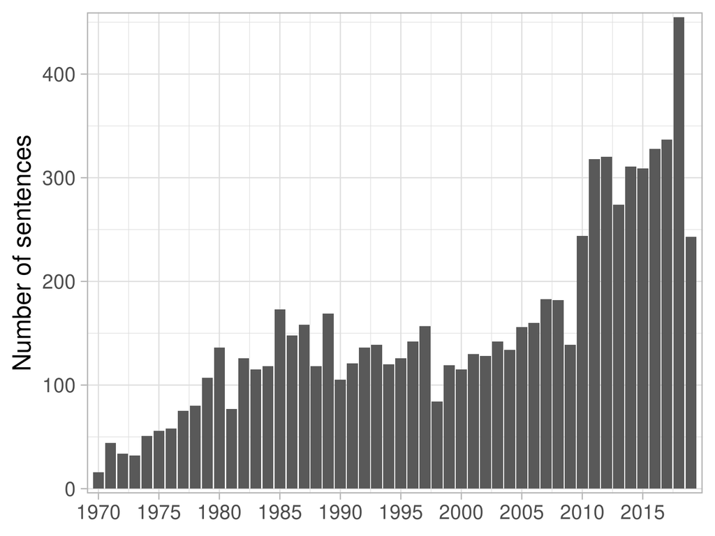

### Closest sentence from ‘rational’ and ‘rationality’ of the backbone community

| Sentence | Title | Year | Journal | Authors | Words Similarity |
| --- | --- | --- | --- | --- | --- |
| Identifying rationality with one particular equilibrium concept can be highly misleading particularly in the presence of alternative sets of expectations that lead to widely different equilibria. | [Economic Rationality and the Areeda-Turner Rule](http://www.jstor.org/stable/43550516) | 2015 | Review of Industrial Organization | William S. Comanor , H. E. Freeh III | 0.851 |
| This section examines two directions in which this link between knowledge of rationality and equilibrium refinements has been explored. | [Modeling Knowledge in Economic Analysis](http://www.jstor.org/stable/3217177) | 2004 | Journal of Economic Literature | Larry Samuelson | 0.830 |
| Furthermore we discuss two interpretations of the model, one assuming that agents hold rational expectations the other assuming that they hold rational beliefs. | [Price stabilizing, Pareto improving policies](http://www.jstor.org/stable/41485846) | 2011 | Economic Theory | Carsten Krabbe Nielsen | 0.825 |
| As an alternative to the conventional equilibrium model, we consider models that allow for bounded rationality of subjects. | [Bounded Rationality in Laboratory Bargaining with Asymmetric Information](http://www.jstor.org/stable/25055899) | 2005 | Economic Theory | Timothy N. Cason , Stanley S. Reynolds | 0.813 |
| Introducing a small amount of adaptive expectations The above discussion is intended mainly to clarify the implications of complete rationality in a world with multiple equilibria. | [Wage Relativities and the Natural Range of Unemployment](http://www.jstor.org/stable/2234184) | 1990 | The Economic Journal | V. Bhaskar | 0.805 |
| ‘Can small deviations from rationality make significant differences to economic equilibria?’ | [Bounded Rationality and Strategic Complementarity in a Macroeconomic Model: Policy Effects, Persistence and Multipliers](http://www.jstor.org/stable/2957740) | 1997 | The Economic Journal | Antúlio N. Bomfim , Francis X. Diebold | 0.804 |
| Concluding remarks * The use of the set of equilibrium configurations imposes relatively weak rationality requirements on agents. | [One Smart Agent](http://www.jstor.org/stable/2555778) | 1997 | The RAND Journal of Economics | John Sutton | 0.794 |
| “Can Small Deviations from Rationality Make Significant Differences to Economic Equilibria?” | [Consumer Durables: Evidence on the Optimality of Usually Doing Nothing](http://www.jstor.org/stable/1992740) | 1992 | Journal of Money, Credit and Banking | Avner Bar-Ilan , Alan S. Blinder | 0.794 |
| Although an extreme multiplicity of equilibria continues to prevail, we are able to define “rationality” in a somewhat more satisfactory way than is the case for the static model. | [“Rational” Duopoly Equilibria](http://www.jstor.org/stable/1885485) | 1980 | The Quarterly Journal of Economics | John Laitner | 0.793 |
| “Can Small Deviations from Rationality Make Significant Differences to Economic Equilibria?” | [Near-Rationality, Heterogeneity, and Aggregate Consumption](http://www.jstor.org/stable/2077849) | 1995 | Journal of Money, Credit and Banking | Ricardo J. Caballero | 0.793 |
| “Can Small Deviations from Rationality Make Significant Differences to Economic Equilibria?” | [The Genesis of Inflation and the Costs of Disinflation: Comment](http://www.jstor.org/stable/1992680) | 1991 | Journal of Money, Credit and Banking | Peter Howitt | 0.793 |
| Springer-Verlag 1994 On rational belief equilibria* Mordecai Kurz Department of Economics, Encina Hall, Stanford University, Stanford, CA 94305, USA Received: September 3,1992; revised version May 10,… | [On Rational Belief Equilibria](http://www.jstor.org/stable/25054812) | 1994 | Economic Theory | Mordecai Kurz | 0.793 |
| Overall, this work raises a cautionary note that the link between rationality and equilibrium refinements is not as straightforward as one might initially think. | [Modeling Knowledge in Economic Analysis](http://www.jstor.org/stable/3217177) | 2004 | Journal of Economic Literature | Larry Samuelson | 0.791 |
| If all parties are boundedly rational, then an equilibrium can be interpreted as a credible prediction only if it can be computed with reasonable effort. | [Computing Equilibria: A Computational Complexity Perspective](http://www.jstor.org/stable/25619983) | 2010 | Economic Theory | Tim Roughgarden | 0.785 |
| This seems to suggest that factors other than bounded rationality are responsible for non-equilibrium behavior. | [Ill-Defined versus Precise Pre-Play Communication in the Traveler’s Dilemma](http://www.jstor.org/stable/40997136) | 2010 | Southern Economic Journal | Sujoy Chakravarty , Emmanuel Dechenaux, Jaideep Roy | 0.785 |
| F Rationality A key question remaining is whether the equilibrium described above is consistent with rational behavior. | [Rational Bias in Macroeconomic Forecasts](http://www.jstor.org/stable/2586954) | 1999 | The Quarterly Journal of Economics | David Laster, Paul Bennett, In Sun Geoum | 0.781 |
| “Can Small Deviations from Rationality Make Significant Differences to Economic Equilibrium?” | [Money in a Real Business Cycle Model](http://www.jstor.org/stable/2953651) | 1997 | Journal of Money, Credit and Banking | Roger E. A. Farmer | 0.781 |
| In this subsection we consider several other equilibrium concepts, implying either less or more rationality in the market. | [Equilibrium in Competitive Insurance Markets: An Essay on the Economics of Imperfect Information](http://www.jstor.org/stable/1885326) | 1976 | The Quarterly Journal of Economics | Michael Rothschild, Joseph Stiglitz | 0.780 |
| We therefore consider models with biases in beliefs and non-optimal behavior in addition to a rational expectations model. | [DEMAND ANALYSIS USING STRATEGIC REPORTS: AN APPLICATION TO A SCHOOL CHOICE MECHANISM](http://www.jstor.org/stable/44955973) | 2018 | Econometrica | Nikhil Agarwal, Paulo Somaini | 0.780 |
| If, as seems more likely, alternative future policies are possible, then rational agents must have a probability distribution over those policies, and the properties of observed equilibria will depend… | [Generalizing the Taylor Principle](http://www.jstor.org/stable/30035014) | 2007 | The American Economic Review | Troy Davig , Eric M. Leeper | 0.777 |
| Section two discusses the rational choice theory of beliefs which is dominant in economics and behaviorism in psychology. | [Rational, Normative and Procedural Theories of Beliefs: Can They Explain Internal Motivations?](http://www.jstor.org/stable/23071565) | 2011 | Journal of Economic Issues | Elias L. Khalil | 0.777 |

### Closest sentences of the backbone community’s centroid

| Sentence | Title | Year | Journal | Authors | Centroid Similarity |
| --- | --- | --- | --- | --- | --- |
| In Rational Beliefs Equilibria monetary shocks have real effects even when they are observed but are not fully anticipated. | [Endogenous Uncertainty and the Non-Neutrality of Money](http://www.jstor.org/stable/25055628) | 2003 | Economic Theory | Maurizio Motolese | 0.8318884 |
| Keywords and Phrases: Money non-neutrality, Monetary policy, Rational ex pectations, Rational beliefs, Rational belief equilibrium, Endogenous uncertainty, States of belief, Phillips curve. | [Endogenous Uncertainty and the Non-Neutrality of Money](http://www.jstor.org/stable/25055628) | 2003 | Economic Theory | Maurizio Motolese | 0.8314950 |
| Keywords and Phrases: Money non-neutrality, Monetary policy, Rational ex pectations, Rational beliefs, Rational Belief Equilibrium, Endogenous uncer tainty, States of belief. | [Money Non-Neutrality in a Rational Belief Equilibrium with Financial Assets](http://www.jstor.org/stable/25055412) | 2001 | Economic Theory | Maurizio Motolese | 0.8273518 |
| To our knowledge, this is the first paper to emphasize consequences of belief structures not disciplined by the assumption of rational expectations for commu nication and monetary policy. | [Central Bank Communication and Expectations Stabilization](http://www.jstor.org/stable/25760315) | 2010 | American Economic Journal: Macroeconomics | Stefano Eusepi, Bruce Preston | 0.8012846 |
| Under Rational Beliefs Equilibria nominal prices and real output change not only in re sponse to changes in the exogenous growth rate of money but also in response to changes in the state of beliefs. | [Endogenous Uncertainty and the Non-Neutrality of Money](http://www.jstor.org/stable/25055628) | 2003 | Economic Theory | Maurizio Motolese | 0.7972402 |
| “The Significance of Monetary Disequilibrium.” | [Harry Gunnison Brown: An Orthodox Economist and His Contributions](http://www.jstor.org/stable/3487845) | 2002 | The American Journal of Economics and Sociology | Christopher K. Ryan | 0.7874929 |
| : Endogenous economic fluctuations: studies in the theory of rational belief. | [Diverse beliefs and time variability of risk premia](http://www.jstor.org/stable/41485841) | 2011 | Economic Theory | Mordecai Kurz , Maurizio Motolese | 0.7829800 |
| By analyz ing a model that permits beliefs to become unanchored from rational expectations, and possibly be inconsistent with the monetary policy strategy of the central bank, the value of certain typ… | [Central Bank Communication and Expectations Stabilization](http://www.jstor.org/stable/25760315) | 2010 | American Economic Journal: Macroeconomics | Stefano Eusepi, Bruce Preston | 0.7819781 |
| States of belief amplify or decrease the effect of monetary policy on price level fluctuations leading to a more volatile pattern of inflation rates than under the Macro Rational Expectations hypoth e… | [Money Non-Neutrality in a Rational Belief Equilibrium with Financial Assets](http://www.jstor.org/stable/25055412) | 2001 | Economic Theory | Maurizio Motolese | 0.7758553 |
| 5 Some remarks on empirical implications and public policy under rational beliefs The question whether variations in equilibrium prices and quantities are due only to variations in exogenous “fundamen… | [Rational Beliefs and Endogenous Uncertainty](http://www.jstor.org/stable/25054980) | 1996 | Economic Theory | Mordecai Kurz | 0.7743285 |
| The heterogeneity of beliefs together with the distribution and intensity of agents’ states of optimism/pessimism can amplify the real effect of monetary policy and/or generate endogenous fluctuations… | [Money Non-Neutrality in a Rational Belief Equilibrium with Financial Assets](http://www.jstor.org/stable/25055412) | 2001 | Economic Theory | Maurizio Motolese | 0.7737340 |
| Below, we present an informal, intuitive argument.6 5 The actual equilibrium model in the next section allows beliefs about the money supply to be ambiguous too. | [Ambiguity Aversion and the Absence of Indexed Debt](http://www.jstor.org/stable/25055839) | 2004 | Economic Theory | Sujoy Mukerji , Jean-Marc Tallon | 0.7715025 |
| Springer-Verlag 2001 Money non-neutrality in a Rational Belief Equilibrium with financial assets* Maurizio Motolese Istituto di Politica Econ?mica, Universit? | [Money Non-Neutrality in a Rational Belief Equilibrium with Financial Assets](http://www.jstor.org/stable/25055412) | 2001 | Economic Theory | Maurizio Motolese | 0.7674022 |
| When beliefs for monetary policy.62 are sufficiently far from rationalexpectations equilibrium, optimal pol- 9. | [The Science of Monetary Policy](http://www.jstor.org/stable/26417200) | 2018 | Journal of Economic Literature | Stefano Eusepi, Bruce Preston | 0.7671192 |
| In the monetary version of their economy, when deciding upon prices, sellers must now internalize buyers’ ex ante indifference condition between the low and the high money holding. | [CONTINGENT PRICES AND MONEY](http://www.jstor.org/stable/41349196) | 2011 | International Economic Review | Richard Dutu , Stella Huangfu, Benoit Julien | 0.7652507 |

### Closest sentences of each kmean cluster’s centroid composing the backbone community

#### Top terms 12_86: equilibrium, conjectural_equilibrium, disequilibrium, market_equilibrium, equilibrium_theory (1970-1979)

| Sentence | Title | Year | Journal | Authors | Distance to Centroid |
| --- | --- | --- | --- | --- | --- |
| The main characteristic of the theoretical framework that I present is its general-equilibrium nature. | [Internally Inconsistent Mixtures of Micro- and Macrotheory in Empirical Studies of Profits Tax Incidence](http://www.jstor.org/stable/40911282) | 1976 | FinanzArchiv / Public Finance Analysis | J. B. Burbidge | 6.953469 |
| We will proceed as follows: First we will discuss the concepts of a public competitive equilibrium and a Lindahl Equilibrium. | [Core Allocations and Competitive Equilibrium — A Survey](http://www.jstor.org/stable/41797539) | 1973 | Zeitschrift für Nationalökonomie / Journal of Economics | Andrew Schotter | 7.001303 |
| The statical theory of equilibrium is only an introduction to economic studies; and … its limitations are so constantly overlooked, especially by those who approach it from an abstract point of view, … | [Uncertainty and the Uses of Money](http://www.jstor.org/stable/40324718) | 1979 | Eastern Economic Journal | Douglas Vickers | 7.007076 |
| Competitive equilibrium is also discussed. | [Interdependent Utilities and Pareto Optimality](http://www.jstor.org/stable/1880491) | 1972 | The Quarterly Journal of Economics | Lawrence D. Schall | 7.136888 |
| The price and quantity adjustments that move an economy toward equilibrium are often made only because the relevant economic deci- * This paper has benefited substantially from the comments of Arthur … | [Patinkin’s Macro Model as a Model of Market Disequilibrium](http://www.jstor.org/stable/1056590) | 1972 | Southern Economic Journal | Donald P. Tucker | 7.174148 |

#### Top terms 12_103: equilibrium, equilibria, rational_expectations, disequilibrium, equilibrium_beliefs (1980-1989)

| Sentence | Title | Year | Journal | Authors | Distance to Centroid |
| --- | --- | --- | --- | --- | --- |
| Moreover, it may be argued that the very fact that equilibrium is indeterminate in certain economic models, so that revisions of expectations may be self-fulfilling, is itself a prediction of great im… | [Three Questions about Sunspot Equilibria as an Explanation of Economic Fluctuations](http://www.jstor.org/stable/1805434) | 1987 | The American Economic Review | Michael Woodford | 6.613767 |
| AN ALTERNATIVE EQUILIBRIUM NOTION The results of the previous section are counterintuitive. | [Implementation of Democratic Social Choice Functions](http://www.jstor.org/stable/2297367) | 1982 | The Review of Economic Studies | John A. Ferejohn , David M. Grether , Richard D. McKelvey | 6.687833 |
| D. Further Implications of the Equilibrium 1. | [External Currency Market Equilibrium and its Implications for Regulation of the Eurocurrency Market](http://www.jstor.org/stable/2327977) | 1983 | The Journal of Finance | Dennis E. Logue, Lemma W. Senbet | 6.727269 |
| In Section I, the economic setting and some basic implications for equilibrium are presented. | [Conditions for Myopic Valuation and Serial Independence of the Market Excess Return in Discrete Time Models](http://www.jstor.org/stable/2327869) | 1984 | The Journal of Finance | Günter Franke | 6.862753 |
| petitive equilibrium is accorded the pride of place in textbooks where, either due to ignorance or to political bias, enough caution is not taken to show its limitations as an explanatory device, has … | [Perfect Competition and Economic Theory](http://www.jstor.org/stable/29793318) | 1981 | Indian Economic Review | A. K. DASGUPTA | 6.917000 |

#### Top terms 12_111: equilibria, equilibrium, beliefs, multiple_equilibria, rational_expectations (1990-1999)

| Sentence | Title | Year | Journal | Authors | Distance to Centroid |
| --- | --- | --- | --- | --- | --- |
| This concludes our brief survey of equilibrium concepts and the models in which they are embed ded. | [TACIT COLLUSION](http://www.jstor.org/stable/23606305) | 1993 | Oxford Review of Economic Policy | RAY REES | 6.456229 |
| 4, Fall models allow for indeterminacy of equilibria, self-fulfilling expectations and path- dependent equilibria. | [On the Contribution of New Keynesian Economics](http://www.jstor.org/stable/40325477) | 1992 | Eastern Economic Journal | Hans van Ees , Harry Garretsen | 6.915512 |
| The results here also suggest that Cournot’s prediction about equilibrium may sometimes be preferred over Bertrand’s predictions. | [Bertrand versus Cournot Revisited](http://www.jstor.org/stable/25055054) | 1997 | Economic Theory | Cheng-Zhong Qin, Charles Stuart | 6.930300 |
| We suggest the following 18 The equilibrium described in corollary 1 might not be unique. | [Costless Revelation of Private Information in a Duopoly](http://www.jstor.org/stable/40751616) | 1993 | Journal of Institutional and Theoretical Economics (JITE) / Zeitschrift für die gesamte Staatswissenschaft | Dominique Demougin, Rolf Tschernig | 7.019708 |
| Misconceptions among economists about these matters are made more pardonable13 by the meretriciousness of the economist’s notion of “equilibrium.” | [Axiomatics in Economics](http://www.jstor.org/stable/1060684) | 1995 | Southern Economic Journal | Robert W. Clower | 7.120997 |

#### Top terms 12_127: equilibria, equilibrium_beliefs, beliefs, equilibrium, multiple_equilibria (2000-2009)

| Sentence | Title | Year | Journal | Authors | Distance to Centroid |
| --- | --- | --- | --- | --- | --- |
| A survey of the economic literature on equilibrium theorizing reveals various primafacie problematic features, confusions, or at least curiosities, some of the most significant of which I wish to focu… | [The (Confused) State of Equilibrium Analysis in Modern Economics: An Explanation](http://www.jstor.org/stable/4538936) | 2005 | Journal of Post Keynesian Economics | Tony Lawson | 6.695868 |
| First, we provide a response to Backhouse’s partial defense of equilibrium analysis, identifying two main criticisms of Backhouse’s position. | [History versus Equilibrium? On the Possibility and Realist Basis of a General Critique of Traditional Equilibrium Analysis](http://www.jstor.org/stable/4539012) | 2006 | Journal of Post Keynesian Economics | Dany Lang , Mark Setterfield | 6.827235 |
| Second, we provide some elements for a general critique of Backhouse’s vision of equilibrium analysis, which we identify as the “traditional equilibrium approach” to economic theorizing. | [History versus Equilibrium? On the Possibility and Realist Basis of a General Critique of Traditional Equilibrium Analysis](http://www.jstor.org/stable/4539012) | 2006 | Journal of Post Keynesian Economics | Dany Lang , Mark Setterfield | 6.902919 |
| Here we consider for expositional purposes the former equilibrium outcome. | [Contesting Resources: Rent Seeking, Conflict and the Natural Resource Curse](http://www.jstor.org/stable/25487568) | 2006 | Public Choice | Katharina Wick, Erwin H. Bulte | 6.923580 |
| While a full-fledged analysis of the resulting equilibrium is beyond the scope of this paper, several conclusions can be drawn from this informal discussion. | [Representative versus Direct Democracy: The Role of Informational Asymmetries](http://www.jstor.org/stable/30026671) | 2005 | Public Choice | Anke S. Kessler | 6.958342 |